# Beyond main effects? Affect level as a moderator in the relation between affect dynamics and depressive symptoms

### 6.6.3 Intra-class correlations

```r
##################### delete observations with 0 variance #####################

dataset6_LASER_processed1<-dataset6_LASER_processed
dataset6_LASER_processed1 <- check.timeinvar(NAff, ID, dataset6_LASER_processed1, out = 3)


##################### ICCs #####################

#### NA ####
NA_ICC <- lmer(NAff ~ 1 + (1 | ID), data = dataset6_LASER_processed)
NA_ICCr_LASER <- performance::icc(NA_ICC)
NA_ICCr_LASER
```

```
## # Intraclass Correlation Coefficient
##
##     Adjusted ICC: 0.343
##   Unadjusted ICC: 0.343
```

```r
#### Bipolar Affect scale ####
Bip_aff_ICC <- lmer(Bip_aff ~ 1 + (1 | ID), data = dataset6_LASER_processed)
Bip_aff_ICCr_LASER <- performance::icc(Bip_aff_ICC)
Bip_aff_ICCr_LASER
```

```
## # Intraclass Correlation Coefficient
##
##     Adjusted ICC: 0.254
##   Unadjusted ICC: 0.254
```

### 6.6.4 Exclusion and Compliance

```r
##################### Details study design #####################
#### Total beeps ####
tot_ass_LASER<-42
#### Total days ####
tot_days_LASER <- 14
#### Total beeps per day ####
tot_b_d_LASER<-3

#### Number of valid beeps before exclusion ####
mean(calc.mean(count, ID, data=dataset6_LASER_processed))
```

```
## [1] 32
```

```r
#### Percentage of valid beeps before exclusion ####
dataset6_LASER_processed$perc<-(100/tot_ass_LASER)*dataset6_LASER_processed$count
mean(calc.mean(perc, ID, data=dataset6_LASER_processed))
```

```
## [1] 76.19048
```

```r
#### Number of participants before exclusion ####
n_LASER<-nsub(ID, dataset6_LASER_processed)
n_LASER
```

```
## [1] 182
```

```r
#### Removing participants with compliance below 33% ####

## one-third of beeps ##
valbeep_LASER <- (tot_ass_LASER/100)*33
valbeep_LASER
```

```
## [1] 13.86
```

```r
## excluding those with fewer than 33% ##
dataset6_LASER_processed <-subset(dataset6_LASER_processed, count > valbeep_LASER)

#### Delete participants without any variance on NAff and PAff ###
## n before ##
nsub(ID, dataset6_LASER_processed)
```

```
## [1] 173
```

```r
#### Delete participants without any variance on NAff and PAff ####
dataset6_LASER_processed <- check.timeinvar(NAff, ID, dataset6_LASER_processed, out = 3)
dataset6_LASER_processed <- check.timeinvar(Bip_aff, ID, dataset6_LASER_processed, out = 3)

## n after ##
nsub(ID, dataset6_LASER_processed) #no participants excluded
```

```
## [1] 173
```

```r
#### final sample ####
n_fin_LASER<-nsub(ID, dataset6_LASER_processed)
n_fin_LASER
```

```
## [1] 173
```

```r
perc_inc_LASER <- (100/n_LASER_orig)*n_fin_LASER
perc_inc_LASER
```

```
## [1] 95.05495
```

```r
#### mean of valid beeps per participant ####
mean_comp_LASER<-mean(calc.mean(count, ID, data=dataset6_LASER_processed))
mean_comp_LASER
```

```
## [1] 33.31214
```

```r
#### percentage of valid beeps per participant ####
mean_com_per_LASER<-mean(calc.mean(perc, ID, data=dataset6_LASER_processed))
mean_com_per_LASER
```

```
## [1] 79.31462
```

### 6.6.5 Calculation of affective dynamics

#### 6.6.5.1 Datapreparation

```r
##################### sort by ID and time #####################
dataset6_LASER_processed<-dataset6_LASER_processed[order(dataset6_LASER_processed$ID,dataset6_LASER_processed$time) , ]

##################### subset most important variables #####################
dataset6_LASER_processed_affdyn <- subset(dataset6_LASER_processed, select=c("ID","time","Day","NAff","Bip_aff"))

##################### delete missing values #####################
#so that differences are also calculated between beeps that were
#not directly next to each other (e.g., 3, 4(NA), 5)
#I still want to calculate the difference between 3 and 5
dataset6_LASER_processed_affdyn<-dataset6_LASER_processed_affdyn[!is.na(dataset6_LASER_processed_affdyn$NAff),]

##################### make a new time variable #####################
dataset6_LASER_processed_affdyn<-dataset6_LASER_processed_affdyn %>% group_by(ID) %>% dplyr::mutate(time = rank(time, ties.method = 'first'))%>% arrange(time)

##################### add missing days after each week #####################
#this is important, because for the MSSD, we do not want to calculate the
#difference between the last beep of one day and the first beep of the next day/week

dataset6_LASER_processed_affdyn_NA <-insert_NA(dataset6_LASER_processed_affdyn, ID, Day)
```

#### 6.6.5.2 Calculation

```r
##################### Calculate affective dynamics #####################
#### Mean, SD ####

aff_dyn_LASER <- ddply(dataset6_LASER_processed_affdyn_NA, "ID",  plyr::summarize,
                           icountNA = sum(!is.na(NAff)),  #count of observations
                           imeanNA  = mean(NAff, na.rm=TRUE), #imean (continuous)
                           isdNA   = sd(NAff, na.rm=TRUE), #isd (continuous)
                           icountBip = sum(!is.na(Bip_aff)),  #count of observations
                           imeanBip_aff  = mean(Bip_aff, na.rm=TRUE), #imean (continuous)
                           isdBip_aff   = sd(Bip_aff, na.rm=TRUE),   #isd   (continuous)
                           relisdNA = relativeSD(NAff, 1, 9)) #relative isd (continuous)


#### MSSD ####

mssd.stats.NA <- ddply(dataset6_LASER_processed_affdyn_NA, "ID", plyr::summarize, iMSSDNA=my.mssd(NAff))
mssd.stats.Bip_aff <- ddply(dataset6_LASER_processed_affdyn_NA, "ID", plyr::summarize, iMSSDBip_aff=my.mssd(Bip_aff))

aff_dyn_LASER <- merge(aff_dyn_LASER,mssd.stats.NA,by="ID",all=TRUE)
aff_dyn_LASER <- merge(aff_dyn_LASER,mssd.stats.Bip_aff,by="ID",all=TRUE)


#### autocorrelation ####


## Lagged effect ##

dataset6_LASER_processed_affdyn$NAff_lag<-lagvar(NAff, id=ID, obs=time, day=Day,data=dataset6_LASER_processed_affdyn)
dataset6_LASER_processed_affdyn$Bip_aff_lag<-lagvar(Bip_aff, id=ID, obs=time, day=Day,data=dataset6_LASER_processed_affdyn)

## Mixed model ##
auto_NA <- lmer(NAff ~ 1 + NAff_lag + (1 + NAff_lag | ID),
                     data = dataset6_LASER_processed_affdyn, REML = TRUE,
                     control = lmerControl(optimizer ='optimx', optCtrl=list(method='nlminb')))
summary(auto_NA)
```

```
## Linear mixed model fit by REML ['lmerMod']
## Formula: NAff ~ 1 + NAff_lag + (1 + NAff_lag | ID)
##    Data: dataset6_LASER_processed_affdyn
## Control: lmerControl(optimizer = "optimx", optCtrl = list(method = "nlminb"))
##
## REML criterion at convergence: 13632.7
##
## Scaled residuals:
##     Min      1Q  Median      3Q     Max
## -2.9179 -0.6712 -0.0765  0.6296  3.9249
##
## Random effects:
##  Groups   Name        Variance Std.Dev. Corr
##  ID       (Intercept) 1.08794  1.0430
##           NAff_lag    0.02282  0.1511   -0.65
##  Residual             2.87455  1.6954
## Number of obs: 3410, groups:  ID, 173
##
## Fixed effects:
##             Estimate Std. Error t value
## (Intercept)  2.90218    0.11264   25.77
## NAff_lag     0.30100    0.02107   14.29
##
## Correlation of Fixed Effects:
##          (Intr)
## NAff_lag -0.789
```

```r
auto_Bip_aff <- lmer(Bip_aff ~ 1 + Bip_aff_lag + (1 + Bip_aff_lag | ID),
                     data = dataset6_LASER_processed_affdyn, REML = TRUE,
                     control = lmerControl(optimizer ='optimx', optCtrl=list(method='nlminb')))
summary(auto_Bip_aff)
```

```
## Linear mixed model fit by REML ['lmerMod']
## Formula: Bip_aff ~ 1 + Bip_aff_lag + (1 + Bip_aff_lag | ID)
##    Data: dataset6_LASER_processed_affdyn
## Control: lmerControl(optimizer = "optimx", optCtrl = list(method = "nlminb"))
##
## REML criterion at convergence: 15919
##
## Scaled residuals:
##     Min      1Q  Median      3Q     Max
## -3.5170 -0.5552  0.0932  0.6671  2.8606
##
## Random effects:
##  Groups   Name        Variance Std.Dev. Corr
##  ID       (Intercept)  1.80913 1.3450
##           Bip_aff_lag  0.02669 0.1634   0.09
##  Residual             13.69412 3.7006
## Number of obs: 2869, groups:  ID, 173
##
## Fixed effects:
##             Estimate Std. Error t value
## (Intercept)  1.41107    0.13532   10.43
## Bip_aff_lag  0.32102    0.02304   13.93
##
## Correlation of Fixed Effects:
##             (Intr)
## Bip_aff_lag -0.220
```

```r
## Extract individual slopes ##
beta_NA<-tibble::rownames_to_column(coef(auto_NA)$ID)
beta_NA<-plyr::rename(beta_NA,
                c("NAff_lag" = "autocorNA",
                  "rowname" =  "ID"))

beta_Bip_aff<-tibble::rownames_to_column(coef(auto_Bip_aff)$ID)
beta_Bip_aff<-plyr::rename(beta_Bip_aff,
                c("Bip_aff_lag" = "autocorBip_aff",
                  "rowname" =  "ID"))


##################### Merge data #####################
aff_dyn_LASER <- merge(aff_dyn_LASER,beta_NA,by="ID",all=TRUE)
aff_dyn_LASER <- merge(aff_dyn_LASER,beta_Bip_aff,by="ID",all=TRUE)

##################### Delete intercept from aff_dyn files #####################
aff_dyn_LASER<-subset(aff_dyn_LASER, select=c(1:10,12,14))
names(aff_dyn_LASER)
```

```
##  [1] "ID"             "icountNA"       "imeanNA"        "isdNA"
##  [5] "icountBip"      "imeanBip_aff"   "isdBip_aff"     "relisdNA"
##  [9] "iMSSDNA"        "iMSSDBip_aff"   "autocorNA"      "autocorBip_aff"
```

### 6.6.6 Merging

```r
##################### restructure depression/demographics data #####################
#The dataset was in longformat, however the affective dynamics measures are in wide format
#Thus, I restructure the dataset (which only contain time-invariant variables anyway)
#and merge with the affective dynamics data
data_id_dep_LASER <- subset(dataset6_LASER_processed, select=c("ID","Sex","Age","DepB"))
data_id_dep_LASER<-data_id_dep_LASER %>% group_by(ID) %>% summarise_all(mean)

##################### Merge affective dynamics and depression/demographics data #####################
datasetLASER_final <- merge(data_id_dep_LASER,aff_dyn_LASER,by="ID",all=TRUE)
names(datasetLASER_final)
```

```
##  [1] "ID"             "Sex"            "Age"            "DepB"
##  [5] "icountNA"       "imeanNA"        "isdNA"          "icountBip"
##  [9] "imeanBip_aff"   "isdBip_aff"     "relisdNA"       "iMSSDNA"
## [13] "iMSSDBip_aff"   "autocorNA"      "autocorBip_aff"
```

### 6.6.7 Winzorising and transformation of skewed variables

```r
##################### winsorizing #####################
names(datasetLASER_final)
```

```
##  [1] "ID"             "Sex"            "Age"            "DepB"
##  [5] "icountNA"       "imeanNA"        "isdNA"          "icountBip"
##  [9] "imeanBip_aff"   "isdBip_aff"     "relisdNA"       "iMSSDNA"
## [13] "iMSSDBip_aff"   "autocorNA"      "autocorBip_aff"
```

```r
datasetLASER_final<-datasetLASER_final[order(datasetLASER_final$ID) , ]

psych::describe(datasetLASER_final)
```

```
##                vars   n  mean    sd median trimmed   mad   min    max  range
## ID*               1 173 87.00 50.08  87.00   87.00 63.75  1.00 173.00 172.00
## Sex               2 172  0.87  0.34   1.00    0.96  0.00  0.00   1.00   1.00
## Age               3 173 18.84  1.64  18.00   18.65  1.48 17.00  29.00  12.00
## DepB              4 173  0.79  0.54   0.63    0.73  0.47  0.00   2.58   2.58
## icountNA          5 173 33.31  6.68  35.00   34.13  5.93 14.00  42.00  28.00
## imeanNA           6 173  4.15  1.27   4.11    4.17  1.27  1.19   8.08   6.89
## isdNA             7 173  1.64  0.49   1.61    1.64  0.52  0.25   3.14   2.89
## icountBip         8 173 29.83  8.14  32.00   30.62  8.90  8.00  42.00  34.00
## imeanBip_aff      9 173  2.31  2.36   1.93    2.23  2.48 -3.29   7.85  11.14
## isdBip_aff       10 173  3.65  1.07   3.60    3.65  0.92  0.72   6.88   6.16
## relisdNA         11 173  0.45  0.12   0.44    0.45  0.13  0.06   0.78   0.72
## iMSSDNA          12 173  2.03  0.69   1.99    2.02  0.68  0.36   4.17   3.81
## iMSSDBip_aff     13 173  4.38  1.52   4.26    4.35  1.35  0.53   9.00   8.47
## autocorNA        14 173  0.30  0.08   0.30    0.30  0.07  0.02   0.52   0.50
## autocorBip_aff   15 173  0.32  0.09   0.32    0.32  0.09  0.03   0.52   0.49
##                 skew kurtosis   se
## ID*             0.00    -1.22 3.81
## Sex            -2.13     2.57 0.03
## Age             2.93    14.93 0.12
## DepB            1.01     0.63 0.04
## icountNA       -1.02     0.29 0.51
## imeanNA         0.00    -0.25 0.10
## isdNA           0.04     0.13 0.04
## icountBip      -0.76    -0.28 0.62
## imeanBip_aff    0.30    -0.51 0.18
## isdBip_aff      0.06     0.58 0.08
## relisdNA        0.08     0.02 0.01
## iMSSDNA         0.24     0.31 0.05
## iMSSDBip_aff    0.23     0.34 0.12
## autocorNA      -0.26     0.74 0.01
## autocorBip_aff -0.35    -0.04 0.01
```

```r
dataLASER_finalW<-data.frame(datasetLASER_final)

#select predictors and outcome variables (affective dynamics and depression)
predictor_wins<-c(4,6,7,9:15)

#winsorizing
dataLASER_finalW<-apply(dataLASER_finalW[,predictor_wins],
                                 2,
                                 Winsorize, probs=c(0.01,0.99), na.rm = TRUE)

dataLASER_finalW<-data.frame(dataLASER_finalW)

psych::describe(dataLASER_finalW)
```

```
##                vars   n mean   sd median trimmed  mad   min  max range  skew
## DepB              1 173 0.78 0.54   0.63    0.73 0.47  0.00 2.41  2.41  0.96
## imeanNA           2 173 4.15 1.25   4.11    4.17 1.27  1.37 6.74  5.37 -0.10
## isdNA             3 173 1.64 0.48   1.61    1.64 0.52  0.56 2.81  2.25  0.02
## imeanBip_aff      4 173 2.31 2.34   1.93    2.23 2.48 -2.29 7.48  9.78  0.32
## isdBip_aff        5 173 3.65 1.06   3.60    3.65 0.92  0.98 6.32  5.33  0.03
## relisdNA          6 173 0.45 0.12   0.44    0.45 0.13  0.22 0.74  0.53  0.20
## iMSSDNA           7 173 2.03 0.69   1.99    2.02 0.68  0.61 4.01  3.40  0.22
## iMSSDBip_aff      8 173 4.38 1.49   4.26    4.35 1.35  0.75 8.21  7.47  0.14
## autocorNA         9 173 0.30 0.08   0.30    0.30 0.07  0.07 0.48  0.42 -0.17
## autocorBip_aff   10 173 0.32 0.09   0.32    0.32 0.09  0.09 0.49  0.40 -0.30
##                kurtosis   se
## DepB               0.40 0.04
## imeanNA           -0.55 0.09
## isdNA             -0.23 0.04
## imeanBip_aff      -0.60 0.18
## isdBip_aff         0.36 0.08
## relisdNA          -0.45 0.01
## iMSSDNA            0.12 0.05
## iMSSDBip_aff       0.00 0.11
## autocorNA          0.17 0.01
## autocorBip_aff    -0.27 0.01
```

```r
#add id number
dataLASER_finalW$ID <- datasetLASER_final$ID

#make subset of variables that were not included in the winsorizing
sub1<-subset(datasetLASER_final, select=c(1:3,5,8))

#Merge files
dataLASER_finalW <- merge(dataLASER_finalW,sub1,by="ID",all=TRUE)

##################### Transforming ######################
#if skewness is > 3 (Kline, 2011)
#### identifying ####
skew<-skew(select(dataLASER_finalW, -ID))>3
skew
```

```
##  [1] FALSE FALSE FALSE FALSE FALSE FALSE FALSE FALSE FALSE FALSE FALSE FALSE
## [13] FALSE FALSE
```

```r
length(skew[skew== TRUE])
```

```
## [1] 0
```

```r
#no transformations necessary

names(dataLASER_finalW)
```

```
##  [1] "ID"             "DepB"           "imeanNA"        "isdNA"
##  [5] "imeanBip_aff"   "isdBip_aff"     "relisdNA"       "iMSSDNA"
##  [9] "iMSSDBip_aff"   "autocorNA"      "autocorBip_aff" "Sex"
## [13] "Age"            "icountNA"       "icountBip"
```

### 6.6.8 Center/standardize study variables

- Center of predictors (for moderation)
- Standardization of the depression scale

```r
names(dataLASER_finalW)
```

```
##  [1] "ID"             "DepB"           "imeanNA"        "isdNA"
##  [5] "imeanBip_aff"   "isdBip_aff"     "relisdNA"       "iMSSDNA"
##  [9] "iMSSDBip_aff"   "autocorNA"      "autocorBip_aff" "Sex"
## [13] "Age"            "icountNA"       "icountBip"
```

```r
psych::describe(dataLASER_finalW)
```

```
##                vars   n  mean    sd median trimmed   mad   min    max  range
## ID*               1 173 87.00 50.08  87.00   87.00 63.75  1.00 173.00 172.00
## DepB              2 173  0.78  0.54   0.63    0.73  0.47  0.00   2.41   2.41
## imeanNA           3 173  4.15  1.25   4.11    4.17  1.27  1.37   6.74   5.37
## isdNA             4 173  1.64  0.48   1.61    1.64  0.52  0.56   2.81   2.25
## imeanBip_aff      5 173  2.31  2.34   1.93    2.23  2.48 -2.29   7.48   9.78
## isdBip_aff        6 173  3.65  1.06   3.60    3.65  0.92  0.98   6.32   5.33
## relisdNA          7 173  0.45  0.12   0.44    0.45  0.13  0.22   0.74   0.53
## iMSSDNA           8 173  2.03  0.69   1.99    2.02  0.68  0.61   4.01   3.40
## iMSSDBip_aff      9 173  4.38  1.49   4.26    4.35  1.35  0.75   8.21   7.47
## autocorNA        10 173  0.30  0.08   0.30    0.30  0.07  0.07   0.48   0.42
## autocorBip_aff   11 173  0.32  0.09   0.32    0.32  0.09  0.09   0.49   0.40
## Sex              12 172  0.87  0.34   1.00    0.96  0.00  0.00   1.00   1.00
## Age              13 173 18.84  1.64  18.00   18.65  1.48 17.00  29.00  12.00
## icountNA         14 173 33.31  6.68  35.00   34.13  5.93 14.00  42.00  28.00
## icountBip        15 173 29.83  8.14  32.00   30.62  8.90  8.00  42.00  34.00
##                 skew kurtosis   se
## ID*             0.00    -1.22 3.81
## DepB            0.96     0.40 0.04
## imeanNA        -0.10    -0.55 0.09
## isdNA           0.02    -0.23 0.04
## imeanBip_aff    0.32    -0.60 0.18
## isdBip_aff      0.03     0.36 0.08
## relisdNA        0.20    -0.45 0.01
## iMSSDNA         0.22     0.12 0.05
## iMSSDBip_aff    0.14     0.00 0.11
## autocorNA      -0.17     0.17 0.01
## autocorBip_aff -0.30    -0.27 0.01
## Sex            -2.13     2.57 0.03
## Age             2.93    14.93 0.12
## icountNA       -1.02     0.29 0.51
## icountBip      -0.76    -0.28 0.62
```

```r
##################### center predictors #####################
predictor_scale<-c(3:11)

dataLASER_finalWC<-apply(dataLASER_finalW[,predictor_scale],
                           2,
                           scale, scale = FALSE)

dataLASER_finalWC<-data.frame(dataLASER_finalWC)

psych::describe(dataLASER_finalWC)
```

```
##                vars   n mean   sd median trimmed  mad   min  max range  skew
## imeanNA           1 173    0 1.25  -0.03    0.02 1.27 -2.77 2.60  5.37 -0.10
## isdNA             2 173    0 0.48  -0.03    0.00 0.52 -1.08 1.17  2.25  0.02
## imeanBip_aff      3 173    0 2.34  -0.39   -0.08 2.48 -4.61 5.17  9.78  0.32
## isdBip_aff        4 173    0 1.06  -0.05    0.00 0.92 -2.66 2.67  5.33  0.03
## relisdNA          5 173    0 0.12   0.00    0.00 0.13 -0.23 0.29  0.53  0.20
## iMSSDNA           6 173    0 0.69  -0.04   -0.01 0.68 -1.41 1.99  3.40  0.22
## iMSSDBip_aff      7 173    0 1.49  -0.11   -0.02 1.35 -3.63 3.84  7.47  0.14
## autocorNA         8 173    0 0.08   0.00    0.00 0.07 -0.23 0.18  0.42 -0.17
## autocorBip_aff    9 173    0 0.09   0.00    0.00 0.09 -0.23 0.17  0.40 -0.30
##                kurtosis   se
## imeanNA           -0.55 0.09
## isdNA             -0.23 0.04
## imeanBip_aff      -0.60 0.18
## isdBip_aff         0.36 0.08
## relisdNA          -0.45 0.01
## iMSSDNA            0.12 0.05
## iMSSDBip_aff       0.00 0.11
## autocorNA          0.17 0.01
## autocorBip_aff    -0.27 0.01
```

```r
#add id number
dataLASER_finalWC$ID<- dataLASER_finalW$ID

#make subset of variables that were not included in the standardization
sub2<-subset(dataLASER_finalW, select=c(1:2,12:15))

#Merge files
dataLASER_finalWC <- merge(dataLASER_finalWC,sub2,by="ID",all=TRUE)

##################### standardize Depression #####################
dataLASER_finalWC$DepB<-scale(dataLASER_finalWC$DepB, center = TRUE, scale = TRUE)
psych::describe(dataLASER_finalWC)
```

```
##                vars   n  mean    sd median trimmed   mad   min    max  range
## ID*               1 173 87.00 50.08  87.00   87.00 63.75  1.00 173.00 172.00
## imeanNA           2 173  0.00  1.25  -0.03    0.02  1.27 -2.77   2.60   5.37
## isdNA             3 173  0.00  0.48  -0.03    0.00  0.52 -1.08   1.17   2.25
## imeanBip_aff      4 173  0.00  2.34  -0.39   -0.08  2.48 -4.61   5.17   9.78
## isdBip_aff        5 173  0.00  1.06  -0.05    0.00  0.92 -2.66   2.67   5.33
## relisdNA          6 173  0.00  0.12   0.00    0.00  0.13 -0.23   0.29   0.53
## iMSSDNA           7 173  0.00  0.69  -0.04   -0.01  0.68 -1.41   1.99   3.40
## iMSSDBip_aff      8 173  0.00  1.49  -0.11   -0.02  1.35 -3.63   3.84   7.47
## autocorNA         9 173  0.00  0.08   0.00    0.00  0.07 -0.23   0.18   0.42
## autocorBip_aff   10 173  0.00  0.09   0.00    0.00  0.09 -0.23   0.17   0.40
## DepB             11 173  0.00  1.00  -0.29   -0.11  0.87 -1.46   3.03   4.50
## Sex              12 172  0.87  0.34   1.00    0.96  0.00  0.00   1.00   1.00
## Age              13 173 18.84  1.64  18.00   18.65  1.48 17.00  29.00  12.00
## icountNA         14 173 33.31  6.68  35.00   34.13  5.93 14.00  42.00  28.00
## icountBip        15 173 29.83  8.14  32.00   30.62  8.90  8.00  42.00  34.00
##                 skew kurtosis   se
## ID*             0.00    -1.22 3.81
## imeanNA        -0.10    -0.55 0.09
## isdNA           0.02    -0.23 0.04
## imeanBip_aff    0.32    -0.60 0.18
## isdBip_aff      0.03     0.36 0.08
## relisdNA        0.20    -0.45 0.01
## iMSSDNA         0.22     0.12 0.05
## iMSSDBip_aff    0.14     0.00 0.11
## autocorNA      -0.17     0.17 0.01
## autocorBip_aff -0.30    -0.27 0.01
## DepB            0.96     0.40 0.08
## Sex            -2.13     2.57 0.03
## Age             2.93    14.93 0.12
## icountNA       -1.02     0.29 0.51
## icountBip      -0.76    -0.28 0.62
```

```r
names(dataLASER_finalWC)
```

```
##  [1] "ID"             "imeanNA"        "isdNA"          "imeanBip_aff"
##  [5] "isdBip_aff"     "relisdNA"       "iMSSDNA"        "iMSSDBip_aff"
##  [9] "autocorNA"      "autocorBip_aff" "DepB"           "Sex"
## [13] "Age"            "icountNA"       "icountBip"
```

### 6.6.9 Write cleaned datasets

The “raw” (i.e., not centered & standardized) and centered/standardized versions.

```r
write.csv(dataLASER_finalW, here::here("data", "3_cleaned_data_for_OSF", "dataset6_LASER_clean.csv"), row.names = FALSE)
write.csv(dataLASER_finalWC, here::here("data", "3_cleaned_data_for_OSF", "dataset6_LASER_clean_cen_std.csv"), row.names = FALSE)
```

## 6.7 DATASET 7: YES

For the YES dataset, there were only 2 emotion items assessed. First, participants had to rate their overall mood on a scale from -10 to +10 (very negative to very positive). This is what is referred to as Bipolar Affect in this paper (BA). Second, participants had to rate only their most negative emotion (selected from sadness, anger and anxiety).

Given that there is only 1 items for NA, we cannot calculate MCFA’s and alpha and omega. We can calculate the ICCs.

### 6.7.1 Read in data and datapreparation

```r
####################### Read in data #######################
dataset7_YES_processed<-read.csv(here::here("data", "2_processed_data_for_OSF", "dataset7_YES_processed.csv"), sep=",",
                                na.strings="NA")

####################### number of participants with valid ESM data #####################
dataset7_YES_processed$count<-calc.nomiss(NAff, ID, dataset7_YES_processed, prop=FALSE, expand=TRUE)
range(dataset7_YES_processed$count)
```

```
## [1]  0 42
```

```r
# exclude those with not valid daily diary data
n_YES_orig<-nsub(ID, dataset7_YES_processed)
n_YES_orig
```

```
## [1] 193
```

```r
dataset7_YES_processed <-subset(dataset7_YES_processed, count > 0)
range(dataset7_YES_processed$count)
```

```
## [1]  4 42
```

```r
n_YES_orig<-nsub(ID, dataset7_YES_processed)
n_YES_orig
```

```
## [1] 179
```

### 6.7.2 Between-person reliabilities

```r
# make new dataset into wide format with only depression scores
dataset7_YES_dep <-
  dataset7_YES_processed %>%
  select("ID", starts_with('CDI', ignore.case = FALSE))

# reshape into wideformat (note: depression is constant, so I summarize across time-points)
dataset7_YES_dep_wide<-dataset7_YES_dep %>% group_by(ID) %>% summarise_all(mean)

names(dataset7_YES_dep_wide)
```

```
##  [1] "ID"       "CDI1_01"  "CDI1_02"  "CDI1_03"  "CDI1_04"  "CDI1_05"
##  [7] "CDI1_06"  "CDI1_07"  "CDI1_08"  "CDI1_09"  "CDI1_10"  "CDI1_11"
## [13] "CDI1_12"  "CDI1_13"  "CDI1_14"  "CDI1_15"  "CDI1_16"  "CDI1_17"
## [19] "CDI1_18"  "CDI1_19"  "CDI1_20"  "CDI1_21"  "CDI1_22"  "CDI1_23"
## [25] "CDI1_24"  "CDI1_25"  "CDI1_26"  "CDI1_02R" "CDI1_05R" "CDI1_07R"
## [31] "CDI1_08R" "CDI1_09R" "CDI1_10R" "CDI1_12R" "CDI1_14R" "CDI1_15R"
## [37] "CDI1_17R" "CDI1_20R" "CDI1_23R" "CDI1_24R" "CDI2_01"  "CDI2_02"
## [43] "CDI2_03"  "CDI2_04"  "CDI2_05"  "CDI2_06"  "CDI2_07"  "CDI2_08"
## [49] "CDI2_09"  "CDI2_10"  "CDI2_11"  "CDI2_12"  "CDI2_13"  "CDI2_14"
## [55] "CDI2_15"  "CDI2_16"  "CDI2_17"  "CDI2_18"  "CDI2_19"  "CDI2_20"
## [61] "CDI2_21"  "CDI2_22"  "CDI2_23"  "CDI2_24"  "CDI2_25"  "CDI2_26"
## [67] "CDI2_02R" "CDI2_05R" "CDI2_07R" "CDI2_08R" "CDI2_09R" "CDI2_10R"
## [73] "CDI2_12R" "CDI2_14R" "CDI2_15R" "CDI2_17R" "CDI2_20R" "CDI2_23R"
## [79] "CDI2_24R"
```

```r
##################### Depression #####################
which(colnames(dataset7_YES_dep_wide)=="CDI1_01") # dep item 1 - baseline
```

```
## [1] 2
```

```r
which(colnames(dataset7_YES_dep_wide)=="CDI1_26") # dep item 26 - baseline
```

```
## [1] 27
```

```r
which(colnames(dataset7_YES_dep_wide)=="CDI2_01") # dep item 1 - follow-up
```

```
## [1] 41
```

```r
which(colnames(dataset7_YES_dep_wide)=="CDI2_26") # dep item 26 - follow-up
```

```
## [1] 66
```

```r
#### Baseline ####
alpha_DepB_YES<-psych::alpha(dataset7_YES_dep_wide[c(2:27)], check.keys=TRUE)
alpha_DepB_YES
```

```
##
## Reliability analysis
## Call: psych::alpha(x = dataset7_YES_dep_wide[c(2:27)], check.keys = TRUE)
##
##   raw_alpha std.alpha G6(smc) average_r S/N    ase mean   sd median_r
##       0.92      0.93    0.94      0.32  12 0.0079  2.6 0.35     0.33
##
##     95% confidence boundaries
##          lower alpha upper
## Feldt     0.91  0.92  0.94
## Duhachek  0.91  0.92  0.94
##
##  Reliability if an item is dropped:
##          raw_alpha std.alpha G6(smc) average_r S/N alpha se var.r med.r
## CDI1_01-      0.92      0.92    0.94      0.32  12   0.0085 0.017  0.32
## CDI1_02       0.92      0.92    0.94      0.32  12   0.0082 0.018  0.32
## CDI1_03-      0.92      0.92    0.94      0.32  12   0.0084 0.017  0.33
## CDI1_04-      0.92      0.92    0.94      0.32  12   0.0083 0.018  0.33
## CDI1_05       0.92      0.92    0.94      0.32  12   0.0082 0.018  0.33
## CDI1_06-      0.92      0.92    0.94      0.32  12   0.0082 0.018  0.33
## CDI1_07       0.92      0.92    0.94      0.31  11   0.0087 0.016  0.32
## CDI1_08       0.92      0.92    0.94      0.32  12   0.0083 0.018  0.33
## CDI1_09       0.92      0.92    0.94      0.32  12   0.0084 0.017  0.32
## CDI1_10       0.92      0.92    0.94      0.32  12   0.0083 0.018  0.33
## CDI1_11-      0.92      0.92    0.94      0.32  12   0.0081 0.018  0.33
## CDI1_12       0.92      0.93    0.94      0.33  12   0.0079 0.017  0.34
## CDI1_13-      0.92      0.92    0.94      0.32  12   0.0082 0.018  0.33
## CDI1_14       0.92      0.92    0.94      0.33  12   0.0079 0.018  0.34
## CDI1_15       0.92      0.92    0.94      0.32  12   0.0082 0.018  0.33
## CDI1_16-      0.92      0.92    0.94      0.33  12   0.0080 0.018  0.34
## CDI1_17       0.92      0.92    0.94      0.32  12   0.0082 0.018  0.33
## CDI1_18-      0.93      0.93    0.94      0.34  13   0.0077 0.015  0.34
## CDI1_19-      0.92      0.92    0.94      0.32  12   0.0085 0.017  0.33
## CDI1_20       0.92      0.92    0.94      0.33  12   0.0081 0.018  0.34
## CDI1_21-      0.92      0.92    0.94      0.32  12   0.0081 0.017  0.33
## CDI1_22-      0.92      0.92    0.94      0.33  12   0.0080 0.018  0.34
## CDI1_23       0.92      0.92    0.94      0.32  12   0.0084 0.017  0.33
## CDI1_24       0.92      0.92    0.94      0.32  12   0.0082 0.018  0.33
## CDI1_25-      0.92      0.93    0.94      0.34  13   0.0079 0.015  0.34
## CDI1_26-      0.92      0.92    0.94      0.33  12   0.0080 0.017  0.34
```

[output cut: 43 more lines]

```
## CDI1_12 0.10 0.66 0.23 0.03
## CDI1_13 0.49 0.37 0.14 0.04
## CDI1_14 0.20 0.31 0.50 0.03
## CDI1_15 0.14 0.29 0.56 0.03
## CDI1_16 0.25 0.45 0.30 0.03
## CDI1_17 0.06 0.14 0.80 0.02
## CDI1_18 0.57 0.35 0.08 0.04
## CDI1_19 0.65 0.25 0.09 0.03
## CDI1_20 0.03 0.34 0.63 0.03
## CDI1_21 0.72 0.24 0.03 0.03
## CDI1_22 0.71 0.19 0.10 0.02
## CDI1_23 0.20 0.33 0.47 0.04
## CDI1_24 0.03 0.16 0.81 0.04
## CDI1_25 0.82 0.17 0.01 0.03
## CDI1_26 0.90 0.08 0.02 0.04
```

```r
#### Follow-up ####
alpha_DepF_YES<-psych::alpha(dataset7_YES_dep_wide[c(41:66)], check.keys=TRUE)
alpha_DepF_YES
```

```
##
## Reliability analysis
## Call: psych::alpha(x = dataset7_YES_dep_wide[c(41:66)], check.keys = TRUE)
##
##   raw_alpha std.alpha G6(smc) average_r S/N    ase mean   sd median_r
##       0.93      0.93    0.95      0.33  13 0.0076  2.5 0.37     0.33
##
##     95% confidence boundaries
##          lower alpha upper
## Feldt     0.91  0.93  0.94
## Duhachek  0.91  0.93  0.94
##
##  Reliability if an item is dropped:
##          raw_alpha std.alpha G6(smc) average_r S/N alpha se var.r med.r
## CDI2_01-      0.92      0.92    0.94      0.32  12   0.0081 0.018  0.32
## CDI2_02       0.92      0.92    0.94      0.33  12   0.0080 0.018  0.33
## CDI2_03-      0.92      0.92    0.94      0.33  12   0.0080 0.018  0.33
## CDI2_04-      0.92      0.93    0.94      0.33  12   0.0079 0.019  0.33
## CDI2_05       0.93      0.93    0.95      0.34  13   0.0077 0.019  0.34
## CDI2_06-      0.93      0.93    0.95      0.34  13   0.0077 0.019  0.33
## CDI2_07       0.92      0.92    0.94      0.32  12   0.0082 0.017  0.33
## CDI2_08       0.92      0.92    0.94      0.33  12   0.0080 0.019  0.33
## CDI2_09       0.92      0.92    0.94      0.33  12   0.0080 0.018  0.33
## CDI2_10       0.92      0.93    0.94      0.33  12   0.0079 0.019  0.33
## CDI2_11-      0.92      0.93    0.94      0.33  12   0.0078 0.019  0.33
## CDI2_12       0.93      0.93    0.95      0.34  13   0.0076 0.018  0.35
## CDI2_13-      0.92      0.92    0.94      0.33  12   0.0080 0.019  0.33
## CDI2_14       0.93      0.93    0.95      0.34  13   0.0076 0.019  0.34
## CDI2_15       0.92      0.92    0.94      0.33  12   0.0080 0.019  0.33
## CDI2_16-      0.93      0.93    0.95      0.33  13   0.0078 0.019  0.33
## CDI2_17       0.93      0.93    0.95      0.34  13   0.0078 0.020  0.33
## CDI2_18-      0.93      0.93    0.95      0.35  13   0.0073 0.016  0.35
## CDI2_19-      0.92      0.92    0.94      0.32  12   0.0083 0.018  0.32
## CDI2_20       0.92      0.93    0.95      0.33  12   0.0079 0.019  0.33
## CDI2_21-      0.93      0.93    0.95      0.34  13   0.0078 0.020  0.34
## CDI2_22-      0.92      0.93    0.94      0.33  12   0.0079 0.020  0.33
## CDI2_23       0.92      0.92    0.94      0.33  12   0.0080 0.019  0.33
## CDI2_24       0.92      0.92    0.94      0.33  12   0.0079 0.019  0.33
## CDI2_25-      0.93      0.93    0.95      0.35  13   0.0075 0.017  0.35
## CDI2_26-      0.93      0.93    0.95      0.34  13   0.0076 0.019  0.35
```

[output cut: 43 more lines]

```
## CDI2_12 0.11 0.63 0.26 0.11
## CDI2_13 0.49 0.34 0.17 0.12
## CDI2_14 0.22 0.34 0.44 0.12
## CDI2_15 0.15 0.27 0.58 0.12
## CDI2_16 0.32 0.37 0.31 0.12
## CDI2_17 0.05 0.16 0.79 0.12
## CDI2_18 0.62 0.25 0.13 0.12
## CDI2_19 0.57 0.31 0.12 0.12
## CDI2_20 0.06 0.32 0.62 0.11
## CDI2_21 0.64 0.34 0.02 0.12
## CDI2_22 0.75 0.18 0.07 0.12
## CDI2_23 0.17 0.35 0.48 0.12
## CDI2_24 0.04 0.15 0.81 0.13
## CDI2_25 0.81 0.16 0.04 0.11
## CDI2_26 0.85 0.13 0.02 0.11
```

```r
#negative items were correctly recoded by alpha function
```

### 6.7.3 Intra-class correlations

```r
##################### delete observations with 0 variance #####################
dataset7_YES_processed1<-dataset7_YES_processed
dataset7_YES_processed1 <- check.timeinvar(NAff, ID, dataset7_YES_processed1, out = 3)


##################### ICCs #####################

#### NA ####
NA_ICC <- lmer(NAff ~ 1 + (1 | ID), data = dataset7_YES_processed1)
NA_ICCr_YES <- performance::icc(NA_ICC)
NA_ICCr_YES
```

```
## # Intraclass Correlation Coefficient
##
##     Adjusted ICC: 0.331
##   Unadjusted ICC: 0.331
```

```r
#### Bipolar Affect scale ####
Bip_aff_ICC <- lmer(Bip_aff ~ 1 + (1 | ID), data = dataset7_YES_processed1)
Bip_aff_ICCr_YES <- performance::icc(Bip_aff_ICC)
Bip_aff_ICCr_YES
```

```
## # Intraclass Correlation Coefficient
##
##     Adjusted ICC: 0.368
##   Unadjusted ICC: 0.368
```

### 6.7.4 Exclusion and Compliance

```r
##################### Details study design #####################
#### Total beeps ####
tot_ass_YES<-42
#### Total days ####
tot_days_YES <- 14
#### Total beeps per day ####
tot_b_d_YES<-3

#### Number of valid beeps before exclusion ####
mean(calc.mean(count, ID, data=dataset7_YES_processed))
```

```
## [1] 29.51397
```

```r
#### Percentage of valid beeps before exclusion ####
dataset7_YES_processed$perc<-(100/tot_ass_YES)*dataset7_YES_processed$count
mean(calc.mean(perc, ID, data=dataset7_YES_processed))
```

```
## [1] 70.27135
```

```r
#### Number of participants before exclusion ####
n_YES<-nsub(ID, dataset7_YES_processed)
n_YES
```

```
## [1] 179
```

```r
#### Removing participants with compliance below 33% ####

## one-third of beeps ##
valbeep_YES <- (tot_ass_YES/100)*33
valbeep_YES
```

```
## [1] 13.86
```

```r
## excluding those with fewer than 33% ##
dataset7_YES_processed <-subset(dataset7_YES_processed, count > valbeep_YES)
nsub(ID, dataset7_YES_processed)
```

```
## [1] 169
```

```r
#### Delete participants without any variance on NAff and PAff ###
## n before ##
nsub(ID, dataset7_YES_processed)
```

```
## [1] 169
```

```r
#### Delete participants without any variance on NAff and PAff ####
dataset7_YES_processed <- check.timeinvar(NAff, ID, dataset7_YES_processed, out = 3)
dataset7_YES_processed <- check.timeinvar(Bip_aff, ID, dataset7_YES_processed, out = 3)

## n after ##
nsub(ID, dataset7_YES_processed) #1 participant excluded
```

```
## [1] 168
```

```r
#### final sample ####
n_fin_YES<-nsub(ID, dataset7_YES_processed)
n_fin_YES
```

```
## [1] 168
```

```r
perc_inc_YES <- (100/n_YES_orig)*n_fin_YES
perc_inc_YES
```

```
## [1] 93.85475
```

```r
#### mean of valid beeps per participant ####
mean_comp_YES<-mean(calc.mean(count, ID, data=dataset7_YES_processed))
mean_comp_YES
```

```
## [1] 30.72024
```

```r
#### percentage of valid beeps per participant ####
mean_com_per_YES<-mean(calc.mean(perc, ID, data=dataset7_YES_processed))
mean_com_per_YES
```

```
## [1] 73.14342
```

### 6.7.5 Calculation of affective dynamics

#### 6.7.5.1 Datapreparation

```r
##################### Deleting rows with missings on days #####################
#There were some rows with missing on days and also affect. Those were deleted
dataset7_YES_processed<-dataset7_YES_processed[!is.na(dataset7_YES_processed$Day),]

##################### sort by ID and time #####################
dataset7_YES_processed<-dataset7_YES_processed[order(dataset7_YES_processed$ID,dataset7_YES_processed$time) , ]

##################### subset most important variables #####################
dataset7_YES_processed_affdyn <- subset(dataset7_YES_processed, select=c("ID","time","Day","NAff","Bip_aff"))

##################### delete missing values #####################
#so that differences are also calculated between beeps that were
#not directly next to each other (e.g., 3, 4(NA), 5)
#I still want to calculate the difference between 3 and 5
dataset7_YES_processed_affdyn<-dataset7_YES_processed_affdyn[!is.na(dataset7_YES_processed_affdyn$NAff),]

##################### make a new time variable #####################
dataset7_YES_processed_affdyn<-dataset7_YES_processed_affdyn %>% group_by(ID) %>% dplyr::mutate(time = rank(time, ties.method = 'first'))%>% arrange(time)

##################### add missing days after each week #####################
#this is important, because for the MSSD, we do not want to calculate the
#difference between the last beep of one day and the first beep of the next day/week
dataset7_YES_processed_affdyn_NA <-insert_NA(dataset7_YES_processed_affdyn, ID, Day)
```

#### 6.7.5.2 Calculation

```r
##################### Calculate affective dynamics #####################
#### Mean, SD ####

aff_dyn_YES <- ddply(dataset7_YES_processed_affdyn_NA, "ID",  plyr::summarize,
                           icountNA = sum(!is.na(NAff)),  #count of observations
                           imeanNA  = mean(NAff, na.rm=TRUE), #imean (continuous)
                           isdNA   = sd(NAff, na.rm=TRUE), #isd (continuous)
                           icountBip = sum(!is.na(Bip_aff)),  #count of observations
                           imeanBip_aff  = mean(Bip_aff, na.rm=TRUE), #imean (continuous)
                           isdBip_aff   = sd(Bip_aff, na.rm=TRUE),   #isd   (continuous)
                           relisdNA = relativeSD(NAff, 1, 9)) #relative isd (continuous)


#### MSSD ####

mssd.stats.NA <- ddply(dataset7_YES_processed_affdyn_NA, "ID", plyr::summarize, iMSSDNA=my.mssd(NAff))
mssd.stats.Bip_aff <- ddply(dataset7_YES_processed_affdyn_NA, "ID", plyr::summarize, iMSSDBip_aff=my.mssd(Bip_aff))

aff_dyn_YES <- merge(aff_dyn_YES,mssd.stats.NA,by="ID",all=TRUE)
aff_dyn_YES <- merge(aff_dyn_YES,mssd.stats.Bip_aff,by="ID",all=TRUE)


#### autocorrelation ####


## Lagged effect ##

dataset7_YES_processed_affdyn$NAff_lag<-lagvar(NAff, id=ID, obs=time, day=Day,data=dataset7_YES_processed_affdyn)
dataset7_YES_processed_affdyn$Bip_aff_lag<-lagvar(Bip_aff, id=ID, obs=time, day=Day,data=dataset7_YES_processed_affdyn)

## Mixed model ##
auto_NA <- lmer(NAff ~ 1 + NAff_lag + (1 + NAff_lag | ID),
                     data = dataset7_YES_processed_affdyn, REML = TRUE,
                     control = lmerControl(optimizer ='optimx', optCtrl=list(method='nlminb')))
summary(auto_NA)
```

```
## Linear mixed model fit by REML ['lmerMod']
## Formula: NAff ~ 1 + NAff_lag + (1 + NAff_lag | ID)
##    Data: dataset7_YES_processed_affdyn
## Control: lmerControl(optimizer = "optimx", optCtrl = list(method = "nlminb"))
##
## REML criterion at convergence: 12084.2
##
## Scaled residuals:
##     Min      1Q  Median      3Q     Max
## -3.6524 -0.6143 -0.1394  0.5459  3.8617
##
## Random effects:
##  Groups   Name        Variance Std.Dev. Corr
##  ID       (Intercept) 1.2546   1.1201
##           NAff_lag    0.0281   0.1676   -0.47
##  Residual             3.1826   1.7840
## Number of obs: 2929, groups:  ID, 168
##
## Fixed effects:
##             Estimate Std. Error t value
## (Intercept)  2.77674    0.11582   23.97
## NAff_lag     0.23901    0.02258   10.58
##
## Correlation of Fixed Effects:
##          (Intr)
## NAff_lag -0.676
```

```r
auto_Bip_aff <- lmer(Bip_aff ~ 1 + Bip_aff_lag + (1 + Bip_aff_lag | ID),
                     data = dataset7_YES_processed_affdyn, REML = TRUE,
                     control = lmerControl(optimizer ='optimx', optCtrl=list(method='nlminb')))
summary(auto_Bip_aff)
```

```
## Linear mixed model fit by REML ['lmerMod']
## Formula: Bip_aff ~ 1 + Bip_aff_lag + (1 + Bip_aff_lag | ID)
##    Data: dataset7_YES_processed_affdyn
## Control: lmerControl(optimizer = "optimx", optCtrl = list(method = "nlminb"))
##
## REML criterion at convergence: 16641.2
##
## Scaled residuals:
##     Min      1Q  Median      3Q     Max
## -4.6156 -0.4278  0.1424  0.5927  3.0472
##
## Random effects:
##  Groups   Name        Variance Std.Dev. Corr
##  ID       (Intercept)  5.45928 2.3365
##           Bip_aff_lag  0.05385 0.2321   -0.52
##  Residual             15.08773 3.8843
## Number of obs: 2927, groups:  ID, 168
##
## Fixed effects:
##             Estimate Std. Error t value
## (Intercept)  3.32773    0.22810   14.59
## Bip_aff_lag  0.28740    0.02747   10.46
##
## Correlation of Fixed Effects:
##             (Intr)
## Bip_aff_lag -0.627
```

```r
## Extract individual slopes ##
beta_NA<-tibble::rownames_to_column(coef(auto_NA)$ID)
beta_NA<-plyr::rename(beta_NA,
                c("NAff_lag" = "autocorNA",
                  "rowname" =  "ID"))

beta_Bip_aff<-tibble::rownames_to_column(coef(auto_Bip_aff)$ID)
beta_Bip_aff<-plyr::rename(beta_Bip_aff,
                c("Bip_aff_lag" = "autocorBip_aff",
                  "rowname" =  "ID"))

##################### Merge data #####################
aff_dyn_YES <- merge(aff_dyn_YES,beta_NA,by="ID",all=TRUE)
aff_dyn_YES <- merge(aff_dyn_YES,beta_Bip_aff,by="ID",all=TRUE)

##################### Delete intercept from aff_dyn files #####################
aff_dyn_YES<-subset(aff_dyn_YES, select=c(1:10,12,14))
names(aff_dyn_YES)
```

```
##  [1] "ID"             "icountNA"       "imeanNA"        "isdNA"
##  [5] "icountBip"      "imeanBip_aff"   "isdBip_aff"     "relisdNA"
##  [9] "iMSSDNA"        "iMSSDBip_aff"   "autocorNA"      "autocorBip_aff"
```

### 6.7.6 Merging

```r
##################### restructure depression/demographics data #####################
#The dataset was in longformat, however the affective dynamics measures are in wide format
#Thus, I restructure the dataset (which only contain time-invariant variables anyway)
#and merge with the affective dynamics data
data_id_dep_YES <- subset(dataset7_YES_processed, select=c("ID","Sex","Age","DepB","DepF"))
data_id_dep_YES<-data_id_dep_YES %>% group_by(ID) %>% summarise_all(mean)

##################### Merge affective dynamics and depression/demographics data #####################
datasetYES_final <- merge(data_id_dep_YES,aff_dyn_YES,by="ID",all=TRUE)
names(datasetYES_final)
```

```
##  [1] "ID"             "Sex"            "Age"            "DepB"
##  [5] "DepF"           "icountNA"       "imeanNA"        "isdNA"
##  [9] "icountBip"      "imeanBip_aff"   "isdBip_aff"     "relisdNA"
## [13] "iMSSDNA"        "iMSSDBip_aff"   "autocorNA"      "autocorBip_aff"
```

### 6.7.7 Winzorising and transformation of skewed variables

```r
##################### winsorizing #####################
names(datasetYES_final)
```

```
##  [1] "ID"             "Sex"            "Age"            "DepB"
##  [5] "DepF"           "icountNA"       "imeanNA"        "isdNA"
##  [9] "icountBip"      "imeanBip_aff"   "isdBip_aff"     "relisdNA"
## [13] "iMSSDNA"        "iMSSDBip_aff"   "autocorNA"      "autocorBip_aff"
```

```r
datasetYES_final<-datasetYES_final[order(datasetYES_final$ID) , ]

psych::describe(datasetYES_final)
```

```
##                vars   n  mean    sd median trimmed   mad   min    max  range
## ID*               1 168 84.50 48.64  84.50   84.50 62.27  1.00 168.00 167.00
## Sex               2 161  0.51  0.50   1.00    0.51  0.00  0.00   1.00   1.00
## Age               3 164 13.93  0.88  14.00   13.95  1.48 12.00  15.00   3.00
## DepB              4 164  1.45  0.36   1.37    1.39  0.31  1.00   2.92   1.92
## DepF              5 155  1.47  0.37   1.38    1.42  0.34  1.00   2.65   1.65
## icountNA          6 168 30.72  6.63  32.00   31.21  6.67 14.00  42.00  28.00
## imeanNA           7 168  3.77  1.39   3.75    3.73  1.56  1.06   8.01   6.95
## isdNA             8 168  1.79  0.60   1.77    1.78  0.55  0.13   3.44   3.31
## icountBip         9 168 30.71  6.63  32.00   31.20  6.67 14.00  42.00  28.00
## imeanBip_aff     10 168  4.59  3.09   4.44    4.68  3.48 -5.38   9.94  15.31
## isdBip_aff       11 168  3.69  1.65   3.60    3.64  1.77  0.35   7.61   7.26
## relisdNA         12 168  0.51  0.15   0.49    0.51  0.14  0.08   0.93   0.85
## iMSSDNA          13 168  2.23  0.88   2.15    2.20  0.79  0.17   4.62   4.45
## iMSSDBip_aff     14 168  4.59  2.28   4.45    4.50  2.24  0.00  11.15  11.15
## autocorNA        15 168  0.24  0.10   0.24    0.24  0.08 -0.04   0.53   0.57
## autocorBip_aff   16 168  0.29  0.15   0.30    0.29  0.13 -0.19   0.73   0.92
##                 skew kurtosis   se
## ID*             0.00    -1.22 3.75
## Sex            -0.04    -2.01 0.04
## Age            -0.12    -1.20 0.07
## DepB            1.45     2.40 0.03
## DepF            1.09     0.77 0.03
## icountNA       -0.61    -0.55 0.51
## imeanNA         0.31    -0.23 0.11
## isdNA           0.05     0.10 0.05
## icountBip      -0.61    -0.56 0.51
## imeanBip_aff   -0.28    -0.42 0.24
## isdBip_aff      0.27    -0.56 0.13
## relisdNA        0.23    -0.02 0.01
## iMSSDNA         0.40     0.03 0.07
## iMSSDBip_aff    0.41    -0.20 0.18
## autocorNA      -0.18     0.75 0.01
## autocorBip_aff -0.27     0.68 0.01
```

```r
dataYES_finalW<-data.frame(datasetYES_final)

#select predictors and outcome variables (affective dynamics and depression)
predictor_wins<-c(4,5,7,8,10:16)

#winsorizing
dataYES_finalW<-apply(dataYES_finalW[,predictor_wins],
                                 2,
                                 Winsorize, probs=c(0.01,0.99), na.rm = TRUE)

dataYES_finalW<-data.frame(dataYES_finalW)

psych::describe(dataYES_finalW)
```

```
##                vars   n mean   sd median trimmed  mad   min   max range  skew
## DepB              1 164 1.44 0.35   1.37    1.39 0.31  1.02  2.66  1.63  1.32
## DepF              2 155 1.47 0.37   1.38    1.42 0.34  1.00  2.65  1.65  1.09
## imeanNA           3 168 3.77 1.37   3.75    3.73 1.56  1.32  7.38  6.06  0.27
## isdNA             4 168 1.79 0.59   1.77    1.78 0.55  0.39  3.10  2.71  0.08
## imeanBip_aff      5 168 4.61 3.04   4.44    4.68 3.48 -2.95  9.79 12.73 -0.18
## isdBip_aff        6 168 3.69 1.64   3.60    3.64 1.77  0.68  7.33  6.65  0.27
## relisdNA          7 168 0.51 0.14   0.49    0.51 0.14  0.21  0.86  0.65  0.30
## iMSSDNA           8 168 2.24 0.87   2.15    2.20 0.79  0.54  4.46  3.92  0.44
## iMSSDBip_aff      9 168 4.59 2.25   4.45    4.50 2.24  0.39 10.47 10.09  0.37
## autocorNA        10 168 0.24 0.09   0.24    0.24 0.08 -0.01  0.47  0.49 -0.21
## autocorBip_aff   11 168 0.29 0.15   0.30    0.29 0.13 -0.12  0.66  0.77 -0.29
##                kurtosis   se
## DepB               1.65 0.03
## DepF               0.75 0.03
## imeanNA           -0.43 0.11
## isdNA             -0.20 0.05
## imeanBip_aff      -0.76 0.23
## isdBip_aff        -0.61 0.13
## relisdNA          -0.34 0.01
## iMSSDNA           -0.08 0.07
## iMSSDBip_aff      -0.40 0.17
## autocorNA          0.44 0.01
## autocorBip_aff     0.21 0.01
```

```r
#add id number
dataYES_finalW$ID <- datasetYES_final$ID

#make subset of variables that were not included in the winsorizing
sub1<-subset(datasetYES_final, select=c(1:3,6,9))

#Merge files
dataYES_finalW <- merge(dataYES_finalW,sub1,by="ID",all=TRUE)

##################### Transforming ######################
#if skewness is > 3 (Kline, 2011)
#### identifying ####
skew<-skew(select(dataYES_finalW, -ID))>3
skew
```

```
##  [1] FALSE FALSE FALSE FALSE FALSE FALSE FALSE FALSE FALSE FALSE FALSE FALSE
## [13] FALSE FALSE FALSE
```

```r
length(skew[skew== TRUE])
```

```
## [1] 0
```

```r
#no transformations necessary

names(dataYES_finalW)
```

```
##  [1] "ID"             "DepB"           "DepF"           "imeanNA"
##  [5] "isdNA"          "imeanBip_aff"   "isdBip_aff"     "relisdNA"
##  [9] "iMSSDNA"        "iMSSDBip_aff"   "autocorNA"      "autocorBip_aff"
## [13] "Sex"            "Age"            "icountNA"       "icountBip"
```

### 6.7.8 Center/standardize study variables

- Center of predictors (for moderation)
- Standardization of the depression scale

```r
names(dataYES_finalW)
```

```
##  [1] "ID"             "DepB"           "DepF"           "imeanNA"
##  [5] "isdNA"          "imeanBip_aff"   "isdBip_aff"     "relisdNA"
##  [9] "iMSSDNA"        "iMSSDBip_aff"   "autocorNA"      "autocorBip_aff"
## [13] "Sex"            "Age"            "icountNA"       "icountBip"
```

```r
psych::describe(dataYES_finalW)
```

```
##                vars   n  mean    sd median trimmed   mad   min    max  range
## ID*               1 168 84.50 48.64  84.50   84.50 62.27  1.00 168.00 167.00
## DepB              2 164  1.44  0.35   1.37    1.39  0.31  1.02   2.66   1.63
## DepF              3 155  1.47  0.37   1.38    1.42  0.34  1.00   2.65   1.65
## imeanNA           4 168  3.77  1.37   3.75    3.73  1.56  1.32   7.38   6.06
## isdNA             5 168  1.79  0.59   1.77    1.78  0.55  0.39   3.10   2.71
## imeanBip_aff      6 168  4.61  3.04   4.44    4.68  3.48 -2.95   9.79  12.73
## isdBip_aff        7 168  3.69  1.64   3.60    3.64  1.77  0.68   7.33   6.65
## relisdNA          8 168  0.51  0.14   0.49    0.51  0.14  0.21   0.86   0.65
## iMSSDNA           9 168  2.24  0.87   2.15    2.20  0.79  0.54   4.46   3.92
## iMSSDBip_aff     10 168  4.59  2.25   4.45    4.50  2.24  0.39  10.47  10.09
## autocorNA        11 168  0.24  0.09   0.24    0.24  0.08 -0.01   0.47   0.49
## autocorBip_aff   12 168  0.29  0.15   0.30    0.29  0.13 -0.12   0.66   0.77
## Sex              13 161  0.51  0.50   1.00    0.51  0.00  0.00   1.00   1.00
## Age              14 164 13.93  0.88  14.00   13.95  1.48 12.00  15.00   3.00
## icountNA         15 168 30.72  6.63  32.00   31.21  6.67 14.00  42.00  28.00
## icountBip        16 168 30.71  6.63  32.00   31.20  6.67 14.00  42.00  28.00
##                 skew kurtosis   se
## ID*             0.00    -1.22 3.75
## DepB            1.32     1.65 0.03
## DepF            1.09     0.75 0.03
## imeanNA         0.27    -0.43 0.11
## isdNA           0.08    -0.20 0.05
## imeanBip_aff   -0.18    -0.76 0.23
## isdBip_aff      0.27    -0.61 0.13
## relisdNA        0.30    -0.34 0.01
## iMSSDNA         0.44    -0.08 0.07
## iMSSDBip_aff    0.37    -0.40 0.17
## autocorNA      -0.21     0.44 0.01
## autocorBip_aff -0.29     0.21 0.01
## Sex            -0.04    -2.01 0.04
## Age            -0.12    -1.20 0.07
## icountNA       -0.61    -0.55 0.51
## icountBip      -0.61    -0.56 0.51
```

```r
##################### center predictors #####################
predictor_scale<-c(4:12)

dataYES_finalWC<-apply(dataYES_finalW[,predictor_scale],
                           2,
                           scale, scale = FALSE)

dataYES_finalWC<-data.frame(dataYES_finalWC)

psych::describe(dataYES_finalWC)
```

```
##                vars   n mean   sd median trimmed  mad   min  max range  skew
## imeanNA           1 168    0 1.37  -0.02   -0.04 1.56 -2.45 3.61  6.06  0.27
## isdNA             2 168    0 0.59  -0.02   -0.01 0.55 -1.40 1.31  2.71  0.08
## imeanBip_aff      3 168    0 3.04  -0.17    0.07 3.48 -7.56 5.17 12.73 -0.18
## isdBip_aff        4 168    0 1.64  -0.09   -0.06 1.77 -3.01 3.64  6.65  0.27
## relisdNA          5 168    0 0.14  -0.02    0.00 0.14 -0.30 0.35  0.65  0.30
## iMSSDNA           6 168    0 0.87  -0.09   -0.04 0.79 -1.70 2.23  3.92  0.44
## iMSSDBip_aff      7 168    0 2.25  -0.14   -0.09 2.24 -4.20 5.88 10.09  0.37
## autocorNA         8 168    0 0.09   0.00    0.00 0.08 -0.25 0.24  0.49 -0.21
## autocorBip_aff    9 168    0 0.15   0.02    0.00 0.13 -0.40 0.37  0.77 -0.29
##                kurtosis   se
## imeanNA           -0.43 0.11
## isdNA             -0.20 0.05
## imeanBip_aff      -0.76 0.23
## isdBip_aff        -0.61 0.13
## relisdNA          -0.34 0.01
## iMSSDNA           -0.08 0.07
## iMSSDBip_aff      -0.40 0.17
## autocorNA          0.44 0.01
## autocorBip_aff     0.21 0.01
```

```r
#add id number
dataYES_finalWC$ID<- dataYES_finalW$ID

#make subset of variables that were not included in the standardization
sub2<-subset(dataYES_finalW, select=c(1:3,13:16))

#Merge files
dataYES_finalWC <- merge(dataYES_finalWC,sub2,by="ID",all=TRUE)

##################### standardize Depression #####################
dataYES_finalWC$DepB<-scale(dataYES_finalWC$DepB, center = TRUE, scale = TRUE)
dataYES_finalWC$DepF<-scale(dataYES_finalWC$DepF, center = TRUE, scale = TRUE)

psych::describe(dataYES_finalWC)
```

```
##                vars   n  mean    sd median trimmed   mad   min    max  range
## ID*               1 168 84.50 48.64  84.50   84.50 62.27  1.00 168.00 167.00
## imeanNA           2 168  0.00  1.37  -0.02   -0.04  1.56 -2.45   3.61   6.06
## isdNA             3 168  0.00  0.59  -0.02   -0.01  0.55 -1.40   1.31   2.71
## imeanBip_aff      4 168  0.00  3.04  -0.17    0.07  3.48 -7.56   5.17  12.73
## isdBip_aff        5 168  0.00  1.64  -0.09   -0.06  1.77 -3.01   3.64   6.65
## relisdNA          6 168  0.00  0.14  -0.02    0.00  0.14 -0.30   0.35   0.65
## iMSSDNA           7 168  0.00  0.87  -0.09   -0.04  0.79 -1.70   2.23   3.92
## iMSSDBip_aff      8 168  0.00  2.25  -0.14   -0.09  2.24 -4.20   5.88  10.09
## autocorNA         9 168  0.00  0.09   0.00    0.00  0.08 -0.25   0.24   0.49
## autocorBip_aff   10 168  0.00  0.15   0.02    0.00  0.13 -0.40   0.37   0.77
## DepB             11 164  0.00  1.00  -0.23   -0.14  0.90 -1.21   3.48   4.68
## DepF             12 155  0.00  1.00  -0.22   -0.12  0.92 -1.25   3.16   4.41
## Sex              13 161  0.51  0.50   1.00    0.51  0.00  0.00   1.00   1.00
## Age              14 164 13.93  0.88  14.00   13.95  1.48 12.00  15.00   3.00
## icountNA         15 168 30.72  6.63  32.00   31.21  6.67 14.00  42.00  28.00
## icountBip        16 168 30.71  6.63  32.00   31.20  6.67 14.00  42.00  28.00
##                 skew kurtosis   se
## ID*             0.00    -1.22 3.75
## imeanNA         0.27    -0.43 0.11
## isdNA           0.08    -0.20 0.05
## imeanBip_aff   -0.18    -0.76 0.23
## isdBip_aff      0.27    -0.61 0.13
## relisdNA        0.30    -0.34 0.01
## iMSSDNA         0.44    -0.08 0.07
## iMSSDBip_aff    0.37    -0.40 0.17
## autocorNA      -0.21     0.44 0.01
## autocorBip_aff -0.29     0.21 0.01
## DepB            1.32     1.65 0.08
## DepF            1.09     0.75 0.08
## Sex            -0.04    -2.01 0.04
## Age            -0.12    -1.20 0.07
## icountNA       -0.61    -0.55 0.51
## icountBip      -0.61    -0.56 0.51
```

```r
names(dataYES_finalWC)
```

```
##  [1] "ID"             "imeanNA"        "isdNA"          "imeanBip_aff"
##  [5] "isdBip_aff"     "relisdNA"       "iMSSDNA"        "iMSSDBip_aff"
##  [9] "autocorNA"      "autocorBip_aff" "DepB"           "DepF"
## [13] "Sex"            "Age"            "icountNA"       "icountBip"
```

### 6.7.9 Write cleaned datasets

The “raw” (i.e., not centered & standardized) and centered/standardized versions.

```r
write.csv(dataYES_finalW, here::here("data", "3_cleaned_data_for_OSF", "dataset7_YES_clean.csv"), row.names = FALSE)
write.csv(dataYES_finalWC, here::here("data", "3_cleaned_data_for_OSF", "dataset7_YES_clean_cen_std.csv"), row.names = FALSE)
```

# 7 MERGING ALL DATASETS

## 7.1 Raw data

The raw data I need for showing the descriptives (means and SD’s)

```r
####################### read in datasets #######################
dataRADAR_finalW<-read.csv(here::here("data", "3_cleaned_data_for_OSF", "dataset1_RADAR_clean.csv"), sep=",", na.strings="NA")
dataSM_finalW<-read.csv(here::here("data", "3_cleaned_data_for_OSF", "dataset2_SM_clean.csv"), sep=",", na.strings="NA")
dataMA_finalW<-read.csv(here::here("data", "3_cleaned_data_for_OSF", "dataset3_MA_clean.csv"), sep=",", na.strings="NA")
dataED_finalW<-read.csv(here::here("data", "3_cleaned_data_for_OSF", "dataset4_ED_clean.csv"), sep=",", na.strings="NA")
dataEA_finalW<-read.csv(here::here("data", "3_cleaned_data_for_OSF", "dataset5_EA_clean.csv"), sep=",", na.strings="NA")
dataLASER_finalW<-read.csv(here::here("data", "3_cleaned_data_for_OSF", "dataset6_LASER_clean.csv"), sep=",", na.strings="NA")
dataYES_finalW<-read.csv(here::here("data", "3_cleaned_data_for_OSF", "dataset7_YES_clean.csv"), sep=",", na.strings="NA")

####################### add unique study number #######################
dataRADAR_finalW$study <- 1
dataSM_finalW$study <- 2
dataMA_finalW$study <- 3
dataED_finalW$study <- 4
dataEA_finalW$study <- 5
dataLASER_finalW$study <- 6
dataYES_finalW$study <- 7

####################### merge all datasets #######################
mega_all <- dplyr::bind_rows(dataRADAR_finalW, dataSM_finalW,dataMA_finalW,dataED_finalW,dataEA_finalW,dataLASER_finalW,dataYES_finalW)

#### sex and study as factor ####
mega_all$Sex <- as.factor(mega_all$Sex)
mega_all$study <- as.factor(mega_all$study)

#### icount as numeric ####
mega_all$icountNA <- as.numeric(mega_all$icountNA)
mega_all$icountPA <- as.numeric(mega_all$icountPA)
mega_all$icountBip <- as.numeric(mega_all$icountBip)

#### add new ID number ####
mega_all$MegaID <- 1:length(mega_all$ID)

#### Make dummy variables from study ####
mega_all <- dummy_cols(mega_all, select_columns = 'study')

str(mega_all)
```

```
## 'data.frame':    1448 obs. of  31 variables:
##  $ ID            : chr  "RADAR_1" "RADAR_10" "RADAR_100" "RADAR_101" ...
##  $ DepB          : num  1.7 2 1.17 1.48 2.17 ...
##  $ DepF          : num  1.87 2.26 NA 1.39 1.17 ...
##  $ imeanNA       : num  1.25 2.14 1.21 1.26 1.56 ...
##  $ isdNA         : num  0.28 1.27 0.435 0.554 0.836 ...
##  $ imeanPA       : num  7.12 7.29 8.11 5.33 7.63 ...
##  $ isdPA         : num  0.665 2.412 1.381 1.592 1.103 ...
##  $ relisdNA      : num  0.209 0.464 0.373 0.407 0.42 ...
##  $ relisdPA      : num  0.196 0.741 0.552 0.397 0.365 ...
##  $ iMSSDNA       : num  0.337 1.4 0.506 0.669 1.081 ...
##  $ iMSSDPA       : num  0.864 2.788 1.724 1.697 1.417 ...
##  $ autocorNA     : num  0.387 0.371 0.328 0.354 0.282 ...
##  $ autocorPA     : num  0.333 0.364 0.332 0.477 0.257 ...
##  $ Sex           : Factor w/ 2 levels "0","1": 2 1 2 2 2 1 2 2 2 1 ...
```

[output cut: 17 more lines]

```r
#check for NaN's
df <- as.data.frame(cbind(lapply(lapply(mega_all, is.nan), sum)))
rownames(subset(df, df$V1 != 0))
```

```
## character(0)
```

```r
####################### make mega dataset excluding datasets 6 and 7  #######################
# As explained in the paper, we ran analyses for all datasets and where dataset 6 and 7 were excluded
# So, there I am making a new dataset excluding those studies
mega_all_5 <-subset(mega_all, study == "1" | study == "2" | study == "3" | study == "4" | study == "5")


####################### write out files different datasets  #######################
write.csv(mega_all, here::here("data", "3_cleaned_data_for_OSF", "dataset_mega_all.csv"), row.names = FALSE)
write.csv(mega_all_5, here::here("data", "3_cleaned_data_for_OSF", "dataset_mega_all_5.csv"), row.names = FALSE)
```

## 7.2 Centered and standardized data

The centered and standardized data I need for main analyses

```r
####################### read in datasets #######################
dataRADAR_finalWC<-read.csv(here::here("data", "3_cleaned_data_for_OSF", "dataset1_RADAR_clean_cen_std.csv"), sep=",", na.strings="NA")
dataSM_finalWC<-read.csv(here::here("data", "3_cleaned_data_for_OSF", "dataset2_SM_clean_cen_std.csv"), sep=",", na.strings="NA")
dataMA_finalWC<-read.csv(here::here("data", "3_cleaned_data_for_OSF", "dataset3_MA_clean_cen_std.csv"), sep=",", na.strings="NA")
dataED_finalWC<-read.csv(here::here("data", "3_cleaned_data_for_OSF", "dataset4_ED_clean_cen_std.csv"), sep=",", na.strings="NA")
dataEA_finalWC<-read.csv(here::here("data", "3_cleaned_data_for_OSF", "dataset5_EA_clean_cen_std.csv"), sep=",", na.strings="NA")
dataLASER_finalWC<-read.csv(here::here("data", "3_cleaned_data_for_OSF", "dataset6_LASER_clean_cen_std.csv"), sep=",", na.strings="NA")
dataYES_finalWC<-read.csv(here::here("data", "3_cleaned_data_for_OSF", "dataset7_YES_clean_cen_std.csv"), sep=",", na.strings="NA")

####################### add unique study number #######################
dataRADAR_finalWC$study <- 1
dataSM_finalWC$study <- 2
dataMA_finalWC$study <- 3
dataED_finalWC$study <- 4
dataEA_finalWC$study <- 5
dataLASER_finalWC$study <- 6
dataYES_finalWC$study <- 7

####################### merge all datasets #######################
mega_all_cen_std<- dplyr::bind_rows(dataRADAR_finalWC, dataSM_finalWC,dataMA_finalWC,dataED_finalWC,dataEA_finalWC,dataLASER_finalWC,dataYES_finalWC)

#### sex and study as factor ####
mega_all_cen_std$Sex <- as.factor(mega_all_cen_std$Sex)
mega_all_cen_std$study <- as.factor(mega_all_cen_std$study)

#### icount as numeric ####
mega_all_cen_std$icountNA <- as.numeric(mega_all_cen_std$icountNA)
mega_all_cen_std$icountPA <- as.numeric(mega_all_cen_std$icountPA)
mega_all_cen_std$icountBip <- as.numeric(mega_all_cen_std$icountBip)

#### add new ID number ####
mega_all_cen_std$MegaID <- 1:length(mega_all_cen_std$ID)

#### Make dummy variables from study ####
mega_all_cen_std<- dummy_cols(mega_all_cen_std, select_columns = 'study')

str(mega_all_cen_std)
```

```
## 'data.frame':    1448 obs. of  31 variables:
##  $ ID            : chr  "RADAR_1" "RADAR_10" "RADAR_100" "RADAR_101" ...
##  $ imeanNA       : num  -0.8603 0.0289 -0.9061 -0.851 -0.5561 ...
##  $ isdNA         : num  -0.6023 0.3871 -0.4477 -0.3292 -0.0464 ...
##  $ imeanPA       : num  0.202 0.37 1.186 -1.595 0.708 ...
##  $ isdPA         : num  -0.5313 1.2154 0.1844 0.3951 -0.0941 ...
##  $ relisdNA      : num  -0.19192 0.06298 -0.02778 0.00641 0.01962 ...
##  $ relisdPA      : num  -0.19877 0.34643 0.15778 0.00238 -0.02929 ...
##  $ iMSSDNA       : num  -0.589 0.474 -0.42 -0.257 0.155 ...
##  $ iMSSDPA       : num  -0.452 1.471 0.407 0.381 0.101 ...
##  $ autocorNA     : num  -0.0365 -0.0523 -0.0954 -0.0693 -0.1419 ...
##  $ autocorPA     : num  -0.061 -0.0293 -0.0617 0.0831 -0.1368 ...
##  $ DepB          : num  0.151 0.793 -0.951 -0.308 1.16 ...
##  $ DepF          : num  0.549 1.288 NA -0.353 -0.764 ...
##  $ Sex           : Factor w/ 2 levels "0","1": 2 1 2 2 2 1 2 2 2 1 ...
```

[output cut: 17 more lines]

```r
#check for NaN's
df <- as.data.frame(cbind(lapply(lapply(mega_all_cen_std, is.nan), sum)))
rownames(subset(df, df$V1 != 0))
```

```
## character(0)
```

```r
####################### make mega dataset excluding datasets 6 and 7  #######################
# As explained in the paper, we ran analyses for all datasets and where dataset 6 and 7 were excluded
# So, there I am making a new dataset excluding those studies
mega_all_cen_std_5 <-subset(mega_all_cen_std, study == "1" | study == "2" | study == "3" | study == "4" | study == "5")


####################### write out files different datasets  #######################
write.csv(mega_all_cen_std, here::here("data", "3_cleaned_data_for_OSF", "dataset_mega_all_cen_std.csv"), row.names = FALSE)
write.csv(mega_all_cen_std_5, here::here("data", "3_cleaned_data_for_OSF", "dataset_mega_all_cen_std_5.csv"), row.names = FALSE)
```

# 8 DESCRIPTIVES ALL STUDIES

```r
####################### read in datasets #######################
mega_all<-read.csv(here::here("data", "3_cleaned_data_for_OSF", "dataset_mega_all.csv"), sep=",", na.strings="NA")
mega_all_5<-read.csv(here::here("data", "3_cleaned_data_for_OSF", "dataset_mega_all_5.csv"), sep=",", na.strings="NA")
mega_all_cen_std<-read.csv(here::here("data", "3_cleaned_data_for_OSF", "dataset_mega_all_cen_std.csv"), sep=",", na.strings="NA")
mega_all_cen_std_5<-read.csv(here::here("data", "3_cleaned_data_for_OSF", "dataset_mega_all_cen_std_5.csv"), sep=",", na.strings="NA")

#### sex and study as factor ####
mega_all$Sex <- as.factor(mega_all$Sex)
mega_all_5$Sex <- as.factor(mega_all_5$Sex)
mega_all_cen_std$Sex <- as.factor(mega_all_cen_std$Sex)
mega_all_cen_std_5$Sex <- as.factor(mega_all_cen_std_5$Sex)

mega_all$study <- as.factor(mega_all$study)
mega_all_5$study <- as.factor(mega_all_5$study)
mega_all_cen_std$study <- as.factor(mega_all_cen_std$study)
mega_all_cen_std_5$study <- as.factor(mega_all_cen_std_5$study)

#### icount as numeric ####
mega_all$icountNA <- as.numeric(mega_all$icountNA)
mega_all$icountPA <- as.numeric(mega_all$icountPA)
mega_all$icountBip <- as.numeric(mega_all$icountBip)

mega_all_5$icountNA <- as.numeric(mega_all_5$icountNA)
mega_all_5$icountPA <- as.numeric(mega_all_5$icountPA)
mega_all_5$icountBip <- as.numeric(mega_all_5$icountBip)

mega_all_cen_std$icountNA <- as.numeric(mega_all_cen_std$icountNA)
mega_all_cen_std$icountPA <- as.numeric(mega_all_cen_std$icountPA)
mega_all_cen_std$icountBip <- as.numeric(mega_all_cen_std$icountBip)

mega_all_cen_std_5$icountNA <- as.numeric(mega_all_cen_std_5$icountNA)
mega_all_cen_std_5$icountPA <- as.numeric(mega_all_cen_std_5$icountPA)
mega_all_cen_std_5$icountBip <- as.numeric(mega_all_cen_std_5$icountBip)
```

## 8.1 Demographics

```r
####################### Age #######################
#### overall ####
psych::describe(mega_all$Age)
```

```
##    vars    n  mean   sd median trimmed mad   min   max range skew kurtosis   se
## X1    1 1440 16.03 3.38     14   15.64 1.7 11.68 29.92 18.24 0.98     0.43 0.09
```

```r
#### per study ####
describeBy(mega_all$Age,mega_all$study)
```

```
##
##  Descriptive statistics by group
## group: 1
##    vars   n  mean   sd median trimmed  mad   min   max range skew kurtosis   se
## X1    1 372 13.01 0.44  13.01   12.99 0.41 11.68 15.56  3.88 0.87     2.89 0.02
## ------------------------------------------------------------
## group: 2
##    vars   n  mean   sd median trimmed mad min max range skew kurtosis   se
## X1    1 281 14.19 0.54     14   14.17   0  13  16     3 0.52     0.85 0.03
## ------------------------------------------------------------
## group: 3
##    vars   n  mean   sd median trimmed  mad min max range skew kurtosis  se
## X1    1 226 19.58 1.48     19   19.39 1.48  18  28    10  2.2     7.69 0.1
## ------------------------------------------------------------
## group: 4
##    vars   n  mean   sd median trimmed  mad   min   max range skew kurtosis  se
## X1    1 156 21.42 2.56  20.78   21.06 2.07 18.32 29.92 11.59 1.23     1.11 0.2
## ------------------------------------------------------------
## group: 5
##    vars  n  mean   sd median trimmed  mad   min  max range skew kurtosis   se
## X1    1 68 13.95 0.94  13.77   13.88 0.79 12.09 16.9  4.81 0.79     0.49 0.11
## ------------------------------------------------------------
## group: 6
##    vars   n  mean   sd median trimmed  mad min max range skew kurtosis   se
## X1    1 173 18.84 1.64     18   18.65 1.48  17  29    12 2.93    14.93 0.12
## ------------------------------------------------------------
## group: 7
##    vars   n  mean   sd median trimmed  mad min max range  skew kurtosis   se
## X1    1 164 13.93 0.88     14   13.95 1.48  12  15     3 -0.12     -1.2 0.07
```

```r
####################### Sex #######################
#### exclude NA's ####
mega_all_sex<-mega_all[!is.na(mega_all$Sex),]

#### overall ####
mega_all_sex %>%
  group_by(Sex) %>%
   dplyr::summarise(n_sex = n()) %>%
   dplyr::mutate(share = n_sex / sum(n_sex))
```

```
## # A tibble: 2 × 3
##   Sex   n_sex share
##   <fct> <int> <dbl>
## 1 0       506 0.352
## 2 1       931 0.648
```

```r
#### per study ####
mega_all_sex %>%
  group_by(study,Sex) %>%
   dplyr::summarise(n_sex = n()) %>%
   dplyr::mutate(share = n_sex / sum(n_sex))
```

```
## # A tibble: 14 × 4
## # Groups:   study [7]
##    study Sex   n_sex  share
##    <fct> <fct> <int>  <dbl>
##  1 1     0       211 0.567
##  2 1     1       161 0.433
##  3 2     0       114 0.407
##  4 2     1       166 0.593
##  5 3     0        21 0.0921
##  6 3     1       207 0.908
##  7 4     0        38 0.244
##  8 4     1       118 0.756
##  9 5     0        20 0.294
## 10 5     1        48 0.706
## 11 6     0        23 0.134
## 12 6     1       149 0.866
## 13 7     0        79 0.491
## 14 7     1        82 0.509
```

## 8.2 Total number of days/weeks

Total Number of Days/Weeks

| Study | Number |
| --- | --- |
| RADAR | 75 |
| Swinging Moods | 6 |
| Mood in Emerging Adults | 11 |
| Emotions in daily life | 14 |
| Emotion Regulation in Action | 6 |
| LASER | 14 |
| YES | 14 |

## 8.3 Number of beeps per day

Number of beeps per day

| Study | Number |
| --- | --- |
| RADAR | 1 |
| Swinging Moods | 9 |
| Mood in Emerging Adults | 5 |
| Emotions in daily life | 5 |
| Emotion Regulation in Action | 4 Fri; 9 Sat/Sun |
| LASER | 3 |
| YES | 3 |

## 8.4 Total number of beeps

Total number of beeps

| Study | Beeps |
| --- | --- |
| RADAR | 75 |
| Swinging Moods | 54 |
| Mood in Emerging Adults | 55 |
| Emotions in daily life | 70 |
| Emotion Regulation in Action | 44 |
| LASER | 42 |
| YES | 42 |

## 8.5 Sample size before exclusion compliance

Sample size before exclusion compliance

| Study | final_n |
| --- | --- |
| RADAR | 487 |
| Swinging Moods | 303 |
| Mood in Emerging Adults | 228 |
| Emotions in daily life | 199 |
| Emotion Regulation in Action | 68 |
| LASER | 182 |
| YES | 179 |
| Total Sample Size | 1646 |

```
## [1] 235
```

```
## [1]  68 487
```

## 8.6 Final sample size

Final sample size

| Study | final_n |
| --- | --- |
| RADAR | 372 |
| Swinging Moods | 283 |
| Mood in Emerging Adults | 228 |
| Emotions in daily life | 156 |
| Emotion Regulation in Action | 68 |
| LASER | 173 |
| YES | 168 |
| Total Sample Size | 1448 |

[output not shown]

```
## [1]  68 372
```

## 8.7 Percentage of Included Cases

This is the percentage of included cases from the initial sample per dataset after excluding participants with fewer than 33% and 0 variance (the latter, there were only 3 participants excluded overall)

Percentage of Included Cases

| study | final_p |
| --- | --- |
| RADAR | 76.4 |
| Swinging Moods | 93.4 |
| Mood in Emerging Adults | 100 |
| Emotions in daily life | 78.4 |
| Emotion Regulation in Action | 100 |
| LASER | 95.1 |
| YES | 93.9 |

```
## [1] 91.02857
```

```
## [1]  76.4 100.0
```

```
## [1] 87.97084
```

## 8.8 Compliance

### 8.8.1 Percentage of answered beeps

Percentage of answered beeps

| study | beep_p |
| --- | --- |
| RADAR | 75.4 |
| Swinging Moods | 70.2 |
| Mood in Emerging Adults | 88.6 |
| Emotions in daily life | 71.8 |
| Emotion Regulation in Action | 71.6 |
| LASER | 79.3 |
| YES | 73.1 |

```
## [1] 75.71429
```

```
## [1] 70.2 88.6
```

### 8.8.2 Mean number of answered beeps

Mean number of answered beeps

| study | mean_compliance |
| --- | --- |
| RADAR | 56.5 |
| Swinging Moods | 37.9 |
| Mood in Emerging Adults | 48.8 |
| Emotions in daily life | 50.2 |
| Emotion Regulation in Action | 31.5 |
| LASER | 33.3 |
| YES | 30.7 |

### 8.8.3 Association with study variables

```r
##################### dataframes with sample size for metafor #####################
#Note: Not all studies have all variables available (e.g., PA or Depression FU data)

nstudy7 <- c(n_fin_RADAR,n_fin_SM,n_fin_MA,n_fin_ED,n_fin_EA,n_fin_LASER,n_fin_YES)

##################### all 7 studies #####################

#Compliance and Sex
df <- mega_all_cen_std %>%
                group_by(study) %>%
                dplyr::summarise(m_male_i = mean(icountNA[Sex==0], na.rm="TRUE"),
                          m_female_i = mean(icountNA[Sex==1], na.rm="TRUE"),
                          sd_male_i = sd(icountNA[Sex==0], na.rm="TRUE"),
                          sd_female_i = sd(icountNA[Sex==1], na.rm="TRUE"),
                          n_male_i = length(icountNA[Sex==0]),
                          n_female_i = length(icountNA[Sex==1]))

head(df,n=7)
```

```
## # A tibble: 7 × 7
##   study m_male_i m_female_i sd_male_i sd_female_i n_male_i n_female_i
##   <fct>    <dbl>      <dbl>     <dbl>       <dbl>    <int>      <int>
## 1 1         56.3       56.9     12.3        12.0       211        161
## 2 2         NA         NA        8.85        7.90      117        169
## 3 3         48.3       48.8      5.01        5.38       21        207
## 4 4         49.6       50.4     11.4        10.4        38        118
## 5 5         31         31.7     10.1         6.63       20         48
## 6 6         NA         NA        8.62        6.17       24        150
## 7 7         NA         NA        6.84        6.08       86         89
```

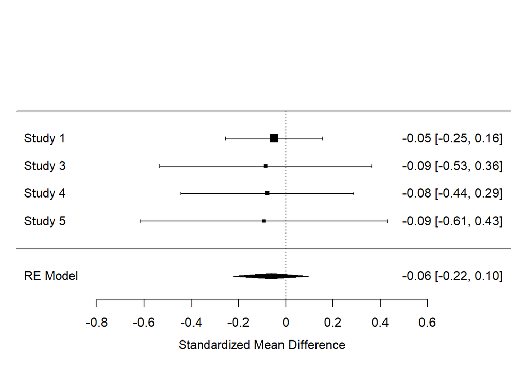

```r
meta_esc <- escalc(measure="SMD", m1i=m_male_i, m2i=m_female_i, sd1i=sd_male_i, sd2i=sd_female_i, n1i=n_male_i, n2i=n_female_i, data=df)
meta <- rma(meta_esc,method ='REML')
forest(meta)
```

```r
coef(summary(meta))$estimate
```

```
## [1] -0.06291721
```

```r
coef(summary(meta))$pval
```

```
## [1] 0.4361476
```

```r
#Compliance and other continous study variables
df <- mega_all_cen_std %>%
                group_by(study) %>%
                dplyr::summarise(r_age = cor(icountNA,Age, use="na.or.complete"),
                                 r_meanNA = cor(icountNA,imeanNA, use="na.or.complete"),
                                 r_sdNA = cor(icountNA,isdNA, use="na.or.complete"),
                                 r_mssdNA = cor(icountNA,iMSSDNA, use="na.or.complete"),
                                 r_autoNA = cor(icountNA,autocorNA, use="na.or.complete"),
                                 r_meanPA = cor(icountNA,imeanPA, use="na.or.complete"),
                                 r_sdPA = cor(icountNA,isdPA, use="na.or.complete"),
                                 r_mssdPA = cor(icountNA,iMSSDPA, use="na.or.complete"),
                                 r_autoPA = cor(icountNA,autocorPA, use="na.or.complete"),
                                 r_DepB = cor(icountNA,DepB, use="na.or.complete"),
                                 r_DepF = cor(icountNA,DepF, use="na.or.complete"))
df <-cbind(df,nstudy7)

#fit model
meta_esc_age <-escalc(measure ='COR', ri = df$r_age, ni = df$nstudy7)
meta_esc_meanNA <-escalc(measure ='COR', ri = df$r_meanNA, ni = df$nstudy7)
meta_esc_sdNA <-escalc(measure ='COR', ri = df$r_sdNA, ni = df$nstudy7)
meta_esc_mssdNA <-escalc(measure ='COR', ri = df$r_mssdNA, ni = df$nstudy7)
meta_esc_autoNA <-escalc(measure ='COR', ri = df$r_autoNA, ni = df$nstudy7)
meta_esc_meanPA <-escalc(measure ='COR', ri = df$r_meanPA, ni = df$nstudy7)
meta_esc_sdPA <-escalc(measure ='COR', ri = df$r_sdPA, ni = df$nstudy7)
meta_esc_mssdPA <-escalc(measure ='COR', ri = df$r_mssdPA, ni = df$nstudy7)
meta_esc_autoPA <-escalc(measure ='COR', ri = df$r_autoPA, ni = df$nstudy7)
meta_esc_DepB <-escalc(measure ='COR', ri = df$r_DepB, ni = df$nstudy7)
meta_esc_DepF <-escalc(measure ='COR', ri = df$r_DepF, ni = df$nstudy7)

meta_age <- rma(meta_esc_age,method ='REML')
meta_meanNA <- rma(meta_esc_meanNA,method ='REML')
meta_sdNA <- rma(meta_esc_sdNA,method ='REML')
meta_mssdNA <- rma(meta_esc_mssdNA,method ='REML')
meta_autoNA <- rma(meta_esc_autoNA,method ='REML')
meta_meanPA <- rma(meta_esc_meanPA,method ='REML')
meta_sdPA <- rma(meta_esc_sdPA,method ='REML')
meta_mssdPA <- rma(meta_esc_mssdPA,method ='REML')
meta_autoPA <- rma(meta_esc_autoPA,method ='REML')
meta_DepB <- rma(meta_esc_DepB,method ='REML')
meta_DepF <- rma(meta_esc_DepF,method ='REML')
#make dataframe
var_comp <- c("age","meanPA","sdPA","MSSDPA","autoPA",
              "meanNA","sdNA","MSSDNA","autoNA",
              "DepB", "DepF")

cor_comp <-round(c(coef(summary(meta_age))$estimate,
                coef(summary(meta_meanPA))$estimate,
                coef(summary(meta_sdPA))$estimate,
                coef(summary(meta_mssdPA))$estimate,
                coef(summary(meta_autoPA))$estimate,
                coef(summary(meta_meanNA))$estimate,
                coef(summary(meta_sdNA))$estimate,
                coef(summary(meta_mssdNA))$estimate,
                coef(summary(meta_autoNA))$estimate,
                coef(summary(meta_DepB))$estimate,
                coef(summary(meta_DepF))$estimate),digits = 2)

p_comp <-round(c(coef(summary(meta_age))$pval,
                coef(summary(meta_meanPA))$pval,
                coef(summary(meta_sdPA))$pval,
                coef(summary(meta_mssdPA))$pval,
                coef(summary(meta_autoPA))$pval,
                coef(summary(meta_meanNA))$pval,
                coef(summary(meta_sdNA))$pval,
                coef(summary(meta_mssdNA))$pval,
                coef(summary(meta_autoNA))$pval,
                coef(summary(meta_DepB))$pval,
                coef(summary(meta_DepF))$pval),digits = 3)


comp_study<-data.frame(var_comp,cor_comp,p_comp)

pander(comp_study,caption = "Correlation between compliance and study variables")
```

Correlation between compliance and study variables

| var_comp | cor_comp | p_comp |
| --- | --- | --- |
| age | -0.03 | 0.486 |
| meanPA | 0.04 | 0.525 |
| sdPA | -0.16 | 0 |
| MSSDPA | -0.16 | 0 |
| autoPA | 0.01 | 0.818 |
| meanNA | -0.12 | 0.002 |
| sdNA | -0.16 | 0 |
| MSSDNA | -0.15 | 0 |
| autoNA | -0.03 | 0.33 |
| DepB | -0.04 | 0.36 |
| DepF | -0.02 | 0.825 |

## 8.9 Histograms

### 8.9.1 RADAR

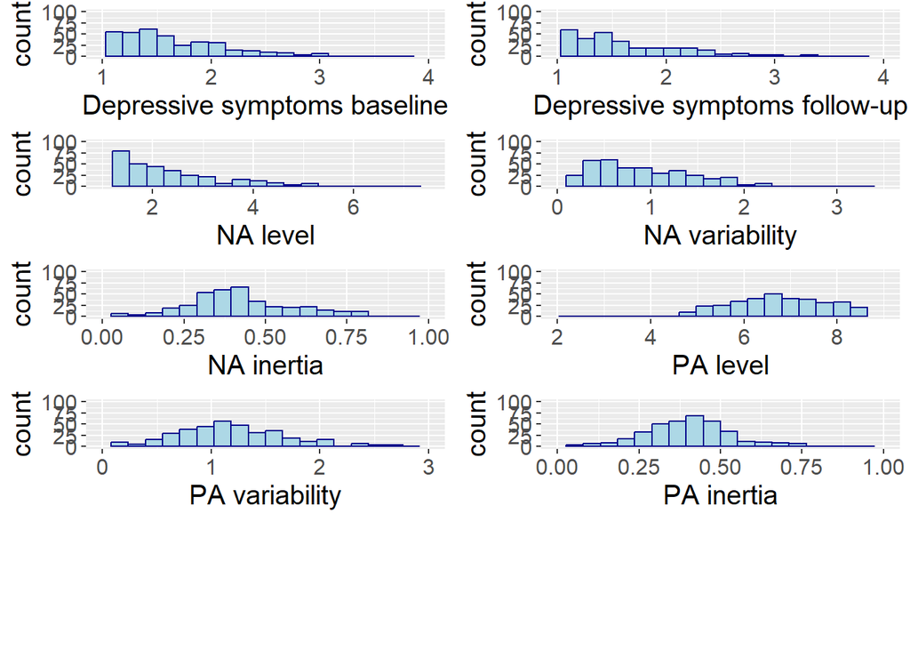

```r
####################### RADAR #######################

#### Depression ####

a<-ggplot(dataRADAR_finalW, aes(x=DepB))+
  geom_histogram(color="darkblue", fill="lightblue", bins=20)+
  xlab("Depressive symptoms baseline") +
  xlim(1, 4) +
  ylim(0, 100) +
  theme(text = element_text(size = 15))

b<-ggplot(dataRADAR_finalW, aes(x=DepF))+
  geom_histogram(color="darkblue", fill="lightblue", bins=20)+
  xlab("Depressive symptoms follow-up") +
  xlim(1, 4)+
  ylim(0, 100) +
  theme(text = element_text(size = 15))

#### Affective Dynamics ####
c<-ggplot(dataRADAR_finalW, aes(x=imeanNA))+
  geom_histogram(color="darkblue", fill="lightblue", bins=20)+
  xlab("NA level") +
  xlim(1, 7.5) +
  ylim(0, 100) +
  theme(text = element_text(size = 15))


d<-ggplot(dataRADAR_finalW, aes(x=isdNA))+
  geom_histogram(color="darkblue", fill="lightblue", bins=20)+
  xlab("NA variability") +
  xlim(0, 3.5) +
  ylim(0, 100) +
  theme(text = element_text(size = 15))


f<-ggplot(dataRADAR_finalW, aes(x=autocorNA))+
  geom_histogram(color="darkblue", fill="lightblue", bins=20)+
  xlab("NA inertia") +
  xlim(0, 1) +
  ylim(0, 100) +
  theme(text = element_text(size = 15))


g<-ggplot(dataRADAR_finalW, aes(x=imeanPA))+
  geom_histogram(color="darkblue", fill="lightblue", bins=20)+
  xlab("PA level") +
  xlim(2, 9) +
  ylim(0, 100) +
  theme(text = element_text(size = 15))


h<-ggplot(dataRADAR_finalW, aes(x=isdPA))+
  geom_histogram(color="darkblue", fill="lightblue", bins=20)+
  xlab("PA variability") +
  xlim(0, 3) +
  ylim(0, 100) +
  theme(text = element_text(size = 15))


j<-ggplot(dataRADAR_finalW, aes(x=autocorPA))+
  geom_histogram(color="darkblue", fill="lightblue", bins=20)+
  xlab("PA inertia") +
  xlim(0, 1) +
  ylim(0, 100) +
  theme(text = element_text(size = 15))


hist_graph_RADAR<-ggarrange(a,b,c,d,f,g,h,j,
                          ncol = 2, nrow = 5)
hist_graph_RADAR
```

```r
ggsave("../output/histRADARgraph.png", hist_graph_RADAR, width = 8, height = 12)
```

### 8.9.2 Swinging Moods

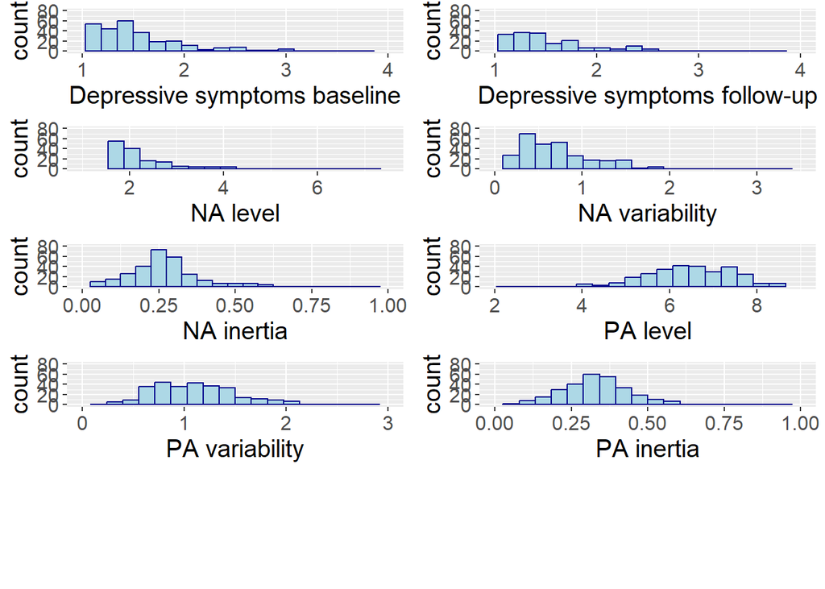

```r
#### Depression ####

a<-ggplot(dataSM_finalW, aes(x=DepB))+
  geom_histogram(color="darkblue", fill="lightblue", bins=20)+
  xlab("Depressive symptoms baseline") +
  xlim(1, 4) +
  ylim(0, 80) +
  theme(text = element_text(size = 15))

b<-ggplot(dataSM_finalW, aes(x=DepF))+
  geom_histogram(color="darkblue", fill="lightblue", bins=20)+
  xlab("Depressive symptoms follow-up") +
  xlim(1, 4) +
  ylim(0, 80) +
  theme(text = element_text(size = 15))


#### Affective Dynamics ####
c<-ggplot(dataSM_finalW, aes(x=imeanNA))+
  geom_histogram(color="darkblue", fill="lightblue", bins=20)+
  xlab("NA level") +
  xlim(1, 7.5) +
  ylim(0, 80) +
  theme(text = element_text(size = 15))


d<-ggplot(dataSM_finalW, aes(x=isdNA))+
  geom_histogram(color="darkblue", fill="lightblue", bins=20)+
  xlab("NA variability") +
  xlim(0, 3.5) +
  ylim(0, 80) +
  theme(text = element_text(size = 15))





f<-ggplot(dataSM_finalW, aes(x=autocorNA))+
  geom_histogram(color="darkblue", fill="lightblue", bins=21)+
  xlab("NA inertia") +
  xlim(0, 1) +
  ylim(0, 80) +
  theme(text = element_text(size = 15))


g<-ggplot(dataSM_finalW, aes(x=imeanPA))+
  geom_histogram(color="darkblue", fill="lightblue", bins=20)+
  xlab("PA level") +
  xlim(2, 9) +
  ylim(0, 80) +
  theme(text = element_text(size = 15))


h<-ggplot(dataSM_finalW, aes(x=isdPA))+
  geom_histogram(color="darkblue", fill="lightblue", bins=20)+
  xlab("PA variability") +
  xlim(0, 3) +
  ylim(0, 80) +
  theme(text = element_text(size = 15))





j<-ggplot(dataSM_finalW, aes(x=autocorPA))+
  geom_histogram(color="darkblue", fill="lightblue", bins=20)+
  xlab("PA inertia") +
  xlim(0, 1) +
  ylim(0, 80) +
  theme(text = element_text(size = 15))

hist_graph_SM<-ggarrange(a,b,c,d,f,g,h,j,
                          ncol = 2, nrow = 5)
hist_graph_SM
```

```r
ggsave("../output/histSMgraph.png", hist_graph_SM, width = 8, height = 12)
```

### 8.9.3 Mood in Emerging Adults

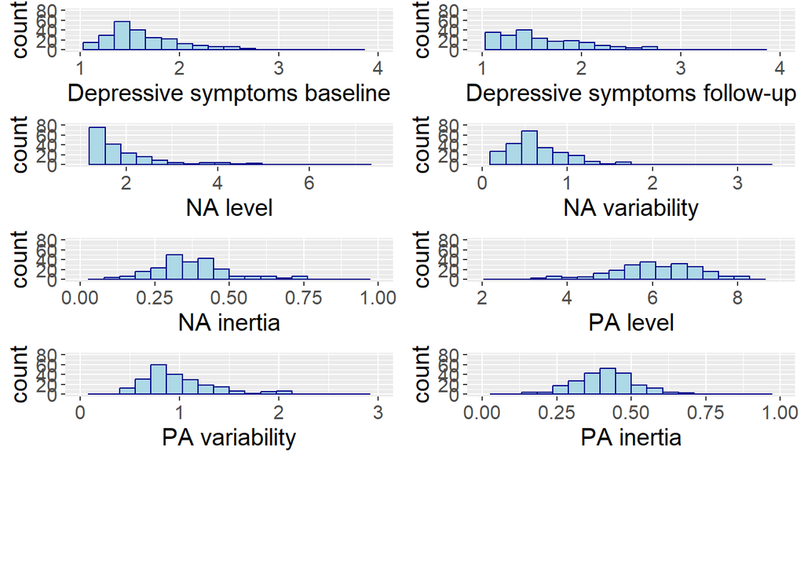

```r
#### Depression ####

a<-ggplot(dataMA_finalW, aes(x=DepB))+
  geom_histogram(color="darkblue", fill="lightblue", bins=20)+
  xlab("Depressive symptoms baseline") +
  xlim(1, 4) +
  ylim(0, 80) +
  theme(text = element_text(size = 15))

b<-ggplot(dataMA_finalW, aes(x=DepF))+
  geom_histogram(color="darkblue", fill="lightblue", bins=20)+
  xlab("Depressive symptoms follow-up") +
  xlim(1, 4)+
  ylim(0, 80) +
  theme(text = element_text(size = 15))


#### Affective Dynamics ####
c<-ggplot(dataMA_finalW, aes(x=imeanNA))+
  geom_histogram(color="darkblue", fill="lightblue", bins=20)+
  xlab("NA level") +
  xlim(1, 7.5) +
  ylim(0, 80) +
  theme(text = element_text(size = 15))


d<-ggplot(dataMA_finalW, aes(x=isdNA))+
  geom_histogram(color="darkblue", fill="lightblue", bins=20)+
  xlab("NA variability") +
  xlim(0, 3.5) +
  ylim(0, 80) +
  theme(text = element_text(size = 15))




f<-ggplot(dataMA_finalW, aes(x=autocorNA))+
  geom_histogram(color="darkblue", fill="lightblue", bins=20)+
  xlab("NA inertia") +
  xlim(0, 1) +
  ylim(0, 80) +
  theme(text = element_text(size = 15))


g<-ggplot(dataMA_finalW, aes(x=imeanPA))+
  geom_histogram(color="darkblue", fill="lightblue", bins=20)+
  xlab("PA level") +
  xlim(2, 9) +
  ylim(0, 80) +
  theme(text = element_text(size = 15))


h<-ggplot(dataMA_finalW, aes(x=isdPA))+
  geom_histogram(color="darkblue", fill="lightblue", bins=20)+
  xlab("PA variability") +
  xlim(0, 3) +
  ylim(0, 80) +
  theme(text = element_text(size = 15))



j<-ggplot(dataMA_finalW, aes(x=autocorPA))+
  geom_histogram(color="darkblue", fill="lightblue", bins=20)+
  xlab("PA inertia") +
  xlim(0, 1) +
  ylim(0, 80) +
  theme(text = element_text(size = 15))

hist_graph_MA<-ggarrange(a,b,c,d,f,g,h,j,
                          ncol = 2, nrow = 5)
hist_graph_MA
```

```r
ggsave("../output/histMAgraph.png", hist_graph_MA, width = 8, height = 12)
```

### 8.9.4 Emotions in Daily Life

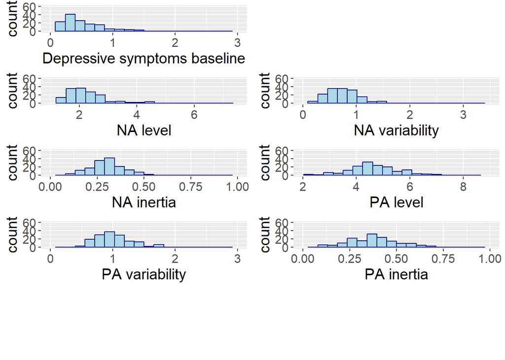

```r
#### Depression ####

a<-ggplot(dataED_finalW, aes(x=DepB))+
  geom_histogram(color="darkblue", fill="lightblue", bins=20)+
  xlab("Depressive symptoms baseline") +
  xlim(0, 3) +
  ylim(0, 60) +
  theme(text = element_text(size = 15))


#### Affective Dynamics ####
c<-ggplot(dataED_finalW, aes(x=imeanNA))+
  geom_histogram(color="darkblue", fill="lightblue", bins=20)+
  xlab("NA level") +
  xlim(1, 7.5) +
  ylim(0, 60) +
  theme(text = element_text(size = 15))


d<-ggplot(dataED_finalW, aes(x=isdNA))+
  geom_histogram(color="darkblue", fill="lightblue", bins=20)+
  xlab("NA variability") +
  xlim(0, 3.5) +
  ylim(0, 60) +
  theme(text = element_text(size = 15))


f<-ggplot(dataED_finalW, aes(x=autocorNA))+
  geom_histogram(color="darkblue", fill="lightblue", bins=20)+
  xlab("NA inertia") +
  xlim(0, 1) +
  ylim(0, 60) +
  theme(text = element_text(size = 15))


g<-ggplot(dataED_finalW, aes(x=imeanPA))+
  geom_histogram(color="darkblue", fill="lightblue", bins=20)+
  xlab("PA level") +
  xlim(2, 9) +
  ylim(0, 60) +
  theme(text = element_text(size = 15))


h<-ggplot(dataED_finalW, aes(x=isdPA))+
  geom_histogram(color="darkblue", fill="lightblue", bins=20)+
  xlab("PA variability") +
  xlim(0, 3) +
  ylim(0, 60) +
  theme(text = element_text(size = 15))



j<-ggplot(dataED_finalW, aes(x=autocorPA))+
  geom_histogram(color="darkblue", fill="lightblue", bins=20)+
  xlab("PA inertia") +
  xlim(0, 1) +
  ylim(0, 60) +
  theme(text = element_text(size = 15))

hist_graph_ED<-ggarrange(a,NULL,c,d,f,g,h,j,
                          ncol = 2, nrow = 5)
hist_graph_ED
```

```r
ggsave("../output/histEDgraph.png", hist_graph_ED, width = 8, height = 12)
```

### 8.9.5 Emotion Regulation in Action

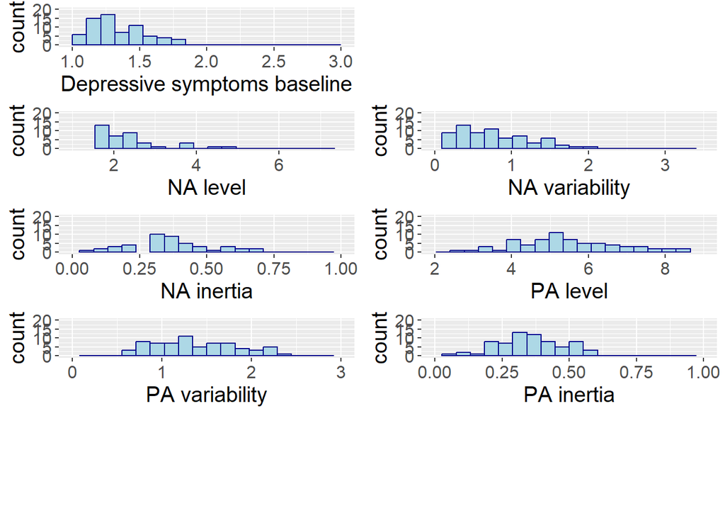

```r
#### Depression ####

a<-ggplot(dataEA_finalW, aes(x=DepB))+
  geom_histogram(color="darkblue", fill="lightblue", bins=20)+
  xlab("Depressive symptoms baseline") +
  xlim(1, 3) +
  ylim(0, 20) +
  theme(text = element_text(size = 15))


#### Affective Dynamics ####
c<-ggplot(dataEA_finalW, aes(x=imeanNA))+
  geom_histogram(color="darkblue", fill="lightblue", bins=20)+
  xlab("NA level") +
  xlim(1, 7.5) +
  ylim(0, 20) +
  theme(text = element_text(size = 15))


d<-ggplot(dataEA_finalW, aes(x=isdNA))+
  geom_histogram(color="darkblue", fill="lightblue", bins=20)+
  xlab("NA variability") +
  xlim(0, 3.5) +
  ylim(0, 20) +
  theme(text = element_text(size = 15))



f<-ggplot(dataEA_finalW, aes(x=autocorNA))+
  geom_histogram(color="darkblue", fill="lightblue", bins=20)+
  xlab("NA inertia") +
  xlim(0, 1) +
  ylim(0, 20) +
  theme(text = element_text(size = 15))


g<-ggplot(dataEA_finalW, aes(x=imeanPA))+
  geom_histogram(color="darkblue", fill="lightblue", bins=20)+
  xlab("PA level") +
  xlim(2, 9) +
  ylim(0, 20) +
  theme(text = element_text(size = 15))


h<-ggplot(dataEA_finalW, aes(x=isdPA))+
  geom_histogram(color="darkblue", fill="lightblue", bins=20)+
  xlab("PA variability") +
  xlim(0, 3) +
  ylim(0, 20) +
  theme(text = element_text(size = 15))



j<-ggplot(dataEA_finalW, aes(x=autocorPA))+
  geom_histogram(color="darkblue", fill="lightblue", bins=20)+
  xlab("PA inertia") +
  xlim(0, 1) +
  ylim(0, 20) +
  theme(text = element_text(size = 15))


hist_graph_EA<-ggarrange(a,NULL,c,d,f,g,h,j,
                          ncol = 2, nrow = 5)
hist_graph_EA
```

```r
ggsave("../output/histEAgraph.png", hist_graph_EA, width = 8, height = 12)
```

### 8.9.6 LASER

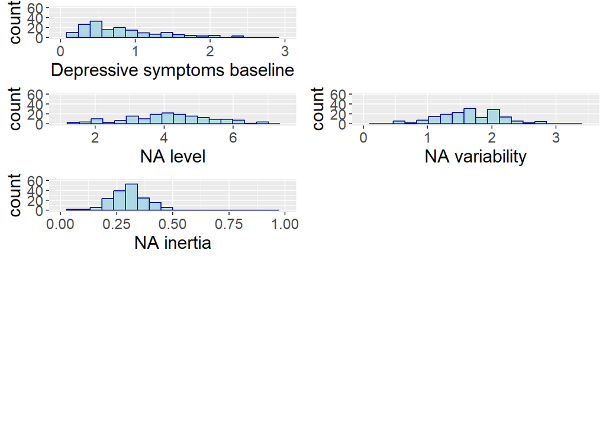

```r
#### Depression ####

a<-ggplot(dataLASER_finalW, aes(x=DepB))+
  geom_histogram(color="darkblue", fill="lightblue", bins=20)+
  xlab("Depressive symptoms baseline") +
  xlim(0, 3) +
  ylim(0, 60) +
  theme(text = element_text(size = 15))


#### Affective Dynamics ####
c<-ggplot(dataLASER_finalW, aes(x=imeanNA))+
  geom_histogram(color="darkblue", fill="lightblue", bins=20)+
  xlab("NA level") +
  xlim(1, 7.5) +
  ylim(0, 60) +
  theme(text = element_text(size = 15))


d<-ggplot(dataLASER_finalW, aes(x=isdNA))+
  geom_histogram(color="darkblue", fill="lightblue", bins=20)+
  xlab("NA variability") +
  xlim(0, 3.5) +
  ylim(0, 60) +
  theme(text = element_text(size = 15))



f<-ggplot(dataLASER_finalW, aes(x=autocorNA))+
  geom_histogram(color="darkblue", fill="lightblue", bins=20)+
  xlab("NA inertia") +
  xlim(0, 1) +
  ylim(0, 60) +
  theme(text = element_text(size = 15))


hist_graph_LASER<-ggarrange(a,NULL,c,d,f,
                          ncol = 2, nrow = 5)
hist_graph_LASER
```

```r
ggsave("../output/histLASERgraph.png", hist_graph_LASER, width = 8, height = 12)
```

### 8.9.7 YES

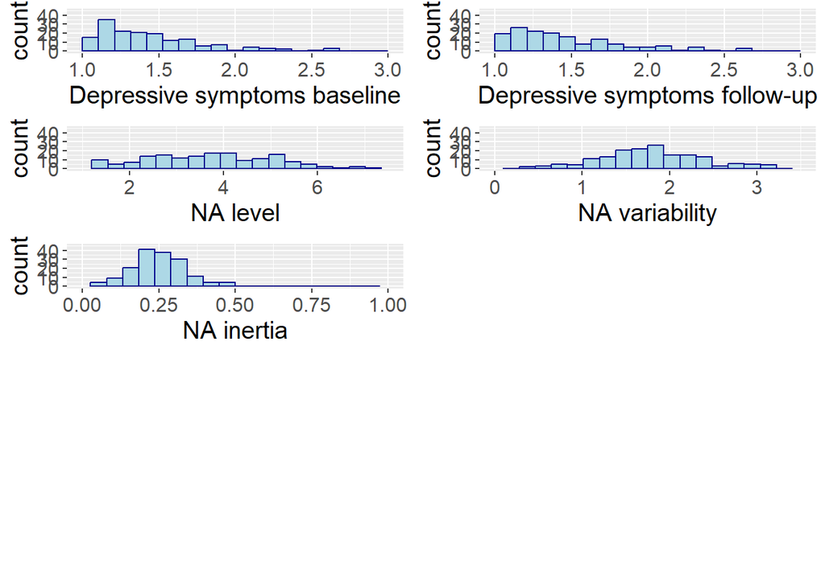

```r
#### Depression ####

a<-ggplot(dataYES_finalW, aes(x=DepB))+
  geom_histogram(color="darkblue", fill="lightblue", bins=20)+
  xlab("Depressive symptoms baseline") +
  xlim(1, 3) +
  ylim(0, 45) +
  theme(text = element_text(size = 15))

b<-ggplot(dataYES_finalW, aes(x=DepF))+
  geom_histogram(color="darkblue", fill="lightblue", bins=20)+
  xlab("Depressive symptoms follow-up") +
  xlim(1, 3)+
  ylim(0, 45) +
  theme(text = element_text(size = 15))


#### Affective Dynamics ####
c<-ggplot(dataYES_finalW, aes(x=imeanNA))+
  geom_histogram(color="darkblue", fill="lightblue", bins=20)+
  xlab("NA level") +
  xlim(1, 7.5) +
  ylim(0, 45) +
  theme(text = element_text(size = 15))


d<-ggplot(dataYES_finalW, aes(x=isdNA))+
  geom_histogram(color="darkblue", fill="lightblue", bins=20)+
  xlab("NA variability") +
  xlim(0, 3.5) +
  ylim(0, 45) +
  theme(text = element_text(size = 15))


f<-ggplot(dataYES_finalW, aes(x=autocorNA))+
  geom_histogram(color="darkblue", fill="lightblue", bins=20)+
  xlab("NA inertia") +
  xlim(0, 1) +
  ylim(0, 45) +
  theme(text = element_text(size = 15))


hist_graph_YES<-ggarrange(a,b,c,d,f,
                          ncol = 2, nrow = 5)
hist_graph_YES
```

```r
ggsave("../output/histYESgraph.png", hist_graph_YES, width = 8, height = 12)
```

## 8.10 Descriptives

On before standardized data.

For overall data, I did not ask for depression scores. These are on raw data and scales differ between studies. For those, only check out the scores per study.

```r
#overall
numeric_columns = c(4:11,14,15)
kable(psych::describe(mega_all_5[numeric_columns]),
      format='markdown',
      digits=2)
```

|  | vars | n | mean | sd | median | trimmed | mad | min | max | range | skew | kurtosis | se |
| --- | --- | --- | --- | --- | --- | --- | --- | --- | --- | --- | --- | --- | --- |
| imeanNA | 1 | 1107 | 1.94 | 0.85 | 1.72 | 1.80 | 0.69 | 1.01 | 5.04 | 4.03 | 1.42 | 1.73 | 0.03 |
| isdNA | 2 | 1107 | 0.76 | 0.43 | 0.66 | 0.71 | 0.38 | 0.04 | 2.18 | 2.14 | 0.84 | 0.23 | 0.01 |
| imeanPA | 3 | 1107 | 6.22 | 1.29 | 6.25 | 6.25 | 1.32 | 2.29 | 8.97 | 6.69 | -0.20 | -0.26 | 0.04 |
| isdPA | 4 | 1107 | 1.11 | 0.43 | 1.06 | 1.08 | 0.41 | 0.14 | 2.62 | 2.49 | 0.70 | 0.46 | 0.01 |
| relisdNA | 5 | 1107 | 0.36 | 0.14 | 0.33 | 0.35 | 0.12 | 0.13 | 1.00 | 0.87 | 1.22 | 2.44 | 0.00 |
| relisdPA | 6 | 1107 | 0.33 | 0.13 | 0.30 | 0.31 | 0.12 | 0.11 | 0.85 | 0.74 | 1.14 | 1.63 | 0.00 |
| iMSSDNA | 7 | 1107 | 0.85 | 0.47 | 0.76 | 0.80 | 0.44 | 0.05 | 2.54 | 2.49 | 0.96 | 0.82 | 0.01 |
| iMSSDPA | 8 | 1107 | 1.25 | 0.52 | 1.16 | 1.21 | 0.48 | 0.17 | 3.07 | 2.90 | 0.85 | 0.64 | 0.02 |
| Sex* | 9 | 1104 | 1.63 | 0.48 | 2.00 | 1.67 | 0.00 | 1.00 | 2.00 | 1.00 | -0.56 | -1.69 | 0.01 |
| Age | 10 | 1103 | 15.91 | 3.53 | 14.00 | 15.44 | 1.64 | 11.68 | 29.92 | 18.24 | 1.08 | 0.39 | 0.11 |

```r
#per study
numeric_columns = c(2:11,14,15)
describeBy(mega_all[numeric_columns],mega_all$study)
```

```
##
##  Descriptive statistics by group
## group: 1
##          vars   n  mean   sd median trimmed  mad   min   max range skew
## DepB        1 368  1.62 0.47   1.52    1.57 0.45  1.00  3.00  2.00 0.89
## DepF        2 334  1.58 0.53   1.43    1.51 0.48  1.00  3.29  2.29 1.09
## imeanNA     3 372  2.11 1.02   1.84    1.97 0.89  1.01  5.04  4.03 1.09
## isdNA       4 372  0.88 0.52   0.81    0.85 0.58  0.04  2.18  2.14 0.48
## imeanPA     5 372  6.92 1.10   6.89    6.92 1.29  4.70  8.97  4.28 0.06
## isdPA       6 372  1.20 0.50   1.15    1.17 0.48  0.14  2.62  2.49 0.44
## relisdNA    7 372  0.40 0.16   0.37    0.38 0.14  0.13  1.00  0.87 1.21
## relisdPA    8 372  0.39 0.16   0.38    0.38 0.15  0.15  0.85  0.71 0.82
## iMSSDNA     9 372  0.93 0.54   0.83    0.88 0.52  0.05  2.54  2.49 0.75
## iMSSDPA    10 372  1.32 0.59   1.21    1.27 0.53  0.17  3.05  2.88 0.68
## Sex*       11 372  1.43 0.50   1.00    1.42 0.00  1.00  2.00  1.00 0.27
## Age        12 372 13.01 0.44  13.01   12.99 0.41 11.68 15.56  3.88 0.87
##          kurtosis   se
## DepB         0.16 0.02
## DepF         0.62 0.03
## imeanNA      0.38 0.05
## isdNA       -0.66 0.03
## imeanPA     -0.86 0.06
## isdPA        0.19 0.03
## relisdNA     2.16 0.01
## relisdPA     0.39 0.01
## iMSSDNA      0.25 0.03
## iMSSDPA      0.31 0.03
## Sex*        -1.93 0.03
## Age          2.89 0.02
## ------------------------------------------------------------
## group: 2
##          vars   n  mean   sd median trimmed  mad   min   max range  skew
## DepB        1 278  1.52 0.41   1.42    1.46 0.33  1.00  2.96  1.96  1.28
## DepF        2 184  1.49 0.40   1.40    1.44 0.37  1.00  2.53  1.53  0.93
## imeanNA     3 283  1.73 0.65   1.54    1.62 0.50  1.03  4.10  3.07  1.53
## isdNA       4 283  0.69 0.39   0.61    0.65 0.37  0.09  1.79  1.70  0.85
## imeanPA     5 283  6.49 0.95   6.49    6.52 1.06  4.11  8.32  4.22 -0.25
## isdPA       6 283  1.10 0.39   1.06    1.07 0.43  0.37  2.07  1.70  0.44
## relisdNA    7 283  0.36 0.12   0.34    0.35 0.11  0.15  0.73  0.59  0.80
## relisdPA    8 283  0.31 0.10   0.30    0.30 0.11  0.11  0.57  0.46  0.40
```

[output cut: 142 more lines]

```
## Sex*       11 161  1.51 0.50   2.00    1.51 0.00  1.00  2.00  1.00 -0.04
## Age        12 164 13.93 0.88  14.00   13.95 1.48 12.00 15.00  3.00 -0.12
##          kurtosis   se
## DepB         1.65 0.03
## DepF         0.75 0.03
## imeanNA     -0.43 0.11
## isdNA       -0.20 0.05
## imeanPA        NA   NA
## isdPA          NA   NA
## relisdNA    -0.34 0.01
## relisdPA       NA   NA
## iMSSDNA     -0.08 0.07
## iMSSDPA        NA   NA
## Sex*        -2.01 0.04
## Age         -1.20 0.07
```

```r
#### comparing means of NA affective dynamics between studies ####
## meanNA ##
describeBy(mega_all$imeanNA ,mega_all$study)
```

```
##
##  Descriptive statistics by group
## group: 1
##    vars   n mean   sd median trimmed  mad  min  max range skew kurtosis   se
## X1    1 372 2.11 1.02   1.84    1.97 0.89 1.01 5.04  4.03 1.09     0.38 0.05
## ------------------------------------------------------------
## group: 2
##    vars   n mean   sd median trimmed mad  min max range skew kurtosis   se
## X1    1 283 1.73 0.65   1.54    1.62 0.5 1.03 4.1  3.07 1.53     2.24 0.04
## ------------------------------------------------------------
## group: 3
##    vars   n mean   sd median trimmed  mad  min  max range skew kurtosis   se
## X1    1 228 1.76 0.76   1.51    1.62 0.48 1.03 4.63   3.6 1.88     3.52 0.05
## ------------------------------------------------------------
## group: 4
##    vars   n mean  sd median trimmed  mad  min  max range skew kurtosis   se
## X1    1 156 2.21 0.7   2.07    2.13 0.56 1.04 4.52  3.48 1.23     1.84 0.06
## ------------------------------------------------------------
## group: 5
##    vars  n mean  sd median trimmed  mad  min  max range skew kurtosis  se
## X1    1 68 1.86 0.8   1.56    1.73 0.54 1.03 4.77  3.74 1.62     2.59 0.1
## ------------------------------------------------------------
## group: 6
##    vars   n mean   sd median trimmed  mad  min  max range skew kurtosis   se
## X1    1 173 4.15 1.25   4.11    4.17 1.27 1.37 6.74  5.37 -0.1    -0.55 0.09
## ------------------------------------------------------------
## group: 7
##    vars   n mean   sd median trimmed  mad  min  max range skew kurtosis   se
## X1    1 168 3.77 1.37   3.75    3.73 1.56 1.32 7.38  6.06 0.27    -0.43 0.11
```

```r
a1<-aov(mega_all$imeanNA ~ mega_all$study)
summary(a1)
```

```
##                  Df Sum Sq Mean Sq F value              Pr(>F)
## mega_all$study    6   1117  186.21   201.3 <0.0000000000000002 ***
## Residuals      1441   1333    0.93
## ---
## Signif. codes:  0 '***' 0.001 '**' 0.01 '*' 0.05 '.' 0.1 ' ' 1
```

```r
TukeyHSD(a1)
```

```
##   Tukey multiple comparisons of means
##     95% family-wise confidence level
##
## Fit: aov(formula = mega_all$imeanNA ~ mega_all$study)
##
## $`mega_all$study`
##            diff        lwr         upr     p adj
## 2-1 -0.38256277 -0.6065605 -0.15856504 0.0000107
## 3-1 -0.35158433 -0.5904339 -0.11273480 0.0002980
## 4-1  0.09960590 -0.1712703  0.37048210 0.9324029
## 5-1 -0.25040608 -0.6249373  0.12412518 0.4317698
## 6-1  2.03276930  1.7714380  2.29410057 0.0000000
## 7-1  1.65583152  1.3918592  1.91980386 0.0000000
## 3-2  0.03097844 -0.2217403  0.28369718 0.9998230
## 4-2  0.48216867  0.1989875  0.76534986 0.0000116
## 5-2  0.13215669 -0.2513682  0.51568157 0.9501274
## 6-2  2.41533207  2.1412669  2.68939721 0.0000000
## 7-2  2.03839429  1.7618096  2.31497893 0.0000000
## 4-3  0.45119023  0.1561213  0.74625921 0.0001392
## 5-3  0.10117825 -0.2912061  0.49356256 0.9884383
## 6-3  2.38435363  2.0980220  2.67068529 0.0000000
## 7-3  2.00741585  1.7186717  2.29615999 0.0000000
## 5-4 -0.35001198 -0.7626744  0.06265043 0.1583828
## 6-4  1.93316340  1.6196181  2.24670867 0.0000000
## 7-4  1.55622562  1.2404757  1.87197552 0.0000000
## 6-5  2.28317538  1.8767146  2.68963618 0.0000000
## 7-5  1.90623760  1.4980737  2.31440147 0.0000000
## 7-6 -0.37693778 -0.6845384 -0.06933720 0.0056787
```

```r
## SDNA ##
describeBy(mega_all$isdNA ,mega_all$study)
```

```
##
##  Descriptive statistics by group
## group: 1
##    vars   n mean   sd median trimmed  mad  min  max range skew kurtosis   se
## X1    1 372 0.88 0.52   0.81    0.85 0.58 0.04 2.18  2.14 0.48    -0.66 0.03
## ------------------------------------------------------------
## group: 2
##    vars   n mean   sd median trimmed  mad  min  max range skew kurtosis   se
## X1    1 283 0.69 0.39   0.61    0.65 0.37 0.09 1.79   1.7 0.85    -0.03 0.02
## ------------------------------------------------------------
## group: 3
##    vars   n mean   sd median trimmed  mad  min  max range skew kurtosis   se
## X1    1 228 0.64 0.32   0.58    0.61 0.29 0.13 1.69  1.55 0.89     0.75 0.02
## ------------------------------------------------------------
## group: 4
##    vars   n mean   sd median trimmed  mad  min  max range skew kurtosis   se
## X1    1 156 0.73 0.28    0.7    0.72 0.29 0.14 1.45  1.31 0.38    -0.22 0.02
## ------------------------------------------------------------
## group: 5
##    vars  n mean   sd median trimmed  mad  min  max range skew kurtosis   se
## X1    1 68 0.78 0.46   0.68    0.74 0.44 0.13 1.98  1.85 0.64    -0.46 0.06
## ------------------------------------------------------------
## group: 6
##    vars   n mean   sd median trimmed  mad  min  max range skew kurtosis   se
## X1    1 173 1.64 0.48   1.61    1.64 0.52 0.56 2.81  2.25 0.02    -0.23 0.04
## ------------------------------------------------------------
## group: 7
##    vars   n mean   sd median trimmed  mad  min max range skew kurtosis   se
## X1    1 168 1.79 0.59   1.77    1.78 0.55 0.39 3.1  2.71 0.08     -0.2 0.05
```

```r
a1<-aov(mega_all$isdNA ~ mega_all$study)
summary(a1)
```

```
##                  Df Sum Sq Mean Sq F value              Pr(>F)
## mega_all$study    6  252.5   42.09   208.9 <0.0000000000000002 ***
## Residuals      1441  290.3    0.20
## ---
## Signif. codes:  0 '***' 0.001 '**' 0.01 '*' 0.05 '.' 0.1 ' ' 1
```

```r
TukeyHSD(a1)
```

```
##   Tukey multiple comparisons of means
##     95% family-wise confidence level
##
## Fit: aov(formula = mega_all$isdNA ~ mega_all$study)
##
## $`mega_all$study`
##            diff          lwr         upr     p adj
## 2-1 -0.19232320 -0.296854657 -0.08779175 0.0000014
## 3-1 -0.24407006 -0.355532300 -0.13260782 0.0000000
## 4-1 -0.15517305 -0.281580947 -0.02876515 0.0055486
## 5-1 -0.10481486 -0.279594742  0.06996502 0.5682639
## 6-1  0.75972346  0.637769823  0.88167710 0.0000000
## 7-1  0.90675858  0.783572459  1.02994471 0.0000000
## 3-2 -0.05174686 -0.169681350  0.06618763 0.8541934
## 4-2  0.03715016 -0.095000026  0.16930034 0.9818530
## 5-2  0.08750834 -0.091468529  0.26648521 0.7779189
## 6-2  0.95204666  0.824150600  1.07994273 0.0000000
## 7-2  1.09908179  0.970009966  1.22815361 0.0000000
## 4-3  0.08889702 -0.048800757  0.22659479 0.4764863
## 5-3  0.13925520 -0.043856039  0.32236644 0.2719419
## 6-3  1.00379352  0.870173132  1.13741391 0.0000000
## 7-3  1.15082865  1.016082437  1.28557486 0.0000000
## 5-4  0.05035818 -0.142216095  0.24293246 0.9875503
## 6-4  0.91489651  0.768576529  1.06121648 0.0000000
## 7-4  1.06193163  0.914582834  1.20928043 0.0000000
## 6-5  0.86453832  0.674858104  1.05421854 0.0000000
## 7-5  1.01157345  0.821098468  1.20204842 0.0000000
## 7-6  0.14703512  0.003489313  0.29058094 0.0405755
```

```r
## rMSSDNA ##
describeBy(mega_all$iMSSDNA ,mega_all$study)
```

```
##
##  Descriptive statistics by group
## group: 1
##    vars   n mean   sd median trimmed  mad  min  max range skew kurtosis   se
## X1    1 372 0.93 0.54   0.83    0.88 0.52 0.05 2.54  2.49 0.75     0.25 0.03
## ------------------------------------------------------------
## group: 2
##    vars   n mean   sd median trimmed  mad  min  max range skew kurtosis   se
## X1    1 283 0.84 0.49   0.74    0.78 0.45 0.13 2.25  2.12 0.98     0.39 0.03
## ------------------------------------------------------------
## group: 3
##    vars   n mean   sd median trimmed  mad  min  max range skew kurtosis   se
## X1    1 228 0.69 0.35   0.63    0.66 0.33 0.12 1.75  1.63 0.82     0.35 0.02
## ------------------------------------------------------------
## group: 4
##    vars   n mean   sd median trimmed  mad  min  max range skew kurtosis   se
## X1    1 156 0.87 0.36   0.83    0.85 0.35 0.14 1.89  1.75 0.54     0.14 0.03
## ------------------------------------------------------------
## group: 5
##    vars  n mean   sd median trimmed  mad  min  max range skew kurtosis   se
## X1    1 68 0.89 0.52   0.77    0.83 0.45 0.19 2.43  2.24 1.06     0.87 0.06
## ------------------------------------------------------------
## group: 6
##    vars   n mean   sd median trimmed  mad  min  max range skew kurtosis   se
## X1    1 173 2.03 0.69   1.99    2.02 0.68 0.61 4.01   3.4 0.22     0.12 0.05
## ------------------------------------------------------------
## group: 7
##    vars   n mean   sd median trimmed  mad  min  max range skew kurtosis   se
## X1    1 168 2.24 0.87   2.15     2.2 0.79 0.54 4.46  3.92 0.44    -0.08 0.07
```

```r
a1<-aov(mega_all$iMSSDNA ~ mega_all$study)
summary(a1)
```

```
##                  Df Sum Sq Mean Sq F value              Pr(>F)
## mega_all$study    6  442.7   73.78   237.5 <0.0000000000000002 ***
## Residuals      1441  447.7    0.31
## ---
## Signif. codes:  0 '***' 0.001 '**' 0.01 '*' 0.05 '.' 0.1 ' ' 1
```

```r
TukeyHSD(a1)
```

```
##   Tukey multiple comparisons of means
##     95% family-wise confidence level
##
## Fit: aov(formula = mega_all$iMSSDNA ~ mega_all$study)
##
## $`mega_all$study`
##            diff          lwr          upr     p adj
## 2-1 -0.08693054 -0.216745191  0.042884110 0.4297297
## 3-1 -0.23564565 -0.374067443 -0.097223851 0.0000116
## 4-1 -0.05611929 -0.213101678  0.100863104 0.9406896
## 5-1 -0.03773026 -0.254784442  0.179323924 0.9986769
## 6-1  1.10167079  0.950220022  1.253121556 0.0000000
## 7-1  1.31059869  1.157617334  1.463580054 0.0000000
## 3-2 -0.14871511 -0.295174609 -0.002255603 0.0438357
## 4-2  0.03081125 -0.133302315  0.194924823 0.9979573
## 5-2  0.04920028 -0.173066024  0.271466588 0.9949113
## 6-2  1.18860133  1.029770831  1.347431829 0.0000000
## 7-2  1.39752923  1.237238596  1.557819874 0.0000000
## 4-3  0.17952636  0.008523396  0.350529324 0.0323573
## 5-3  0.19791539 -0.029485273  0.425316049 0.1361181
## 6-3  1.33731644  1.171377058  1.503255814 0.0000000
## 7-3  1.54624434  1.378906841  1.713581841 0.0000000
## 5-4  0.01838903 -0.220763514  0.257541570 0.9999887
## 6-4  1.15779008  0.976079441  1.339500711 0.0000000
## 7-4  1.36671798  1.183729685  1.549706277 0.0000000
## 6-5  1.13940105  0.903842559  1.374959538 0.0000000
## 7-5  1.34832895  1.111783474  1.584874432 0.0000000
## 7-6  0.20892790  0.030662428  0.387193382 0.0099659
```

```r
## ARNA ##
describeBy(mega_all$autocorNA ,mega_all$study)
```

```
##
##  Descriptive statistics by group
## group: 1
##    vars   n mean   sd median trimmed  mad  min  max range skew kurtosis   se
## X1    1 372 0.42 0.16    0.4    0.42 0.13 0.06 0.81  0.75 0.37    -0.06 0.01
## ------------------------------------------------------------
## group: 2
##    vars   n mean   sd median trimmed  mad  min max range skew kurtosis   se
## X1    1 283 0.27 0.11   0.26    0.26 0.08 0.03 0.6  0.57 0.63     1.08 0.01
## ------------------------------------------------------------
## group: 3
##    vars   n mean   sd median trimmed  mad  min  max range skew kurtosis   se
## X1    1 228 0.38 0.13   0.37    0.37 0.11 0.11 0.74  0.64 0.65     0.73 0.01
## ------------------------------------------------------------
## group: 4
##    vars   n mean   sd median trimmed  mad min  max range skew kurtosis   se
## X1    1 156  0.3 0.09   0.29     0.3 0.08 0.1 0.51  0.41 0.12    -0.21 0.01
## ------------------------------------------------------------
## group: 5
##    vars  n mean   sd median trimmed mad  min  max range skew kurtosis   se
## X1    1 68 0.33 0.13    0.3    0.32 0.1 0.07 0.69  0.62 0.75     0.39 0.02
## ------------------------------------------------------------
## group: 6
##    vars   n mean   sd median trimmed  mad  min  max range  skew kurtosis   se
## X1    1 173  0.3 0.08    0.3     0.3 0.07 0.07 0.48  0.42 -0.17     0.17 0.01
## ------------------------------------------------------------
## group: 7
##    vars   n mean   sd median trimmed  mad   min  max range  skew kurtosis   se
## X1    1 168 0.24 0.09   0.24    0.24 0.08 -0.01 0.47  0.49 -0.21     0.44 0.01
```

```r
a1<-aov(mega_all$autocorNA ~ mega_all$study)
summary(a1)
```

```
##                  Df Sum Sq Mean Sq F value              Pr(>F)
## mega_all$study    6  6.621  1.1036   74.84 <0.0000000000000002 ***
## Residuals      1441 21.248  0.0147
## ---
## Signif. codes:  0 '***' 0.001 '**' 0.01 '*' 0.05 '.' 0.1 ' ' 1
```

```r
TukeyHSD(a1)
```

```
##   Tukey multiple comparisons of means
##     95% family-wise confidence level
##
## Fit: aov(formula = mega_all$autocorNA ~ mega_all$study)
##
## $`mega_all$study`
##            diff          lwr          upr     p adj
## 2-1 -0.15846004 -0.186739955 -0.130180119 0.0000000
## 3-1 -0.04735841 -0.077513386 -0.017203443 0.0000788
## 4-1 -0.12386986 -0.158068231 -0.089671496 0.0000000
## 5-1 -0.09172990 -0.139014810 -0.044444984 0.0000003
## 6-1 -0.12256124 -0.155554555 -0.089567931 0.0000000
## 7-1 -0.18485530 -0.218182049 -0.151528551 0.0000000
## 3-2  0.11110162  0.079195649  0.143007595 0.0000000
## 4-2  0.03459017 -0.001161710  0.070342057 0.0654318
## 5-2  0.06673014  0.018309774  0.115150506 0.0009773
## 6-2  0.03589879  0.001297818  0.070499768 0.0361273
## 7-2 -0.02639526 -0.061314327  0.008523801 0.2790190
## 4-3 -0.07651145 -0.113764176 -0.039258721 0.0000000
## 5-3 -0.04437148 -0.093910360  0.005167395 0.1136367
## 6-3 -0.07520283 -0.111352462 -0.039053196 0.0000000
## 7-3 -0.13749689 -0.173951097 -0.101042674 0.0000000
## 5-4  0.03213997 -0.019959040  0.084238972 0.5336655
## 6-4  0.00130862 -0.038276757  0.040893997 0.9999999
## 7-4 -0.06098544 -0.100849150 -0.021121723 0.0001378
## 6-5 -0.03083135 -0.082147394  0.020484701 0.5660180
## 7-5 -0.09312540 -0.144656464 -0.041594342 0.0000023
## 7-6 -0.06229406 -0.101128911 -0.023459202 0.0000491
```

## 8.11 Correlations

### 8.11.1 Overall

```r
##################### dataframes with sample size for metafor #####################
#Note: Not all studies have all variables available (e.g., PA or Depression FU data)

nstudy7 <- c(n_fin_RADAR,n_fin_SM,n_fin_MA,n_fin_ED,n_fin_EA,n_fin_LASER,n_fin_YES)

##################### all 7 studies #####################
df <- mega_all_cen_std %>%
                group_by(study) %>%
                dplyr::summarise(r_PAmeanPAsd = cor(imeanPA,isdPA, use="na.or.complete"),
                                 r_PAmeanPAmssd = cor(imeanPA,iMSSDPA, use="na.or.complete"),
                                 r_PAmeanPAauto = cor(imeanPA,autocorPA, use="na.or.complete"),
                                 r_PAmeanNAmean = cor(imeanPA,imeanNA, use="na.or.complete"),
                                 r_PAmeanNAsd = cor(imeanPA,isdNA, use="na.or.complete"),
                                 r_PAmeanNAmssd = cor(imeanPA,iMSSDNA, use="na.or.complete"),
                                 r_PAmeanNAauto = cor(imeanPA,autocorNA, use="na.or.complete"),
                                 r_PAmeanDepB = cor(imeanPA,DepB, use="na.or.complete"),
                                 r_PAmeanDepF = cor(imeanPA,DepF, use="na.or.complete"),

                                 r_PAsdPAmssd = cor(isdPA,iMSSDPA, use="na.or.complete"),
                                 r_PAsdPAauto = cor(isdPA,autocorPA, use="na.or.complete"),
                                 r_PAsdNAmean = cor(isdPA,imeanNA, use="na.or.complete"),
                                 r_PAsdNAsd = cor(isdPA,isdNA, use="na.or.complete"),
                                 r_PAsdNAmssd = cor(isdPA,iMSSDNA, use="na.or.complete"),
                                 r_PAsdNAauto = cor(isdPA,autocorNA, use="na.or.complete"),
                                 r_PAsdDepB = cor(isdPA,DepB, use="na.or.complete"),
                                 r_PAsdDepF = cor(isdPA,DepF, use="na.or.complete"),

                                 r_PAmssdPAauto = cor(iMSSDPA,autocorPA, use="na.or.complete"),
                                 r_PAmssdNAmean = cor(iMSSDPA,imeanNA, use="na.or.complete"),
                                 r_PAmssdNAsd = cor(iMSSDPA,isdNA, use="na.or.complete"),
                                 r_PAmssdNAmssd = cor(iMSSDPA,iMSSDNA, use="na.or.complete"),
                                 r_PAmssdNAauto = cor(iMSSDPA,autocorNA, use="na.or.complete"),
                                 r_PAmssdDepB = cor(iMSSDPA,DepB, use="na.or.complete"),
                                 r_PAmssdDepF = cor(iMSSDPA,DepF, use="na.or.complete"),

                                 r_PAautoNAmean = cor(autocorPA,imeanNA, use="na.or.complete"),
                                 r_PAautoNAsd = cor(autocorPA,isdNA, use="na.or.complete"),
                                 r_PAautoNAmssd = cor(autocorPA,iMSSDNA, use="na.or.complete"),
                                 r_PAautoNAauto = cor(autocorPA,autocorNA, use="na.or.complete"),
                                 r_PAautoDepB = cor(autocorPA,DepB, use="na.or.complete"),
                                 r_PAautoDepF = cor(autocorPA,DepF, use="na.or.complete"),

                                 r_NAmeanNAsd = cor(imeanNA,isdNA, use="na.or.complete"),
                                 r_NAmeanNAmssd = cor(imeanNA,iMSSDNA, use="na.or.complete"),
                                 r_NAmeanNAauto = cor(imeanNA,autocorNA, use="na.or.complete"),
                                 r_NAmeanDepB = cor(imeanNA,DepB, use="na.or.complete"),
                                 r_NAmeanDepF = cor(imeanNA,DepF, use="na.or.complete"),

                                 r_NAsdNAmssd = cor(isdNA,iMSSDNA, use="na.or.complete"),
                                 r_NAsdNAauto = cor(isdNA,autocorNA, use="na.or.complete"),
                                 r_NAsdDepB = cor(isdNA,DepB, use="na.or.complete"),
                                 r_NAsdDepF = cor(isdNA,DepF, use="na.or.complete"),

                                 r_NAmssdNAauto = cor(iMSSDNA,autocorNA, use="na.or.complete"),
                                 r_NAmssdDepB = cor(iMSSDNA,DepB, use="na.or.complete"),
                                 r_NAmssdDepF = cor(iMSSDNA,DepF, use="na.or.complete"),

                                 r_NAautoDepB = cor(autocorNA,DepB, use="na.or.complete"),
                                 r_NAautoDepF = cor(autocorNA,DepF, use="na.or.complete"),

                                 r_DepBDepF = cor(DepB,DepF, use="na.or.complete"))
df <-cbind(df,nstudy7)
df
```

```
##   study r_PAmeanPAsd r_PAmeanPAmssd r_PAmeanPAauto r_PAmeanNAmean r_PAmeanNAsd
## 1     1  -0.47803457     -0.4262636    0.057880281     -0.6691317 -0.524330131
## 2     2  -0.47230079     -0.4349742   -0.002263051     -0.4938628 -0.476320427
## 3     3  -0.44796772     -0.4159450    0.144520755     -0.4942969 -0.471418532
## 4     4   0.09314443      0.1087231   -0.112695386     -0.1596127 -0.006253716
## 5     5  -0.45009725     -0.4399765    0.404808744     -0.3611208 -0.259197301
## 6     6           NA             NA             NA             NA           NA
## 7     7           NA             NA             NA             NA           NA
##   r_PAmeanNAmssd r_PAmeanNAauto r_PAmeanDepB r_PAmeanDepF r_PAsdPAmssd
## 1    -0.46309587     -0.2757252   -0.3340276   -0.4278761    0.8616735
## 2    -0.44622708     -0.1250002   -0.3696077   -0.3593035    0.8680029
## 3    -0.44944195     -0.2409739   -0.4377336   -0.3889613    0.8403506
## 4     0.02687398     -0.1156138   -0.2991408           NA    0.8302979
## 5    -0.27602587     -0.1511484   -0.2881203           NA    0.8539153
## 6             NA             NA           NA           NA           NA
```

[output cut: 57 more lines]

```r
#fit model
meta_esc_PAmeanPAsd <-escalc(measure ='COR', ri = df$r_PAmeanPAsd, ni = df$nstudy7)
meta_esc_PAmeanPAmssd <-escalc(measure ='COR', ri = df$r_PAmeanPAmssd, ni = df$nstudy7)
meta_esc_PAmeanPAauto <-escalc(measure ='COR', ri = df$r_PAmeanPAauto, ni = df$nstudy7)
meta_esc_PAmeanNAmean <-escalc(measure ='COR', ri = df$r_PAmeanNAmean, ni = df$nstudy7)
meta_esc_PAmeanNAsd <-escalc(measure ='COR', ri = df$r_PAmeanNAsd, ni = df$nstudy7)
meta_esc_PAmeanNAmssd <-escalc(measure ='COR', ri = df$r_PAmeanNAmssd, ni = df$nstudy7)
meta_esc_PAmeanNAauto <-escalc(measure ='COR', ri = df$r_PAmeanNAauto, ni = df$nstudy7)
meta_esc_PAmeanDepB <-escalc(measure ='COR', ri = df$r_PAmeanDepB, ni = df$nstudy7)
meta_esc_PAmeanDepF <-escalc(measure ='COR', ri = df$r_PAmeanDepF, ni = df$nstudy7)

meta_esc_PAsdPAmssd <-escalc(measure ='COR', ri = df$r_PAsdPAmssd, ni = df$nstudy7)
meta_esc_PAsdPAauto <-escalc(measure ='COR', ri = df$r_PAsdPAauto, ni = df$nstudy7)
meta_esc_PAsdNAmean <-escalc(measure ='COR', ri = df$r_PAsdNAmean, ni = df$nstudy7)
meta_esc_PAsdNAsd <-escalc(measure ='COR', ri = df$r_PAsdNAsd, ni = df$nstudy7)
meta_esc_PAsdNAmssd <-escalc(measure ='COR', ri = df$r_PAsdNAmssd, ni = df$nstudy7)
meta_esc_PAsdNAauto <-escalc(measure ='COR', ri = df$r_PAsdNAauto, ni = df$nstudy7)
meta_esc_PAsdDepB <-escalc(measure ='COR', ri = df$r_PAsdDepB, ni = df$nstudy7)
meta_esc_PAsdDepF <-escalc(measure ='COR', ri = df$r_PAsdDepF, ni = df$nstudy7)

meta_esc_PAmssdPAauto <-escalc(measure ='COR', ri = df$r_PAmssdPAauto, ni = df$nstudy7)
meta_esc_PAmssdNAmean <-escalc(measure ='COR', ri = df$r_PAmssdNAmean, ni = df$nstudy7)
meta_esc_PAmssdNAsd <-escalc(measure ='COR', ri = df$r_PAmssdNAsd, ni = df$nstudy7)
meta_esc_PAmssdNAmssd <-escalc(measure ='COR', ri = df$r_PAmssdNAmssd, ni = df$nstudy7)
meta_esc_PAmssdNAauto <-escalc(measure ='COR', ri = df$r_PAmssdNAauto, ni = df$nstudy7)
meta_esc_PAmssdDepB <-escalc(measure ='COR', ri = df$r_PAmssdDepB, ni = df$nstudy7)
meta_esc_PAmssdDepF <-escalc(measure ='COR', ri = df$r_PAmssdDepF, ni = df$nstudy7)

meta_esc_PAautoNAmean <-escalc(measure ='COR', ri = df$r_PAautoNAmean, ni = df$nstudy7)
meta_esc_PAautoNAsd <-escalc(measure ='COR', ri = df$r_PAautoNAsd, ni = df$nstudy7)
meta_esc_PAautoNAmssd <-escalc(measure ='COR', ri = df$r_PAautoNAmssd, ni = df$nstudy7)
meta_esc_PAautoNAauto <-escalc(measure ='COR', ri = df$r_PAautoNAauto, ni = df$nstudy7)
meta_esc_PAautoDepB <-escalc(measure ='COR', ri = df$r_PAautoDepB, ni = df$nstudy7)
meta_esc_PAautoDepF <-escalc(measure ='COR', ri = df$r_PAautoDepF, ni = df$nstudy7)


meta_esc_NAmeanNAsd <-escalc(measure ='COR', ri = df$r_NAmeanNAsd, ni = df$nstudy7)
meta_esc_NAmeanNAmssd <-escalc(measure ='COR', ri = df$r_NAmeanNAmssd, ni = df$nstudy7)
meta_esc_NAmeanNAauto <-escalc(measure ='COR', ri = df$r_NAmeanNAauto, ni = df$nstudy7)
meta_esc_NAmeanDepB <-escalc(measure ='COR', ri = df$r_NAmeanDepB, ni = df$nstudy7)
meta_esc_NAmeanDepF <-escalc(measure ='COR', ri = df$r_NAmeanDepF, ni = df$nstudy7)

meta_esc_NAsdNAmssd <-escalc(measure ='COR', ri = df$r_NAsdNAmssd, ni = df$nstudy7)
meta_esc_NAsdNAauto <-escalc(measure ='COR', ri = df$r_NAsdNAauto, ni = df$nstudy7)
meta_esc_NAsdDepB <-escalc(measure ='COR', ri = df$r_NAsdDepB, ni = df$nstudy7)
meta_esc_NAsdDepF <-escalc(measure ='COR', ri = df$r_NAsdDepF, ni = df$nstudy7)

meta_esc_NAmssdNAauto <-escalc(measure ='COR', ri = df$r_NAmssdNAauto, ni = df$nstudy7)
meta_esc_NAmssdDepB <-escalc(measure ='COR', ri = df$r_NAmssdDepB, ni = df$nstudy7)
meta_esc_NAmssdDepF <-escalc(measure ='COR', ri = df$r_NAmssdDepF, ni = df$nstudy7)

meta_esc_NAautoDepB <-escalc(measure ='COR', ri = df$r_NAautoDepB, ni = df$nstudy7)
meta_esc_NAautoDepF <-escalc(measure ='COR', ri = df$r_NAautoDepF, ni = df$nstudy7)

meta_esc_DepBDepF <-escalc(measure ='COR', ri = df$r_DepBDepF, ni = df$nstudy7)



meta_PAmeanPAsd <-rma(meta_esc_PAmeanPAsd,method ='REML')
meta_PAmeanPAmssd <-rma(meta_esc_PAmeanPAmssd,method ='REML')
meta_PAmeanPAauto<-rma(meta_esc_PAmeanPAauto,method ='REML')
meta_PAmeanNAmean<-rma(meta_esc_PAmeanNAmean,method ='REML')
meta_PAmeanNAsd <-rma(meta_esc_PAmeanNAsd,method ='REML')
meta_PAmeanNAmssd <-rma(meta_esc_PAmeanNAmssd,method ='REML')
meta_PAmeanNAauto <-rma(meta_esc_PAmeanNAauto,method ='REML')
meta_PAmeanDepB <-rma(meta_esc_PAmeanDepB,method ='REML')
meta_PAmeanDepF <-rma(meta_esc_PAmeanDepF,method ='REML')
meta_PAsdPAmssd <-rma(meta_esc_PAsdPAmssd,method ='REML')
meta_PAsdPAauto <-rma(meta_esc_PAsdPAauto,method ='REML')
meta_PAsdNAmean <-rma(meta_esc_PAsdNAmean,method ='REML')
meta_PAsdNAsd <-rma(meta_esc_PAsdNAsd,method ='REML')
meta_PAsdNAmssd <-rma(meta_esc_PAsdNAmssd,method ='REML')
meta_PAsdNAauto <-rma(meta_esc_PAsdNAauto,method ='REML')
meta_PAsdDepB <-rma(meta_esc_PAsdDepB,method ='REML')
meta_PAsdDepF <-rma(meta_esc_PAsdDepF,method ='REML')
meta_PAmssdPAauto <-rma(meta_esc_PAmssdPAauto,method ='REML')
meta_PAmssdNAmean <-rma(meta_esc_PAmssdNAmean,method ='REML')
meta_PAmssdNAsd <-rma(meta_esc_PAmssdNAsd,method ='REML')
meta_PAmssdNAmssd <-rma(meta_esc_PAmssdNAmssd,method ='REML')
meta_PAmssdNAauto <-rma(meta_esc_PAmssdNAauto,method ='REML')
meta_PAmssdDepB <-rma(meta_esc_PAmssdDepB,method ='REML')
meta_PAmssdDepF <-rma(meta_esc_PAmssdDepF,method ='REML')
meta_PAautoNAmean <-rma(meta_esc_PAautoNAmean,method ='REML')
meta_PAautoNAsd <-rma(meta_esc_PAautoNAsd,method ='REML')
meta_PAautoNAmssd <-rma(meta_esc_PAautoNAmssd,method ='REML')
meta_PAautoNAauto <-rma(meta_esc_PAautoNAauto,method ='REML')
meta_PAautoDepB <-rma(meta_esc_PAautoDepB,method ='REML')
meta_PAautoDepF <-rma(meta_esc_PAautoDepF,method ='REML')
meta_NAmeanNAsd <-rma(meta_esc_NAmeanNAsd,method ='REML')
meta_NAmeanNAmssd <-rma(meta_esc_NAmeanNAmssd,method ='REML')
meta_NAmeanNAauto <-rma(meta_esc_NAmeanNAauto,method ='REML')
meta_NAmeanDepB <-rma(meta_esc_NAmeanDepB,method ='REML')
meta_NAmeanDepF <-rma(meta_esc_NAmeanDepF,method ='REML')
meta_NAsdNAmssd <-rma(meta_esc_NAsdNAmssd,method ='REML')
meta_NAsdNAauto <-rma(meta_esc_NAsdNAauto,method ='REML')
meta_NAsdDepB <-rma(meta_esc_NAsdDepB,method ='REML')
meta_NAsdDepF <-rma(meta_esc_NAsdDepF,method ='REML')
meta_NAmssdNAauto <-rma(meta_esc_NAmssdNAauto,method ='REML')
meta_NAmssdDepB <-rma(meta_esc_NAmssdDepB,method ='REML')
meta_NAmssdDepF <-rma(meta_esc_NAmssdDepF,method ='REML')
meta_NAautoDepB <-rma(meta_esc_NAautoDepB,method ='REML')
meta_NAautoDepF <-rma(meta_esc_NAautoDepF,method ='REML')
meta_DepBDepF <-rma(meta_esc_DepBDepF,method ='REML')
#make dataframe
var_corr <- c("r_PAmeanPAsd","r_PAmeanPAmssd","r_PAmeanPAauto",
              "r_PAmeanNAmean","r_PAmeanNAsd","r_PAmeanNAmssd","r_PAmeanNAauto",
              "r_PAmeanDepB","r_PAmeanDepF",
```

```r
              "r_PAsdPAmssd","r_PAsdPAauto",
              "r_PAsdNAmean","r_PAsdNAsd","r_PAsdNAmssd","r_PAsdNAauto",
              "r_PAsdDepB","r_PAsdDepF",

              "r_PAmssdPAauto",
              "r_PAmssdNAmean","r_PAmssdNAsd","r_PAmssdNAmssd","r_PAmssdNAauto",
              "r_PAmssdDepB","r_PAmssdDepF",

              "r_PAautoNAmean","r_PAautoNAsd","r_PAautoNAmssd","r_PAautoNAauto",
              "r_PAautoDepB","r_PAautoDepF",

              "r_NAmeanNAsd","r_NAmeanNAmssd","r_NAmeanNAauto",
              "r_NAmeanDepB","r_NAmeanDepF",

              "r_NAsdNAmssd","r_NAsdNAauto",
              "r_NAsdDepB","r_NAsdDepF",

              "r_NAmssdNAauto",
              "r_NAmssdDepB","r_NAmssdDepF",

              "r_NAautoDepB","r_NAautoDepF",

              "r_PAmeanDepF")

cor_corr <-round(c(coef(summary(meta_PAmeanPAsd))$estimate,
                coef(summary(meta_PAmeanPAmssd))$estimate,
                coef(summary(meta_PAmeanPAauto))$estimate,
                coef(summary(meta_PAmeanNAmean))$estimate,
                coef(summary(meta_PAmeanNAsd))$estimate,
                coef(summary(meta_PAmeanNAmssd))$estimate,
                coef(summary(meta_PAmeanNAauto))$estimate,
                coef(summary(meta_PAmeanDepB))$estimate,
                coef(summary(meta_PAmeanDepF))$estimate,

                coef(summary(meta_PAsdPAmssd))$estimate,
                coef(summary(meta_PAsdPAauto))$estimate,
                coef(summary(meta_PAsdNAmean))$estimate,
                coef(summary(meta_PAsdNAsd))$estimate,
                coef(summary(meta_PAsdNAmssd))$estimate,
                coef(summary(meta_PAsdNAauto))$estimate,
                coef(summary(meta_PAsdDepB))$estimate,
                coef(summary(meta_PAsdDepF))$estimate,

                coef(summary(meta_PAmssdPAauto))$estimate,
                coef(summary(meta_PAmssdNAmean))$estimate,
                coef(summary(meta_PAmssdNAsd))$estimate,
                coef(summary(meta_PAmssdNAmssd))$estimate,
                coef(summary(meta_PAmssdNAauto))$estimate,
                coef(summary(meta_PAmssdDepB))$estimate,
                coef(summary(meta_PAmssdDepF))$estimate,

                coef(summary(meta_PAautoNAmean))$estimate,
                coef(summary(meta_PAautoNAsd))$estimate,
                coef(summary(meta_PAautoNAmssd))$estimate,
                coef(summary(meta_PAautoNAauto))$estimate,
                coef(summary(meta_PAautoDepB))$estimate,
                coef(summary(meta_PAautoDepF))$estimate,

                coef(summary(meta_NAmeanNAsd))$estimate,
                coef(summary(meta_NAmeanNAmssd))$estimate,
                coef(summary(meta_NAmeanNAauto))$estimate,
                coef(summary(meta_NAmeanDepB))$estimate,
                coef(summary(meta_NAmeanDepF))$estimate,

                coef(summary(meta_NAsdNAmssd))$estimate,
                coef(summary(meta_NAsdNAauto))$estimate,
                coef(summary(meta_NAsdDepB))$estimate,
                coef(summary(meta_NAsdDepF))$estimate,

                coef(summary(meta_NAmssdNAauto))$estimate,
                coef(summary(meta_NAmssdDepB))$estimate,
                coef(summary(meta_NAmssdDepF))$estimate,

                coef(summary(meta_NAautoDepB))$estimate,
                coef(summary(meta_NAautoDepF))$estimate,

                coef(summary(meta_DepBDepF))$estimate),digits = 2)

p_corr <-round(c(coef(summary(meta_PAmeanPAsd))$pval,
                coef(summary(meta_PAmeanPAmssd))$pval,
                coef(summary(meta_PAmeanPAauto))$pval,
                coef(summary(meta_PAmeanNAmean))$pval,
                coef(summary(meta_PAmeanNAsd))$pval,
                coef(summary(meta_PAmeanNAmssd))$pval,
                coef(summary(meta_PAmeanNAauto))$pval,
                coef(summary(meta_PAmeanDepB))$pval,
                coef(summary(meta_PAmeanDepF))$pval,

                coef(summary(meta_PAsdPAmssd))$pval,
                coef(summary(meta_PAsdPAauto))$pval,
                coef(summary(meta_PAsdNAmean))$pval,
                coef(summary(meta_PAsdNAsd))$pval,
                coef(summary(meta_PAsdNAmssd))$pval,
                coef(summary(meta_PAsdNAauto))$pval,
                coef(summary(meta_PAsdDepB))$pval,
                coef(summary(meta_PAsdDepF))$pval,

                coef(summary(meta_PAmssdPAauto))$pval,
                coef(summary(meta_PAmssdNAmean))$pval,
                coef(summary(meta_PAmssdNAsd))$pval,
                coef(summary(meta_PAmssdNAmssd))$pval,
                coef(summary(meta_PAmssdNAauto))$pval,
                coef(summary(meta_PAmssdDepB))$pval,
                coef(summary(meta_PAmssdDepF))$pval,

                coef(summary(meta_PAautoNAmean))$pval,
                coef(summary(meta_PAautoNAsd))$pval,
                coef(summary(meta_PAautoNAmssd))$pval,
                coef(summary(meta_PAautoNAauto))$pval,
                coef(summary(meta_PAautoDepB))$pval,
                coef(summary(meta_PAautoDepF))$pval,

                coef(summary(meta_NAmeanNAsd))$pval,
                coef(summary(meta_NAmeanNAmssd))$pval,
                coef(summary(meta_NAmeanNAauto))$pval,
                coef(summary(meta_NAmeanDepB))$pval,
                coef(summary(meta_NAmeanDepF))$pval,

                coef(summary(meta_NAsdNAmssd))$pval,
                coef(summary(meta_NAsdNAauto))$pval,
                coef(summary(meta_NAsdDepB))$pval,
                coef(summary(meta_NAsdDepF))$pval,

                coef(summary(meta_NAmssdNAauto))$pval,
                coef(summary(meta_NAmssdDepB))$pval,
                coef(summary(meta_NAmssdDepF))$pval,

                coef(summary(meta_NAautoDepB))$pval,
                coef(summary(meta_NAautoDepF))$pval,

                coef(summary(meta_DepBDepF))$pval),digits = 3)



comp_study<-data.frame(var_corr,cor_corr,p_corr)

pander(comp_study,caption = "Correlation between study variables whole sample")
```

Correlation between study variables whole sample

| var_corr | cor_corr | p_corr |
| --- | --- | --- |
| r_PAmeanPAsd | -0.36 | 0.001 |
| r_PAmeanPAmssd | -0.32 | 0.002 |
| r_PAmeanPAauto | 0.09 | 0.258 |
| r_PAmeanNAmean | -0.45 | 0 |
| r_PAmeanNAsd | -0.36 | 0 |
| r_PAmeanNAmssd | -0.33 | 0 |
| r_PAmeanNAauto | -0.2 | 0 |
| r_PAmeanDepB | -0.36 | 0 |
| r_PAmeanDepF | -0.4 | 0 |
| r_PAsdPAmssd | 0.86 | 0 |
| r_PAsdPAauto | -0.01 | 0.887 |
| r_PAsdNAmean | 0.26 | 0.001 |
| r_PAsdNAsd | 0.56 | 0 |
| r_PAsdNAmssd | 0.55 | 0 |
| r_PAsdNAauto | 0.02 | 0.646 |
| r_PAsdDepB | 0.21 | 0 |
| r_PAsdDepF | 0.28 | 0 |
| r_PAmssdPAauto | -0.49 | 0 |
| r_PAmssdNAmean | 0.26 | 0 |
| r_PAmssdNAsd | 0.54 | 0 |
| r_PAmssdNAmssd | 0.62 | 0 |
| r_PAmssdNAauto | -0.14 | 0.001 |
| r_PAmssdDepB | 0.23 | 0 |
| r_PAmssdDepF | 0.26 | 0 |
| r_PAautoNAmean | -0.11 | 0.106 |
| r_PAautoNAsd | -0.12 | 0.008 |
| r_PAautoNAmssd | -0.27 | 0 |
| r_PAautoNAauto | 0.28 | 0 |
| r_PAautoDepB | -0.08 | 0.01 |
| r_PAautoDepF | -0.02 | 0.659 |
| r_NAmeanNAsd | 0.57 | 0 |
| r_NAmeanNAmssd | 0.49 | 0 |
| r_NAmeanNAauto | 0.36 | 0 |
| r_NAmeanDepB | 0.39 | 0 |
| r_NAmeanDepF | 0.34 | 0 |
| r_NAsdNAmssd | 0.9 | 0 |
| r_NAsdNAauto | 0.14 | 0.15 |
| r_NAsdDepB | 0.3 | 0 |
| r_NAsdDepF | 0.27 | 0 |
| r_NAmssdNAauto | -0.22 | 0.045 |
| r_NAmssdDepB | 0.27 | 0 |
| r_NAmssdDepF | 0.25 | 0 |
| r_NAautoDepB | 0.13 | 0.017 |
| r_NAautoDepF | 0.13 | 0 |
| r_PAmeanDepF | 0.54 | 0 |

### 8.11.2 Excluding Datasets 6 and 7 (LASER and YES)

Only done on NA variables, since datasets 6 and 7 did not have data available on PA.

```r
##################### dataframes with sample size for metafor #####################
#Note: Not all studies have Depression FU data

nstudy5 <- c(n_fin_RADAR,n_fin_SM,n_fin_MA,n_fin_ED,n_fin_EA)

##################### only 5 studies #####################
df <- mega_all_cen_std_5 %>%
                group_by(study) %>%
                dplyr::summarise(r_NAmeanNAsd = cor(imeanNA,isdNA, use="na.or.complete"),
                                 r_NAmeanNAmssd = cor(imeanNA,iMSSDNA, use="na.or.complete"),
                                 r_NAmeanNAauto = cor(imeanNA,autocorNA, use="na.or.complete"),
                                 r_NAmeanDepB = cor(imeanNA,DepB, use="na.or.complete"),
                                 r_NAmeanDepF = cor(imeanNA,DepF, use="na.or.complete"),

                                 r_NAsdNAmssd = cor(isdNA,iMSSDNA, use="na.or.complete"),
                                 r_NAsdNAauto = cor(isdNA,autocorNA, use="na.or.complete"),
                                 r_NAsdDepB = cor(isdNA,DepB, use="na.or.complete"),
                                 r_NAsdDepF = cor(isdNA,DepF, use="na.or.complete"),

                                 r_NAmssdNAauto = cor(iMSSDNA,autocorNA, use="na.or.complete"),
                                 r_NAmssdDepB = cor(iMSSDNA,DepB, use="na.or.complete"),
                                 r_NAmssdDepF = cor(iMSSDNA,DepF, use="na.or.complete"),

                                 r_NAautoDepB = cor(autocorNA,DepB, use="na.or.complete"),
                                 r_NAautoDepF = cor(autocorNA,DepF, use="na.or.complete"),

                                 r_DepBDepF = cor(DepB,DepF, use="na.or.complete"))
df <-cbind(df,nstudy5)
df
```

```
##   study r_NAmeanNAsd r_NAmeanNAmssd r_NAmeanNAauto r_NAmeanDepB r_NAmeanDepF
## 1     1    0.6884684      0.5753649      0.4765649    0.3825843    0.4442061
## 2     2    0.7397871      0.6707198      0.3346468    0.4833375    0.3462126
## 3     3    0.7157921      0.6092908      0.6361497    0.4483709    0.2597679
## 4     4    0.5575229      0.4943974      0.3837289    0.3667603           NA
## 5     5    0.7559496      0.6653331      0.6759822    0.4425546           NA
##   r_NAsdNAmssd r_NAsdNAauto r_NAsdDepB r_NAsdDepF r_NAmssdNAauto r_NAmssdDepB
## 1    0.8894398    0.3289230  0.2189617  0.3101426    -0.08432304    0.2176774
## 2    0.9363892    0.1375661  0.3795610  0.3347305    -0.17864094    0.3475504
## 3    0.9169660    0.3798414  0.5024297  0.3168572     0.05550765    0.4364002
## 4    0.9129778    0.2011227  0.3400875         NA    -0.14922204    0.3009655
## 5    0.9080268    0.3961274  0.2273483         NA     0.08954766    0.1906200
##   r_NAmssdDepF r_NAautoDepB r_NAautoDepF r_DepBDepF nstudy5
## 1    0.3074480   0.09571075   0.09611777  0.4527373     372
## 2    0.3184288   0.18343552   0.09559003  0.4753126     283
## 3    0.2501616   0.30697189   0.22636566  0.4550851     228
## 4           NA   0.14897806           NA         NA     156
## 5           NA   0.30558886           NA         NA      68
```

```r
#fit model]
meta_esc_NAmeanNAsd <-escalc(measure ='COR', ri = df$r_NAmeanNAsd, ni = df$nstudy5)
meta_esc_NAmeanNAmssd <-escalc(measure ='COR', ri = df$r_NAmeanNAmssd, ni = df$nstudy5)
meta_esc_NAmeanNAauto <-escalc(measure ='COR', ri = df$r_NAmeanNAauto, ni = df$nstudy5)
meta_esc_NAmeanDepB <-escalc(measure ='COR', ri = df$r_NAmeanDepB, ni = df$nstudy5)
meta_esc_NAmeanDepF <-escalc(measure ='COR', ri = df$r_NAmeanDepF, ni = df$nstudy5)

meta_esc_NAsdNAmssd <-escalc(measure ='COR', ri = df$r_NAsdNAmssd, ni = df$nstudy5)
meta_esc_NAsdNAauto <-escalc(measure ='COR', ri = df$r_NAsdNAauto, ni = df$nstudy5)
meta_esc_NAsdDepB <-escalc(measure ='COR', ri = df$r_NAsdDepB, ni = df$nstudy5)
meta_esc_NAsdDepF <-escalc(measure ='COR', ri = df$r_NAsdDepF, ni = df$nstudy5)

meta_esc_NAmssdNAauto <-escalc(measure ='COR', ri = df$r_NAmssdNAauto, ni = df$nstudy5)
meta_esc_NAmssdDepB <-escalc(measure ='COR', ri = df$r_NAmssdDepB, ni = df$nstudy5)
meta_esc_NAmssdDepF <-escalc(measure ='COR', ri = df$r_NAmssdDepF, ni = df$nstudy5)

meta_esc_NAautoDepB <-escalc(measure ='COR', ri = df$r_NAautoDepB, ni = df$nstudy5)
meta_esc_NAautoDepF <-escalc(measure ='COR', ri = df$r_NAautoDepF, ni = df$nstudy5)

meta_esc_DepBDepF <-escalc(measure ='COR', ri = df$r_DepBDepF, ni = df$nstudy5)



meta_NAmeanNAsd <-rma(meta_esc_NAmeanNAsd,method ='REML')
meta_NAmeanNAmssd <-rma(meta_esc_NAmeanNAmssd,method ='REML')
meta_NAmeanNAauto <-rma(meta_esc_NAmeanNAauto,method ='REML')
meta_NAmeanDepB <-rma(meta_esc_NAmeanDepB,method ='REML')
meta_NAmeanDepF <-rma(meta_esc_NAmeanDepF,method ='REML')
meta_NAsdNAmssd <-rma(meta_esc_NAsdNAmssd,method ='REML')
meta_NAsdNAauto <-rma(meta_esc_NAsdNAauto,method ='REML')
meta_NAsdDepB <-rma(meta_esc_NAsdDepB,method ='REML')
meta_NAsdDepF <-rma(meta_esc_NAsdDepF,method ='REML')
meta_NAmssdNAauto <-rma(meta_esc_NAmssdNAauto,method ='REML')
meta_NAmssdDepB <-rma(meta_esc_NAmssdDepB,method ='REML')
meta_NAmssdDepF <-rma(meta_esc_NAmssdDepF,method ='REML')
meta_NAautoDepB <-rma(meta_esc_NAautoDepB,method ='REML')
meta_NAautoDepF <-rma(meta_esc_NAautoDepF,method ='REML')
meta_DepBDepF <-rma(meta_esc_DepBDepF,method ='REML')
#make dataframe
var_corr <- c("r_NAmeanNAsd","r_NAmeanNAmssd","r_NAmeanNAauto",
              "r_NAmeanDepB","r_NAmeanDepF",

              "r_NAsdNAmssd","r_NAsdNAauto",
              "r_NAsdDepB","r_NAsdDepF",

              "r_NAmssdNAauto",
              "r_NAmssdDepB","r_NAmssdDepF",

              "r_NAautoDepB","r_NAautoDepF",

              "r_PAmeanDepF")

cor_corr <-round(c(coef(summary(meta_NAmeanNAsd))$estimate,
                coef(summary(meta_NAmeanNAmssd))$estimate,
                coef(summary(meta_NAmeanNAauto))$estimate,
                coef(summary(meta_NAmeanDepB))$estimate,
                coef(summary(meta_NAmeanDepF))$estimate,

                coef(summary(meta_NAsdNAmssd))$estimate,
                coef(summary(meta_NAsdNAauto))$estimate,
                coef(summary(meta_NAsdDepB))$estimate,
                coef(summary(meta_NAsdDepF))$estimate,

                coef(summary(meta_NAmssdNAauto))$estimate,
                coef(summary(meta_NAmssdDepB))$estimate,
                coef(summary(meta_NAmssdDepF))$estimate,

                coef(summary(meta_NAautoDepB))$estimate,
                coef(summary(meta_NAautoDepF))$estimate,

                coef(summary(meta_DepBDepF))$estimate),digits = 2)

p_corr <-round(c(coef(summary(meta_NAmeanNAsd))$pval,
                coef(summary(meta_NAmeanNAmssd))$pval,
                coef(summary(meta_NAmeanNAauto))$pval,
                coef(summary(meta_NAmeanDepB))$pval,
                coef(summary(meta_NAmeanDepF))$pval,

                coef(summary(meta_NAsdNAmssd))$pval,
                coef(summary(meta_NAsdNAauto))$pval,
                coef(summary(meta_NAsdDepB))$pval,
                coef(summary(meta_NAsdDepF))$pval,

                coef(summary(meta_NAmssdNAauto))$pval,
                coef(summary(meta_NAmssdDepB))$pval,
                coef(summary(meta_NAmssdDepF))$pval,

                coef(summary(meta_NAautoDepB))$pval,
                coef(summary(meta_NAautoDepF))$pval,

                coef(summary(meta_DepBDepF))$pval),digits = 3)



comp_study<-data.frame(var_corr,cor_corr,p_corr)

pander(comp_study,caption = "Correlation between study variables datasets 1 - 5 (excluding datasets 6 and 7")
```

Correlation between study variables datasets 1 - 5 (excluding datasets 6 and 7

| var_corr | cor_corr | p_corr |
| --- | --- | --- |
| r_NAmeanNAsd | 0.7 | 0 |
| r_NAmeanNAmssd | 0.61 | 0 |
| r_NAmeanNAauto | 0.5 | 0 |
| r_NAmeanDepB | 0.43 | 0 |
| r_NAmeanDepF | 0.36 | 0 |
| r_NAsdNAmssd | 0.91 | 0 |
| r_NAsdNAauto | 0.28 | 0 |
| r_NAsdDepB | 0.34 | 0 |
| r_NAsdDepF | 0.32 | 0 |
| r_NAmssdNAauto | -0.07 | 0.164 |
| r_NAmssdDepB | 0.31 | 0 |
| r_NAmssdDepF | 0.3 | 0 |
| r_NAautoDepB | 0.2 | 0 |
| r_NAautoDepF | 0.13 | 0.001 |
| r_PAmeanDepF | 0.46 | 0 |

### 8.11.3 Per study

#### 8.11.3.1 Dataset 1: RADAR

```r
dataRADAR_finalW_apa<-subset(dataRADAR_finalW, select=c(
    "imeanPA", "isdPA", "autocorPA",
    "imeanNA", "isdNA", "autocorNA",
    "DepB", "DepF"))
apa.cor.table(dataRADAR_finalW_apa, filename="../output/CorTableRADAR.doc")
```

```
##
##
## Means, standard deviations, and correlations with confidence intervals
##
##
##   Variable     M    SD   1            2           3           4
##   1. imeanPA   6.92 1.10
##
##   2. isdPA     1.20 0.50 -.48**
##                          [-.55, -.40]
##
##   3. autocorPA 0.39 0.13 .06          -.05
##                          [-.04, .16]  [-.15, .06]
##
##   4. imeanNA   2.11 1.02 -.67**       .35**       -.02
##                          [-.72, -.61] [.26, .44]  [-.12, .08]
##
##   5. isdNA     0.88 0.52 -.52**       .69**       -.03        .69**
##                          [-.59, -.45] [.63, .74]  [-.13, .07] [.63, .74]
##
##   6. autocorNA 0.42 0.16 -.28**       .05         .44**       .48**
##                          [-.37, -.18] [-.05, .15] [.35, .52]  [.39, .55]
##
##   7. DepB      1.62 0.47 -.33**       .14**       -.10        .38**
##                          [-.42, -.24] [.04, .24]  [-.20, .00] [.29, .47]
##
##   8. DepF      1.58 0.53 -.43**       .31**       -.02        .44**
##                          [-.51, -.34] [.21, .40]  [-.13, .09] [.35, .53]
##
##   5          6           7
##
##
##
##
##
##
##
##
##
##
##
##
##
##
##   .33**
##   [.24, .42]
##
##   .22**      .10
##   [.12, .31] [-.01, .20]
##
##   .31**      .10         .45**
##   [.21, .40] [-.01, .20] [.36, .53]
##
##
## Note. M and SD are used to represent mean and standard deviation, respectively.
## Values in square brackets indicate the 95% confidence interval.
## The confidence interval is a plausible range of population correlations
## that could have caused the sample correlation (Cumming, 2014).
##  * indicates p < .05. ** indicates p < .01.
##
```

#### 8.11.3.2 Dataset 2: Swinging Moods

```r
dataSM_finalW_apa<-subset(dataSM_finalW, select=c(
    "imeanPA", "isdPA", "autocorPA",
    "imeanNA", "isdNA", "autocorNA",
    "DepB", "DepF"))
apa.cor.table(dataSM_finalW_apa, filename="../output/CorTableSM.doc")
```

```
##
##
## Means, standard deviations, and correlations with confidence intervals
##
##
##   Variable     M    SD   1            2           3           4
##   1. imeanPA   6.49 0.95
##
##   2. isdPA     1.10 0.39 -.47**
##                          [-.56, -.38]
##
##   3. autocorPA 0.32 0.11 -.00         .04
##                          [-.12, .11]  [-.08, .16]
##
##   4. imeanNA   1.73 0.65 -.49**       .38**       -.03
##                          [-.58, -.40] [.28, .48]  [-.15, .09]
##
##   5. isdNA     0.69 0.39 -.48**       .65**       -.08        .74**
##                          [-.56, -.38] [.57, .71]  [-.19, .04] [.68, .79]
##
##   6. autocorNA 0.27 0.11 -.13*        -.03        .30**       .33**
##                          [-.24, -.01] [-.14, .09] [.19, .40]  [.23, .43]
##
##   7. DepB      1.52 0.41 -.37**       .29**       -.01        .48**
##                          [-.47, -.26] [.18, .39]  [-.13, .11] [.39, .57]
##
##   8. DepF      1.49 0.40 -.36**       .37**       .06         .35**
##                          [-.48, -.23] [.24, .49]  [-.08, .21] [.21, .47]
##
##   5          6           7
##
##
##
##
##
##
##
##
##
##
##
##
##
##
##   .14*
##   [.02, .25]
##
##   .38**      .18**
##   [.27, .48] [.07, .29]
##
##   .33**      .10         .48**
##   [.20, .46] [-.05, .24] [.35, .58]
##
##
## Note. M and SD are used to represent mean and standard deviation, respectively.
## Values in square brackets indicate the 95% confidence interval.
## The confidence interval is a plausible range of population correlations
## that could have caused the sample correlation (Cumming, 2014).
##  * indicates p < .05. ** indicates p < .01.
##
```

#### 8.11.3.3 Dataset 3: Mood in Emerging Adults

```r
dataMA_finalW_apa<-subset(dataMA_finalW, select=c(
    "imeanPA", "isdPA", "autocorPA",
    "imeanNA", "isdNA", "autocorNA",
    "DepB", "DepF"))
apa.cor.table(dataMA_finalW_apa, filename="../output/CorTableMA.doc")
```

```
##
##
## Means, standard deviations, and correlations with confidence intervals
##
##
##   Variable     M    SD   1            2           3           4
##   1. imeanPA   6.06 1.02
##
##   2. isdPA     1.00 0.36 -.45**
##                          [-.55, -.34]
##
##   3. autocorPA 0.41 0.10 .14*         .09
##                          [.01, .27]   [-.04, .22]
##
##   4. imeanNA   1.76 0.76 -.49**       .20**       .00
##                          [-.59, -.39] [.07, .32]  [-.13, .13]
##
##   5. isdNA     0.64 0.32 -.47**       .47**       -.07        .72**
##                          [-.57, -.36] [.37, .57]  [-.20, .06] [.65, .77]
##
##   6. autocorNA 0.38 0.13 -.24**       .02         .24**       .64**
##                          [-.36, -.11] [-.11, .15] [.12, .36]  [.55, .71]
##
##   7. DepB      1.63 0.37 -.44**       .26**       -.10        .45**
##                          [-.54, -.33] [.14, .38]  [-.23, .03] [.34, .55]
##
##   8. DepF      1.58 0.42 -.39**       .16*        -.12        .26**
##                          [-.50, -.27] [.02, .29]  [-.25, .02] [.13, .38]
##
##   5          6          7
##
##
##
##
##
##
##
##
##
##
##
##
##
##
##   .38**
##   [.26, .49]
##
##   .50**      .31**
##   [.40, .59] [.18, .42]
##
##   .32**      .23**      .46**
##   [.19, .43] [.09, .35] [.34, .56]
##
##
## Note. M and SD are used to represent mean and standard deviation, respectively.
## Values in square brackets indicate the 95% confidence interval.
## The confidence interval is a plausible range of population correlations
## that could have caused the sample correlation (Cumming, 2014).
##  * indicates p < .05. ** indicates p < .01.
##
```

#### 8.11.3.4 Dataset 4: Emotions in Daily Life

```r
dataED_finalW_apa<-subset(dataED_finalW, select=c(
    "imeanPA", "isdPA", "autocorPA",
    "imeanNA", "isdNA", "autocorNA",
    "DepB"))
apa.cor.table(dataED_finalW_apa, filename="../output/CorTableED.doc")
```

```
##
##
## Means, standard deviations, and correlations with confidence intervals
##
##
##   Variable     M    SD   1            2           3            4
##   1. imeanPA   4.64 0.92
##
##   2. isdPA     1.01 0.29 .09
##                          [-.06, .25]
##
##   3. autocorPA 0.38 0.13 -.11         .04
##                          [-.27, .05]  [-.12, .19]
##
##   4. imeanNA   2.21 0.70 -.16*        -.03        -.17*
##                          [-.31, -.00] [-.19, .13] [-.32, -.01]
##
##   5. isdNA     0.73 0.28 -.01         .43**       -.21**       .56**
##                          [-.16, .15]  [.29, .55]  [-.36, -.06] [.44, .66]
##
##   6. autocorNA 0.30 0.09 -.12         -.11        .28**        .38**
##                          [-.27, .04]  [-.26, .05] [.13, .42]   [.24, .51]
##
##   7. DepB      0.47 0.32 -.30**       .15         -.02         .37**
##                          [-.44, -.15] [-.00, .30] [-.17, .14]  [.22, .50]
##
##   5          6
##
##
##
##
##
##
##
##
##
##
##
##
##
##
##   .20*
##   [.05, .35]
##
##   .34**      .15
##   [.19, .47] [-.01, .30]
##
##
## Note. M and SD are used to represent mean and standard deviation, respectively.
## Values in square brackets indicate the 95% confidence interval.
## The confidence interval is a plausible range of population correlations
## that could have caused the sample correlation (Cumming, 2014).
##  * indicates p < .05. ** indicates p < .01.
##
```

#### 8.11.3.5 Dataset 5: Emotion regulation in action

```r
dataEA_finalW_apa<-subset(dataEA_finalW, select=c(
    "imeanPA", "isdPA", "autocorPA",
    "imeanNA", "isdNA", "autocorNA",
    "DepB"))
apa.cor.table(dataEA_finalW_apa, filename="../output/CorTableEA.doc")
```

```
##
##
## Means, standard deviations, and correlations with confidence intervals
##
##
##   Variable     M    SD   1            2            3            4
##   1. imeanPA   5.49 1.37
##
##   2. isdPA     1.38 0.45 -.45**
##                          [-.62, -.24]
##
##   3. autocorPA 0.36 0.12 .40**        -.27*
##                          [.18, .59]   [-.47, -.03]
##
##   4. imeanNA   1.86 0.80 -.36**       .36**        -.40**
##                          [-.55, -.13] [.14, .55]   [-.58, -.18]
##
##   5. isdNA     0.78 0.46 -.26*        .50**        -.33**       .76**
##                          [-.47, -.02] [.30, .66]   [-.53, -.10] [.63, .84]
##
##   6. autocorNA 0.33 0.13 -.15         .25*         -.01         .68**
##                          [-.38, .09]  [.02, .46]   [-.25, .23]  [.52, .79]
##
##   7. DepB      1.33 0.19 -.29*        .19          -.30*        .44**
##                          [-.49, -.05] [-.05, .41]  [-.50, -.07] [.23, .62]
##
##   5           6
##
##
##
##
##
##
##
##
##
##
##
##
##
##
##   .40**
##   [.17, .58]
##
##   .23         .31*
##   [-.01, .44] [.07, .51]
##
##
## Note. M and SD are used to represent mean and standard deviation, respectively.
## Values in square brackets indicate the 95% confidence interval.
## The confidence interval is a plausible range of population correlations
## that could have caused the sample correlation (Cumming, 2014).
##  * indicates p < .05. ** indicates p < .01.
##
```

#### 8.11.3.6 Dataset 6: LASER

```r
dataLASER_finalW_apa<-subset(dataLASER_finalW, select=c("imeanNA", "isdNA", "autocorNA", "DepB"))
apa.cor.table(dataLASER_finalW_apa, filename="../output/CorTableLASER.doc")
```

```
##
##
## Means, standard deviations, and correlations with confidence intervals
##
##
##   Variable     M    SD   1           2            3
##   1. imeanNA   4.15 1.25
##
##   2. isdNA     1.64 0.48 .15
##                          [-.00, .29]
##
##   3. autocorNA 0.30 0.08 -.11        -.21**
##                          [-.25, .04] [-.35, -.06]
##
##   4. DepB      0.78 0.54 .32**       .20**        -.13
##                          [.18, .45]  [.06, .34]   [-.28, .02]
##
##
## Note. M and SD are used to represent mean and standard deviation, respectively.
## Values in square brackets indicate the 95% confidence interval.
## The confidence interval is a plausible range of population correlations
## that could have caused the sample correlation (Cumming, 2014).
##  * indicates p < .05. ** indicates p < .01.
##
```

#### 8.11.3.7 Dataset 7: YES

```r
dataYES_finalW_apa<-subset(dataYES_finalW, select=c("imeanNA", "isdNA", "autocorNA", "DepB", "DepF"))
apa.cor.table(dataYES_finalW_apa, filename="../output/CorTableYES.doc")
```

```
##
##
## Means, standard deviations, and correlations with confidence intervals
##
##
##   Variable     M    SD   1           2            3           4
##   1. imeanNA   3.77 1.37
##
##   2. isdNA     1.79 0.59 .36**
##                          [.22, .49]
##
##   3. autocorNA 0.24 0.09 .13         -.23**
##                          [-.02, .28] [-.37, -.08]
##
##   4. DepB      1.44 0.35 .25**       .13          .06
##                          [.10, .39]  [-.02, .28]  [-.10, .21]
##
##   5. DepF      1.47 0.37 .26**       .08          .11         .75**
##                          [.10, .40]  [-.08, .23]  [-.05, .26] [.67, .81]
##
##
## Note. M and SD are used to represent mean and standard deviation, respectively.
## Values in square brackets indicate the 95% confidence interval.
## The confidence interval is a plausible range of population correlations
## that could have caused the sample correlation (Cumming, 2014).
##  * indicates p < .05. ** indicates p < .01.
##
```

# 9 MEGA-ANALYSIS

## 9.1 Results reported in the paper

These are the models reported in the paper.

### 9.1.1 Positive Affect

#### 9.1.1.1 Baseline Depression

Studies with available data:

- Dataset 1: RADAR
- Dataset 2: Swinging Moods
- Dataset 3: Mood in Emerging Adults
- Dataset 4: Emotions in Daily Life
- Dataset 5: Emotion Regulation in Action

##### 9.1.1.1.1 Model 1: Main effects without controlling for affect level

```r
lm_Base_PA_SDAR_main1<-lm(DepB ~ study_2 + study_3 + study_4 + study_5 + isdPA + autocorPA + Age + Sex, data=mega_all_cen_std_5)
summ(lm_Base_PA_SDAR_main1,digits = getOption("jtools-digits", 3), vifs=TRUE)
```

| Observations | 1095 (12 missing obs. deleted) |
| --- | --- |
| Dependent variable | DepB |
| Type | OLS linear regression |

| F(8,1086) | 8.893 |
| --- | --- |
| R² | 0.061 |
| Adj. R² | 0.055 |

|  | Est. | S.E. | t val. | p | VIF |
| --- | --- | --- | --- | --- | --- |
| (Intercept) | -0.511 | 0.313 | -1.633 | 0.103 | NA |
| study_2 | -0.077 | 0.083 | -0.924 | 0.356 | 1.509 |
| study_3 | -0.324 | 0.179 | -1.804 | 0.071 | 6.128 |
| study_4 | -0.341 | 0.220 | -1.548 | 0.122 | 6.896 |
| study_5 | -0.103 | 0.131 | -0.783 | 0.434 | 1.169 |
| isdPA | 0.429 | 0.071 | 6.040 | 0.000 | 1.026 |
| autocorPA | -0.642 | 0.243 | -2.642 | 0.008 | 1.002 |
| Age | 0.030 | 0.023 | 1.279 | 0.201 | 8.000 |
| Sex1 | 0.277 | 0.067 | 4.151 | 0.000 | 1.195 |

Standard errors: OLS

```r
summ(lm_Base_PA_SDAR_main1,digits = getOption("jtools-digits", 3), confint = TRUE,scale = TRUE, transform.response = TRUE)
```

| Observations | 1095 (12 missing obs. deleted) |
| --- | --- |
| Dependent variable | DepB |
| Type | OLS linear regression |

| F(8,1086) | 8.893 |
| --- | --- |
| R² | 0.061 |
| Adj. R² | 0.055 |

|  | Est. | 2.5% | 97.5% | t val. | p |
| --- | --- | --- | --- | --- | --- |
| (Intercept) | -0.034 | -0.208 | 0.139 | -0.388 | 0.698 |
| study_2 | -0.077 | -0.240 | 0.086 | -0.924 | 0.356 |
| study_3 | -0.324 | -0.677 | 0.028 | -1.804 | 0.071 |
| study_4 | -0.342 | -0.775 | 0.091 | -1.548 | 0.122 |
| study_5 | -0.103 | -0.361 | 0.155 | -0.783 | 0.434 |
| isdPA | 0.180 | 0.121 | 0.238 | 6.040 | 0.000 |
| autocorPA | -0.078 | -0.135 | -0.020 | -2.642 | 0.008 |
| Age | 0.106 | -0.057 | 0.269 | 1.279 | 0.201 |
| Sex1 | 0.277 | 0.146 | 0.408 | 4.151 | 0.000 |

Standard errors: OLS; Continuous variables are mean-centered and scaled by 1 s.d.

##### 9.1.1.1.2 Model 2: Main effects with controlling for affect level

```r
lm_Base_PA_SDAR_main2<-lm(DepB ~ study_2 + study_3 + study_4 + study_5 + isdPA + autocorPA + imeanPA + Age + Sex, data=mega_all_cen_std_5)
summ(lm_Base_PA_SDAR_main2,digits = getOption("jtools-digits", 3), vifs=TRUE)
```

| Observations | 1095 (12 missing obs. deleted) |
| --- | --- |
| Dependent variable | DepB |
| Type | OLS linear regression |

| F(9,1085) | 20.997 |
| --- | --- |
| R² | 0.148 |
| Adj. R² | 0.141 |

|  | Est. | S.E. | t val. | p | VIF |
| --- | --- | --- | --- | --- | --- |
| (Intercept) | -0.525 | 0.298 | -1.760 | 0.079 | NA |
| study_2 | -0.079 | 0.079 | -1.000 | 0.317 | 1.509 |
| study_3 | -0.336 | 0.171 | -1.967 | 0.049 | 6.128 |
| study_4 | -0.352 | 0.210 | -1.677 | 0.094 | 6.897 |
| study_5 | -0.109 | 0.125 | -0.867 | 0.386 | 1.170 |
| isdPA | 0.105 | 0.074 | 1.420 | 0.156 | 1.238 |
| autocorPA | -0.481 | 0.232 | -2.075 | 0.038 | 1.006 |
| imeanPA | -0.311 | 0.030 | -10.519 | 0.000 | 1.214 |
| Age | 0.031 | 0.022 | 1.370 | 0.171 | 8.000 |
| Sex1 | 0.292 | 0.064 | 4.596 | 0.000 | 1.196 |

Standard errors: OLS

```r
summ(lm_Base_PA_SDAR_main2,digits = getOption("jtools-digits", 3), confint = TRUE,scale = TRUE, transform.response = TRUE)
```

| Observations | 1095 (12 missing obs. deleted) |
| --- | --- |
| Dependent variable | DepB |
| Type | OLS linear regression |

| F(9,1085) | 20.997 |
| --- | --- |
| R² | 0.148 |
| Adj. R² | 0.141 |

|  | Est. | 2.5% | 97.5% | t val. | p |
| --- | --- | --- | --- | --- | --- |
| (Intercept) | -0.039 | -0.204 | 0.127 | -0.461 | 0.645 |
| study_2 | -0.079 | -0.234 | 0.076 | -1.000 | 0.317 |
| study_3 | -0.337 | -0.673 | -0.001 | -1.967 | 0.049 |
| study_4 | -0.353 | -0.766 | 0.060 | -1.677 | 0.094 |
| study_5 | -0.109 | -0.355 | 0.137 | -0.867 | 0.386 |
| isdPA | 0.044 | -0.017 | 0.105 | 1.420 | 0.156 |
| autocorPA | -0.058 | -0.113 | -0.003 | -2.075 | 0.038 |
| imeanPA | -0.325 | -0.385 | -0.264 | -10.519 | 0.000 |
| Age | 0.109 | -0.047 | 0.264 | 1.370 | 0.171 |
| Sex1 | 0.292 | 0.167 | 0.417 | 4.596 | 0.000 |

Standard errors: OLS; Continuous variables are mean-centered and scaled by 1 s.d.

##### 9.1.1.1.3 Model 3: Interaction effects affective dynamics and level

```r
lm_Base_PA_SDAR_mod<-lm(DepB ~ study_2 + study_3 + study_4 + study_5 + isdPA + autocorPA + imeanPA + autocorPA:imeanPA + isdPA:imeanPA + Age + Sex, data=mega_all_cen_std_5)
summ(lm_Base_PA_SDAR_mod,digits = getOption("jtools-digits", 3), vifs=TRUE)
```

| Observations | 1095 (12 missing obs. deleted) |
| --- | --- |
| Dependent variable | DepB |
| Type | OLS linear regression |

| F(11,1083) | 17.160 |
| --- | --- |
| R² | 0.148 |
| Adj. R² | 0.140 |

|  | Est. | S.E. | t val. | p | VIF |
| --- | --- | --- | --- | --- | --- |
| (Intercept) | -0.528 | 0.300 | -1.761 | 0.078 | NA |
| study_2 | -0.078 | 0.079 | -0.983 | 0.326 | 1.514 |
| study_3 | -0.337 | 0.171 | -1.966 | 0.050 | 6.128 |
| study_4 | -0.349 | 0.211 | -1.659 | 0.097 | 6.914 |
| study_5 | -0.113 | 0.126 | -0.894 | 0.371 | 1.182 |
| isdPA | 0.105 | 0.075 | 1.413 | 0.158 | 1.246 |
| autocorPA | -0.470 | 0.239 | -1.965 | 0.050 | 1.067 |
| imeanPA | -0.314 | 0.030 | -10.291 | 0.000 | 1.286 |
| Age | 0.031 | 0.022 | 1.369 | 0.171 | 8.019 |
| Sex1 | 0.292 | 0.064 | 4.594 | 0.000 | 1.198 |
| autocorPA:imeanPA | 0.069 | 0.223 | 0.311 | 0.756 | 1.141 |
| isdPA:imeanPA | -0.007 | 0.060 | -0.114 | 0.909 | 1.076 |

Standard errors: OLS

```r
summ(lm_Base_PA_SDAR_mod,digits = getOption("jtools-digits", 3), confint = TRUE,scale = TRUE, transform.response = TRUE)
```

| Observations | 1095 (12 missing obs. deleted) |
| --- | --- |
| Dependent variable | DepB |
| Type | OLS linear regression |

| F(11,1083) | 17.160 |
| --- | --- |
| R² | 0.148 |
| Adj. R² | 0.140 |

|  | Est. | 2.5% | 97.5% | t val. | p |
| --- | --- | --- | --- | --- | --- |
| (Intercept) | -0.041 | -0.209 | 0.126 | -0.485 | 0.628 |
| study_2 | -0.078 | -0.234 | 0.078 | -0.983 | 0.326 |
| study_3 | -0.337 | -0.673 | -0.001 | -1.966 | 0.050 |
| study_4 | -0.350 | -0.764 | 0.064 | -1.659 | 0.097 |
| study_5 | -0.113 | -0.361 | 0.135 | -0.894 | 0.371 |
| isdPA | 0.044 | -0.017 | 0.106 | 1.413 | 0.158 |
| autocorPA | -0.057 | -0.114 | -0.000 | -1.965 | 0.050 |
| imeanPA | -0.327 | -0.390 | -0.265 | -10.290 | 0.000 |
| Age | 0.109 | -0.047 | 0.265 | 1.369 | 0.171 |
| Sex1 | 0.293 | 0.168 | 0.418 | 4.594 | 0.000 |
| autocorPA:imeanPA | 0.009 | -0.046 | 0.064 | 0.311 | 0.756 |
| isdPA:imeanPA | -0.003 | -0.054 | 0.048 | -0.114 | 0.909 |

Standard errors: OLS; Continuous variables are mean-centered and scaled by 1 s.d.

#### 9.1.1.2 Follow-up Depression

Studies with available data:

- Dataset 1: RADAR
- Dataset 2: Swinging Moods
- Dataset 3: Mood in Emerging Adults

##### 9.1.1.2.1 Model 1: Main effects without controlling for affect level

```r
# select only datasets with PA and FU Dep data (datasets 1, 2 and 3)
mega_all_cen_std_3 <- mega_all_cen_std %>%
  dplyr::filter(study == "1" | study == "2" | study == "3")

lm_FU_PA_SDAR_main1<-lm(DepF ~ DepB + study_2 + study_3  + isdPA + autocorPA + Age + Sex, data=mega_all_cen_std_3)
summ(lm_FU_PA_SDAR_main1,digits = getOption("jtools-digits", 3), vifs=TRUE)
```

| Observations | 718 (165 missing obs. deleted) |
| --- | --- |
| Dependent variable | DepF |
| Type | OLS linear regression |

| F(7,710) | 34.672 |
| --- | --- |
| R² | 0.255 |
| Adj. R² | 0.247 |

|  | Est. | S.E. | t val. | p | VIF |
| --- | --- | --- | --- | --- | --- |
| (Intercept) | -0.016 | 0.477 | -0.033 | 0.973 | NA |
| DepB | 0.423 | 0.035 | 12.231 | 0.000 | 1.067 |
| study_2 | -0.064 | 0.093 | -0.693 | 0.488 | 1.537 |
| study_3 | -0.056 | 0.253 | -0.221 | 0.825 | 12.543 |
| isdPA | 0.429 | 0.076 | 5.613 | 0.000 | 1.060 |
| autocorPA | -0.080 | 0.272 | -0.294 | 0.769 | 1.005 |
| Age | -0.004 | 0.036 | -0.103 | 0.918 | 10.900 |
| Sex1 | 0.186 | 0.075 | 2.478 | 0.013 | 1.268 |

Standard errors: OLS

```r
summ(lm_FU_PA_SDAR_main1,digits = getOption("jtools-digits", 3), confint = TRUE,scale = TRUE, transform.response = TRUE)
```

| Observations | 718 (165 missing obs. deleted) |
| --- | --- |
| Dependent variable | DepF |
| Type | OLS linear regression |

| F(7,710) | 34.672 |
| --- | --- |
| R² | 0.255 |
| Adj. R² | 0.247 |

|  | Est. | 2.5% | 97.5% | t val. | p |
| --- | --- | --- | --- | --- | --- |
| (Intercept) | -0.083 | -0.273 | 0.106 | -0.866 | 0.387 |
| DepB | 0.409 | 0.344 | 0.475 | 12.231 | 0.000 |
| study_2 | -0.064 | -0.246 | 0.117 | -0.693 | 0.488 |
| study_3 | -0.056 | -0.553 | 0.441 | -0.221 | 0.825 |
| isdPA | 0.187 | 0.122 | 0.253 | 5.613 | 0.000 |
| autocorPA | -0.010 | -0.073 | 0.054 | -0.294 | 0.769 |
| Age | -0.011 | -0.221 | 0.199 | -0.103 | 0.918 |
| Sex1 | 0.186 | 0.039 | 0.334 | 2.478 | 0.013 |

Standard errors: OLS; Continuous variables are mean-centered and scaled by 1 s.d.

##### 9.1.1.2.2 Model 2: Main effects with controlling for affect level

```r
lm_FU_PA_SDAR_main2<-lm(DepF ~ DepB + study_2 + study_3  + isdPA + autocorPA + imeanPA + Age + Sex, data=mega_all_cen_std_3)
summ(lm_FU_PA_SDAR_main2,digits = getOption("jtools-digits", 3), vifs=TRUE)
```

| Observations | 718 (165 missing obs. deleted) |
| --- | --- |
| Dependent variable | DepF |
| Type | OLS linear regression |

| F(8,709) | 37.079 |
| --- | --- |
| R² | 0.295 |
| Adj. R² | 0.287 |

|  | Est. | S.E. | t val. | p | VIF |
| --- | --- | --- | --- | --- | --- |
| (Intercept) | 0.027 | 0.464 | 0.058 | 0.954 | NA |
| DepB | 0.361 | 0.035 | 10.289 | 0.000 | 1.158 |
| study_2 | -0.058 | 0.090 | -0.643 | 0.520 | 1.537 |
| study_3 | -0.038 | 0.247 | -0.155 | 0.877 | 12.545 |
| isdPA | 0.202 | 0.082 | 2.453 | 0.014 | 1.303 |
| autocorPA | 0.018 | 0.265 | 0.067 | 0.946 | 1.008 |
| imeanPA | -0.229 | 0.036 | -6.359 | 0.000 | 1.390 |
| Age | -0.008 | 0.035 | -0.216 | 0.829 | 10.904 |
| Sex1 | 0.206 | 0.073 | 2.804 | 0.005 | 1.271 |

Standard errors: OLS

```r
summ(lm_FU_PA_SDAR_main2,digits = getOption("jtools-digits", 3), confint = TRUE,scale = TRUE, transform.response = TRUE)
```

| Observations | 718 (165 missing obs. deleted) |
| --- | --- |
| Dependent variable | DepF |
| Type | OLS linear regression |

| F(8,709) | 37.079 |
| --- | --- |
| R² | 0.295 |
| Adj. R² | 0.287 |

|  | Est. | 2.5% | 97.5% | t val. | p |
| --- | --- | --- | --- | --- | --- |
| (Intercept) | -0.102 | -0.286 | 0.082 | -1.087 | 0.277 |
| DepB | 0.349 | 0.283 | 0.416 | 10.289 | 0.000 |
| study_2 | -0.058 | -0.234 | 0.119 | -0.643 | 0.520 |
| study_3 | -0.038 | -0.522 | 0.445 | -0.155 | 0.877 |
| isdPA | 0.088 | 0.018 | 0.159 | 2.453 | 0.014 |
| autocorPA | 0.002 | -0.060 | 0.064 | 0.067 | 0.946 |
| imeanPA | -0.236 | -0.309 | -0.163 | -6.359 | 0.000 |
| Age | -0.022 | -0.227 | 0.182 | -0.216 | 0.829 |
| Sex1 | 0.205 | 0.062 | 0.349 | 2.804 | 0.005 |

Standard errors: OLS; Continuous variables are mean-centered and scaled by 1 s.d.

##### 9.1.1.2.3 Model 3: Interaction effects affective dynamics and level

```r
lm_FU_PA_SDAR_mod<-lm(DepF ~ DepB +  study_2 + study_3 + isdPA + autocorPA + imeanPA + isdPA:imeanPA + autocorPA:imeanPA + Age + Sex, data=mega_all_cen_std_3)
summ(lm_FU_PA_SDAR_mod,digits = getOption("jtools-digits", 3), vifs=TRUE)
```

| Observations | 718 (165 missing obs. deleted) |
| --- | --- |
| Dependent variable | DepF |
| Type | OLS linear regression |

| F(10,707) | 29.984 |
| --- | --- |
| R² | 0.298 |
| Adj. R² | 0.288 |

|  | Est. | S.E. | t val. | p | VIF |
| --- | --- | --- | --- | --- | --- |
| (Intercept) | -0.037 | 0.466 | -0.080 | 0.936 | NA |
| DepB | 0.361 | 0.035 | 10.312 | 0.000 | 1.158 |
| study_2 | -0.050 | 0.090 | -0.557 | 0.577 | 1.542 |
| study_3 | -0.040 | 0.247 | -0.164 | 0.870 | 12.574 |
| isdPA | 0.190 | 0.083 | 2.285 | 0.023 | 1.326 |
| autocorPA | -0.065 | 0.275 | -0.235 | 0.814 | 1.081 |
| imeanPA | -0.232 | 0.036 | -6.401 | 0.000 | 1.414 |
| Age | -0.005 | 0.035 | -0.135 | 0.893 | 10.951 |
| Sex1 | 0.202 | 0.073 | 2.745 | 0.006 | 1.276 |
| isdPA:imeanPA | -0.109 | 0.064 | -1.687 | 0.092 | 1.059 |
| autocorPA:imeanPA | -0.034 | 0.254 | -0.135 | 0.893 | 1.101 |

Standard errors: OLS

```r
summ(lm_FU_PA_SDAR_mod,digits = getOption("jtools-digits", 3), confint = TRUE,scale = TRUE, transform.response = TRUE)
```

| Observations | 718 (165 missing obs. deleted) |
| --- | --- |
| Dependent variable | DepF |
| Type | OLS linear regression |

| F(10,707) | 29.984 |
| --- | --- |
| R² | 0.298 |
| Adj. R² | 0.288 |

|  | Est. | 2.5% | 97.5% | t val. | p |
| --- | --- | --- | --- | --- | --- |
| (Intercept) | -0.123 | -0.309 | 0.063 | -1.302 | 0.193 |
| DepB | 0.350 | 0.283 | 0.416 | 10.312 | 0.000 |
| study_2 | -0.050 | -0.227 | 0.127 | -0.557 | 0.577 |
| study_3 | -0.040 | -0.524 | 0.444 | -0.164 | 0.870 |
| isdPA | 0.082 | 0.011 | 0.153 | 2.257 | 0.024 |
| autocorPA | -0.008 | -0.072 | 0.057 | -0.237 | 0.813 |
| imeanPA | -0.239 | -0.313 | -0.166 | -6.394 | 0.000 |
| Age | -0.014 | -0.219 | 0.191 | -0.135 | 0.893 |
| Sex1 | 0.201 | 0.057 | 0.345 | 2.745 | 0.006 |
| isdPA:imeanPA | -0.049 | -0.106 | 0.008 | -1.687 | 0.092 |
| autocorPA:imeanPA | -0.004 | -0.066 | 0.057 | -0.135 | 0.893 |

Standard errors: OLS; Continuous variables are mean-centered and scaled by 1 s.d.

### 9.1.2 Negative Affect

#### 9.1.2.1 All datasets

These are the pre-registered analyses including all datasets.

Studies with available data:

- Dataset 1: RADAR
- Dataset 2: Swinging Moods
- Dataset 3: Mood in Emerging Adults
- Dataset 4: Emotions in Daily Life
- Dataset 5: Emotion Regulation in Action
- Dataset 6: LASER
- Dataset 7: YES

##### 9.1.2.1.1 Baseline Depression

###### 9.1.2.1.1.1 Model 1: Main effects without controlling for affect level

```r
#### Standard Deviation ####

#Multilevel
mlm_Base_NA_SD_main1<-lmer(DepB ~ Age + Sex + isdNA + autocorNA + (1 | study), data = mega_all_cen_std, REML = TRUE, control = lmerControl(optimizer ='optimx', optCtrl=list(method='nlminb')))
```

```
## boundary (singular) fit: see help('isSingular')
```

```r
#Fit is singular

#Now fixed effects model with dummy study as predictor (see also 2. Deviations from pre-registration).
lm_Base_NA_SDAR_main1<-lm(DepB ~ study_2 + study_3 + study_4 + study_5 + study_6 + study_7 + isdNA + autocorNA + Age + Sex, data=mega_all_cen_std)
summ(lm_Base_NA_SDAR_main1,digits = getOption("jtools-digits", 3), vifs=TRUE)
```

| Observations | 1428 (20 missing obs. deleted) |
| --- | --- |
| Dependent variable | DepB |
| Type | OLS linear regression |

| F(10,1417) | 15.222 |
| --- | --- |
| R² | 0.097 |
| Adj. R² | 0.091 |

|  | Est. | S.E. | t val. | p | VIF |
| --- | --- | --- | --- | --- | --- |
| (Intercept) | -0.728 | 0.265 | -2.743 | 0.006 | NA |
| study_2 | -0.089 | 0.080 | -1.117 | 0.264 | 1.574 |
| study_3 | -0.423 | 0.157 | -2.697 | 0.007 | 5.195 |
| study_4 | -0.476 | 0.192 | -2.481 | 0.013 | 5.664 |
| study_5 | -0.110 | 0.128 | -0.857 | 0.391 | 1.173 |
| study_6 | -0.381 | 0.148 | -2.563 | 0.010 | 3.698 |
| study_7 | -0.097 | 0.092 | -1.059 | 0.290 | 1.333 |
| isdNA | 0.546 | 0.057 | 9.513 | 0.000 | 1.043 |
| autocorNA | 0.723 | 0.211 | 3.432 | 0.001 | 1.035 |
| Age | 0.047 | 0.020 | 2.384 | 0.017 | 7.126 |
| Sex1 | 0.253 | 0.057 | 4.413 | 0.000 | 1.184 |

Standard errors: OLS

```r
summ(lm_Base_NA_SDAR_main1,digits = getOption("jtools-digits", 3), confint = TRUE,scale = TRUE, transform.response = TRUE)
```

| Observations | 1428 (20 missing obs. deleted) |
| --- | --- |
| Dependent variable | DepB |
| Type | OLS linear regression |

| F(10,1417) | 15.222 |
| --- | --- |
| R² | 0.097 |
| Adj. R² | 0.091 |

|  | Est. | 2.5% | 97.5% | t val. | p |
| --- | --- | --- | --- | --- | --- |
| (Intercept) | 0.035 | -0.124 | 0.193 | 0.426 | 0.670 |
| study_2 | -0.089 | -0.247 | 0.068 | -1.117 | 0.264 |
| study_3 | -0.425 | -0.734 | -0.116 | -2.697 | 0.007 |
| study_4 | -0.478 | -0.855 | -0.100 | -2.481 | 0.013 |
| study_5 | -0.110 | -0.362 | 0.142 | -0.857 | 0.391 |
| study_6 | -0.382 | -0.675 | -0.090 | -2.563 | 0.010 |
| study_7 | -0.098 | -0.278 | 0.083 | -1.059 | 0.290 |
| isdNA | 0.245 | 0.195 | 0.296 | 9.513 | 0.000 |
| autocorNA | 0.088 | 0.038 | 0.139 | 3.432 | 0.001 |
| Age | 0.161 | 0.028 | 0.293 | 2.384 | 0.017 |
| Sex1 | 0.254 | 0.141 | 0.367 | 4.413 | 0.000 |

Standard errors: OLS; Continuous variables are mean-centered and scaled by 1 s.d.

###### 9.1.2.1.1.2 Model 2: Main effects with controlling for affect level

```r
lm_Base_NA_SDAR_main2<-lm(DepB ~ study_2 + study_3 + study_4 + study_5 + study_6 + study_7 + isdNA + autocorNA + imeanNA + Age + Sex, data=mega_all_cen_std)
summ(lm_Base_NA_SDAR_main2,digits = getOption("jtools-digits", 3), vifs=TRUE)
```

| Observations | 1428 (20 missing obs. deleted) |
| --- | --- |
| Dependent variable | DepB |
| Type | OLS linear regression |

| F(11,1416) | 23.457 |
| --- | --- |
| R² | 0.154 |
| Adj. R² | 0.148 |

|  | Est. | S.E. | t val. | p | VIF |
| --- | --- | --- | --- | --- | --- |
| (Intercept) | -0.736 | 0.257 | -2.866 | 0.004 | NA |
| study_2 | -0.088 | 0.077 | -1.138 | 0.255 | 1.574 |
| study_3 | -0.423 | 0.152 | -2.785 | 0.005 | 5.195 |
| study_4 | -0.479 | 0.186 | -2.583 | 0.010 | 5.664 |
| study_5 | -0.106 | 0.124 | -0.857 | 0.392 | 1.173 |
| study_6 | -0.381 | 0.144 | -2.648 | 0.008 | 3.698 |
| study_7 | -0.089 | 0.089 | -1.003 | 0.316 | 1.333 |
| isdNA | 0.225 | 0.065 | 3.486 | 0.001 | 1.406 |
| autocorNA | 0.099 | 0.214 | 0.464 | 0.643 | 1.136 |
| imeanNA | 0.308 | 0.032 | 9.780 | 0.000 | 1.540 |
| Age | 0.048 | 0.019 | 2.519 | 0.012 | 7.126 |
| Sex1 | 0.238 | 0.055 | 4.289 | 0.000 | 1.185 |

Standard errors: OLS

```r
summ(lm_Base_NA_SDAR_main2,digits = getOption("jtools-digits", 3), confint = TRUE,scale = TRUE, transform.response = TRUE)
```

| Observations | 1428 (20 missing obs. deleted) |
| --- | --- |
| Dependent variable | DepB |
| Type | OLS linear regression |

| F(11,1416) | 23.457 |
| --- | --- |
| R² | 0.154 |
| Adj. R² | 0.148 |

|  | Est. | 2.5% | 97.5% | t val. | p |
| --- | --- | --- | --- | --- | --- |
| (Intercept) | 0.043 | -0.111 | 0.197 | 0.551 | 0.581 |
| study_2 | -0.088 | -0.240 | 0.064 | -1.138 | 0.255 |
| study_3 | -0.425 | -0.724 | -0.126 | -2.785 | 0.005 |
| study_4 | -0.482 | -0.847 | -0.116 | -2.583 | 0.010 |
| study_5 | -0.106 | -0.350 | 0.137 | -0.857 | 0.392 |
| study_6 | -0.382 | -0.665 | -0.099 | -2.648 | 0.008 |
| study_7 | -0.089 | -0.264 | 0.086 | -1.003 | 0.316 |
| isdNA | 0.101 | 0.044 | 0.158 | 3.486 | 0.001 |
| autocorNA | 0.012 | -0.039 | 0.063 | 0.464 | 0.643 |
| imeanNA | 0.297 | 0.237 | 0.356 | 9.780 | 0.000 |
| Age | 0.164 | 0.036 | 0.292 | 2.519 | 0.012 |
| Sex1 | 0.239 | 0.130 | 0.348 | 4.289 | 0.000 |

Standard errors: OLS; Continuous variables are mean-centered and scaled by 1 s.d.

###### 9.1.2.1.1.3 Model 3: Interaction effects affective dynamics and level

```r
lm_Base_NA_SDAR_mod<-lm(DepB ~ study_2 + study_3 + study_4 + study_5 + study_6 + study_7 + isdNA + autocorNA + imeanNA + isdNA:imeanNA + autocorNA:imeanNA + Age + Sex, data=mega_all_cen_std)
summ(lm_Base_NA_SDAR_mod,digits = getOption("jtools-digits", 3), vifs=TRUE)
```

| Observations | 1428 (20 missing obs. deleted) |
| --- | --- |
| Dependent variable | DepB |
| Type | OLS linear regression |

| F(13,1414) | 19.870 |
| --- | --- |
| R² | 0.154 |
| Adj. R² | 0.147 |

|  | Est. | S.E. | t val. | p | VIF |
| --- | --- | --- | --- | --- | --- |
| (Intercept) | -0.733 | 0.258 | -2.846 | 0.004 | NA |
| study_2 | -0.091 | 0.078 | -1.161 | 0.246 | 1.624 |
| study_3 | -0.431 | 0.153 | -2.824 | 0.005 | 5.238 |
| study_4 | -0.488 | 0.187 | -2.611 | 0.009 | 5.735 |
| study_5 | -0.109 | 0.124 | -0.880 | 0.379 | 1.175 |
| study_6 | -0.387 | 0.146 | -2.649 | 0.008 | 3.810 |
| study_7 | -0.087 | 0.090 | -0.967 | 0.334 | 1.362 |
| isdNA | 0.230 | 0.065 | 3.541 | 0.000 | 1.427 |
| autocorNA | 0.112 | 0.229 | 0.492 | 0.623 | 1.298 |
| imeanNA | 0.303 | 0.035 | 8.738 | 0.000 | 1.859 |
| Age | 0.049 | 0.019 | 2.536 | 0.011 | 7.133 |
| Sex1 | 0.237 | 0.056 | 4.276 | 0.000 | 1.186 |
| isdNA:imeanNA | -0.035 | 0.050 | -0.710 | 0.478 | 1.118 |
| autocorNA:imeanNA | 0.063 | 0.212 | 0.297 | 0.766 | 1.591 |

Standard errors: OLS

```r
summ(lm_Base_NA_SDAR_mod,digits = getOption("jtools-digits", 3), confint = TRUE,scale = TRUE, transform.response = TRUE)
```

| Observations | 1428 (20 missing obs. deleted) |
| --- | --- |
| Dependent variable | DepB |
| Type | OLS linear regression |

| F(13,1414) | 19.870 |
| --- | --- |
| R² | 0.154 |
| Adj. R² | 0.147 |

|  | Est. | 2.5% | 97.5% | t val. | p |
| --- | --- | --- | --- | --- | --- |
| (Intercept) | 0.053 | -0.108 | 0.213 | 0.641 | 0.522 |
| study_2 | -0.091 | -0.246 | 0.063 | -1.161 | 0.246 |
| study_3 | -0.433 | -0.733 | -0.132 | -2.824 | 0.005 |
| study_4 | -0.490 | -0.858 | -0.122 | -2.611 | 0.009 |
| study_5 | -0.109 | -0.354 | 0.135 | -0.880 | 0.379 |
| study_6 | -0.388 | -0.676 | -0.101 | -2.649 | 0.008 |
| study_7 | -0.087 | -0.264 | 0.090 | -0.967 | 0.334 |
| isdNA | 0.103 | 0.046 | 0.161 | 3.541 | 0.000 |
| autocorNA | 0.014 | -0.041 | 0.068 | 0.492 | 0.623 |
| imeanNA | 0.291 | 0.226 | 0.357 | 8.739 | 0.000 |
| Age | 0.166 | 0.037 | 0.294 | 2.536 | 0.011 |
| Sex1 | 0.238 | 0.129 | 0.348 | 4.276 | 0.000 |
| isdNA:imeanNA | -0.015 | -0.057 | 0.027 | -0.710 | 0.478 |
| autocorNA:imeanNA | 0.007 | -0.041 | 0.056 | 0.297 | 0.766 |

Standard errors: OLS; Continuous variables are mean-centered and scaled by 1 s.d.

##### 9.1.2.1.2 Follow-up Depression

Studies with available data:

- Dataset 1: RADAR
- Dataset 2: Swinging Moods
- Dataset 3: Mood in Emerging Adults
- Dataset 7: YES

###### 9.1.2.1.2.1 Model 1: Main effects without controlling for affect level

```r
# select only datasets with NA and FU Dep data (datasets 1, 2, 3, and 7)
mega_all_cen_std_4 <- mega_all_cen_std %>%
  dplyr::filter(study == "1" | study == "2" | study == "3" | study == "7")

lm_FU_NA_SDAR_main1<-lm(DepF ~ DepB + study_2 + study_3 + study_7 + isdNA + autocorNA + Age + Sex, data=mega_all_cen_std_4)
summ(lm_FU_NA_SDAR_main1,digits = getOption("jtools-digits", 3), vifs=TRUE)
```

| Observations | 867 (184 missing obs. deleted) |
| --- | --- |
| Dependent variable | DepF |
| Type | OLS linear regression |

| F(8,858) | 41.816 |
| --- | --- |
| R² | 0.281 |
| Adj. R² | 0.274 |

|  | Est. | S.E. | t val. | p | VIF |
| --- | --- | --- | --- | --- | --- |
| (Intercept) | -0.334 | 0.425 | -0.785 | 0.432 | NA |
| DepB | 0.463 | 0.031 | 14.718 | 0.000 | 1.111 |
| study_2 | -0.085 | 0.088 | -0.967 | 0.334 | 1.559 |
| study_3 | -0.215 | 0.228 | -0.946 | 0.344 | 11.453 |
| study_7 | -0.060 | 0.089 | -0.675 | 0.500 | 1.368 |
| isdNA | 0.311 | 0.066 | 4.688 | 0.000 | 1.110 |
| autocorNA | 0.180 | 0.227 | 0.790 | 0.430 | 1.056 |
| Age | 0.021 | 0.032 | 0.658 | 0.511 | 9.614 |
| Sex1 | 0.172 | 0.064 | 2.670 | 0.008 | 1.207 |

Standard errors: OLS

```r
summ(lm_FU_NA_SDAR_main1,digits = getOption("jtools-digits", 3), confint = TRUE,scale = TRUE, transform.response = TRUE)
```

| Observations | 867 (184 missing obs. deleted) |
| --- | --- |
| Dependent variable | DepF |
| Type | OLS linear regression |

| F(8,858) | 41.816 |
| --- | --- |
| R² | 0.281 |
| Adj. R² | 0.274 |

|  | Est. | 2.5% | 97.5% | t val. | p |
| --- | --- | --- | --- | --- | --- |
| (Intercept) | -0.024 | -0.187 | 0.138 | -0.295 | 0.768 |
| DepB | 0.449 | 0.389 | 0.509 | 14.718 | 0.000 |
| study_2 | -0.086 | -0.261 | 0.088 | -0.967 | 0.334 |
| study_3 | -0.217 | -0.668 | 0.234 | -0.946 | 0.344 |
| study_7 | -0.061 | -0.237 | 0.116 | -0.675 | 0.500 |
| isdNA | 0.143 | 0.083 | 0.203 | 4.688 | 0.000 |
| autocorNA | 0.024 | -0.035 | 0.082 | 0.790 | 0.430 |
| Age | 0.059 | -0.117 | 0.235 | 0.658 | 0.511 |
| Sex1 | 0.174 | 0.046 | 0.301 | 2.670 | 0.008 |

Standard errors: OLS; Continuous variables are mean-centered and scaled by 1 s.d.

###### 9.1.2.1.2.2 Model 2: Main effects with controlling for affect level

```r
lm_FU_NA_SDAR_main2<-lm(DepF ~ DepB + study_2 + study_3 + study_7 + isdNA + autocorNA + imeanNA  + Age + Sex, data=mega_all_cen_std_4)
summ(lm_FU_NA_SDAR_main2,digits = getOption("jtools-digits", 3), vifs=TRUE)
```

| Observations | 867 (184 missing obs. deleted) |
| --- | --- |
| Dependent variable | DepF |
| Type | OLS linear regression |

| F(9,857) | 38.561 |
| --- | --- |
| R² | 0.288 |
| Adj. R² | 0.281 |

|  | Est. | S.E. | t val. | p | VIF |
| --- | --- | --- | --- | --- | --- |
| (Intercept) | -0.320 | 0.423 | -0.756 | 0.450 | NA |
| DepB | 0.442 | 0.032 | 13.766 | 0.000 | 1.167 |
| study_2 | -0.080 | 0.088 | -0.909 | 0.363 | 1.559 |
| study_3 | -0.202 | 0.227 | -0.890 | 0.374 | 11.457 |
| study_7 | -0.053 | 0.089 | -0.601 | 0.548 | 1.369 |
| isdNA | 0.177 | 0.079 | 2.235 | 0.026 | 1.601 |
| autocorNA | -0.069 | 0.240 | -0.288 | 0.773 | 1.194 |
| imeanNA | 0.129 | 0.042 | 3.047 | 0.002 | 1.915 |
| Age | 0.020 | 0.032 | 0.634 | 0.526 | 9.615 |
| Sex1 | 0.163 | 0.064 | 2.535 | 0.011 | 1.210 |

Standard errors: OLS

```r
summ(lm_FU_NA_SDAR_main2,digits = getOption("jtools-digits", 3), confint = TRUE,scale = TRUE, transform.response = TRUE)
```

| Observations | 867 (184 missing obs. deleted) |
| --- | --- |
| Dependent variable | DepF |
| Type | OLS linear regression |

| F(9,857) | 38.561 |
| --- | --- |
| R² | 0.288 |
| Adj. R² | 0.281 |

|  | Est. | 2.5% | 97.5% | t val. | p |
| --- | --- | --- | --- | --- | --- |
| (Intercept) | -0.024 | -0.186 | 0.138 | -0.296 | 0.767 |
| DepB | 0.429 | 0.367 | 0.490 | 13.766 | 0.000 |
| study_2 | -0.080 | -0.254 | 0.093 | -0.909 | 0.363 |
| study_3 | -0.204 | -0.652 | 0.245 | -0.890 | 0.374 |
| study_7 | -0.054 | -0.229 | 0.122 | -0.601 | 0.548 |
| isdNA | 0.082 | 0.010 | 0.153 | 2.235 | 0.026 |
| autocorNA | -0.009 | -0.071 | 0.053 | -0.288 | 0.773 |
| imeanNA | 0.122 | 0.043 | 0.200 | 3.047 | 0.002 |
| Age | 0.057 | -0.119 | 0.232 | 0.634 | 0.526 |
| Sex1 | 0.164 | 0.037 | 0.291 | 2.535 | 0.011 |

Standard errors: OLS; Continuous variables are mean-centered and scaled by 1 s.d.

###### 9.1.2.1.2.3 Model 3: Interaction effects affective dynamics and level

```r
lm_FU_NA_SDAR_mod<-lm(DepF ~ DepB + study_2 + study_3 + study_7 + isdNA + autocorNA + imeanNA + isdNA:imeanNA + autocorNA:imeanNA + Age + Sex, data=mega_all_cen_std_4)
summ(lm_FU_NA_SDAR_mod,digits = getOption("jtools-digits", 3), vifs=TRUE)
```

| Observations | 867 (184 missing obs. deleted) |
| --- | --- |
| Dependent variable | DepF |
| Type | OLS linear regression |

| F(11,855) | 31.869 |
| --- | --- |
| R² | 0.291 |
| Adj. R² | 0.282 |

|  | Est. | S.E. | t val. | p | VIF |
| --- | --- | --- | --- | --- | --- |
| (Intercept) | -0.349 | 0.423 | -0.825 | 0.410 | NA |
| DepB | 0.443 | 0.032 | 13.810 | 0.000 | 1.170 |
| study_2 | -0.059 | 0.089 | -0.663 | 0.508 | 1.608 |
| study_3 | -0.177 | 0.227 | -0.778 | 0.437 | 11.521 |
| study_7 | -0.051 | 0.090 | -0.573 | 0.567 | 1.408 |
| isdNA | 0.170 | 0.080 | 2.125 | 0.034 | 1.630 |
| autocorNA | -0.134 | 0.253 | -0.529 | 0.597 | 1.323 |
| imeanNA | 0.130 | 0.046 | 2.849 | 0.004 | 2.216 |
| Age | 0.020 | 0.032 | 0.618 | 0.537 | 9.619 |
| Sex1 | 0.164 | 0.064 | 2.551 | 0.011 | 1.212 |
| isdNA:imeanNA | 0.107 | 0.061 | 1.750 | 0.080 | 1.131 |
| autocorNA:imeanNA | -0.041 | 0.235 | -0.176 | 0.861 | 1.526 |

Standard errors: OLS

```r
summ(lm_FU_NA_SDAR_mod,digits = getOption("jtools-digits", 3), confint = TRUE,scale = TRUE, transform.response = TRUE)
```

| Observations | 867 (184 missing obs. deleted) |
| --- | --- |
| Dependent variable | DepF |
| Type | OLS linear regression |

| F(11,855) | 31.869 |
| --- | --- |
| R² | 0.291 |
| Adj. R² | 0.282 |

|  | Est. | 2.5% | 97.5% | t val. | p |
| --- | --- | --- | --- | --- | --- |
| (Intercept) | -0.062 | -0.231 | 0.108 | -0.711 | 0.477 |
| DepB | 0.430 | 0.369 | 0.491 | 13.810 | 0.000 |
| study_2 | -0.060 | -0.236 | 0.117 | -0.663 | 0.508 |
| study_3 | -0.178 | -0.628 | 0.271 | -0.778 | 0.437 |
| study_7 | -0.052 | -0.230 | 0.126 | -0.573 | 0.567 |
| isdNA | 0.077 | 0.005 | 0.149 | 2.094 | 0.037 |
| autocorNA | -0.017 | -0.083 | 0.048 | -0.522 | 0.602 |
| imeanNA | 0.122 | 0.037 | 0.206 | 2.826 | 0.005 |
| Age | 0.055 | -0.120 | 0.231 | 0.618 | 0.537 |
| Sex1 | 0.165 | 0.038 | 0.292 | 2.551 | 0.011 |
| isdNA:imeanNA | 0.046 | -0.006 | 0.097 | 1.750 | 0.080 |
| autocorNA:imeanNA | -0.005 | -0.061 | 0.051 | -0.176 | 0.861 |

Standard errors: OLS; Continuous variables are mean-centered and scaled by 1 s.d.

#### 9.1.2.2 Datasets 1-5 (excluding datasets 6 and 7)

These are the analyses without datasets 6 (LASER) and 7 (YES), which assessed NA differently

##### 9.1.2.2.1 Baseline Depression

Studies with available data:

- Dataset 1: RADAR
- Dataset 2: Swinging Moods
- Dataset 3: Mood in Emerging Adults
- Dataset 4: Emotions in Daily Life
- Dataset 5: Emotion Regulation in Action

###### 9.1.2.2.1.1 Model 1: Main effects without controlling for affect level

```r
#### Standard Deviation and Autocorrelation ####
lm_Base_NA_SDAR_main1<-lm(DepB ~ study_2 + study_3 + study_4 + study_5 + isdNA + autocorNA + Age + Sex, data=mega_all_cen_std_5)
summ(lm_Base_NA_SDAR_main1,digits = getOption("jtools-digits", 3), vifs=TRUE)
```

| Observations | 1095 (12 missing obs. deleted) |
| --- | --- |
| Dependent variable | DepB |
| Type | OLS linear regression |

| F(8,1086) | 18.051 |
| --- | --- |
| R² | 0.117 |
| Adj. R² | 0.111 |

|  | Est. | S.E. | t val. | p | VIF |
| --- | --- | --- | --- | --- | --- |
| (Intercept) | -0.586 | 0.303 | -1.934 | 0.053 | NA |
| study_2 | -0.077 | 0.080 | -0.955 | 0.340 | 1.507 |
| study_3 | -0.353 | 0.174 | -2.031 | 0.043 | 6.098 |
| study_4 | -0.383 | 0.213 | -1.796 | 0.073 | 6.871 |
| study_5 | -0.100 | 0.127 | -0.787 | 0.431 | 1.169 |
| isdNA | 0.644 | 0.072 | 8.970 | 0.000 | 1.108 |
| autocorNA | 0.698 | 0.229 | 3.044 | 0.002 | 1.095 |
| Age | 0.036 | 0.023 | 1.588 | 0.112 | 7.979 |
| Sex1 | 0.258 | 0.064 | 4.022 | 0.000 | 1.180 |

Standard errors: OLS

```r
summ(lm_Base_NA_SDAR_main1,digits = getOption("jtools-digits", 3), confint = TRUE,scale = TRUE, transform.response = TRUE)
```

| Observations | 1095 (12 missing obs. deleted) |
| --- | --- |
| Dependent variable | DepB |
| Type | OLS linear regression |

| F(8,1086) | 18.051 |
| --- | --- |
| R² | 0.117 |
| Adj. R² | 0.111 |

|  | Est. | 2.5% | 97.5% | t val. | p |
| --- | --- | --- | --- | --- | --- |
| (Intercept) | -0.011 | -0.179 | 0.158 | -0.127 | 0.899 |
| study_2 | -0.077 | -0.235 | 0.081 | -0.955 | 0.340 |
| study_3 | -0.353 | -0.694 | -0.012 | -2.031 | 0.043 |
| study_4 | -0.384 | -0.803 | 0.035 | -1.796 | 0.073 |
| study_5 | -0.100 | -0.351 | 0.150 | -0.787 | 0.431 |
| isdNA | 0.269 | 0.210 | 0.328 | 8.970 | 0.000 |
| autocorNA | 0.091 | 0.032 | 0.149 | 3.044 | 0.002 |
| Age | 0.128 | -0.030 | 0.286 | 1.588 | 0.112 |
| Sex1 | 0.259 | 0.132 | 0.385 | 4.022 | 0.000 |

Standard errors: OLS; Continuous variables are mean-centered and scaled by 1 s.d.

###### 9.1.2.2.1.2 Model 2: Main effects with controlling for affect level

```r
lm_Base_NA_SDAR_main2<-lm(DepB ~ study_2 + study_3 + study_4 + study_5 + isdNA + autocorNA + imeanNA + Age + Sex, data=mega_all_cen_std_5)
summ(lm_Base_NA_SDAR_main2,digits = getOption("jtools-digits", 3), vifs=TRUE)
```

| Observations | 1095 (12 missing obs. deleted) |
| --- | --- |
| Dependent variable | DepB |
| Type | OLS linear regression |

| F(9,1085) | 27.088 |
| --- | --- |
| R² | 0.183 |
| Adj. R² | 0.177 |

|  | Est. | S.E. | t val. | p | VIF |
| --- | --- | --- | --- | --- | --- |
| (Intercept) | -0.593 | 0.291 | -2.035 | 0.042 | NA |
| study_2 | -0.075 | 0.077 | -0.975 | 0.330 | 1.507 |
| study_3 | -0.352 | 0.167 | -2.108 | 0.035 | 6.098 |
| study_4 | -0.387 | 0.205 | -1.882 | 0.060 | 6.871 |
| study_5 | -0.097 | 0.123 | -0.790 | 0.430 | 1.169 |
| isdNA | 0.089 | 0.091 | 0.982 | 0.326 | 1.921 |
| autocorNA | -0.232 | 0.242 | -0.959 | 0.338 | 1.316 |
| imeanNA | 0.471 | 0.050 | 9.372 | 0.000 | 2.291 |
| Age | 0.037 | 0.022 | 1.696 | 0.090 | 7.979 |
| Sex1 | 0.244 | 0.062 | 3.953 | 0.000 | 1.181 |

Standard errors: OLS

```r
summ(lm_Base_NA_SDAR_main2,digits = getOption("jtools-digits", 3), confint = TRUE,scale = TRUE, transform.response = TRUE)
```

| Observations | 1095 (12 missing obs. deleted) |
| --- | --- |
| Dependent variable | DepB |
| Type | OLS linear regression |

| F(9,1085) | 27.088 |
| --- | --- |
| R² | 0.183 |
| Adj. R² | 0.177 |

|  | Est. | 2.5% | 97.5% | t val. | p |
| --- | --- | --- | --- | --- | --- |
| (Intercept) | -0.002 | -0.164 | 0.160 | -0.027 | 0.979 |
| study_2 | -0.076 | -0.227 | 0.076 | -0.975 | 0.330 |
| study_3 | -0.353 | -0.681 | -0.024 | -2.108 | 0.035 |
| study_4 | -0.387 | -0.791 | 0.016 | -1.882 | 0.060 |
| study_5 | -0.097 | -0.338 | 0.144 | -0.790 | 0.430 |
| isdNA | 0.037 | -0.037 | 0.112 | 0.982 | 0.326 |
| autocorNA | -0.030 | -0.092 | 0.032 | -0.959 | 0.338 |
| imeanNA | 0.389 | 0.308 | 0.471 | 9.372 | 0.000 |
| Age | 0.131 | -0.021 | 0.283 | 1.696 | 0.090 |
| Sex1 | 0.245 | 0.123 | 0.366 | 3.953 | 0.000 |

Standard errors: OLS; Continuous variables are mean-centered and scaled by 1 s.d.

###### 9.1.2.2.1.3 Model 3: Interaction effects affective dynamics and level

```r
lm_Base_NA_SDAR_mod<-lm(DepB ~ study_2 + study_3 + study_4 + study_5 + isdNA + autocorNA + imeanNA + isdNA:imeanNA + autocorNA:imeanNA + Age + Sex, data=mega_all_cen_std_5)
summ(lm_Base_NA_SDAR_mod,digits = getOption("jtools-digits", 3), vifs=TRUE)
```

| Observations | 1095 (12 missing obs. deleted) |
| --- | --- |
| Dependent variable | DepB |
| Type | OLS linear regression |

| F(11,1083) | 23.183 |
| --- | --- |
| R² | 0.191 |
| Adj. R² | 0.182 |

|  | Est. | S.E. | t val. | p | VIF |
| --- | --- | --- | --- | --- | --- |
| (Intercept) | -0.544 | 0.291 | -1.870 | 0.062 | NA |
| study_2 | -0.122 | 0.079 | -1.544 | 0.123 | 1.584 |
| study_3 | -0.416 | 0.168 | -2.477 | 0.013 | 6.192 |
| study_4 | -0.473 | 0.207 | -2.287 | 0.022 | 7.015 |
| study_5 | -0.120 | 0.122 | -0.980 | 0.327 | 1.173 |
| isdNA | 0.082 | 0.093 | 0.884 | 0.377 | 2.033 |
| autocorNA | -0.161 | 0.251 | -0.644 | 0.520 | 1.423 |
| imeanNA | 0.528 | 0.057 | 9.244 | 0.000 | 2.978 |
| Age | 0.040 | 0.022 | 1.838 | 0.066 | 7.997 |
| Sex1 | 0.244 | 0.062 | 3.951 | 0.000 | 1.184 |
| isdNA:imeanNA | -0.231 | 0.079 | -2.910 | 0.004 | 1.443 |
| autocorNA:imeanNA | -0.073 | 0.244 | -0.299 | 0.765 | 1.786 |

Standard errors: OLS

```r
summ(lm_Base_NA_SDAR_mod,digits = getOption("jtools-digits", 3), confint = TRUE,scale = TRUE, transform.response = TRUE)
```

| Observations | 1095 (12 missing obs. deleted) |
| --- | --- |
| Dependent variable | DepB |
| Type | OLS linear regression |

| F(11,1083) | 23.183 |
| --- | --- |
| R² | 0.191 |
| Adj. R² | 0.182 |

|  | Est. | 2.5% | 97.5% | t val. | p |
| --- | --- | --- | --- | --- | --- |
| (Intercept) | 0.096 | -0.078 | 0.269 | 1.078 | 0.281 |
| study_2 | -0.122 | -0.277 | 0.033 | -1.544 | 0.123 |
| study_3 | -0.416 | -0.746 | -0.086 | -2.477 | 0.013 |
| study_4 | -0.474 | -0.880 | -0.067 | -2.287 | 0.022 |
| study_5 | -0.120 | -0.361 | 0.120 | -0.980 | 0.327 |
| isdNA | 0.034 | -0.042 | 0.110 | 0.873 | 0.383 |
| autocorNA | -0.021 | -0.085 | 0.043 | -0.646 | 0.518 |
| imeanNA | 0.436 | 0.343 | 0.528 | 9.244 | 0.000 |
| Age | 0.142 | -0.010 | 0.294 | 1.838 | 0.066 |
| Sex1 | 0.244 | 0.123 | 0.365 | 3.951 | 0.000 |
| isdNA:imeanNA | -0.080 | -0.133 | -0.026 | -2.910 | 0.004 |
| autocorNA:imeanNA | -0.008 | -0.059 | 0.044 | -0.299 | 0.765 |

Standard errors: OLS; Continuous variables are mean-centered and scaled by 1 s.d.

```r
#incremental effect size Cohens f2
cohen_f2(lm_Base_NA_SDAR_main2, lm_Base_NA_SDAR_mod)
```

```
## [1] 0.008797956
```

```
## JOHNSON-NEYMAN INTERVAL
##
## When imeanNA is OUTSIDE the interval [-0.53, 1.73], the slope of isdNA is p
## < .05.
##
## Note: The range of observed values of imeanNA is [-1.17, 2.92]
```

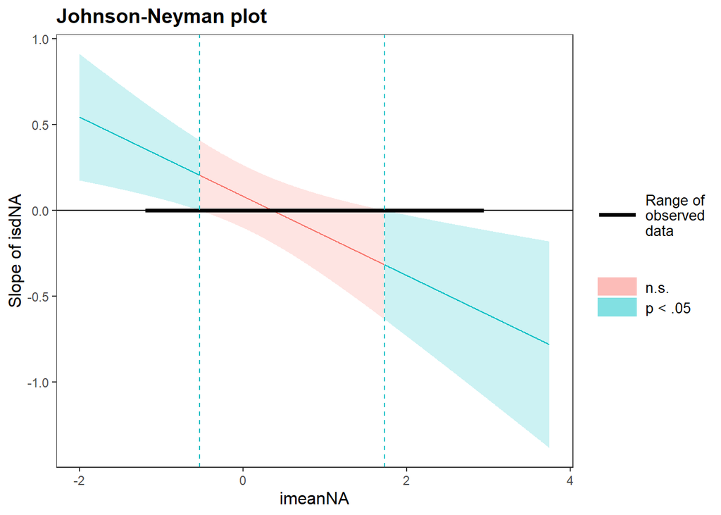

```r
#significant interaction effect. Following up with simple slope analyses
#Johnson Neyman
johnson_neyman(lm_Base_NA_SDAR_mod, pred=isdNA, modx=imeanNA, plot = TRUE) #plot
```

```r
#I used the following following shiny app for Johnson-Neyman as well as simple slope figures (McCabe et al., 2018)
#https://connorjmccabe.shinyapps.io/interactive/
#for reproduction, use file mega_all_cen_std_5.csv
#focal variable: isdNA (centered), moderator variable: imeanNA (centered), dependent variable: DepB (standardized)
#control variables: Age, Sex, study_2, study_3, study_4, study_5, autocorNA


#This is information from the website:
# The simple slope of isdNA on DepB is significant and negative when imeanNA is 2.1
# standard deviations away from the mean or further. 5.96% of observations are within
# this region. The simple slope of isdNA on DepB is significant and positive when imeanNA
# is -0.55 standard deviations away from the mean or further. 34.42% of observations in
# imeanNA are within this region.
```

###### 9.1.2.2.1.4 Sensitivity Meta-analyses

Note, that we initially planned on using a two-stage approach, where data was analyzed first and then results were pooled (two-stage approach). To check consistency, I am checking here whether the interaction effect is affected by the one-stage versus two-stage approach.

Conclusion: It is not!

```r
## Individual regressions

# Create a vector of study IDs
study_ids <- c("1", "2", "3", "4", "5")

# Initialize an empty list to store the results
results_list <- list()

# Loop through each study ID
for (study_id in study_ids) {
  # Filter the dataset based on the study ID
  dataset <- mega_all_cen_std_5 %>% filter(study == study_id)

  # Perform the linear regression
  lm_model <- lm(DepB ~ isdNA + autocorNA + imeanNA + isdNA:imeanNA + autocorNA:imeanNA + Age + Sex, data = dataset)

  # Get the summary of the linear regression
  st_lm_model <- summ(lm_model, digits = getOption("jtools-digits", 3), confint = TRUE, scale = TRUE, transform.response = TRUE)

  # Extract the coefficient value of interest (7th row, 1st column)
  df_int_SD <- st_lm_model$coeftable[7, 1]

  # Store the result in the list
  results_list[[paste0("df", study_id, "_int_SD")]] <- df_int_SD
}

# Unlist the results to get separate variables (df1_int_SD, df2_int_SD, etc.)
SD_NA_5 <- unlist(results_list)


## Meta-analysis with metafor package
#bind moderation effects
names<-c("dataset 1", "dataset 2", "dataset 3", "dataset 4", "dataset 5")
meta_SD<-as.data.frame(cbind(names,nstudy5,SD_NA_5))
meta_SD$nstudy5<-as.numeric(meta_SD$nstudy5)
meta_SD$SD_NA_5<-as.numeric(meta_SD$SD_NA_5)

#analyse
effects_meta_SD_dat <-escalc(measure ='COR', ri = meta_SD$SD_NA_5, ni = meta_SD$nstudy5)
effects_meta_SD<-rma(effects_meta_SD_dat,method ='REML')
effects_meta_SD
```

```
##
## Random-Effects Model (k = 5; tau^2 estimator: REML)
##
## tau^2 (estimated amount of total heterogeneity): 0.0025 (SE = 0.0050)
## tau (square root of estimated tau^2 value):      0.0496
## I^2 (total heterogeneity / total variability):   34.74%
## H^2 (total variability / sampling variability):  1.53
##
## Test for Heterogeneity:
## Q(df = 4) = 5.7948, p-val = 0.2150
##
## Model Results:
##
## estimate      se     zval    pval    ci.lb    ci.ub
##  -0.1187  0.0380  -3.1246  0.0018  -0.1931  -0.0442  **
##
## ---
## Signif. codes:  0 '***' 0.001 '**' 0.01 '*' 0.05 '.' 0.1 ' ' 1
```

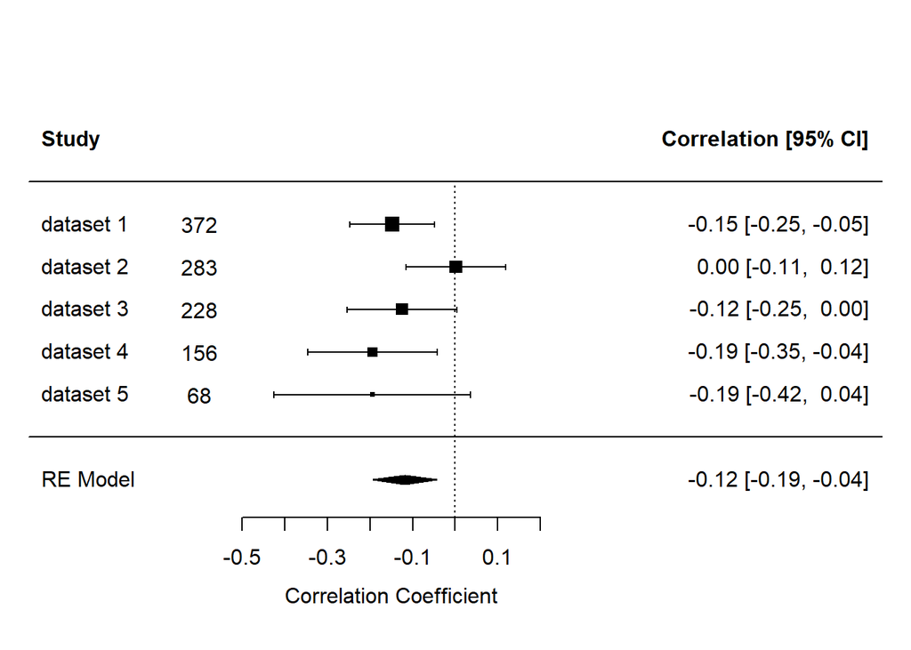

```r
forest(effects_meta_SD, xlim=c(1,-1), slab=names, ilab=nstudy5, ilab.xpos=-0.6, cex=1,header=TRUE)
```

##### 9.1.2.2.2 Follow-up Depression

Studies with available data:

- Dataset 1: RADAR
- Dataset 2: Swinging Moods
- Dataset 3: Mood in Emerging Adults

###### 9.1.2.2.2.1 Model 1: Main effects without controlling for affect level

```r
lm_FU_NA_SDAR_main1<-lm(DepF ~ DepB + study_2 + study_3 + isdNA + autocorNA + Age + Sex, data=mega_all_cen_std_3)
summ(lm_FU_NA_SDAR_main1,digits = getOption("jtools-digits", 3), vifs=TRUE)
```

| Observations | 718 (165 missing obs. deleted) |
| --- | --- |
| Dependent variable | DepF |
| Type | OLS linear regression |

| F(7,710) | 34.247 |
| --- | --- |
| R² | 0.252 |
| Adj. R² | 0.245 |

|  | Est. | S.E. | t val. | p | VIF |
| --- | --- | --- | --- | --- | --- |
| (Intercept) | -0.117 | 0.477 | -0.245 | 0.807 | NA |
| DepB | 0.406 | 0.035 | 11.440 | 0.000 | 1.120 |
| study_2 | -0.066 | 0.093 | -0.710 | 0.478 | 1.537 |
| study_3 | -0.116 | 0.254 | -0.456 | 0.649 | 12.516 |
| isdNA | 0.427 | 0.083 | 5.162 | 0.000 | 1.178 |
| autocorNA | 0.045 | 0.251 | 0.179 | 0.858 | 1.108 |
| Age | 0.003 | 0.036 | 0.091 | 0.928 | 10.896 |
| Sex1 | 0.209 | 0.075 | 2.783 | 0.006 | 1.254 |

Standard errors: OLS

```r
summ(lm_FU_NA_SDAR_main1,digits = getOption("jtools-digits", 3), confint = TRUE,scale = TRUE, transform.response = TRUE)
```

| Observations | 718 (165 missing obs. deleted) |
| --- | --- |
| Dependent variable | DepF |
| Type | OLS linear regression |

| F(7,710) | 34.247 |
| --- | --- |
| R² | 0.252 |
| Adj. R² | 0.245 |

|  | Est. | 2.5% | 97.5% | t val. | p |
| --- | --- | --- | --- | --- | --- |
| (Intercept) | -0.080 | -0.269 | 0.110 | -0.825 | 0.410 |
| DepB | 0.393 | 0.325 | 0.460 | 11.440 | 0.000 |
| study_2 | -0.066 | -0.248 | 0.116 | -0.710 | 0.478 |
| study_3 | -0.115 | -0.613 | 0.382 | -0.456 | 0.649 |
| isdNA | 0.182 | 0.113 | 0.251 | 5.162 | 0.000 |
| autocorNA | 0.006 | -0.061 | 0.073 | 0.179 | 0.858 |
| Age | 0.010 | -0.201 | 0.220 | 0.091 | 0.928 |
| Sex1 | 0.208 | 0.061 | 0.355 | 2.783 | 0.006 |

Standard errors: OLS; Continuous variables are mean-centered and scaled by 1 s.d.

###### 9.1.2.2.2.2 Model 2: Main effects with controlling for affect level

```r
lm_FU_NA_SDAR_main2<-lm(DepF ~ DepB + study_2 + study_3 + isdNA + autocorNA + imeanNA + Age + Sex, data=mega_all_cen_std_3)
summ(lm_FU_NA_SDAR_main2,digits = getOption("jtools-digits", 3), vifs=TRUE)
```

| Observations | 718 (165 missing obs. deleted) |
| --- | --- |
| Dependent variable | DepF |
| Type | OLS linear regression |

| F(8,709) | 32.559 |
| --- | --- |
| R² | 0.269 |
| Adj. R² | 0.260 |

|  | Est. | S.E. | t val. | p | VIF |
| --- | --- | --- | --- | --- | --- |
| (Intercept) | -0.082 | 0.472 | -0.173 | 0.863 | NA |
| DepB | 0.369 | 0.036 | 10.167 | 0.000 | 1.197 |
| study_2 | -0.058 | 0.092 | -0.631 | 0.528 | 1.537 |
| study_3 | -0.089 | 0.251 | -0.356 | 0.722 | 12.525 |
| isdNA | 0.169 | 0.104 | 1.614 | 0.107 | 1.922 |
| autocorNA | -0.409 | 0.274 | -1.493 | 0.136 | 1.341 |
| imeanNA | 0.241 | 0.061 | 3.970 | 0.000 | 2.488 |
| Age | 0.001 | 0.036 | 0.014 | 0.989 | 10.900 |
| Sex1 | 0.206 | 0.074 | 2.774 | 0.006 | 1.254 |

Standard errors: OLS

```r
summ(lm_FU_NA_SDAR_main2,digits = getOption("jtools-digits", 3), confint = TRUE,scale = TRUE, transform.response = TRUE)
```

| Observations | 718 (165 missing obs. deleted) |
| --- | --- |
| Dependent variable | DepF |
| Type | OLS linear regression |

| F(8,709) | 32.559 |
| --- | --- |
| R² | 0.269 |
| Adj. R² | 0.260 |

|  | Est. | 2.5% | 97.5% | t val. | p |
| --- | --- | --- | --- | --- | --- |
| (Intercept) | -0.087 | -0.275 | 0.100 | -0.914 | 0.361 |
| DepB | 0.357 | 0.288 | 0.426 | 10.167 | 0.000 |
| study_2 | -0.058 | -0.238 | 0.122 | -0.631 | 0.528 |
| study_3 | -0.089 | -0.582 | 0.403 | -0.356 | 0.722 |
| isdNA | 0.072 | -0.016 | 0.159 | 1.614 | 0.107 |
| autocorNA | -0.056 | -0.129 | 0.017 | -1.493 | 0.136 |
| imeanNA | 0.201 | 0.102 | 0.301 | 3.970 | 0.000 |
| Age | 0.001 | -0.207 | 0.210 | 0.014 | 0.989 |
| Sex1 | 0.205 | 0.060 | 0.351 | 2.774 | 0.006 |

Standard errors: OLS; Continuous variables are mean-centered and scaled by 1 s.d.

###### 9.1.2.2.2.3 Model 3: Interaction effects affective dynamics and level

```r
lm_FU_NA_SDAR_mod<-lm(DepF ~ DepB + study_2 + study_3 + isdNA + autocorNA + imeanNA + isdNA:imeanNA + autocorNA:imeanNA + Age + Sex, data=mega_all_cen_std_3)
summ(lm_FU_NA_SDAR_mod,digits = getOption("jtools-digits", 3), vifs=TRUE)
```

| Observations | 718 (165 missing obs. deleted) |
| --- | --- |
| Dependent variable | DepF |
| Type | OLS linear regression |

| F(10,707) | 25.999 |
| --- | --- |
| R² | 0.269 |
| Adj. R² | 0.259 |

|  | Est. | S.E. | t val. | p | VIF |
| --- | --- | --- | --- | --- | --- |
| (Intercept) | -0.076 | 0.473 | -0.160 | 0.873 | NA |
| DepB | 0.368 | 0.037 | 10.054 | 0.000 | 1.213 |
| study_2 | -0.065 | 0.094 | -0.691 | 0.490 | 1.615 |
| study_3 | -0.097 | 0.253 | -0.384 | 0.701 | 12.639 |
| isdNA | 0.159 | 0.108 | 1.472 | 0.141 | 2.045 |
| autocorNA | -0.381 | 0.282 | -1.349 | 0.178 | 1.423 |
| imeanNA | 0.255 | 0.069 | 3.710 | 0.000 | 3.171 |
| Age | 0.001 | 0.036 | 0.024 | 0.981 | 10.907 |
| Sex1 | 0.208 | 0.074 | 2.789 | 0.005 | 1.261 |
| isdNA:imeanNA | -0.012 | 0.091 | -0.127 | 0.899 | 1.362 |
| autocorNA:imeanNA | -0.100 | 0.268 | -0.374 | 0.709 | 1.676 |

Standard errors: OLS

```r
summ(lm_FU_NA_SDAR_mod,digits = getOption("jtools-digits", 3), confint = TRUE,scale = TRUE, transform.response = TRUE)
```

| Observations | 718 (165 missing obs. deleted) |
| --- | --- |
| Dependent variable | DepF |
| Type | OLS linear regression |

| F(10,707) | 25.999 |
| --- | --- |
| R² | 0.269 |
| Adj. R² | 0.259 |

|  | Est. | 2.5% | 97.5% | t val. | p |
| --- | --- | --- | --- | --- | --- |
| (Intercept) | -0.076 | -0.276 | 0.124 | -0.746 | 0.456 |
| DepB | 0.356 | 0.287 | 0.426 | 10.054 | 0.000 |
| study_2 | -0.065 | -0.250 | 0.120 | -0.691 | 0.490 |
| study_3 | -0.097 | -0.592 | 0.398 | -0.384 | 0.701 |
| isdNA | 0.068 | -0.023 | 0.158 | 1.473 | 0.141 |
| autocorNA | -0.052 | -0.127 | 0.024 | -1.338 | 0.181 |
| imeanNA | 0.213 | 0.100 | 0.325 | 3.700 | 0.000 |
| Age | 0.003 | -0.206 | 0.211 | 0.024 | 0.981 |
| Sex1 | 0.208 | 0.061 | 0.354 | 2.789 | 0.005 |
| isdNA:imeanNA | -0.004 | -0.068 | 0.060 | -0.127 | 0.899 |
| autocorNA:imeanNA | -0.011 | -0.071 | 0.048 | -0.374 | 0.709 |

Standard errors: OLS; Continuous variables are mean-centered and scaled by 1 s.d.

## 9.2 Results reported in the supplement

These are the models for each of the different affect dynamic index separately.

### 9.2.1 Positive Affect

#### 9.2.1.1 Baseline Depression

Studies with available data:

- Dataset 1: RADAR
- Dataset 2: Swinging Moods
- Dataset 3: Mood in Emerging Adults
- Dataset 4: Emotions in Daily Life
- Dataset 5: Emotion Regulation in Action

##### 9.2.1.1.1 Model 1: Main effects without controlling for affect level

```r
#### Standard Deviation ####
lm_Base_PA_SD_main1<-lm(DepB ~ study_2 + study_3 + study_4 + study_5 + isdPA + Age + Sex, data=mega_all_cen_std_5)
summ(lm_Base_PA_SD_main1,digits = getOption("jtools-digits", 3), vifs=TRUE)
```

| Observations | 1095 (12 missing obs. deleted) |
| --- | --- |
| Dependent variable | DepB |
| Type | OLS linear regression |

| F(7,1087) | 9.116 |
| --- | --- |
| R² | 0.055 |
| Adj. R² | 0.049 |

|  | Est. | S.E. | t val. | p | VIF |
| --- | --- | --- | --- | --- | --- |
| (Intercept) | -0.496 | 0.314 | -1.582 | 0.114 | NA |
| study_2 | -0.073 | 0.083 | -0.880 | 0.379 | 1.509 |
| study_3 | -0.313 | 0.180 | -1.741 | 0.082 | 6.125 |
| study_4 | -0.330 | 0.221 | -1.495 | 0.135 | 6.894 |
| study_5 | -0.099 | 0.132 | -0.755 | 0.451 | 1.169 |
| isdPA | 0.432 | 0.071 | 6.076 | 0.000 | 1.026 |
| Age | 0.029 | 0.024 | 1.235 | 0.217 | 7.998 |
| Sex1 | 0.270 | 0.067 | 4.041 | 0.000 | 1.193 |

Standard errors: OLS

```r
summ(lm_Base_PA_SD_main1,digits = getOption("jtools-digits", 3), confint = TRUE,scale = TRUE, transform.response = TRUE)
```

| Observations | 1095 (12 missing obs. deleted) |
| --- | --- |
| Dependent variable | DepB |
| Type | OLS linear regression |

| F(7,1087) | 9.116 |
| --- | --- |
| R² | 0.055 |
| Adj. R² | 0.049 |

|  | Est. | 2.5% | 97.5% | t val. | p |
| --- | --- | --- | --- | --- | --- |
| (Intercept) | -0.035 | -0.209 | 0.139 | -0.393 | 0.695 |
| study_2 | -0.073 | -0.237 | 0.090 | -0.880 | 0.379 |
| study_3 | -0.314 | -0.667 | 0.040 | -1.741 | 0.082 |
| study_4 | -0.331 | -0.765 | 0.103 | -1.495 | 0.135 |
| study_5 | -0.100 | -0.359 | 0.159 | -0.755 | 0.451 |
| isdPA | 0.181 | 0.123 | 0.240 | 6.076 | 0.000 |
| Age | 0.103 | -0.061 | 0.267 | 1.235 | 0.217 |
| Sex1 | 0.270 | 0.139 | 0.401 | 4.041 | 0.000 |

Standard errors: OLS; Continuous variables are mean-centered and scaled by 1 s.d.

```r
#### RMSSD ####
lm_Base_PA_MSSD_main1<-lm(DepB ~ study_2 + study_3 + study_4 + study_5 + iMSSDPA + Age + Sex, data=mega_all_cen_std_5)
summ(lm_Base_PA_MSSD_main1,digits = getOption("jtools-digits", 3), vifs=TRUE)
```

| Observations | 1095 (12 missing obs. deleted) |
| --- | --- |
| Dependent variable | DepB |
| Type | OLS linear regression |

| F(7,1087) | 10.623 |
| --- | --- |
| R² | 0.064 |
| Adj. R² | 0.058 |

|  | Est. | S.E. | t val. | p | VIF |
| --- | --- | --- | --- | --- | --- |
| (Intercept) | -0.503 | 0.312 | -1.611 | 0.107 | NA |
| study_2 | -0.076 | 0.083 | -0.922 | 0.356 | 1.508 |
| study_3 | -0.320 | 0.179 | -1.791 | 0.074 | 6.114 |
| study_4 | -0.336 | 0.220 | -1.527 | 0.127 | 6.886 |
| study_5 | -0.103 | 0.131 | -0.785 | 0.433 | 1.169 |
| iMSSDPA | 0.403 | 0.059 | 6.872 | 0.000 | 1.015 |
| Age | 0.029 | 0.023 | 1.249 | 0.212 | 7.993 |
| Sex1 | 0.280 | 0.066 | 4.236 | 0.000 | 1.181 |

Standard errors: OLS

```r
summ(lm_Base_PA_MSSD_main1,digits = getOption("jtools-digits", 3), confint = TRUE,scale = TRUE, transform.response = TRUE)
```

| Observations | 1095 (12 missing obs. deleted) |
| --- | --- |
| Dependent variable | DepB |
| Type | OLS linear regression |

| F(7,1087) | 10.623 |
| --- | --- |
| R² | 0.064 |
| Adj. R² | 0.058 |

|  | Est. | 2.5% | 97.5% | t val. | p |
| --- | --- | --- | --- | --- | --- |
| (Intercept) | -0.038 | -0.211 | 0.135 | -0.431 | 0.667 |
| study_2 | -0.076 | -0.239 | 0.086 | -0.922 | 0.356 |
| study_3 | -0.321 | -0.673 | 0.031 | -1.791 | 0.074 |
| study_4 | -0.336 | -0.768 | 0.096 | -1.527 | 0.127 |
| study_5 | -0.103 | -0.361 | 0.155 | -0.785 | 0.433 |
| iMSSDPA | 0.203 | 0.145 | 0.261 | 6.872 | 0.000 |
| Age | 0.104 | -0.059 | 0.266 | 1.249 | 0.212 |
| Sex1 | 0.280 | 0.151 | 0.410 | 4.236 | 0.000 |

Standard errors: OLS; Continuous variables are mean-centered and scaled by 1 s.d.

```r
#### Autocorrelation ####
lm_Base_PA_autocor_main1<-lm(DepB ~ study_2 + study_3 + study_4 + study_5 + autocorPA + Age + Sex, data=mega_all_cen_std_5)
summ(lm_Base_PA_autocor_main1,digits = getOption("jtools-digits", 3), vifs=TRUE)
```

| Observations | 1095 (12 missing obs. deleted) |
| --- | --- |
| Dependent variable | DepB |
| Type | OLS linear regression |

| F(7,1087) | 4.795 |
| --- | --- |
| R² | 0.030 |
| Adj. R² | 0.024 |

|  | Est. | S.E. | t val. | p | VIF |
| --- | --- | --- | --- | --- | --- |
| (Intercept) | -0.629 | 0.317 | -1.983 | 0.048 | NA |
| study_2 | -0.094 | 0.084 | -1.115 | 0.265 | 1.507 |
| study_3 | -0.400 | 0.182 | -2.196 | 0.028 | 6.098 |
| study_4 | -0.422 | 0.224 | -1.885 | 0.060 | 6.871 |
| study_5 | -0.127 | 0.134 | -0.952 | 0.341 | 1.168 |
| autocorPA | -0.670 | 0.247 | -2.717 | 0.007 | 1.001 |
| Age | 0.037 | 0.024 | 1.557 | 0.120 | 7.980 |
| Sex1 | 0.339 | 0.067 | 5.061 | 0.000 | 1.167 |

Standard errors: OLS

```r
summ(lm_Base_PA_autocor_main1,digits = getOption("jtools-digits", 3), confint = TRUE,scale = TRUE, transform.response = TRUE)
```

| Observations | 1095 (12 missing obs. deleted) |
| --- | --- |
| Dependent variable | DepB |
| Type | OLS linear regression |

| F(7,1087) | 4.795 |
| --- | --- |
| R² | 0.030 |
| Adj. R² | 0.024 |

|  | Est. | 2.5% | 97.5% | t val. | p |
| --- | --- | --- | --- | --- | --- |
| (Intercept) | -0.041 | -0.217 | 0.136 | -0.453 | 0.651 |
| study_2 | -0.094 | -0.260 | 0.071 | -1.115 | 0.265 |
| study_3 | -0.400 | -0.758 | -0.043 | -2.196 | 0.028 |
| study_4 | -0.422 | -0.862 | 0.017 | -1.885 | 0.060 |
| study_5 | -0.127 | -0.390 | 0.135 | -0.952 | 0.341 |
| autocorPA | -0.081 | -0.140 | -0.023 | -2.717 | 0.007 |
| Age | 0.131 | -0.034 | 0.297 | 1.557 | 0.120 |
| Sex1 | 0.339 | 0.208 | 0.470 | 5.061 | 0.000 |

Standard errors: OLS; Continuous variables are mean-centered and scaled by 1 s.d.

##### 9.2.1.1.2 Model 2: Main effects with controlling for affect level

```r
#### Standard Deviation ####
lm_Base_PA_SD_main2<-lm(DepB ~ study_2 + study_3 + study_4 + study_5 + isdPA + imeanPA + Age + Sex, data=mega_all_cen_std_5)
summ(lm_Base_PA_SD_main2,digits = getOption("jtools-digits", 3), vifs=TRUE)
```

| Observations | 1095 (12 missing obs. deleted) |
| --- | --- |
| Dependent variable | DepB |
| Type | OLS linear regression |

| F(8,1086) | 23.013 |
| --- | --- |
| R² | 0.145 |
| Adj. R² | 0.139 |

|  | Est. | S.E. | t val. | p | VIF |
| --- | --- | --- | --- | --- | --- |
| (Intercept) | -0.514 | 0.299 | -1.722 | 0.085 | NA |
| study_2 | -0.077 | 0.079 | -0.967 | 0.334 | 1.509 |
| study_3 | -0.329 | 0.171 | -1.919 | 0.055 | 6.125 |
| study_4 | -0.344 | 0.210 | -1.637 | 0.102 | 6.894 |
| study_5 | -0.106 | 0.125 | -0.846 | 0.398 | 1.169 |
| isdPA | 0.104 | 0.074 | 1.399 | 0.162 | 1.238 |
| imeanPA | -0.315 | 0.030 | -10.662 | 0.000 | 1.209 |
| Age | 0.030 | 0.022 | 1.336 | 0.182 | 7.998 |
| Sex1 | 0.287 | 0.064 | 4.516 | 0.000 | 1.194 |

Standard errors: OLS

```r
summ(lm_Base_PA_SD_main2,digits = getOption("jtools-digits", 3), confint = TRUE,scale = TRUE, transform.response = TRUE)
```

| Observations | 1095 (12 missing obs. deleted) |
| --- | --- |
| Dependent variable | DepB |
| Type | OLS linear regression |

| F(8,1086) | 23.013 |
| --- | --- |
| R² | 0.145 |
| Adj. R² | 0.139 |

|  | Est. | 2.5% | 97.5% | t val. | p |
| --- | --- | --- | --- | --- | --- |
| (Intercept) | -0.039 | -0.205 | 0.126 | -0.466 | 0.641 |
| study_2 | -0.077 | -0.232 | 0.079 | -0.967 | 0.334 |
| study_3 | -0.329 | -0.666 | 0.007 | -1.919 | 0.055 |
| study_4 | -0.345 | -0.758 | 0.068 | -1.637 | 0.102 |
| study_5 | -0.106 | -0.353 | 0.140 | -0.846 | 0.398 |
| isdPA | 0.044 | -0.018 | 0.105 | 1.399 | 0.162 |
| imeanPA | -0.329 | -0.389 | -0.268 | -10.662 | 0.000 |
| Age | 0.106 | -0.050 | 0.262 | 1.336 | 0.182 |
| Sex1 | 0.287 | 0.163 | 0.412 | 4.516 | 0.000 |

Standard errors: OLS; Continuous variables are mean-centered and scaled by 1 s.d.

```r
#### RMSSD ####
lm_Base_PA_MSSD_main2<-lm(DepB ~ study_2 + study_3 + study_4 + study_5 + iMSSDPA + imeanPA + Age + Sex, data=mega_all_cen_std_5)
summ(lm_Base_PA_MSSD_main2,digits = getOption("jtools-digits", 3), vifs=TRUE)
```

| Observations | 1095 (12 missing obs. deleted) |
| --- | --- |
| Dependent variable | DepB |
| Type | OLS linear regression |

| F(8,1086) | 23.860 |
| --- | --- |
| R² | 0.149 |
| Adj. R² | 0.143 |

|  | Est. | S.E. | t val. | p | VIF |
| --- | --- | --- | --- | --- | --- |
| (Intercept) | -0.499 | 0.298 | -1.676 | 0.094 | NA |
| study_2 | -0.075 | 0.079 | -0.953 | 0.341 | 1.508 |
| study_3 | -0.320 | 0.171 | -1.876 | 0.061 | 6.114 |
| study_4 | -0.335 | 0.210 | -1.595 | 0.111 | 6.886 |
| study_5 | -0.104 | 0.125 | -0.829 | 0.407 | 1.169 |
| iMSSDPA | 0.168 | 0.060 | 2.786 | 0.005 | 1.179 |
| imeanPA | -0.302 | 0.029 | -10.446 | 0.000 | 1.164 |
| Age | 0.029 | 0.022 | 1.296 | 0.195 | 7.993 |
| Sex1 | 0.282 | 0.063 | 4.467 | 0.000 | 1.181 |

Standard errors: OLS

```r
summ(lm_Base_PA_MSSD_main2,digits = getOption("jtools-digits", 3), confint = TRUE,scale = TRUE, transform.response = TRUE)
```

| Observations | 1095 (12 missing obs. deleted) |
| --- | --- |
| Dependent variable | DepB |
| Type | OLS linear regression |

| F(8,1086) | 23.860 |
| --- | --- |
| R² | 0.149 |
| Adj. R² | 0.143 |

|  | Est. | 2.5% | 97.5% | t val. | p |
| --- | --- | --- | --- | --- | --- |
| (Intercept) | -0.040 | -0.205 | 0.126 | -0.470 | 0.639 |
| study_2 | -0.075 | -0.230 | 0.080 | -0.953 | 0.341 |
| study_3 | -0.321 | -0.656 | 0.015 | -1.876 | 0.061 |
| study_4 | -0.335 | -0.747 | 0.077 | -1.595 | 0.111 |
| study_5 | -0.104 | -0.350 | 0.142 | -0.829 | 0.407 |
| iMSSDPA | 0.085 | 0.025 | 0.144 | 2.786 | 0.005 |
| imeanPA | -0.315 | -0.375 | -0.256 | -10.446 | 0.000 |
| Age | 0.103 | -0.053 | 0.258 | 1.296 | 0.195 |
| Sex1 | 0.282 | 0.158 | 0.406 | 4.467 | 0.000 |

Standard errors: OLS; Continuous variables are mean-centered and scaled by 1 s.d.

```r
#### Autocorrelation ####
lm_Base_PA_autocor_main2<-lm(DepB ~ study_2 + study_3 + study_4 + study_5 + autocorPA + imeanPA + Age + Sex, data=mega_all_cen_std_5)
summ(lm_Base_PA_autocor_main2,digits = getOption("jtools-digits", 3), vifs=TRUE)
```

| Observations | 1095 (12 missing obs. deleted) |
| --- | --- |
| Dependent variable | DepB |
| Type | OLS linear regression |

| F(8,1086) | 23.347 |
| --- | --- |
| R² | 0.147 |
| Adj. R² | 0.140 |

|  | Est. | S.E. | t val. | p | VIF |
| --- | --- | --- | --- | --- | --- |
| (Intercept) | -0.550 | 0.298 | -1.846 | 0.065 | NA |
| study_2 | -0.083 | 0.079 | -1.047 | 0.295 | 1.507 |
| study_3 | -0.353 | 0.171 | -2.065 | 0.039 | 6.101 |
| study_4 | -0.369 | 0.210 | -1.760 | 0.079 | 6.874 |
| study_5 | -0.114 | 0.125 | -0.909 | 0.364 | 1.168 |
| autocorPA | -0.478 | 0.232 | -2.061 | 0.040 | 1.006 |
| imeanPA | -0.329 | 0.027 | -12.192 | 0.000 | 1.007 |
| Age | 0.032 | 0.022 | 1.437 | 0.151 | 7.983 |
| Sex1 | 0.305 | 0.063 | 4.861 | 0.000 | 1.169 |

Standard errors: OLS

```r
summ(lm_Base_PA_autocor_main2,digits = getOption("jtools-digits", 3), confint = TRUE,scale = TRUE, transform.response = TRUE)
```

| Observations | 1095 (12 missing obs. deleted) |
| --- | --- |
| Dependent variable | DepB |
| Type | OLS linear regression |

| F(8,1086) | 23.347 |
| --- | --- |
| R² | 0.147 |
| Adj. R² | 0.140 |

|  | Est. | 2.5% | 97.5% | t val. | p |
| --- | --- | --- | --- | --- | --- |
| (Intercept) | -0.040 | -0.206 | 0.125 | -0.480 | 0.632 |
| study_2 | -0.083 | -0.238 | 0.072 | -1.047 | 0.295 |
| study_3 | -0.353 | -0.689 | -0.018 | -2.065 | 0.039 |
| study_4 | -0.370 | -0.782 | 0.042 | -1.760 | 0.079 |
| study_5 | -0.114 | -0.360 | 0.132 | -0.909 | 0.364 |
| autocorPA | -0.058 | -0.113 | -0.003 | -2.061 | 0.040 |
| imeanPA | -0.343 | -0.398 | -0.288 | -12.192 | 0.000 |
| Age | 0.114 | -0.042 | 0.269 | 1.437 | 0.151 |
| Sex1 | 0.306 | 0.182 | 0.429 | 4.861 | 0.000 |

Standard errors: OLS; Continuous variables are mean-centered and scaled by 1 s.d.

##### 9.2.1.1.3 Model 3: Interaction effects affective dynamics and level

```r
#### Standard Deviation ####
lm_Base_PA_SD_mod<-lm(DepB ~ study_2 + study_3 + study_4 + study_5 + isdPA + imeanPA + isdPA:imeanPA + Age + Sex, data=mega_all_cen_std_5)
summ(lm_Base_PA_SD_mod,digits = getOption("jtools-digits", 3), vifs=TRUE)
```

| Observations | 1095 (12 missing obs. deleted) |
| --- | --- |
| Dependent variable | DepB |
| Type | OLS linear regression |

| F(9,1085) | 20.439 |
| --- | --- |
| R² | 0.145 |
| Adj. R² | 0.138 |

|  | Est. | S.E. | t val. | p | VIF |
| --- | --- | --- | --- | --- | --- |
| (Intercept) | -0.511 | 0.300 | -1.704 | 0.089 | NA |
| study_2 | -0.077 | 0.079 | -0.971 | 0.332 | 1.513 |
| study_3 | -0.329 | 0.171 | -1.919 | 0.055 | 6.125 |
| study_4 | -0.345 | 0.211 | -1.640 | 0.101 | 6.908 |
| study_5 | -0.106 | 0.126 | -0.844 | 0.399 | 1.170 |
| isdPA | 0.105 | 0.075 | 1.402 | 0.161 | 1.245 |
| imeanPA | -0.315 | 0.030 | -10.621 | 0.000 | 1.215 |
| Age | 0.030 | 0.022 | 1.330 | 0.184 | 8.014 |
| Sex1 | 0.287 | 0.064 | 4.515 | 0.000 | 1.195 |
| isdPA:imeanPA | 0.006 | 0.059 | 0.108 | 0.914 | 1.052 |

Standard errors: OLS

```r
summ(lm_Base_PA_SD_mod,digits = getOption("jtools-digits", 3), confint = TRUE,scale = TRUE, transform.response = TRUE)
```

| Observations | 1095 (12 missing obs. deleted) |
| --- | --- |
| Dependent variable | DepB |
| Type | OLS linear regression |

| F(9,1085) | 20.439 |
| --- | --- |
| R² | 0.145 |
| Adj. R² | 0.138 |

|  | Est. | 2.5% | 97.5% | t val. | p |
| --- | --- | --- | --- | --- | --- |
| (Intercept) | -0.038 | -0.206 | 0.129 | -0.446 | 0.656 |
| study_2 | -0.077 | -0.233 | 0.079 | -0.971 | 0.332 |
| study_3 | -0.329 | -0.666 | 0.007 | -1.919 | 0.055 |
| study_4 | -0.346 | -0.760 | 0.068 | -1.640 | 0.101 |
| study_5 | -0.106 | -0.353 | 0.141 | -0.844 | 0.399 |
| isdPA | 0.044 | -0.018 | 0.105 | 1.402 | 0.161 |
| imeanPA | -0.329 | -0.389 | -0.268 | -10.617 | 0.000 |
| Age | 0.106 | -0.050 | 0.262 | 1.330 | 0.184 |
| Sex1 | 0.288 | 0.163 | 0.413 | 4.515 | 0.000 |
| isdPA:imeanPA | 0.003 | -0.048 | 0.054 | 0.108 | 0.914 |

Standard errors: OLS; Continuous variables are mean-centered and scaled by 1 s.d.

```r
#### RMSSD ####
lm_Base_PA_MSSD_mod<-lm(DepB ~ study_2 + study_3 + study_4 + study_5 + iMSSDPA + imeanPA + iMSSDPA:imeanPA + Age + Sex, data=mega_all_cen_std_5)
summ(lm_Base_PA_MSSD_mod,digits = getOption("jtools-digits", 3), vifs=TRUE)
```

| Observations | 1095 (12 missing obs. deleted) |
| --- | --- |
| Dependent variable | DepB |
| Type | OLS linear regression |

| F(9,1085) | 21.345 |
| --- | --- |
| R² | 0.150 |
| Adj. R² | 0.143 |

|  | Est. | S.E. | t val. | p | VIF |
| --- | --- | --- | --- | --- | --- |
| (Intercept) | -0.529 | 0.299 | -1.769 | 0.077 | NA |
| study_2 | -0.072 | 0.079 | -0.912 | 0.362 | 1.510 |
| study_3 | -0.321 | 0.171 | -1.883 | 0.060 | 6.114 |
| study_4 | -0.326 | 0.210 | -1.555 | 0.120 | 6.895 |
| study_5 | -0.109 | 0.125 | -0.868 | 0.385 | 1.170 |
| iMSSDPA | 0.162 | 0.061 | 2.670 | 0.008 | 1.190 |
| imeanPA | -0.305 | 0.029 | -10.501 | 0.000 | 1.172 |
| Age | 0.030 | 0.022 | 1.345 | 0.179 | 8.010 |
| Sex1 | 0.281 | 0.063 | 4.462 | 0.000 | 1.181 |
| iMSSDPA:imeanPA | -0.055 | 0.051 | -1.093 | 0.275 | 1.052 |

Standard errors: OLS

```r
summ(lm_Base_PA_MSSD_mod,digits = getOption("jtools-digits", 3), confint = TRUE,scale = TRUE, transform.response = TRUE)
```

| Observations | 1095 (12 missing obs. deleted) |
| --- | --- |
| Dependent variable | DepB |
| Type | OLS linear regression |

| F(9,1085) | 21.345 |
| --- | --- |
| R² | 0.150 |
| Adj. R² | 0.143 |

|  | Est. | 2.5% | 97.5% | t val. | p |
| --- | --- | --- | --- | --- | --- |
| (Intercept) | -0.052 | -0.218 | 0.115 | -0.608 | 0.543 |
| study_2 | -0.072 | -0.227 | 0.083 | -0.912 | 0.362 |
| study_3 | -0.322 | -0.657 | 0.013 | -1.883 | 0.060 |
| study_4 | -0.327 | -0.739 | 0.085 | -1.555 | 0.120 |
| study_5 | -0.109 | -0.355 | 0.137 | -0.868 | 0.385 |
| iMSSDPA | 0.081 | 0.022 | 0.141 | 2.670 | 0.008 |
| imeanPA | -0.318 | -0.378 | -0.259 | -10.502 | 0.000 |
| Age | 0.107 | -0.049 | 0.262 | 1.345 | 0.179 |
| Sex1 | 0.282 | 0.158 | 0.406 | 4.462 | 0.000 |
| iMSSDPA:imeanPA | -0.029 | -0.081 | 0.023 | -1.093 | 0.275 |

Standard errors: OLS; Continuous variables are mean-centered and scaled by 1 s.d.

```r
#### Autocorrelation ####
lm_Base_PA_autocor_mod<-lm(DepB ~ study_2 + study_3 + study_4 + study_5 + autocorPA + imeanPA + autocorPA:imeanPA + Age + Sex, data=mega_all_cen_std_5)
summ(lm_Base_PA_autocor_mod,digits = getOption("jtools-digits", 3), vifs=TRUE)
```

| Observations | 1095 (12 missing obs. deleted) |
| --- | --- |
| Dependent variable | DepB |
| Type | OLS linear regression |

| F(9,1085) | 20.745 |
| --- | --- |
| R² | 0.147 |
| Adj. R² | 0.140 |

|  | Est. | S.E. | t val. | p | VIF |
| --- | --- | --- | --- | --- | --- |
| (Intercept) | -0.550 | 0.298 | -1.846 | 0.065 | NA |
| study_2 | -0.082 | 0.079 | -1.039 | 0.299 | 1.508 |
| study_3 | -0.353 | 0.171 | -2.065 | 0.039 | 6.101 |
| study_4 | -0.368 | 0.210 | -1.750 | 0.080 | 6.880 |
| study_5 | -0.118 | 0.126 | -0.933 | 0.351 | 1.181 |
| autocorPA | -0.465 | 0.237 | -1.962 | 0.050 | 1.047 |
| imeanPA | -0.331 | 0.028 | -11.831 | 0.000 | 1.082 |
| Age | 0.032 | 0.022 | 1.433 | 0.152 | 7.984 |
| Sex1 | 0.306 | 0.063 | 4.866 | 0.000 | 1.170 |
| autocorPA:imeanPA | 0.064 | 0.222 | 0.290 | 0.772 | 1.130 |

Standard errors: OLS

```r
summ(lm_Base_PA_autocor_mod,digits = getOption("jtools-digits", 3), confint = TRUE,scale = TRUE, transform.response = TRUE)
```

| Observations | 1095 (12 missing obs. deleted) |
| --- | --- |
| Dependent variable | DepB |
| Type | OLS linear regression |

| F(9,1085) | 20.745 |
| --- | --- |
| R² | 0.147 |
| Adj. R² | 0.140 |

|  | Est. | 2.5% | 97.5% | t val. | p |
| --- | --- | --- | --- | --- | --- |
| (Intercept) | -0.042 | -0.207 | 0.124 | -0.491 | 0.623 |
| study_2 | -0.082 | -0.238 | 0.073 | -1.039 | 0.299 |
| study_3 | -0.353 | -0.689 | -0.018 | -2.065 | 0.039 |
| study_4 | -0.368 | -0.781 | 0.045 | -1.750 | 0.080 |
| study_5 | -0.118 | -0.365 | 0.130 | -0.933 | 0.351 |
| autocorPA | -0.056 | -0.113 | 0.000 | -1.962 | 0.050 |
| imeanPA | -0.345 | -0.402 | -0.288 | -11.831 | 0.000 |
| Age | 0.114 | -0.042 | 0.269 | 1.433 | 0.152 |
| Sex1 | 0.306 | 0.183 | 0.430 | 4.866 | 0.000 |
| autocorPA:imeanPA | 0.008 | -0.047 | 0.063 | 0.290 | 0.772 |

Standard errors: OLS; Continuous variables are mean-centered and scaled by 1 s.d.

#### 9.2.1.2 Follow-up Depression

Studies with available data:

- Dataset 1: RADAR
- Dataset 2: Swinging Moods
- Dataset 3: Mood in Emerging Adults

##### 9.2.1.2.1 Model 1: Main effects without controlling for affect level

```r
# select only datasets with PA and FU Dep data (datasets 1, 2 and 3)
mega_all_cen_std_3 <- mega_all_cen_std %>%
  dplyr::filter(study == "1" | study == "2" | study == "3")

#### Standard Deviation ####
lm_FU_PA_SD_main1<-lm(DepF ~ DepB + study_2 + study_3  + isdPA + Age + Sex, data=mega_all_cen_std_3)
summ(lm_FU_PA_SD_main1,digits = getOption("jtools-digits", 3), vifs=TRUE)
```

| Observations | 718 (165 missing obs. deleted) |
| --- | --- |
| Dependent variable | DepF |
| Type | OLS linear regression |

| F(6,711) | 40.488 |
| --- | --- |
| R² | 0.255 |
| Adj. R² | 0.248 |

|  | Est. | S.E. | t val. | p | VIF |
| --- | --- | --- | --- | --- | --- |
| (Intercept) | -0.017 | 0.476 | -0.036 | 0.971 | NA |
| DepB | 0.424 | 0.035 | 12.273 | 0.000 | 1.064 |
| study_2 | -0.064 | 0.092 | -0.695 | 0.487 | 1.537 |
| study_3 | -0.056 | 0.253 | -0.223 | 0.824 | 12.542 |
| isdPA | 0.429 | 0.076 | 5.615 | 0.000 | 1.060 |
| Age | -0.004 | 0.036 | -0.099 | 0.921 | 10.898 |
| Sex1 | 0.186 | 0.075 | 2.469 | 0.014 | 1.266 |

Standard errors: OLS

```r
summ(lm_FU_PA_SD_main1,digits = getOption("jtools-digits", 3), confint = TRUE,scale = TRUE, transform.response = TRUE)
```

| Observations | 718 (165 missing obs. deleted) |
| --- | --- |
| Dependent variable | DepF |
| Type | OLS linear regression |

| F(6,711) | 40.488 |
| --- | --- |
| R² | 0.255 |
| Adj. R² | 0.248 |

|  | Est. | 2.5% | 97.5% | t val. | p |
| --- | --- | --- | --- | --- | --- |
| (Intercept) | -0.083 | -0.272 | 0.106 | -0.859 | 0.390 |
| DepB | 0.410 | 0.344 | 0.476 | 12.273 | 0.000 |
| study_2 | -0.064 | -0.246 | 0.117 | -0.695 | 0.487 |
| study_3 | -0.056 | -0.553 | 0.440 | -0.223 | 0.824 |
| isdPA | 0.187 | 0.122 | 0.253 | 5.615 | 0.000 |
| Age | -0.011 | -0.220 | 0.199 | -0.099 | 0.921 |
| Sex1 | 0.185 | 0.038 | 0.333 | 2.469 | 0.014 |

Standard errors: OLS; Continuous variables are mean-centered and scaled by 1 s.d.

```r
#### RMSSD ####
lm_FU_PA_MSSD_main1<-lm(DepF ~ DepB + study_2 + study_3 + iMSSDPA + Age + Sex, data=mega_all_cen_std_3)
summ(lm_FU_PA_MSSD_main1,digits = getOption("jtools-digits", 3), vifs=TRUE)
```

| Observations | 718 (165 missing obs. deleted) |
| --- | --- |
| Dependent variable | DepF |
| Type | OLS linear regression |

| F(6,711) | 38.939 |
| --- | --- |
| R² | 0.247 |
| Adj. R² | 0.241 |

|  | Est. | S.E. | t val. | p | VIF |
| --- | --- | --- | --- | --- | --- |
| (Intercept) | -0.054 | 0.478 | -0.112 | 0.911 | NA |
| DepB | 0.427 | 0.035 | 12.297 | 0.000 | 1.066 |
| study_2 | -0.070 | 0.093 | -0.757 | 0.449 | 1.536 |
| study_3 | -0.079 | 0.254 | -0.310 | 0.757 | 12.530 |
| iMSSDPA | 0.320 | 0.065 | 4.929 | 0.000 | 1.048 |
| Age | -0.002 | 0.036 | -0.047 | 0.962 | 10.895 |
| Sex1 | 0.210 | 0.075 | 2.797 | 0.005 | 1.253 |

Standard errors: OLS

```r
summ(lm_FU_PA_MSSD_main1,digits = getOption("jtools-digits", 3), confint = TRUE,scale = TRUE, transform.response = TRUE)
```

| Observations | 718 (165 missing obs. deleted) |
| --- | --- |
| Dependent variable | DepF |
| Type | OLS linear regression |

| F(6,711) | 38.939 |
| --- | --- |
| R² | 0.247 |
| Adj. R² | 0.241 |

|  | Est. | 2.5% | 97.5% | t val. | p |
| --- | --- | --- | --- | --- | --- |
| (Intercept) | -0.090 | -0.280 | 0.100 | -0.930 | 0.352 |
| DepB | 0.413 | 0.347 | 0.479 | 12.297 | 0.000 |
| study_2 | -0.070 | -0.252 | 0.112 | -0.757 | 0.449 |
| study_3 | -0.079 | -0.578 | 0.420 | -0.310 | 0.757 |
| iMSSDPA | 0.164 | 0.099 | 0.230 | 4.929 | 0.000 |
| Age | -0.005 | -0.216 | 0.206 | -0.047 | 0.962 |
| Sex1 | 0.210 | 0.063 | 0.357 | 2.797 | 0.005 |

Standard errors: OLS; Continuous variables are mean-centered and scaled by 1 s.d.

```r
#### Autocorrelation ####
lm_FU_PA_autocor_main1<-lm(DepF ~ DepB + study_2 + study_3 + autocorPA + Age + Sex, data=mega_all_cen_std_3)
summ(lm_FU_PA_autocor_main1,digits = getOption("jtools-digits", 3), vifs=TRUE)
```

| Observations | 718 (165 missing obs. deleted) |
| --- | --- |
| Dependent variable | DepF |
| Type | OLS linear regression |

| F(6,711) | 33.750 |
| --- | --- |
| R² | 0.222 |
| Adj. R² | 0.215 |

|  | Est. | S.E. | t val. | p | VIF |
| --- | --- | --- | --- | --- | --- |
| (Intercept) | -0.113 | 0.486 | -0.232 | 0.816 | NA |
| DepB | 0.457 | 0.035 | 13.138 | 0.000 | 1.035 |
| study_2 | -0.089 | 0.094 | -0.938 | 0.349 | 1.533 |
| study_3 | -0.125 | 0.259 | -0.483 | 0.629 | 12.514 |
| autocorPA | -0.069 | 0.278 | -0.249 | 0.804 | 1.005 |
| Age | 0.002 | 0.037 | 0.053 | 0.958 | 10.892 |
| Sex1 | 0.243 | 0.076 | 3.185 | 0.002 | 1.246 |

Standard errors: OLS

```r
summ(lm_FU_PA_autocor_main1,digits = getOption("jtools-digits", 3), confint = TRUE,scale = TRUE, transform.response = TRUE)
```

| Observations | 718 (165 missing obs. deleted) |
| --- | --- |
| Dependent variable | DepF |
| Type | OLS linear regression |

| F(6,711) | 33.750 |
| --- | --- |
| R² | 0.222 |
| Adj. R² | 0.215 |

|  | Est. | 2.5% | 97.5% | t val. | p |
| --- | --- | --- | --- | --- | --- |
| (Intercept) | -0.092 | -0.285 | 0.101 | -0.938 | 0.348 |
| DepB | 0.442 | 0.376 | 0.508 | 13.138 | 0.000 |
| study_2 | -0.088 | -0.274 | 0.097 | -0.938 | 0.349 |
| study_3 | -0.125 | -0.632 | 0.382 | -0.483 | 0.629 |
| autocorPA | -0.008 | -0.073 | 0.057 | -0.249 | 0.804 |
| Age | 0.006 | -0.209 | 0.220 | 0.053 | 0.958 |
| Sex1 | 0.242 | 0.093 | 0.392 | 3.185 | 0.002 |

Standard errors: OLS; Continuous variables are mean-centered and scaled by 1 s.d.

##### 9.2.1.2.2 Model 2: Main effects with controlling for affect level

```r
#### Standard Deviation ####
lm_FU_PA_SD_main2<-lm(DepF ~ DepB + study_2 + study_3 + isdPA + imeanPA + Age + Sex, data=mega_all_cen_std_3)
summ(lm_FU_PA_SD_main2,digits = getOption("jtools-digits", 3), vifs=TRUE)
```

| Observations | 718 (165 missing obs. deleted) |
| --- | --- |
| Dependent variable | DepF |
| Type | OLS linear regression |

| F(7,710) | 42.434 |
| --- | --- |
| R² | 0.295 |
| Adj. R² | 0.288 |

|  | Est. | S.E. | t val. | p | VIF |
| --- | --- | --- | --- | --- | --- |
| (Intercept) | 0.027 | 0.464 | 0.059 | 0.953 | NA |
| DepB | 0.361 | 0.035 | 10.300 | 0.000 | 1.156 |
| study_2 | -0.058 | 0.090 | -0.643 | 0.520 | 1.537 |
| study_3 | -0.038 | 0.247 | -0.155 | 0.877 | 12.544 |
| isdPA | 0.203 | 0.082 | 2.458 | 0.014 | 1.302 |
| imeanPA | -0.229 | 0.036 | -6.371 | 0.000 | 1.386 |
| Age | -0.008 | 0.035 | -0.217 | 0.829 | 10.902 |
| Sex1 | 0.206 | 0.073 | 2.811 | 0.005 | 1.269 |

Standard errors: OLS

```r
summ(lm_FU_PA_SD_main2,digits = getOption("jtools-digits", 3), confint = TRUE,scale = TRUE, transform.response = TRUE)
```

| Observations | 718 (165 missing obs. deleted) |
| --- | --- |
| Dependent variable | DepF |
| Type | OLS linear regression |

| F(7,710) | 42.434 |
| --- | --- |
| R² | 0.295 |
| Adj. R² | 0.288 |

|  | Est. | 2.5% | 97.5% | t val. | p |
| --- | --- | --- | --- | --- | --- |
| (Intercept) | -0.102 | -0.286 | 0.082 | -1.090 | 0.276 |
| DepB | 0.349 | 0.283 | 0.416 | 10.300 | 0.000 |
| study_2 | -0.058 | -0.234 | 0.119 | -0.643 | 0.520 |
| study_3 | -0.038 | -0.522 | 0.445 | -0.155 | 0.877 |
| isdPA | 0.088 | 0.018 | 0.159 | 2.458 | 0.014 |
| imeanPA | -0.236 | -0.309 | -0.163 | -6.371 | 0.000 |
| Age | -0.023 | -0.227 | 0.182 | -0.217 | 0.829 |
| Sex1 | 0.206 | 0.062 | 0.349 | 2.811 | 0.005 |

Standard errors: OLS; Continuous variables are mean-centered and scaled by 1 s.d.

```r
#### RMSSD ####
lm_FU_PA_MSSD_main2<-lm(DepF ~ DepB + study_2 + study_3  + iMSSDPA + imeanPA + Age + Sex, data=mega_all_cen_std_3)
summ(lm_FU_PA_MSSD_main2,digits = getOption("jtools-digits", 3), vifs=TRUE)
```

| Observations | 718 (165 missing obs. deleted) |
| --- | --- |
| Dependent variable | DepF |
| Type | OLS linear regression |

| F(7,710) | 42.108 |
| --- | --- |
| R² | 0.293 |
| Adj. R² | 0.286 |

|  | Est. | S.E. | t val. | p | VIF |
| --- | --- | --- | --- | --- | --- |
| (Intercept) | 0.013 | 0.464 | 0.027 | 0.978 | NA |
| DepB | 0.359 | 0.035 | 10.245 | 0.000 | 1.158 |
| study_2 | -0.060 | 0.090 | -0.670 | 0.503 | 1.536 |
| study_3 | -0.048 | 0.247 | -0.193 | 0.847 | 12.535 |
| iMSSDPA | 0.143 | 0.068 | 2.103 | 0.036 | 1.226 |
| imeanPA | -0.239 | 0.035 | -6.801 | 0.000 | 1.320 |
| Age | -0.007 | 0.035 | -0.197 | 0.844 | 10.900 |
| Sex1 | 0.218 | 0.073 | 2.989 | 0.003 | 1.253 |

Standard errors: OLS

```r
summ(lm_FU_PA_MSSD_main2,digits = getOption("jtools-digits", 3), confint = TRUE,scale = TRUE, transform.response = TRUE)
```

| Observations | 718 (165 missing obs. deleted) |
| --- | --- |
| Dependent variable | DepF |
| Type | OLS linear regression |

| F(7,710) | 42.108 |
| --- | --- |
| R² | 0.293 |
| Adj. R² | 0.286 |

|  | Est. | 2.5% | 97.5% | t val. | p |
| --- | --- | --- | --- | --- | --- |
| (Intercept) | -0.106 | -0.290 | 0.078 | -1.133 | 0.258 |
| DepB | 0.348 | 0.281 | 0.415 | 10.245 | 0.000 |
| study_2 | -0.060 | -0.237 | 0.116 | -0.670 | 0.503 |
| study_3 | -0.047 | -0.531 | 0.436 | -0.193 | 0.847 |
| iMSSDPA | 0.073 | 0.005 | 0.142 | 2.103 | 0.036 |
| imeanPA | -0.247 | -0.318 | -0.175 | -6.801 | 0.000 |
| Age | -0.021 | -0.225 | 0.184 | -0.197 | 0.844 |
| Sex1 | 0.217 | 0.075 | 0.360 | 2.989 | 0.003 |

Standard errors: OLS; Continuous variables are mean-centered and scaled by 1 s.d.

```r
#### Autocorrelation ####
lm_FU_PA_autocor_main2<-lm(DepF ~ DepB + study_2 + study_3 + autocorPA + imeanPA + Age + Sex, data=mega_all_cen_std_3)
summ(lm_FU_PA_autocor_main2,digits = getOption("jtools-digits", 3), vifs=TRUE)
```

| Observations | 718 (165 missing obs. deleted) |
| --- | --- |
| Dependent variable | DepF |
| Type | OLS linear regression |

| F(7,710) | 41.224 |
| --- | --- |
| R² | 0.289 |
| Adj. R² | 0.282 |

|  | Est. | S.E. | t val. | p | VIF |
| --- | --- | --- | --- | --- | --- |
| (Intercept) | -0.003 | 0.465 | -0.007 | 0.994 | NA |
| DepB | 0.363 | 0.035 | 10.332 | 0.000 | 1.157 |
| study_2 | -0.066 | 0.090 | -0.733 | 0.464 | 1.535 |
| study_3 | -0.062 | 0.247 | -0.250 | 0.803 | 12.526 |
| autocorPA | 0.038 | 0.266 | 0.144 | 0.885 | 1.007 |
| imeanPA | -0.267 | 0.033 | -8.198 | 0.000 | 1.131 |
| Age | -0.006 | 0.035 | -0.171 | 0.864 | 10.900 |
| Sex1 | 0.230 | 0.073 | 3.160 | 0.002 | 1.247 |

Standard errors: OLS

```r
summ(lm_FU_PA_autocor_main2,digits = getOption("jtools-digits", 3), confint = TRUE,scale = TRUE, transform.response = TRUE)
```

| Observations | 718 (165 missing obs. deleted) |
| --- | --- |
| Dependent variable | DepF |
| Type | OLS linear regression |

| F(7,710) | 41.224 |
| --- | --- |
| R² | 0.289 |
| Adj. R² | 0.282 |

|  | Est. | 2.5% | 97.5% | t val. | p |
| --- | --- | --- | --- | --- | --- |
| (Intercept) | -0.108 | -0.293 | 0.076 | -1.152 | 0.250 |
| DepB | 0.352 | 0.285 | 0.418 | 10.332 | 0.000 |
| study_2 | -0.066 | -0.243 | 0.111 | -0.733 | 0.464 |
| study_3 | -0.062 | -0.547 | 0.423 | -0.250 | 0.803 |
| autocorPA | 0.005 | -0.058 | 0.067 | 0.144 | 0.885 |
| imeanPA | -0.276 | -0.342 | -0.210 | -8.198 | 0.000 |
| Age | -0.018 | -0.223 | 0.187 | -0.171 | 0.864 |
| Sex1 | 0.230 | 0.087 | 0.373 | 3.160 | 0.002 |

Standard errors: OLS; Continuous variables are mean-centered and scaled by 1 s.d.

##### 9.2.1.2.3 Model 3: Interaction effects affective dynamics and level

```r
#### Standard Deviation ####
lm_FU_PA_SD_mod<-lm(DepF ~ DepB +  study_2 + study_3 + isdPA + imeanPA + isdPA:imeanPA + Age + Sex, data=mega_all_cen_std_3)
summ(lm_FU_PA_SD_mod,digits = getOption("jtools-digits", 3), vifs=TRUE)
```

| Observations | 718 (165 missing obs. deleted) |
| --- | --- |
| Dependent variable | DepF |
| Type | OLS linear regression |

| F(8,709) | 37.575 |
| --- | --- |
| R² | 0.298 |
| Adj. R² | 0.290 |

|  | Est. | S.E. | t val. | p | VIF |
| --- | --- | --- | --- | --- | --- |
| (Intercept) | -0.040 | 0.465 | -0.086 | 0.931 | NA |
| DepB | 0.362 | 0.035 | 10.339 | 0.000 | 1.157 |
| study_2 | -0.050 | 0.090 | -0.558 | 0.577 | 1.541 |
| study_3 | -0.042 | 0.246 | -0.172 | 0.864 | 12.545 |
| isdPA | 0.191 | 0.083 | 2.312 | 0.021 | 1.311 |
| imeanPA | -0.233 | 0.036 | -6.483 | 0.000 | 1.393 |
| Age | -0.005 | 0.035 | -0.129 | 0.898 | 10.932 |
| Sex1 | 0.202 | 0.073 | 2.755 | 0.006 | 1.270 |
| isdPA:imeanPA | -0.106 | 0.063 | -1.674 | 0.095 | 1.029 |

Standard errors: OLS

```r
summ(lm_FU_PA_SD_mod,digits = getOption("jtools-digits", 3), confint = TRUE,scale = TRUE, transform.response = TRUE)
```

| Observations | 718 (165 missing obs. deleted) |
| --- | --- |
| Dependent variable | DepF |
| Type | OLS linear regression |

| F(8,709) | 37.575 |
| --- | --- |
| R² | 0.298 |
| Adj. R² | 0.290 |

|  | Est. | 2.5% | 97.5% | t val. | p |
| --- | --- | --- | --- | --- | --- |
| (Intercept) | -0.122 | -0.308 | 0.063 | -1.297 | 0.195 |
| DepB | 0.350 | 0.284 | 0.416 | 10.339 | 0.000 |
| study_2 | -0.050 | -0.227 | 0.126 | -0.558 | 0.577 |
| study_3 | -0.042 | -0.525 | 0.441 | -0.172 | 0.864 |
| isdPA | 0.082 | 0.012 | 0.153 | 2.284 | 0.023 |
| imeanPA | -0.240 | -0.313 | -0.167 | -6.472 | 0.000 |
| Age | -0.013 | -0.218 | 0.191 | -0.129 | 0.898 |
| Sex1 | 0.201 | 0.058 | 0.345 | 2.755 | 0.006 |
| isdPA:imeanPA | -0.048 | -0.104 | 0.008 | -1.674 | 0.095 |

Standard errors: OLS; Continuous variables are mean-centered and scaled by 1 s.d.

```r
#### RMSSD ####
lm_FU_PA_MSSD_mod<-lm(DepF ~ DepB + study_2 + study_3 + iMSSDPA + imeanPA + iMSSDPA:imeanPA + Age + Sex, data=mega_all_cen_std_3)
summ(lm_FU_PA_MSSD_mod,digits = getOption("jtools-digits", 3), vifs=TRUE)
```

| Observations | 718 (165 missing obs. deleted) |
| --- | --- |
| Dependent variable | DepF |
| Type | OLS linear regression |

| F(8,709) | 37.112 |
| --- | --- |
| R² | 0.295 |
| Adj. R² | 0.287 |

|  | Est. | S.E. | t val. | p | VIF |
| --- | --- | --- | --- | --- | --- |
| (Intercept) | -0.053 | 0.466 | -0.114 | 0.909 | NA |
| DepB | 0.358 | 0.035 | 10.223 | 0.000 | 1.159 |
| study_2 | -0.056 | 0.090 | -0.624 | 0.533 | 1.538 |
| study_3 | -0.058 | 0.247 | -0.237 | 0.813 | 12.548 |
| iMSSDPA | 0.137 | 0.068 | 2.004 | 0.045 | 1.233 |
| imeanPA | -0.242 | 0.035 | -6.874 | 0.000 | 1.325 |
| Age | -0.004 | 0.035 | -0.102 | 0.919 | 10.954 |
| Sex1 | 0.218 | 0.073 | 2.992 | 0.003 | 1.253 |
| iMSSDPA:imeanPA | -0.077 | 0.057 | -1.342 | 0.180 | 1.025 |

Standard errors: OLS

```r
summ(lm_FU_PA_MSSD_mod,digits = getOption("jtools-digits", 3), confint = TRUE,scale = TRUE, transform.response = TRUE)
```

| Observations | 718 (165 missing obs. deleted) |
| --- | --- |
| Dependent variable | DepF |
| Type | OLS linear regression |

| F(8,709) | 37.112 |
| --- | --- |
| R² | 0.295 |
| Adj. R² | 0.287 |

|  | Est. | 2.5% | 97.5% | t val. | p |
| --- | --- | --- | --- | --- | --- |
| (Intercept) | -0.121 | -0.306 | 0.064 | -1.284 | 0.199 |
| DepB | 0.347 | 0.280 | 0.414 | 10.223 | 0.000 |
| study_2 | -0.056 | -0.233 | 0.121 | -0.624 | 0.533 |
| study_3 | -0.058 | -0.542 | 0.425 | -0.237 | 0.813 |
| iMSSDPA | 0.069 | 0.001 | 0.138 | 1.980 | 0.048 |
| imeanPA | -0.249 | -0.320 | -0.178 | -6.866 | 0.000 |
| Age | -0.011 | -0.216 | 0.194 | -0.102 | 0.919 |
| Sex1 | 0.218 | 0.075 | 0.360 | 2.992 | 0.003 |
| iMSSDPA:imeanPA | -0.041 | -0.100 | 0.019 | -1.342 | 0.180 |

Standard errors: OLS; Continuous variables are mean-centered and scaled by 1 s.d.

```r
#### Autocorrelation ####
lm_FU_PA_autocor_mod<-lm(DepF ~ DepB +  study_2 + study_3 + autocorPA + imeanPA + autocorPA:imeanPA + Age + Sex, data=mega_all_cen_std_3)
summ(lm_FU_PA_autocor_mod,digits = getOption("jtools-digits", 3), vifs=TRUE)
```

| Observations | 718 (165 missing obs. deleted) |
| --- | --- |
| Dependent variable | DepF |
| Type | OLS linear regression |

| F(8,709) | 36.040 |
| --- | --- |
| R² | 0.289 |
| Adj. R² | 0.281 |

|  | Est. | S.E. | t val. | p | VIF |
| --- | --- | --- | --- | --- | --- |
| (Intercept) | 0.005 | 0.466 | 0.012 | 0.991 | NA |
| DepB | 0.363 | 0.035 | 10.324 | 0.000 | 1.157 |
| study_2 | -0.067 | 0.090 | -0.738 | 0.461 | 1.535 |
| study_3 | -0.058 | 0.248 | -0.232 | 0.817 | 12.559 |
| autocorPA | 0.020 | 0.272 | 0.073 | 0.942 | 1.051 |
| imeanPA | -0.265 | 0.033 | -8.010 | 0.000 | 1.166 |
| Age | -0.007 | 0.035 | -0.186 | 0.852 | 10.922 |
| Sex1 | 0.229 | 0.073 | 3.128 | 0.002 | 1.253 |
| autocorPA:imeanPA | -0.086 | 0.254 | -0.337 | 0.736 | 1.088 |

Standard errors: OLS

```r
summ(lm_FU_PA_autocor_mod,digits = getOption("jtools-digits", 3), confint = TRUE,scale = TRUE, transform.response = TRUE)
```

| Observations | 718 (165 missing obs. deleted) |
| --- | --- |
| Dependent variable | DepF |
| Type | OLS linear regression |

| F(8,709) | 36.040 |
| --- | --- |
| R² | 0.289 |
| Adj. R² | 0.281 |

|  | Est. | 2.5% | 97.5% | t val. | p |
| --- | --- | --- | --- | --- | --- |
| (Intercept) | -0.108 | -0.293 | 0.077 | -1.145 | 0.253 |
| DepB | 0.352 | 0.285 | 0.418 | 10.324 | 0.000 |
| study_2 | -0.067 | -0.244 | 0.111 | -0.738 | 0.461 |
| study_3 | -0.057 | -0.544 | 0.429 | -0.232 | 0.817 |
| autocorPA | 0.002 | -0.062 | 0.066 | 0.066 | 0.947 |
| imeanPA | -0.274 | -0.341 | -0.207 | -8.022 | 0.000 |
| Age | -0.019 | -0.225 | 0.186 | -0.186 | 0.852 |
| Sex1 | 0.228 | 0.085 | 0.372 | 3.128 | 0.002 |
| autocorPA:imeanPA | -0.011 | -0.072 | 0.051 | -0.337 | 0.736 |

Standard errors: OLS; Continuous variables are mean-centered and scaled by 1 s.d.

### 9.2.2 Negative Affect

#### 9.2.2.1 All datasets

These are the pre-registered analyses including all datasets.

Studies with available data:

- Dataset 1: RADAR
- Dataset 2: Swinging Moods
- Dataset 3: Mood in Emerging Adults
- Dataset 4: Emotions in Daily Life
- Dataset 5: Emotion Regulation in Action
- Dataset 6: LASER
- Dataset 7: YES

##### 9.2.2.1.1 Baseline Depression

###### 9.2.2.1.1.1 Model 1: Main effects without controlling for affect level

```r
#### Standard Deviation ####
lm_Base_NA_SD_main1<-lm(DepB ~ study_2 + study_3 + study_4 + study_5 + study_6 + study_7 + isdNA + Age + Sex, data=mega_all_cen_std)
summ(lm_Base_NA_SD_main1,digits = getOption("jtools-digits", 3), vifs=TRUE)
```

| Observations | 1428 (20 missing obs. deleted) |
| --- | --- |
| Dependent variable | DepB |
| Type | OLS linear regression |

| F(9,1418) | 15.487 |
| --- | --- |
| R² | 0.089 |
| Adj. R² | 0.084 |

|  | Est. | S.E. | t val. | p | VIF |
| --- | --- | --- | --- | --- | --- |
| (Intercept) | -0.735 | 0.266 | -2.759 | 0.006 | NA |
| study_2 | -0.092 | 0.080 | -1.150 | 0.251 | 1.574 |
| study_3 | -0.429 | 0.157 | -2.724 | 0.007 | 5.195 |
| study_4 | -0.482 | 0.192 | -2.504 | 0.012 | 5.663 |
| study_5 | -0.112 | 0.128 | -0.874 | 0.382 | 1.173 |
| study_6 | -0.386 | 0.149 | -2.589 | 0.010 | 3.698 |
| study_7 | -0.099 | 0.092 | -1.079 | 0.281 | 1.333 |
| isdNA | 0.582 | 0.057 | 10.257 | 0.000 | 1.009 |
| Age | 0.048 | 0.020 | 2.398 | 0.017 | 7.125 |
| Sex1 | 0.257 | 0.057 | 4.477 | 0.000 | 1.183 |

Standard errors: OLS

```r
summ(lm_Base_NA_SD_main1,digits = getOption("jtools-digits", 3), confint = TRUE,scale = TRUE, transform.response = TRUE)
```

| Observations | 1428 (20 missing obs. deleted) |
| --- | --- |
| Dependent variable | DepB |
| Type | OLS linear regression |

| F(9,1418) | 15.487 |
| --- | --- |
| R² | 0.089 |
| Adj. R² | 0.084 |

|  | Est. | 2.5% | 97.5% | t val. | p |
| --- | --- | --- | --- | --- | --- |
| (Intercept) | 0.035 | -0.125 | 0.194 | 0.427 | 0.670 |
| study_2 | -0.092 | -0.250 | 0.065 | -1.150 | 0.251 |
| study_3 | -0.431 | -0.741 | -0.121 | -2.724 | 0.007 |
| study_4 | -0.484 | -0.863 | -0.105 | -2.504 | 0.012 |
| study_5 | -0.113 | -0.365 | 0.140 | -0.874 | 0.382 |
| study_6 | -0.387 | -0.681 | -0.094 | -2.589 | 0.010 |
| study_7 | -0.100 | -0.281 | 0.082 | -1.079 | 0.281 |
| isdNA | 0.261 | 0.211 | 0.311 | 10.257 | 0.000 |
| Age | 0.162 | 0.030 | 0.295 | 2.398 | 0.017 |
| Sex1 | 0.258 | 0.145 | 0.372 | 4.477 | 0.000 |

Standard errors: OLS; Continuous variables are mean-centered and scaled by 1 s.d.

```r
#### RMSSD ####
lm_Base_NA_MSSD_main1<-lm(DepB ~ study_2 + study_3 + study_4 + study_5 + study_6 + study_7 + iMSSDNA + Age + Sex, data=mega_all_cen_std)
summ(lm_Base_NA_MSSD_main1,digits = getOption("jtools-digits", 3), vifs=TRUE)
```

| Observations | 1428 (20 missing obs. deleted) |
| --- | --- |
| Dependent variable | DepB |
| Type | OLS linear regression |

| F(9,1418) | 12.575 |
| --- | --- |
| R² | 0.074 |
| Adj. R² | 0.068 |

|  | Est. | S.E. | t val. | p | VIF |
| --- | --- | --- | --- | --- | --- |
| (Intercept) | -0.754 | 0.269 | -2.807 | 0.005 | NA |
| study_2 | -0.098 | 0.081 | -1.212 | 0.226 | 1.574 |
| study_3 | -0.446 | 0.159 | -2.806 | 0.005 | 5.194 |
| study_4 | -0.497 | 0.194 | -2.562 | 0.011 | 5.663 |
| study_5 | -0.120 | 0.129 | -0.927 | 0.354 | 1.173 |
| study_6 | -0.400 | 0.150 | -2.662 | 0.008 | 3.697 |
| study_7 | -0.103 | 0.093 | -1.109 | 0.267 | 1.333 |
| iMSSDNA | 0.409 | 0.046 | 8.921 | 0.000 | 1.005 |
| Age | 0.049 | 0.020 | 2.421 | 0.016 | 7.126 |
| Sex1 | 0.278 | 0.058 | 4.810 | 0.000 | 1.178 |

Standard errors: OLS

```r
summ(lm_Base_NA_MSSD_main1,digits = getOption("jtools-digits", 3), confint = TRUE,scale = TRUE, transform.response = TRUE)
```

| Observations | 1428 (20 missing obs. deleted) |
| --- | --- |
| Dependent variable | DepB |
| Type | OLS linear regression |

| F(9,1418) | 12.575 |
| --- | --- |
| R² | 0.074 |
| Adj. R² | 0.068 |

|  | Est. | 2.5% | 97.5% | t val. | p |
| --- | --- | --- | --- | --- | --- |
| (Intercept) | 0.029 | -0.132 | 0.190 | 0.354 | 0.723 |
| study_2 | -0.098 | -0.257 | 0.061 | -1.212 | 0.226 |
| study_3 | -0.448 | -0.760 | -0.135 | -2.806 | 0.005 |
| study_4 | -0.499 | -0.882 | -0.117 | -2.562 | 0.011 |
| study_5 | -0.120 | -0.375 | 0.134 | -0.927 | 0.354 |
| study_6 | -0.402 | -0.698 | -0.106 | -2.662 | 0.008 |
| study_7 | -0.103 | -0.286 | 0.079 | -1.109 | 0.267 |
| iMSSDNA | 0.229 | 0.178 | 0.279 | 8.921 | 0.000 |
| Age | 0.165 | 0.031 | 0.299 | 2.421 | 0.016 |
| Sex1 | 0.279 | 0.165 | 0.393 | 4.810 | 0.000 |

Standard errors: OLS; Continuous variables are mean-centered and scaled by 1 s.d.

```r
#### Autocorrelation ####
lm_Base_NA_autocor_main1<-lm(DepB ~ study_2 + study_3 + study_4 + study_5 + study_6 + study_7 + autocorNA + Age + Sex, data=mega_all_cen_std)
summ(lm_Base_NA_autocor_main1,digits = getOption("jtools-digits", 3), vifs=TRUE)
```

| Observations | 1428 (20 missing obs. deleted) |
| --- | --- |
| Dependent variable | DepB |
| Type | OLS linear regression |

| F(9,1418) | 6.450 |
| --- | --- |
| R² | 0.039 |
| Adj. R² | 0.033 |

|  | Est. | S.E. | t val. | p | VIF |
| --- | --- | --- | --- | --- | --- |
| (Intercept) | -0.736 | 0.274 | -2.689 | 0.007 | NA |
| study_2 | -0.095 | 0.082 | -1.158 | 0.247 | 1.574 |
| study_3 | -0.440 | 0.162 | -2.722 | 0.007 | 5.195 |
| study_4 | -0.485 | 0.198 | -2.455 | 0.014 | 5.664 |
| study_5 | -0.123 | 0.132 | -0.936 | 0.349 | 1.173 |
| study_6 | -0.399 | 0.153 | -2.607 | 0.009 | 3.697 |
| study_7 | -0.099 | 0.095 | -1.048 | 0.295 | 1.333 |
| autocorNA | 1.083 | 0.214 | 5.066 | 0.000 | 1.002 |
| Age | 0.046 | 0.020 | 2.269 | 0.023 | 7.126 |
| Sex1 | 0.301 | 0.059 | 5.115 | 0.000 | 1.174 |

Standard errors: OLS

```r
summ(lm_Base_NA_autocor_main1,digits = getOption("jtools-digits", 3), confint = TRUE,scale = TRUE, transform.response = TRUE)
```

| Observations | 1428 (20 missing obs. deleted) |
| --- | --- |
| Dependent variable | DepB |
| Type | OLS linear regression |

| F(9,1418) | 6.450 |
| --- | --- |
| R² | 0.039 |
| Adj. R² | 0.033 |

|  | Est. | 2.5% | 97.5% | t val. | p |
| --- | --- | --- | --- | --- | --- |
| (Intercept) | 0.011 | -0.153 | 0.175 | 0.135 | 0.893 |
| study_2 | -0.096 | -0.258 | 0.066 | -1.158 | 0.247 |
| study_3 | -0.442 | -0.761 | -0.124 | -2.722 | 0.007 |
| study_4 | -0.487 | -0.877 | -0.098 | -2.455 | 0.014 |
| study_5 | -0.124 | -0.383 | 0.136 | -0.936 | 0.349 |
| study_6 | -0.401 | -0.702 | -0.099 | -2.607 | 0.009 |
| study_7 | -0.100 | -0.286 | 0.087 | -1.048 | 0.295 |
| autocorNA | 0.132 | 0.081 | 0.183 | 5.066 | 0.000 |
| Age | 0.158 | 0.021 | 0.294 | 2.269 | 0.023 |
| Sex1 | 0.302 | 0.186 | 0.418 | 5.115 | 0.000 |

Standard errors: OLS; Continuous variables are mean-centered and scaled by 1 s.d.

###### 9.2.2.1.1.2 Model 2: Main effects with controlling for affect level

```r
#### Standard Deviation ####
lm_Base_NA_SD_main2<-lm(DepB ~ study_2 + study_3 + study_4 + study_5 + study_6 + study_7 + isdNA + imeanNA + Age + Sex, data=mega_all_cen_std)
summ(lm_Base_NA_SD_main2,digits = getOption("jtools-digits", 3), vifs=TRUE)
```

| Observations | 1428 (20 missing obs. deleted) |
| --- | --- |
| Dependent variable | DepB |
| Type | OLS linear regression |

| F(10,1417) | 25.795 |
| --- | --- |
| R² | 0.154 |
| Adj. R² | 0.148 |

|  | Est. | S.E. | t val. | p | VIF |
| --- | --- | --- | --- | --- | --- |
| (Intercept) | -0.737 | 0.257 | -2.870 | 0.004 | NA |
| study_2 | -0.088 | 0.077 | -1.143 | 0.253 | 1.574 |
| study_3 | -0.424 | 0.152 | -2.791 | 0.005 | 5.195 |
| study_4 | -0.480 | 0.186 | -2.589 | 0.010 | 5.663 |
| study_5 | -0.106 | 0.124 | -0.859 | 0.390 | 1.173 |
| study_6 | -0.381 | 0.144 | -2.653 | 0.008 | 3.698 |
| study_7 | -0.089 | 0.089 | -1.005 | 0.315 | 1.333 |
| isdNA | 0.225 | 0.065 | 3.485 | 0.001 | 1.406 |
| imeanNA | 0.313 | 0.030 | 10.395 | 0.000 | 1.403 |
| Age | 0.048 | 0.019 | 2.524 | 0.012 | 7.126 |
| Sex1 | 0.238 | 0.055 | 4.297 | 0.000 | 1.184 |

Standard errors: OLS

```r
summ(lm_Base_NA_SD_main2,digits = getOption("jtools-digits", 3), confint = TRUE,scale = TRUE, transform.response = TRUE)
```

| Observations | 1428 (20 missing obs. deleted) |
| --- | --- |
| Dependent variable | DepB |
| Type | OLS linear regression |

| F(10,1417) | 25.795 |
| --- | --- |
| R² | 0.154 |
| Adj. R² | 0.148 |

|  | Est. | 2.5% | 97.5% | t val. | p |
| --- | --- | --- | --- | --- | --- |
| (Intercept) | 0.043 | -0.110 | 0.197 | 0.554 | 0.580 |
| study_2 | -0.089 | -0.241 | 0.063 | -1.143 | 0.253 |
| study_3 | -0.426 | -0.725 | -0.126 | -2.791 | 0.005 |
| study_4 | -0.482 | -0.848 | -0.117 | -2.589 | 0.010 |
| study_5 | -0.107 | -0.350 | 0.137 | -0.859 | 0.390 |
| study_6 | -0.383 | -0.666 | -0.100 | -2.653 | 0.008 |
| study_7 | -0.090 | -0.264 | 0.085 | -1.005 | 0.315 |
| isdNA | 0.101 | 0.044 | 0.158 | 3.485 | 0.001 |
| imeanNA | 0.301 | 0.244 | 0.358 | 10.395 | 0.000 |
| Age | 0.165 | 0.037 | 0.293 | 2.524 | 0.012 |
| Sex1 | 0.239 | 0.130 | 0.348 | 4.297 | 0.000 |

Standard errors: OLS; Continuous variables are mean-centered and scaled by 1 s.d.

```r
#### RMSSD ####
lm_Base_NA_MSSD_main2<-lm(DepB ~ study_2 + study_3 + study_4 + study_5 + study_6 + study_7 + iMSSDNA + imeanNA + Age + Sex, data=mega_all_cen_std)
summ(lm_Base_NA_MSSD_main2,digits = getOption("jtools-digits", 3), vifs=TRUE)
```

| Observations | 1428 (20 missing obs. deleted) |
| --- | --- |
| Dependent variable | DepB |
| Type | OLS linear regression |

| F(10,1417) | 25.811 |
| --- | --- |
| R² | 0.154 |
| Adj. R² | 0.148 |

|  | Est. | S.E. | t val. | p | VIF |
| --- | --- | --- | --- | --- | --- |
| (Intercept) | -0.745 | 0.257 | -2.899 | 0.004 | NA |
| study_2 | -0.090 | 0.077 | -1.166 | 0.244 | 1.574 |
| study_3 | -0.429 | 0.152 | -2.827 | 0.005 | 5.194 |
| study_4 | -0.486 | 0.186 | -2.619 | 0.009 | 5.663 |
| study_5 | -0.108 | 0.124 | -0.876 | 0.381 | 1.173 |
| study_6 | -0.386 | 0.144 | -2.684 | 0.007 | 3.697 |
| study_7 | -0.090 | 0.089 | -1.015 | 0.310 | 1.333 |
| iMSSDNA | 0.170 | 0.048 | 3.504 | 0.000 | 1.228 |
| imeanNA | 0.326 | 0.028 | 11.589 | 0.000 | 1.229 |
| Age | 0.049 | 0.019 | 2.547 | 0.011 | 7.126 |
| Sex1 | 0.243 | 0.055 | 4.389 | 0.000 | 1.181 |

Standard errors: OLS

```r
summ(lm_Base_NA_MSSD_main2,digits = getOption("jtools-digits", 3), confint = TRUE,scale = TRUE, transform.response = TRUE)
```

| Observations | 1428 (20 missing obs. deleted) |
| --- | --- |
| Dependent variable | DepB |
| Type | OLS linear regression |

| F(10,1417) | 25.811 |
| --- | --- |
| R² | 0.154 |
| Adj. R² | 0.148 |

|  | Est. | 2.5% | 97.5% | t val. | p |
| --- | --- | --- | --- | --- | --- |
| (Intercept) | 0.043 | -0.111 | 0.197 | 0.546 | 0.585 |
| study_2 | -0.090 | -0.242 | 0.062 | -1.166 | 0.244 |
| study_3 | -0.431 | -0.730 | -0.132 | -2.827 | 0.005 |
| study_4 | -0.488 | -0.853 | -0.122 | -2.619 | 0.009 |
| study_5 | -0.109 | -0.352 | 0.135 | -0.876 | 0.381 |
| study_6 | -0.387 | -0.670 | -0.104 | -2.684 | 0.007 |
| study_7 | -0.090 | -0.265 | 0.084 | -1.015 | 0.310 |
| iMSSDNA | 0.095 | 0.042 | 0.148 | 3.504 | 0.000 |
| imeanNA | 0.314 | 0.261 | 0.367 | 11.589 | 0.000 |
| Age | 0.166 | 0.038 | 0.294 | 2.547 | 0.011 |
| Sex1 | 0.244 | 0.135 | 0.353 | 4.389 | 0.000 |

Standard errors: OLS; Continuous variables are mean-centered and scaled by 1 s.d.

```r
#### Autocorrelation ####
lm_Base_NA_autocor_main2<-lm(DepB ~ study_2 + study_3 + study_4 + study_5 + study_6 + study_7 + autocorNA + imeanNA + Age + Sex, data=mega_all_cen_std)
summ(lm_Base_NA_autocor_main2,digits = getOption("jtools-digits", 3), vifs=TRUE)
```

| Observations | 1428 (20 missing obs. deleted) |
| --- | --- |
| Dependent variable | DepB |
| Type | OLS linear regression |

| F(10,1417) | 24.395 |
| --- | --- |
| R² | 0.147 |
| Adj. R² | 0.141 |

|  | Est. | S.E. | t val. | p | VIF |
| --- | --- | --- | --- | --- | --- |
| (Intercept) | -0.740 | 0.258 | -2.869 | 0.004 | NA |
| study_2 | -0.089 | 0.077 | -1.155 | 0.248 | 1.574 |
| study_3 | -0.428 | 0.153 | -2.809 | 0.005 | 5.195 |
| study_4 | -0.483 | 0.186 | -2.593 | 0.010 | 5.664 |
| study_5 | -0.110 | 0.124 | -0.882 | 0.378 | 1.173 |
| study_6 | -0.386 | 0.144 | -2.677 | 0.008 | 3.698 |
| study_7 | -0.088 | 0.089 | -0.989 | 0.323 | 1.333 |
| autocorNA | 0.096 | 0.215 | 0.447 | 0.655 | 1.136 |
| imeanNA | 0.364 | 0.027 | 13.365 | 0.000 | 1.141 |
| Age | 0.048 | 0.019 | 2.506 | 0.012 | 7.126 |
| Sex1 | 0.250 | 0.056 | 4.497 | 0.000 | 1.180 |

Standard errors: OLS

```r
summ(lm_Base_NA_autocor_main2,digits = getOption("jtools-digits", 3), confint = TRUE,scale = TRUE, transform.response = TRUE)
```

| Observations | 1428 (20 missing obs. deleted) |
| --- | --- |
| Dependent variable | DepB |
| Type | OLS linear regression |

| F(10,1417) | 24.395 |
| --- | --- |
| R² | 0.147 |
| Adj. R² | 0.141 |

|  | Est. | 2.5% | 97.5% | t val. | p |
| --- | --- | --- | --- | --- | --- |
| (Intercept) | 0.038 | -0.117 | 0.192 | 0.479 | 0.632 |
| study_2 | -0.090 | -0.243 | 0.063 | -1.155 | 0.248 |
| study_3 | -0.430 | -0.731 | -0.130 | -2.809 | 0.005 |
| study_4 | -0.485 | -0.852 | -0.118 | -2.593 | 0.010 |
| study_5 | -0.110 | -0.355 | 0.135 | -0.882 | 0.378 |
| study_6 | -0.388 | -0.672 | -0.104 | -2.677 | 0.008 |
| study_7 | -0.089 | -0.264 | 0.087 | -0.989 | 0.323 |
| autocorNA | 0.012 | -0.040 | 0.063 | 0.447 | 0.655 |
| imeanNA | 0.350 | 0.299 | 0.402 | 13.365 | 0.000 |
| Age | 0.164 | 0.036 | 0.293 | 2.506 | 0.012 |
| Sex1 | 0.251 | 0.141 | 0.360 | 4.497 | 0.000 |

Standard errors: OLS; Continuous variables are mean-centered and scaled by 1 s.d.

###### 9.2.2.1.1.3 Model 3: Interaction effects affective dynamics and level

```r
#### Standard Deviation ####
lm_Base_NA_SD_mod<-lm(DepB ~ study_2 + study_3 + study_4 + study_5 + study_6 + study_7 + isdNA + imeanNA + isdNA:imeanNA + Age + Sex, data=mega_all_cen_std)
summ(lm_Base_NA_SD_mod,digits = getOption("jtools-digits", 3), vifs=TRUE)
```

| Observations | 1428 (20 missing obs. deleted) |
| --- | --- |
| Dependent variable | DepB |
| Type | OLS linear regression |

| F(11,1416) | 23.468 |
| --- | --- |
| R² | 0.154 |
| Adj. R² | 0.148 |

|  | Est. | S.E. | t val. | p | VIF |
| --- | --- | --- | --- | --- | --- |
| (Intercept) | -0.732 | 0.257 | -2.847 | 0.004 | NA |
| study_2 | -0.093 | 0.078 | -1.201 | 0.230 | 1.596 |
| study_3 | -0.431 | 0.152 | -2.829 | 0.005 | 5.234 |
| study_4 | -0.490 | 0.186 | -2.629 | 0.009 | 5.713 |
| study_5 | -0.109 | 0.124 | -0.881 | 0.378 | 1.175 |
| study_6 | -0.391 | 0.145 | -2.700 | 0.007 | 3.748 |
| study_7 | -0.091 | 0.089 | -1.020 | 0.308 | 1.334 |
| isdNA | 0.228 | 0.065 | 3.518 | 0.000 | 1.415 |
| imeanNA | 0.313 | 0.030 | 10.398 | 0.000 | 1.403 |
| Age | 0.049 | 0.019 | 2.540 | 0.011 | 7.133 |
| Sex1 | 0.238 | 0.055 | 4.299 | 0.000 | 1.184 |
| isdNA:imeanNA | -0.027 | 0.048 | -0.564 | 0.573 | 1.052 |

Standard errors: OLS

```r
summ(lm_Base_NA_SD_mod,digits = getOption("jtools-digits", 3), confint = TRUE,scale = TRUE, transform.response = TRUE)
```

| Observations | 1428 (20 missing obs. deleted) |
| --- | --- |
| Dependent variable | DepB |
| Type | OLS linear regression |

| F(11,1416) | 23.468 |
| --- | --- |
| R² | 0.154 |
| Adj. R² | 0.148 |

|  | Est. | 2.5% | 97.5% | t val. | p |
| --- | --- | --- | --- | --- | --- |
| (Intercept) | 0.054 | -0.104 | 0.213 | 0.672 | 0.502 |
| study_2 | -0.094 | -0.247 | 0.059 | -1.201 | 0.230 |
| study_3 | -0.433 | -0.734 | -0.133 | -2.829 | 0.005 |
| study_4 | -0.492 | -0.859 | -0.125 | -2.629 | 0.009 |
| study_5 | -0.110 | -0.353 | 0.134 | -0.881 | 0.378 |
| study_6 | -0.392 | -0.678 | -0.107 | -2.700 | 0.007 |
| study_7 | -0.091 | -0.266 | 0.084 | -1.020 | 0.308 |
| isdNA | 0.102 | 0.045 | 0.159 | 3.518 | 0.000 |
| imeanNA | 0.301 | 0.244 | 0.358 | 10.396 | 0.000 |
| Age | 0.166 | 0.038 | 0.294 | 2.540 | 0.011 |
| Sex1 | 0.239 | 0.130 | 0.349 | 4.299 | 0.000 |
| isdNA:imeanNA | -0.012 | -0.052 | 0.029 | -0.564 | 0.573 |

Standard errors: OLS; Continuous variables are mean-centered and scaled by 1 s.d.

```r
#### RMSSD ####
lm_Base_NA_MSSD_mod<-lm(DepB ~ study_2 + study_3 + study_4 + study_5 + study_6 + study_7 + iMSSDNA + imeanNA + iMSSDNA:imeanNA + Age + Sex, data=mega_all_cen_std)
summ(lm_Base_NA_MSSD_mod,digits = getOption("jtools-digits", 3), vifs=TRUE)
```

| Observations | 1428 (20 missing obs. deleted) |
| --- | --- |
| Dependent variable | DepB |
| Type | OLS linear regression |

| F(11,1416) | 23.455 |
| --- | --- |
| R² | 0.154 |
| Adj. R² | 0.148 |

|  | Est. | S.E. | t val. | p | VIF |
| --- | --- | --- | --- | --- | --- |
| (Intercept) | -0.746 | 0.257 | -2.903 | 0.004 | NA |
| study_2 | -0.089 | 0.077 | -1.149 | 0.251 | 1.579 |
| study_3 | -0.427 | 0.152 | -2.805 | 0.005 | 5.214 |
| study_4 | -0.483 | 0.186 | -2.597 | 0.010 | 5.686 |
| study_5 | -0.108 | 0.124 | -0.871 | 0.384 | 1.173 |
| study_6 | -0.383 | 0.144 | -2.656 | 0.008 | 3.719 |
| study_7 | -0.090 | 0.089 | -1.019 | 0.308 | 1.333 |
| iMSSDNA | 0.169 | 0.049 | 3.472 | 0.001 | 1.235 |
| imeanNA | 0.327 | 0.028 | 11.579 | 0.000 | 1.234 |
| Age | 0.049 | 0.019 | 2.538 | 0.011 | 7.131 |
| Sex1 | 0.243 | 0.055 | 4.389 | 0.000 | 1.181 |
| iMSSDNA:imeanNA | 0.010 | 0.038 | 0.250 | 0.802 | 1.029 |

Standard errors: OLS

```r
summ(lm_Base_NA_MSSD_mod,digits = getOption("jtools-digits", 3), confint = TRUE,scale = TRUE, transform.response = TRUE)
```

| Observations | 1428 (20 missing obs. deleted) |
| --- | --- |
| Dependent variable | DepB |
| Type | OLS linear regression |

| F(11,1416) | 23.455 |
| --- | --- |
| R² | 0.154 |
| Adj. R² | 0.148 |

|  | Est. | 2.5% | 97.5% | t val. | p |
| --- | --- | --- | --- | --- | --- |
| (Intercept) | 0.039 | -0.117 | 0.196 | 0.494 | 0.621 |
| study_2 | -0.089 | -0.242 | 0.063 | -1.149 | 0.251 |
| study_3 | -0.429 | -0.729 | -0.129 | -2.805 | 0.005 |
| study_4 | -0.485 | -0.851 | -0.119 | -2.597 | 0.010 |
| study_5 | -0.108 | -0.352 | 0.135 | -0.871 | 0.384 |
| study_6 | -0.385 | -0.669 | -0.101 | -2.656 | 0.008 |
| study_7 | -0.091 | -0.266 | 0.084 | -1.019 | 0.308 |
| iMSSDNA | 0.094 | 0.041 | 0.148 | 3.473 | 0.001 |
| imeanNA | 0.314 | 0.261 | 0.368 | 11.577 | 0.000 |
| Age | 0.166 | 0.038 | 0.294 | 2.538 | 0.011 |
| Sex1 | 0.244 | 0.135 | 0.353 | 4.389 | 0.000 |
| iMSSDNA:imeanNA | 0.005 | -0.035 | 0.046 | 0.250 | 0.802 |

Standard errors: OLS; Continuous variables are mean-centered and scaled by 1 s.d.

```r
#### Autocorrelation ####
lm_Base_NA_autocor_mod<-lm(DepB ~ study_2 + study_3 + study_4 + study_5 + study_6 + study_7 + autocorNA + imeanNA + autocorNA:imeanNA + Age + Sex, data=mega_all_cen_std)
summ(lm_Base_NA_autocor_mod,digits = getOption("jtools-digits", 3), vifs=TRUE)
```

| Observations | 1428 (20 missing obs. deleted) |
| --- | --- |
| Dependent variable | DepB |
| Type | OLS linear regression |

| F(11,1416) | 22.162 |
| --- | --- |
| R² | 0.147 |
| Adj. R² | 0.140 |

|  | Est. | S.E. | t val. | p | VIF |
| --- | --- | --- | --- | --- | --- |
| (Intercept) | -0.740 | 0.258 | -2.863 | 0.004 | NA |
| study_2 | -0.090 | 0.078 | -1.150 | 0.250 | 1.607 |
| study_3 | -0.429 | 0.153 | -2.808 | 0.005 | 5.201 |
| study_4 | -0.484 | 0.187 | -2.589 | 0.010 | 5.692 |
| study_5 | -0.110 | 0.124 | -0.883 | 0.378 | 1.173 |
| study_6 | -0.387 | 0.146 | -2.658 | 0.008 | 3.769 |
| study_7 | -0.089 | 0.090 | -0.986 | 0.324 | 1.361 |
| autocorNA | 0.100 | 0.226 | 0.441 | 0.659 | 1.257 |
| imeanNA | 0.365 | 0.030 | 12.128 | 0.000 | 1.390 |
| Age | 0.048 | 0.019 | 2.505 | 0.012 | 7.127 |
| Sex1 | 0.250 | 0.056 | 4.495 | 0.000 | 1.181 |
| autocorNA:imeanNA | -0.011 | 0.211 | -0.053 | 0.958 | 1.563 |

Standard errors: OLS

```r
summ(lm_Base_NA_autocor_mod,digits = getOption("jtools-digits", 3), confint = TRUE,scale = TRUE, transform.response = TRUE)
```

| Observations | 1428 (20 missing obs. deleted) |
| --- | --- |
| Dependent variable | DepB |
| Type | OLS linear regression |

| F(11,1416) | 22.162 |
| --- | --- |
| R² | 0.147 |
| Adj. R² | 0.140 |

|  | Est. | 2.5% | 97.5% | t val. | p |
| --- | --- | --- | --- | --- | --- |
| (Intercept) | 0.039 | -0.119 | 0.196 | 0.480 | 0.631 |
| study_2 | -0.090 | -0.245 | 0.064 | -1.150 | 0.250 |
| study_3 | -0.430 | -0.731 | -0.130 | -2.808 | 0.005 |
| study_4 | -0.486 | -0.854 | -0.118 | -2.589 | 0.010 |
| study_5 | -0.110 | -0.355 | 0.135 | -0.883 | 0.378 |
| study_6 | -0.389 | -0.676 | -0.102 | -2.658 | 0.008 |
| study_7 | -0.089 | -0.267 | 0.088 | -0.986 | 0.324 |
| autocorNA | 0.012 | -0.042 | 0.066 | 0.441 | 0.659 |
| imeanNA | 0.351 | 0.294 | 0.408 | 12.136 | 0.000 |
| Age | 0.164 | 0.036 | 0.293 | 2.505 | 0.012 |
| Sex1 | 0.251 | 0.141 | 0.361 | 4.495 | 0.000 |
| autocorNA:imeanNA | -0.001 | -0.050 | 0.047 | -0.053 | 0.958 |

Standard errors: OLS; Continuous variables are mean-centered and scaled by 1 s.d.

##### 9.2.2.1.2 Follow-up Depression

Studies with available data:

- Dataset 1: RADAR
- Dataset 2: Swinging Moods
- Dataset 3: Mood in Emerging Adults
- Dataset 7: YES

###### 9.2.2.1.2.1 Model 1: Main effects without controlling for affect level

```r
# select only datasets with NA and FU Dep data (datasets 1, 2, 3, and 7)
mega_all_cen_std_4 <- mega_all_cen_std %>%
  dplyr::filter(study == "1" | study == "2" | study == "3" | study == "7")

#### Standard Deviation ####
lm_FU_NA_SD_main1<-lm(DepF ~ DepB + study_2 + study_3 + study_7 + isdNA + Age + Sex, data=mega_all_cen_std_4)
summ(lm_FU_NA_SD_main1,digits = getOption("jtools-digits", 3), vifs=TRUE)
```

| Observations | 867 (184 missing obs. deleted) |
| --- | --- |
| Dependent variable | DepF |
| Type | OLS linear regression |

| F(7,859) | 47.722 |
| --- | --- |
| R² | 0.280 |
| Adj. R² | 0.274 |

|  | Est. | S.E. | t val. | p | VIF |
| --- | --- | --- | --- | --- | --- |
| (Intercept) | -0.345 | 0.425 | -0.813 | 0.417 | NA |
| DepB | 0.465 | 0.031 | 14.851 | 0.000 | 1.102 |
| study_2 | -0.087 | 0.088 | -0.989 | 0.323 | 1.558 |
| study_3 | -0.221 | 0.228 | -0.971 | 0.332 | 11.442 |
| study_7 | -0.062 | 0.089 | -0.694 | 0.488 | 1.367 |
| isdNA | 0.321 | 0.065 | 4.911 | 0.000 | 1.074 |
| Age | 0.022 | 0.032 | 0.686 | 0.493 | 9.603 |
| Sex1 | 0.172 | 0.064 | 2.670 | 0.008 | 1.207 |

Standard errors: OLS

```r
summ(lm_FU_NA_SD_main1,digits = getOption("jtools-digits", 3), confint = TRUE,scale = TRUE, transform.response = TRUE)
```

| Observations | 867 (184 missing obs. deleted) |
| --- | --- |
| Dependent variable | DepF |
| Type | OLS linear regression |

| F(7,859) | 47.722 |
| --- | --- |
| R² | 0.280 |
| Adj. R² | 0.274 |

|  | Est. | 2.5% | 97.5% | t val. | p |
| --- | --- | --- | --- | --- | --- |
| (Intercept) | -0.022 | -0.185 | 0.140 | -0.271 | 0.787 |
| DepB | 0.451 | 0.392 | 0.511 | 14.851 | 0.000 |
| study_2 | -0.088 | -0.262 | 0.087 | -0.989 | 0.323 |
| study_3 | -0.223 | -0.673 | 0.228 | -0.971 | 0.332 |
| study_7 | -0.062 | -0.238 | 0.114 | -0.694 | 0.488 |
| isdNA | 0.147 | 0.088 | 0.206 | 4.911 | 0.000 |
| Age | 0.062 | -0.115 | 0.238 | 0.686 | 0.493 |
| Sex1 | 0.174 | 0.046 | 0.301 | 2.670 | 0.008 |

Standard errors: OLS; Continuous variables are mean-centered and scaled by 1 s.d.

```r
#### RMSSD ####
lm_FU_NA_MSSD_main1<-lm(DepF ~ DepB + study_2 + study_3  + study_7 + iMSSDNA + Age + Sex, data=mega_all_cen_std_4)
summ(lm_FU_NA_MSSD_main1,digits = getOption("jtools-digits", 3), vifs=TRUE)
```

| Observations | 867 (184 missing obs. deleted) |
| --- | --- |
| Dependent variable | DepF |
| Type | OLS linear regression |

| F(7,859) | 46.562 |
| --- | --- |
| R² | 0.275 |
| Adj. R² | 0.269 |

|  | Est. | S.E. | t val. | p | VIF |
| --- | --- | --- | --- | --- | --- |
| (Intercept) | -0.359 | 0.427 | -0.842 | 0.400 | NA |
| DepB | 0.475 | 0.031 | 15.256 | 0.000 | 1.083 |
| study_2 | -0.092 | 0.088 | -1.039 | 0.299 | 1.557 |
| study_3 | -0.228 | 0.228 | -1.000 | 0.318 | 11.445 |
| study_7 | -0.064 | 0.089 | -0.719 | 0.472 | 1.368 |
| iMSSDNA | 0.227 | 0.053 | 4.255 | 0.000 | 1.052 |
| Age | 0.023 | 0.032 | 0.709 | 0.479 | 9.607 |
| Sex1 | 0.178 | 0.065 | 2.762 | 0.006 | 1.205 |

Standard errors: OLS

```r
summ(lm_FU_NA_MSSD_main1,digits = getOption("jtools-digits", 3), confint = TRUE,scale = TRUE, transform.response = TRUE)
```

| Observations | 867 (184 missing obs. deleted) |
| --- | --- |
| Dependent variable | DepF |
| Type | OLS linear regression |

| F(7,859) | 46.562 |
| --- | --- |
| R² | 0.275 |
| Adj. R² | 0.269 |

|  | Est. | 2.5% | 97.5% | t val. | p |
| --- | --- | --- | --- | --- | --- |
| (Intercept) | -0.023 | -0.186 | 0.140 | -0.277 | 0.782 |
| DepB | 0.461 | 0.402 | 0.521 | 15.256 | 0.000 |
| study_2 | -0.093 | -0.268 | 0.082 | -1.039 | 0.299 |
| study_3 | -0.230 | -0.683 | 0.222 | -1.000 | 0.318 |
| study_7 | -0.065 | -0.241 | 0.112 | -0.719 | 0.472 |
| iMSSDNA | 0.127 | 0.068 | 0.185 | 4.255 | 0.000 |
| Age | 0.064 | -0.113 | 0.241 | 0.709 | 0.479 |
| Sex1 | 0.180 | 0.052 | 0.308 | 2.762 | 0.006 |

Standard errors: OLS; Continuous variables are mean-centered and scaled by 1 s.d.

```r
#### Autocorrelation ####
lm_FU_NA_autocor_main1<-lm(DepF ~ DepB + study_2 + study_3  + study_7 + autocorNA + Age + Sex, data=mega_all_cen_std_4)
summ(lm_FU_NA_autocor_main1,digits = getOption("jtools-digits", 3), vifs=TRUE)
```

| Observations | 867 (184 missing obs. deleted) |
| --- | --- |
| Dependent variable | DepF |
| Type | OLS linear regression |

| F(7,859) | 43.586 |
| --- | --- |
| R² | 0.262 |
| Adj. R² | 0.256 |

|  | Est. | S.E. | t val. | p | VIF |
| --- | --- | --- | --- | --- | --- |
| (Intercept) | -0.291 | 0.430 | -0.675 | 0.500 | NA |
| DepB | 0.496 | 0.031 | 15.996 | 0.000 | 1.055 |
| study_2 | -0.095 | 0.089 | -1.067 | 0.286 | 1.558 |
| study_3 | -0.200 | 0.231 | -0.867 | 0.386 | 11.450 |
| study_7 | -0.052 | 0.090 | -0.580 | 0.562 | 1.368 |
| autocorNA | 0.371 | 0.226 | 1.638 | 0.102 | 1.022 |
| Age | 0.017 | 0.033 | 0.533 | 0.594 | 9.608 |
| Sex1 | 0.188 | 0.065 | 2.888 | 0.004 | 1.204 |

Standard errors: OLS

```r
summ(lm_FU_NA_autocor_main1,digits = getOption("jtools-digits", 3), confint = TRUE,scale = TRUE, transform.response = TRUE)
```

| Observations | 867 (184 missing obs. deleted) |
| --- | --- |
| Dependent variable | DepF |
| Type | OLS linear regression |

| F(7,859) | 43.586 |
| --- | --- |
| R² | 0.262 |
| Adj. R² | 0.256 |

|  | Est. | 2.5% | 97.5% | t val. | p |
| --- | --- | --- | --- | --- | --- |
| (Intercept) | -0.037 | -0.202 | 0.127 | -0.444 | 0.657 |
| DepB | 0.482 | 0.422 | 0.541 | 15.996 | 0.000 |
| study_2 | -0.096 | -0.273 | 0.081 | -1.067 | 0.286 |
| study_3 | -0.202 | -0.658 | 0.255 | -0.867 | 0.386 |
| study_7 | -0.053 | -0.231 | 0.126 | -0.580 | 0.562 |
| autocorNA | 0.049 | -0.010 | 0.107 | 1.638 | 0.102 |
| Age | 0.048 | -0.130 | 0.227 | 0.533 | 0.594 |
| Sex1 | 0.190 | 0.061 | 0.319 | 2.888 | 0.004 |

Standard errors: OLS; Continuous variables are mean-centered and scaled by 1 s.d.

###### 9.2.2.1.2.2 Model 2: Main effects with controlling for affect level

```r
#### Standard Deviation ####
lm_FU_NA_SD_main2<-lm(DepF ~ DepB + study_2 + study_3 + study_7 + isdNA + imeanNA + Age + Sex, data=mega_all_cen_std_4)
summ(lm_FU_NA_SD_main2,digits = getOption("jtools-digits", 3), vifs=TRUE)
```

| Observations | 867 (184 missing obs. deleted) |
| --- | --- |
| Dependent variable | DepF |
| Type | OLS linear regression |

| F(8,858) | 43.417 |
| --- | --- |
| R² | 0.288 |
| Adj. R² | 0.282 |

|  | Est. | S.E. | t val. | p | VIF |
| --- | --- | --- | --- | --- | --- |
| (Intercept) | -0.317 | 0.423 | -0.748 | 0.454 | NA |
| DepB | 0.442 | 0.032 | 13.772 | 0.000 | 1.167 |
| study_2 | -0.079 | 0.088 | -0.905 | 0.366 | 1.559 |
| study_3 | -0.200 | 0.227 | -0.884 | 0.377 | 11.452 |
| study_7 | -0.053 | 0.089 | -0.597 | 0.550 | 1.369 |
| isdNA | 0.178 | 0.079 | 2.253 | 0.025 | 1.597 |
| imeanNA | 0.125 | 0.040 | 3.137 | 0.002 | 1.694 |
| Age | 0.020 | 0.032 | 0.626 | 0.531 | 9.607 |
| Sex1 | 0.163 | 0.064 | 2.542 | 0.011 | 1.210 |

Standard errors: OLS

```r
summ(lm_FU_NA_SD_main2,digits = getOption("jtools-digits", 3), confint = TRUE,scale = TRUE, transform.response = TRUE)
```

| Observations | 867 (184 missing obs. deleted) |
| --- | --- |
| Dependent variable | DepF |
| Type | OLS linear regression |

| F(8,858) | 43.417 |
| --- | --- |
| R² | 0.288 |
| Adj. R² | 0.282 |

|  | Est. | 2.5% | 97.5% | t val. | p |
| --- | --- | --- | --- | --- | --- |
| (Intercept) | -0.025 | -0.187 | 0.137 | -0.305 | 0.761 |
| DepB | 0.428 | 0.367 | 0.490 | 13.772 | 0.000 |
| study_2 | -0.080 | -0.254 | 0.094 | -0.905 | 0.366 |
| study_3 | -0.202 | -0.651 | 0.246 | -0.884 | 0.377 |
| study_7 | -0.053 | -0.229 | 0.122 | -0.597 | 0.550 |
| isdNA | 0.082 | 0.011 | 0.153 | 2.253 | 0.025 |
| imeanNA | 0.118 | 0.044 | 0.191 | 3.137 | 0.002 |
| Age | 0.056 | -0.119 | 0.231 | 0.626 | 0.531 |
| Sex1 | 0.164 | 0.037 | 0.292 | 2.542 | 0.011 |

Standard errors: OLS; Continuous variables are mean-centered and scaled by 1 s.d.

```r
#### RMSSD ####
lm_FU_NA_MSSD_main2<-lm(DepF ~ DepB + study_2 + study_3 + study_7 + iMSSDNA + imeanNA + Age + Sex, data=mega_all_cen_std_4)
summ(lm_FU_NA_MSSD_main2,digits = getOption("jtools-digits", 3), vifs=TRUE)
```

| Observations | 867 (184 missing obs. deleted) |
| --- | --- |
| Dependent variable | DepF |
| Type | OLS linear regression |

| F(8,858) | 43.291 |
| --- | --- |
| R² | 0.288 |
| Adj. R² | 0.281 |

|  | Est. | S.E. | t val. | p | VIF |
| --- | --- | --- | --- | --- | --- |
| (Intercept) | -0.322 | 0.423 | -0.760 | 0.448 | NA |
| DepB | 0.442 | 0.032 | 13.781 | 0.000 | 1.167 |
| study_2 | -0.080 | 0.088 | -0.914 | 0.361 | 1.559 |
| study_3 | -0.202 | 0.227 | -0.892 | 0.373 | 11.455 |
| study_7 | -0.053 | 0.089 | -0.602 | 0.547 | 1.369 |
| iMSSDNA | 0.123 | 0.059 | 2.086 | 0.037 | 1.319 |
| imeanNA | 0.142 | 0.037 | 3.880 | 0.000 | 1.428 |
| Age | 0.020 | 0.032 | 0.635 | 0.525 | 9.611 |
| Sex1 | 0.165 | 0.064 | 2.563 | 0.011 | 1.209 |

Standard errors: OLS

```r
summ(lm_FU_NA_MSSD_main2,digits = getOption("jtools-digits", 3), confint = TRUE,scale = TRUE, transform.response = TRUE)
```

| Observations | 867 (184 missing obs. deleted) |
| --- | --- |
| Dependent variable | DepF |
| Type | OLS linear regression |

| F(8,858) | 43.291 |
| --- | --- |
| R² | 0.288 |
| Adj. R² | 0.281 |

|  | Est. | 2.5% | 97.5% | t val. | p |
| --- | --- | --- | --- | --- | --- |
| (Intercept) | -0.025 | -0.187 | 0.137 | -0.307 | 0.759 |
| DepB | 0.429 | 0.368 | 0.490 | 13.781 | 0.000 |
| study_2 | -0.081 | -0.255 | 0.093 | -0.914 | 0.361 |
| study_3 | -0.204 | -0.653 | 0.245 | -0.892 | 0.373 |
| study_7 | -0.054 | -0.229 | 0.122 | -0.602 | 0.547 |
| iMSSDNA | 0.069 | 0.004 | 0.134 | 2.086 | 0.037 |
| imeanNA | 0.134 | 0.066 | 0.201 | 3.880 | 0.000 |
| Age | 0.057 | -0.119 | 0.232 | 0.635 | 0.525 |
| Sex1 | 0.166 | 0.039 | 0.293 | 2.563 | 0.011 |

Standard errors: OLS; Continuous variables are mean-centered and scaled by 1 s.d.

```r
#### Autocorrelation ####
lm_FU_NA_autocor_main2<-lm(DepF ~ DepB + study_2 + study_3  + study_7 + autocorNA + imeanNA + Age + Sex, data=mega_all_cen_std_4)
summ(lm_FU_NA_autocor_main2,digits = getOption("jtools-digits", 3), vifs=TRUE)
```

| Observations | 867 (184 missing obs. deleted) |
| --- | --- |
| Dependent variable | DepF |
| Type | OLS linear regression |

| F(8,858) | 42.558 |
| --- | --- |
| R² | 0.284 |
| Adj. R² | 0.277 |

|  | Est. | S.E. | t val. | p | VIF |
| --- | --- | --- | --- | --- | --- |
| (Intercept) | -0.297 | 0.424 | -0.700 | 0.484 | NA |
| DepB | 0.446 | 0.032 | 13.899 | 0.000 | 1.162 |
| study_2 | -0.081 | 0.088 | -0.926 | 0.355 | 1.559 |
| study_3 | -0.190 | 0.227 | -0.836 | 0.403 | 11.451 |
| study_7 | -0.047 | 0.089 | -0.534 | 0.594 | 1.368 |
| autocorNA | -0.095 | 0.241 | -0.394 | 0.694 | 1.191 |
| imeanNA | 0.182 | 0.035 | 5.134 | 0.000 | 1.328 |
| Age | 0.019 | 0.032 | 0.575 | 0.566 | 9.608 |
| Sex1 | 0.165 | 0.064 | 2.570 | 0.010 | 1.209 |

Standard errors: OLS

```r
summ(lm_FU_NA_autocor_main2,digits = getOption("jtools-digits", 3), confint = TRUE,scale = TRUE, transform.response = TRUE)
```

| Observations | 867 (184 missing obs. deleted) |
| --- | --- |
| Dependent variable | DepF |
| Type | OLS linear regression |

| F(8,858) | 42.558 |
| --- | --- |
| R² | 0.284 |
| Adj. R² | 0.277 |

|  | Est. | 2.5% | 97.5% | t val. | p |
| --- | --- | --- | --- | --- | --- |
| (Intercept) | -0.029 | -0.192 | 0.133 | -0.356 | 0.722 |
| DepB | 0.433 | 0.372 | 0.494 | 13.899 | 0.000 |
| study_2 | -0.082 | -0.256 | 0.092 | -0.926 | 0.355 |
| study_3 | -0.192 | -0.641 | 0.258 | -0.836 | 0.403 |
| study_7 | -0.048 | -0.223 | 0.128 | -0.534 | 0.594 |
| autocorNA | -0.012 | -0.074 | 0.049 | -0.394 | 0.694 |
| imeanNA | 0.171 | 0.106 | 0.236 | 5.134 | 0.000 |
| Age | 0.051 | -0.124 | 0.227 | 0.575 | 0.566 |
| Sex1 | 0.167 | 0.039 | 0.294 | 2.570 | 0.010 |

Standard errors: OLS; Continuous variables are mean-centered and scaled by 1 s.d.

###### 9.2.2.1.2.3 Model 3: Interaction effects affective dynamics and level

```r
#### Standard Deviation ####
lm_FU_NA_SD_mod<-lm(DepF ~ DepB +  study_2 + study_3  + study_7 +  isdNA + imeanNA + isdNA:imeanNA + Age + Sex, data=mega_all_cen_std_4)
summ(lm_FU_NA_SD_mod,digits = getOption("jtools-digits", 3), vifs=TRUE)
```

| Observations | 867 (184 missing obs. deleted) |
| --- | --- |
| Dependent variable | DepF |
| Type | OLS linear regression |

| F(9,857) | 38.981 |
| --- | --- |
| R² | 0.290 |
| Adj. R² | 0.283 |

|  | Est. | S.E. | t val. | p | VIF |
| --- | --- | --- | --- | --- | --- |
| (Intercept) | -0.341 | 0.423 | -0.807 | 0.420 | NA |
| DepB | 0.443 | 0.032 | 13.831 | 0.000 | 1.168 |
| study_2 | -0.058 | 0.089 | -0.654 | 0.513 | 1.593 |
| study_3 | -0.174 | 0.227 | -0.768 | 0.443 | 11.507 |
| study_7 | -0.048 | 0.088 | -0.547 | 0.585 | 1.370 |
| isdNA | 0.174 | 0.079 | 2.202 | 0.028 | 1.599 |
| imeanNA | 0.119 | 0.040 | 2.966 | 0.003 | 1.710 |
| Age | 0.019 | 0.032 | 0.600 | 0.549 | 9.609 |
| Sex1 | 0.164 | 0.064 | 2.558 | 0.011 | 1.210 |
| isdNA:imeanNA | 0.099 | 0.059 | 1.667 | 0.096 | 1.065 |

Standard errors: OLS

```r
summ(lm_FU_NA_SD_mod,digits = getOption("jtools-digits", 3), confint = TRUE,scale = TRUE, transform.response = TRUE)
```

| Observations | 867 (184 missing obs. deleted) |
| --- | --- |
| Dependent variable | DepF |
| Type | OLS linear regression |

| F(9,857) | 38.981 |
| --- | --- |
| R² | 0.290 |
| Adj. R² | 0.283 |

|  | Est. | 2.5% | 97.5% | t val. | p |
| --- | --- | --- | --- | --- | --- |
| (Intercept) | -0.063 | -0.231 | 0.105 | -0.736 | 0.462 |
| DepB | 0.430 | 0.369 | 0.491 | 13.831 | 0.000 |
| study_2 | -0.058 | -0.234 | 0.117 | -0.654 | 0.513 |
| study_3 | -0.176 | -0.625 | 0.273 | -0.768 | 0.443 |
| study_7 | -0.049 | -0.224 | 0.126 | -0.547 | 0.585 |
| isdNA | 0.079 | 0.008 | 0.151 | 2.174 | 0.030 |
| imeanNA | 0.111 | 0.037 | 0.185 | 2.945 | 0.003 |
| Age | 0.053 | -0.122 | 0.229 | 0.600 | 0.549 |
| Sex1 | 0.165 | 0.038 | 0.292 | 2.558 | 0.011 |
| isdNA:imeanNA | 0.042 | -0.007 | 0.092 | 1.667 | 0.096 |

Standard errors: OLS; Continuous variables are mean-centered and scaled by 1 s.d.

```r
#### RMSSD ####
lm_FU_NA_MSSD_mod<-lm(DepF ~ DepB +  study_2 + study_3  + study_7 + iMSSDNA + imeanNA + iMSSDNA:imeanNA + Age + Sex, data=mega_all_cen_std_4)
summ(lm_FU_NA_MSSD_mod,digits = getOption("jtools-digits", 3), vifs=TRUE)
```

| Observations | 867 (184 missing obs. deleted) |
| --- | --- |
| Dependent variable | DepF |
| Type | OLS linear regression |

| F(9,857) | 38.739 |
| --- | --- |
| R² | 0.289 |
| Adj. R² | 0.282 |

|  | Est. | S.E. | t val. | p | VIF |
| --- | --- | --- | --- | --- | --- |
| (Intercept) | -0.338 | 0.423 | -0.799 | 0.425 | NA |
| DepB | 0.442 | 0.032 | 13.776 | 0.000 | 1.167 |
| study_2 | -0.069 | 0.088 | -0.780 | 0.436 | 1.573 |
| study_3 | -0.188 | 0.227 | -0.827 | 0.408 | 11.480 |
| study_7 | -0.057 | 0.089 | -0.645 | 0.519 | 1.370 |
| iMSSDNA | 0.120 | 0.059 | 2.037 | 0.042 | 1.321 |
| imeanNA | 0.141 | 0.037 | 3.858 | 0.000 | 1.429 |
| Age | 0.020 | 0.032 | 0.620 | 0.536 | 9.612 |
| Sex1 | 0.168 | 0.064 | 2.612 | 0.009 | 1.211 |
| iMSSDNA:imeanNA | 0.068 | 0.049 | 1.395 | 0.163 | 1.034 |

Standard errors: OLS

```r
summ(lm_FU_NA_MSSD_mod,digits = getOption("jtools-digits", 3), confint = TRUE,scale = TRUE, transform.response = TRUE)
```

| Observations | 867 (184 missing obs. deleted) |
| --- | --- |
| Dependent variable | DepF |
| Type | OLS linear regression |

| F(9,857) | 38.739 |
| --- | --- |
| R² | 0.289 |
| Adj. R² | 0.282 |

|  | Est. | 2.5% | 97.5% | t val. | p |
| --- | --- | --- | --- | --- | --- |
| (Intercept) | -0.050 | -0.215 | 0.116 | -0.589 | 0.556 |
| DepB | 0.429 | 0.367 | 0.490 | 13.776 | 0.000 |
| study_2 | -0.069 | -0.244 | 0.105 | -0.780 | 0.436 |
| study_3 | -0.189 | -0.638 | 0.260 | -0.827 | 0.408 |
| study_7 | -0.058 | -0.233 | 0.118 | -0.645 | 0.519 |
| iMSSDNA | 0.067 | 0.002 | 0.132 | 2.011 | 0.045 |
| imeanNA | 0.132 | 0.065 | 0.200 | 3.847 | 0.000 |
| Age | 0.055 | -0.120 | 0.231 | 0.620 | 0.536 |
| Sex1 | 0.169 | 0.042 | 0.296 | 2.612 | 0.009 |
| iMSSDNA:imeanNA | 0.035 | -0.014 | 0.085 | 1.395 | 0.163 |

Standard errors: OLS; Continuous variables are mean-centered and scaled by 1 s.d.

```r
#### Autocorrelation ####
lm_FU_NA_autocor_mod<-lm(DepF ~ DepB + study_2 + study_3 + study_7 + autocorNA + imeanNA + autocorNA:imeanNA + Age + Sex, data=mega_all_cen_std_4)
summ(lm_FU_NA_autocor_mod,digits = getOption("jtools-digits", 3), vifs=TRUE)
```

| Observations | 867 (184 missing obs. deleted) |
| --- | --- |
| Dependent variable | DepF |
| Type | OLS linear regression |

| F(9,857) | 37.789 |
| --- | --- |
| R² | 0.284 |
| Adj. R² | 0.277 |

|  | Est. | S.E. | t val. | p | VIF |
| --- | --- | --- | --- | --- | --- |
| (Intercept) | -0.296 | 0.425 | -0.697 | 0.486 | NA |
| DepB | 0.446 | 0.032 | 13.868 | 0.000 | 1.165 |
| study_2 | -0.083 | 0.089 | -0.938 | 0.349 | 1.582 |
| study_3 | -0.192 | 0.228 | -0.842 | 0.400 | 11.476 |
| study_7 | -0.050 | 0.090 | -0.552 | 0.581 | 1.408 |
| autocorNA | -0.084 | 0.252 | -0.332 | 0.740 | 1.302 |
| imeanNA | 0.184 | 0.038 | 4.834 | 0.000 | 1.531 |
| Age | 0.019 | 0.032 | 0.578 | 0.564 | 9.613 |
| Sex1 | 0.166 | 0.064 | 2.572 | 0.010 | 1.212 |
| autocorNA:imeanNA | -0.036 | 0.231 | -0.155 | 0.877 | 1.464 |

Standard errors: OLS

```r
summ(lm_FU_NA_autocor_mod,digits = getOption("jtools-digits", 3), confint = TRUE,scale = TRUE, transform.response = TRUE)
```

| Observations | 867 (184 missing obs. deleted) |
| --- | --- |
| Dependent variable | DepF |
| Type | OLS linear regression |

| F(9,857) | 37.789 |
| --- | --- |
| R² | 0.284 |
| Adj. R² | 0.277 |

|  | Est. | 2.5% | 97.5% | t val. | p |
| --- | --- | --- | --- | --- | --- |
| (Intercept) | -0.027 | -0.193 | 0.139 | -0.318 | 0.751 |
| DepB | 0.433 | 0.371 | 0.494 | 13.868 | 0.000 |
| study_2 | -0.084 | -0.259 | 0.092 | -0.938 | 0.349 |
| study_3 | -0.193 | -0.644 | 0.257 | -0.842 | 0.400 |
| study_7 | -0.050 | -0.228 | 0.128 | -0.552 | 0.581 |
| autocorNA | -0.011 | -0.076 | 0.054 | -0.327 | 0.744 |
| imeanNA | 0.173 | 0.103 | 0.243 | 4.819 | 0.000 |
| Age | 0.052 | -0.124 | 0.228 | 0.578 | 0.564 |
| Sex1 | 0.167 | 0.040 | 0.295 | 2.572 | 0.010 |
| autocorNA:imeanNA | -0.004 | -0.060 | 0.051 | -0.155 | 0.877 |

Standard errors: OLS; Continuous variables are mean-centered and scaled by 1 s.d.

#### 9.2.2.2 Datasets 1-5 (excluding datasets 6 and 7)

These are the analyses without datasets 6 (LASER) and 7 (YES), which assessed NA differently

##### 9.2.2.2.1 Baseline Depression

Studies with available data:

- Dataset 1: RADAR
- Dataset 2: Swinging Moods
- Dataset 3: Mood in Emerging Adults
- Dataset 4: Emotions in Daily Life
- Dataset 5: Emotion Regulation in Action

###### 9.2.2.2.1.1 Model 1: Main effects without controlling for affect level

```r
#### Standard Deviation ####
lm_Base_NA_SD_main1<-lm(DepB ~ study_2 + study_3 + study_4 + study_5 + isdNA + Age + Sex, data=mega_all_cen_std_5)
summ(lm_Base_NA_SD_main1,digits = getOption("jtools-digits", 3), vifs=TRUE)
```

| Observations | 1095 (12 missing obs. deleted) |
| --- | --- |
| Dependent variable | DepB |
| Type | OLS linear regression |

| F(7,1087) | 19.161 |
| --- | --- |
| R² | 0.110 |
| Adj. R² | 0.104 |

|  | Est. | S.E. | t val. | p | VIF |
| --- | --- | --- | --- | --- | --- |
| (Intercept) | -0.579 | 0.304 | -1.905 | 0.057 | NA |
| study_2 | -0.078 | 0.081 | -0.963 | 0.336 | 1.507 |
| study_3 | -0.350 | 0.174 | -2.008 | 0.045 | 6.098 |
| study_4 | -0.380 | 0.214 | -1.775 | 0.076 | 6.871 |
| study_5 | -0.100 | 0.128 | -0.785 | 0.433 | 1.169 |
| isdNA | 0.708 | 0.069 | 10.276 | 0.000 | 1.013 |
| Age | 0.036 | 0.023 | 1.564 | 0.118 | 7.979 |
| Sex1 | 0.257 | 0.064 | 3.994 | 0.000 | 1.180 |

Standard errors: OLS

```r
summ(lm_Base_NA_SD_main1,digits = getOption("jtools-digits", 3), confint = TRUE,scale = TRUE, transform.response = TRUE)
```

| Observations | 1095 (12 missing obs. deleted) |
| --- | --- |
| Dependent variable | DepB |
| Type | OLS linear regression |

| F(7,1087) | 19.161 |
| --- | --- |
| R² | 0.110 |
| Adj. R² | 0.104 |

|  | Est. | 2.5% | 97.5% | t val. | p |
| --- | --- | --- | --- | --- | --- |
| (Intercept) | -0.011 | -0.180 | 0.158 | -0.129 | 0.898 |
| study_2 | -0.078 | -0.236 | 0.081 | -0.963 | 0.336 |
| study_3 | -0.351 | -0.693 | -0.008 | -2.008 | 0.045 |
| study_4 | -0.381 | -0.802 | 0.040 | -1.775 | 0.076 |
| study_5 | -0.101 | -0.352 | 0.151 | -0.785 | 0.433 |
| isdNA | 0.296 | 0.239 | 0.352 | 10.276 | 0.000 |
| Age | 0.126 | -0.032 | 0.285 | 1.564 | 0.118 |
| Sex1 | 0.258 | 0.131 | 0.384 | 3.994 | 0.000 |

Standard errors: OLS; Continuous variables are mean-centered and scaled by 1 s.d.

```r
#### RMSSD ####
lm_Base_NA_MSSD_main1<-lm(DepB ~ study_2 + study_3 + study_4 + study_5 + iMSSDNA + Age + Sex, data=mega_all_cen_std_5)
summ(lm_Base_NA_MSSD_main1,digits = getOption("jtools-digits", 3), vifs=TRUE)
```

| Observations | 1095 (12 missing obs. deleted) |
| --- | --- |
| Dependent variable | DepB |
| Type | OLS linear regression |

| F(7,1087) | 17.130 |
| --- | --- |
| R² | 0.099 |
| Adj. R² | 0.094 |

|  | Est. | S.E. | t val. | p | VIF |
| --- | --- | --- | --- | --- | --- |
| (Intercept) | -0.563 | 0.306 | -1.840 | 0.066 | NA |
| study_2 | -0.080 | 0.081 | -0.987 | 0.324 | 1.507 |
| study_3 | -0.347 | 0.175 | -1.980 | 0.048 | 6.099 |
| study_4 | -0.372 | 0.215 | -1.729 | 0.084 | 6.872 |
| study_5 | -0.104 | 0.129 | -0.809 | 0.419 | 1.169 |
| iMSSDNA | 0.593 | 0.062 | 9.576 | 0.000 | 1.010 |
| Age | 0.034 | 0.023 | 1.484 | 0.138 | 7.979 |
| Sex1 | 0.271 | 0.065 | 4.188 | 0.000 | 1.177 |

Standard errors: OLS

```r
summ(lm_Base_NA_MSSD_main1,digits = getOption("jtools-digits", 3), confint = TRUE,scale = TRUE, transform.response = TRUE)
```

| Observations | 1095 (12 missing obs. deleted) |
| --- | --- |
| Dependent variable | DepB |
| Type | OLS linear regression |

| F(7,1087) | 17.130 |
| --- | --- |
| R² | 0.099 |
| Adj. R² | 0.094 |

|  | Est. | 2.5% | 97.5% | t val. | p |
| --- | --- | --- | --- | --- | --- |
| (Intercept) | -0.021 | -0.191 | 0.149 | -0.238 | 0.812 |
| study_2 | -0.080 | -0.240 | 0.079 | -0.987 | 0.324 |
| study_3 | -0.348 | -0.692 | -0.003 | -1.980 | 0.048 |
| study_4 | -0.373 | -0.796 | 0.050 | -1.729 | 0.084 |
| study_5 | -0.104 | -0.357 | 0.149 | -0.809 | 0.419 |
| iMSSDNA | 0.277 | 0.220 | 0.334 | 9.576 | 0.000 |
| Age | 0.121 | -0.039 | 0.280 | 1.484 | 0.138 |
| Sex1 | 0.271 | 0.144 | 0.399 | 4.188 | 0.000 |

Standard errors: OLS; Continuous variables are mean-centered and scaled by 1 s.d.

```r
#### Autocorrelation ####
lm_Base_NA_autocor_main1<-lm(DepB ~ study_2 + study_3 + study_4 + study_5 + autocorNA + Age + Sex, data=mega_all_cen_std_5)
summ(lm_Base_NA_autocor_main1,digits = getOption("jtools-digits", 3), vifs=TRUE)
```

| Observations | 1095 (12 missing obs. deleted) |
| --- | --- |
| Dependent variable | DepB |
| Type | OLS linear regression |

| F(7,1087) | 8.514 |
| --- | --- |
| R² | 0.052 |
| Adj. R² | 0.046 |

|  | Est. | S.E. | t val. | p | VIF |
| --- | --- | --- | --- | --- | --- |
| (Intercept) | -0.621 | 0.314 | -1.980 | 0.048 | NA |
| study_2 | -0.087 | 0.083 | -1.039 | 0.299 | 1.507 |
| study_3 | -0.387 | 0.180 | -2.154 | 0.031 | 6.095 |
| study_4 | -0.411 | 0.221 | -1.861 | 0.063 | 6.869 |
| study_5 | -0.120 | 0.132 | -0.906 | 0.365 | 1.168 |
| autocorNA | 1.301 | 0.227 | 5.727 | 0.000 | 1.001 |
| Age | 0.037 | 0.024 | 1.565 | 0.118 | 7.979 |
| Sex1 | 0.321 | 0.066 | 4.855 | 0.000 | 1.166 |

Standard errors: OLS

```r
summ(lm_Base_NA_autocor_main1,digits = getOption("jtools-digits", 3), confint = TRUE,scale = TRUE, transform.response = TRUE)
```

| Observations | 1095 (12 missing obs. deleted) |
| --- | --- |
| Dependent variable | DepB |
| Type | OLS linear regression |

| F(7,1087) | 8.514 |
| --- | --- |
| R² | 0.052 |
| Adj. R² | 0.046 |

|  | Est. | 2.5% | 97.5% | t val. | p |
| --- | --- | --- | --- | --- | --- |
| (Intercept) | -0.036 | -0.210 | 0.139 | -0.404 | 0.686 |
| study_2 | -0.087 | -0.250 | 0.077 | -1.039 | 0.299 |
| study_3 | -0.388 | -0.741 | -0.035 | -2.154 | 0.031 |
| study_4 | -0.412 | -0.846 | 0.022 | -1.861 | 0.063 |
| study_5 | -0.120 | -0.379 | 0.140 | -0.906 | 0.365 |
| autocorNA | 0.169 | 0.111 | 0.227 | 5.727 | 0.000 |
| Age | 0.131 | -0.033 | 0.294 | 1.565 | 0.118 |
| Sex1 | 0.321 | 0.192 | 0.451 | 4.855 | 0.000 |

Standard errors: OLS; Continuous variables are mean-centered and scaled by 1 s.d.

###### 9.2.2.2.1.2 Model 2: Main effects with controlling for affect level

```r
#### Standard Deviation ####
lm_Base_NA_SD_main2<-lm(DepB ~ study_2 + study_3 + study_4 + study_5 + isdNA + imeanNA + Age + Sex, data=mega_all_cen_std_5)
summ(lm_Base_NA_SD_main2,digits = getOption("jtools-digits", 3), vifs=TRUE)
```

| Observations | 1095 (12 missing obs. deleted) |
| --- | --- |
| Dependent variable | DepB |
| Type | OLS linear regression |

| F(8,1086) | 30.361 |
| --- | --- |
| R² | 0.183 |
| Adj. R² | 0.177 |

|  | Est. | S.E. | t val. | p | VIF |
| --- | --- | --- | --- | --- | --- |
| (Intercept) | -0.595 | 0.291 | -2.041 | 0.042 | NA |
| study_2 | -0.075 | 0.077 | -0.973 | 0.331 | 1.507 |
| study_3 | -0.353 | 0.167 | -2.112 | 0.035 | 6.098 |
| study_4 | -0.387 | 0.205 | -1.886 | 0.060 | 6.871 |
| study_5 | -0.097 | 0.123 | -0.791 | 0.429 | 1.169 |
| isdNA | 0.095 | 0.091 | 1.045 | 0.296 | 1.913 |
| imeanNA | 0.451 | 0.046 | 9.845 | 0.000 | 1.905 |
| Age | 0.037 | 0.022 | 1.699 | 0.090 | 7.979 |
| Sex1 | 0.245 | 0.062 | 3.967 | 0.000 | 1.181 |

Standard errors: OLS

```r
summ(lm_Base_NA_SD_main2,digits = getOption("jtools-digits", 3), confint = TRUE,scale = TRUE, transform.response = TRUE)
```

| Observations | 1095 (12 missing obs. deleted) |
| --- | --- |
| Dependent variable | DepB |
| Type | OLS linear regression |

| F(8,1086) | 30.361 |
| --- | --- |
| R² | 0.183 |
| Adj. R² | 0.177 |

|  | Est. | 2.5% | 97.5% | t val. | p |
| --- | --- | --- | --- | --- | --- |
| (Intercept) | -0.003 | -0.165 | 0.160 | -0.031 | 0.975 |
| study_2 | -0.075 | -0.227 | 0.077 | -0.973 | 0.331 |
| study_3 | -0.353 | -0.682 | -0.025 | -2.112 | 0.035 |
| study_4 | -0.388 | -0.791 | 0.016 | -1.886 | 0.060 |
| study_5 | -0.097 | -0.338 | 0.144 | -0.791 | 0.429 |
| isdNA | 0.040 | -0.035 | 0.114 | 1.045 | 0.296 |
| imeanNA | 0.373 | 0.298 | 0.447 | 9.845 | 0.000 |
| Age | 0.132 | -0.020 | 0.284 | 1.699 | 0.090 |
| Sex1 | 0.245 | 0.124 | 0.367 | 3.967 | 0.000 |

Standard errors: OLS; Continuous variables are mean-centered and scaled by 1 s.d.

```r
#### RMSSD ####
lm_Base_NA_MSSD_main2<-lm(DepB ~ study_2 + study_3 + study_4 + study_5 + iMSSDNA + imeanNA + Age + Sex, data=mega_all_cen_std_5)
summ(lm_Base_NA_MSSD_main2,digits = getOption("jtools-digits", 3), vifs=TRUE)
```

| Observations | 1095 (12 missing obs. deleted) |
| --- | --- |
| Dependent variable | DepB |
| Type | OLS linear regression |

| F(8,1086) | 30.746 |
| --- | --- |
| R² | 0.185 |
| Adj. R² | 0.179 |

|  | Est. | S.E. | t val. | p | VIF |
| --- | --- | --- | --- | --- | --- |
| (Intercept) | -0.588 | 0.291 | -2.019 | 0.044 | NA |
| study_2 | -0.075 | 0.077 | -0.970 | 0.332 | 1.507 |
| study_3 | -0.349 | 0.167 | -2.092 | 0.037 | 6.099 |
| study_4 | -0.383 | 0.205 | -1.867 | 0.062 | 6.872 |
| study_5 | -0.096 | 0.123 | -0.785 | 0.433 | 1.169 |
| iMSSDNA | 0.138 | 0.073 | 1.900 | 0.058 | 1.539 |
| imeanNA | 0.438 | 0.041 | 10.660 | 0.000 | 1.537 |
| Age | 0.037 | 0.022 | 1.681 | 0.093 | 7.980 |
| Sex1 | 0.243 | 0.062 | 3.942 | 0.000 | 1.179 |

Standard errors: OLS

```r
summ(lm_Base_NA_MSSD_main2,digits = getOption("jtools-digits", 3), confint = TRUE,scale = TRUE, transform.response = TRUE)
```

| Observations | 1095 (12 missing obs. deleted) |
| --- | --- |
| Dependent variable | DepB |
| Type | OLS linear regression |

| F(8,1086) | 30.746 |
| --- | --- |
| R² | 0.185 |
| Adj. R² | 0.179 |

|  | Est. | 2.5% | 97.5% | t val. | p |
| --- | --- | --- | --- | --- | --- |
| (Intercept) | -0.003 | -0.165 | 0.159 | -0.034 | 0.973 |
| study_2 | -0.075 | -0.227 | 0.077 | -0.970 | 0.332 |
| study_3 | -0.350 | -0.678 | -0.022 | -2.092 | 0.037 |
| study_4 | -0.384 | -0.787 | 0.020 | -1.867 | 0.062 |
| study_5 | -0.096 | -0.337 | 0.144 | -0.785 | 0.433 |
| iMSSDNA | 0.065 | -0.002 | 0.131 | 1.900 | 0.058 |
| imeanNA | 0.362 | 0.295 | 0.429 | 10.660 | 0.000 |
| Age | 0.130 | -0.022 | 0.282 | 1.681 | 0.093 |
| Sex1 | 0.243 | 0.122 | 0.365 | 3.942 | 0.000 |

Standard errors: OLS; Continuous variables are mean-centered and scaled by 1 s.d.

```r
#### Autocorrelation ####
lm_Base_NA_autocor_main2<-lm(DepB ~ study_2 + study_3 + study_4 + study_5 + autocorNA + imeanNA + Age + Sex, data=mega_all_cen_std_5)
summ(lm_Base_NA_autocor_main2,digits = getOption("jtools-digits", 3), vifs=TRUE)
```

| Observations | 1095 (12 missing obs. deleted) |
| --- | --- |
| Dependent variable | DepB |
| Type | OLS linear regression |

| F(8,1086) | 30.354 |
| --- | --- |
| R² | 0.183 |
| Adj. R² | 0.177 |

|  | Est. | S.E. | t val. | p | VIF |
| --- | --- | --- | --- | --- | --- |
| (Intercept) | -0.597 | 0.291 | -2.047 | 0.041 | NA |
| study_2 | -0.076 | 0.077 | -0.984 | 0.325 | 1.507 |
| study_3 | -0.355 | 0.167 | -2.124 | 0.034 | 6.096 |
| study_4 | -0.389 | 0.205 | -1.894 | 0.058 | 6.870 |
| study_5 | -0.098 | 0.123 | -0.800 | 0.424 | 1.169 |
| autocorNA | -0.247 | 0.241 | -1.024 | 0.306 | 1.311 |
| imeanNA | 0.503 | 0.038 | 13.182 | 0.000 | 1.321 |
| Age | 0.037 | 0.022 | 1.702 | 0.089 | 7.979 |
| Sex1 | 0.248 | 0.062 | 4.028 | 0.000 | 1.176 |

Standard errors: OLS

```r
summ(lm_Base_NA_autocor_main2,digits = getOption("jtools-digits", 3), confint = TRUE,scale = TRUE, transform.response = TRUE)
```

| Observations | 1095 (12 missing obs. deleted) |
| --- | --- |
| Dependent variable | DepB |
| Type | OLS linear regression |

| F(8,1086) | 30.354 |
| --- | --- |
| R² | 0.183 |
| Adj. R² | 0.177 |

|  | Est. | 2.5% | 97.5% | t val. | p |
| --- | --- | --- | --- | --- | --- |
| (Intercept) | -0.004 | -0.166 | 0.159 | -0.044 | 0.965 |
| study_2 | -0.076 | -0.228 | 0.076 | -0.984 | 0.325 |
| study_3 | -0.355 | -0.684 | -0.027 | -2.124 | 0.034 |
| study_4 | -0.390 | -0.793 | 0.014 | -1.894 | 0.058 |
| study_5 | -0.098 | -0.339 | 0.143 | -0.800 | 0.424 |
| autocorNA | -0.032 | -0.094 | 0.029 | -1.024 | 0.306 |
| imeanNA | 0.416 | 0.354 | 0.478 | 13.182 | 0.000 |
| Age | 0.132 | -0.020 | 0.284 | 1.702 | 0.089 |
| Sex1 | 0.249 | 0.128 | 0.370 | 4.028 | 0.000 |

Standard errors: OLS; Continuous variables are mean-centered and scaled by 1 s.d.

###### 9.2.2.2.1.3 Model 3: Interaction effects affective dynamics and level

```r
#### Standard Deviation ####
lm_Base_NA_SD_mod<-lm(DepB ~ study_2 + study_3 + study_4 + study_5 + isdNA + imeanNA + isdNA:imeanNA + Age + Sex, data=mega_all_cen_std_5)
summ(lm_Base_NA_SD_mod,digits = getOption("jtools-digits", 3), vifs=TRUE)
```

| Observations | 1095 (12 missing obs. deleted) |
| --- | --- |
| Dependent variable | DepB |
| Type | OLS linear regression |

| F(9,1085) | 28.297 |
| --- | --- |
| R² | 0.190 |
| Adj. R² | 0.183 |

|  | Est. | S.E. | t val. | p | VIF |
| --- | --- | --- | --- | --- | --- |
| (Intercept) | -0.546 | 0.291 | -1.877 | 0.061 | NA |
| study_2 | -0.120 | 0.078 | -1.527 | 0.127 | 1.558 |
| study_3 | -0.416 | 0.168 | -2.482 | 0.013 | 6.187 |
| study_4 | -0.471 | 0.206 | -2.285 | 0.023 | 6.989 |
| study_5 | -0.120 | 0.122 | -0.982 | 0.326 | 1.173 |
| isdNA | 0.093 | 0.090 | 1.031 | 0.303 | 1.914 |
| imeanNA | 0.506 | 0.049 | 10.349 | 0.000 | 2.193 |
| Age | 0.040 | 0.022 | 1.839 | 0.066 | 7.994 |
| Sex1 | 0.243 | 0.062 | 3.954 | 0.000 | 1.181 |
| isdNA:imeanNA | -0.240 | 0.077 | -3.133 | 0.002 | 1.353 |

Standard errors: OLS

```r
summ(lm_Base_NA_SD_mod,digits = getOption("jtools-digits", 3), confint = TRUE,scale = TRUE, transform.response = TRUE)
```

| Observations | 1095 (12 missing obs. deleted) |
| --- | --- |
| Dependent variable | DepB |
| Type | OLS linear regression |

| F(9,1085) | 28.297 |
| --- | --- |
| R² | 0.190 |
| Adj. R² | 0.183 |

|  | Est. | 2.5% | 97.5% | t val. | p |
| --- | --- | --- | --- | --- | --- |
| (Intercept) | 0.093 | -0.079 | 0.266 | 1.064 | 0.288 |
| study_2 | -0.120 | -0.274 | 0.034 | -1.527 | 0.127 |
| study_3 | -0.417 | -0.746 | -0.087 | -2.482 | 0.013 |
| study_4 | -0.472 | -0.877 | -0.067 | -2.285 | 0.023 |
| study_5 | -0.120 | -0.361 | 0.120 | -0.982 | 0.326 |
| isdNA | 0.039 | -0.036 | 0.113 | 1.019 | 0.308 |
| imeanNA | 0.418 | 0.339 | 0.497 | 10.351 | 0.000 |
| Age | 0.142 | -0.010 | 0.294 | 1.839 | 0.066 |
| Sex1 | 0.244 | 0.123 | 0.365 | 3.954 | 0.000 |
| isdNA:imeanNA | -0.083 | -0.135 | -0.031 | -3.133 | 0.002 |

Standard errors: OLS; Continuous variables are mean-centered and scaled by 1 s.d.

```r
#incremental effect size Cohens f2
cohen_f2(lm_Base_NA_SD_main2, lm_Base_NA_SD_mod)
```

```
## [1] 0.009045226
```

```
## JOHNSON-NEYMAN INTERVAL
##
## When imeanNA is OUTSIDE the interval [-0.39, 1.67], the slope of isdNA is p
## < .05.
##
## Note: The range of observed values of imeanNA is [-1.17, 2.92]
```

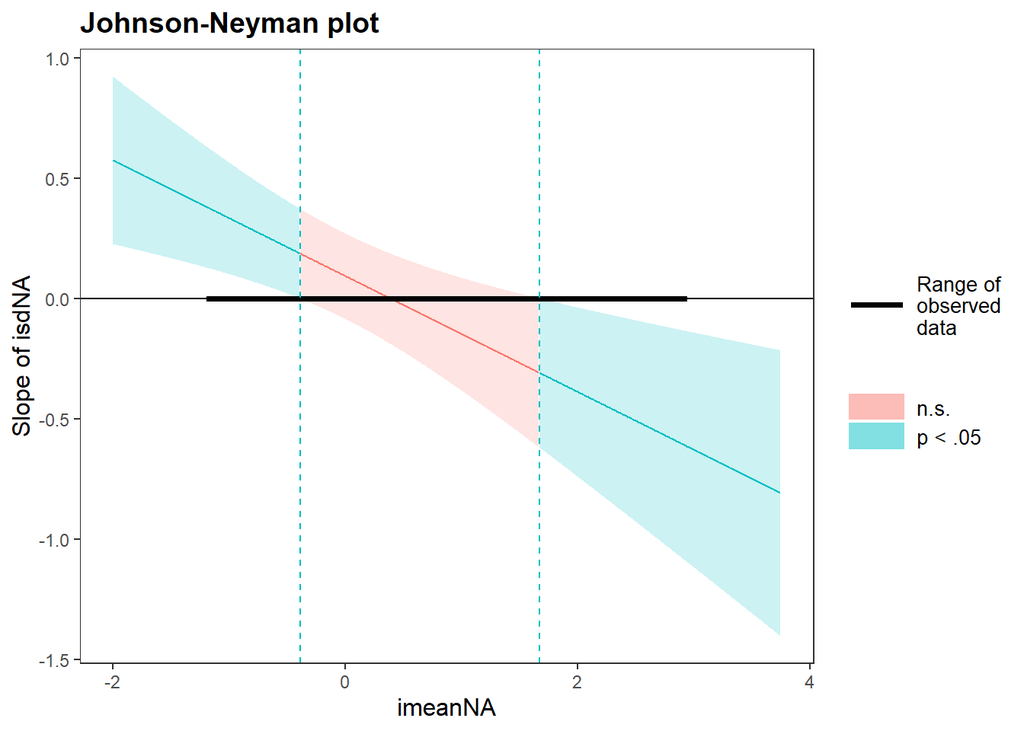

```r
#significant interaction effect. Following up with simple slope analyses
#Johnson Neyman
johnson_neyman(lm_Base_NA_SD_mod, pred=isdNA, modx=imeanNA, plot = TRUE) #plot
```

```r
#### RMSSD ####
lm_Base_NA_MSSD_mod<-lm(DepB ~ study_2 + study_3 + study_4 + study_5 + iMSSDNA + imeanNA + iMSSDNA:imeanNA + Age + Sex, data=mega_all_cen_std_5)
summ(lm_Base_NA_MSSD_mod,digits = getOption("jtools-digits", 3), vifs=TRUE)
```

| Observations | 1095 (12 missing obs. deleted) |
| --- | --- |
| Dependent variable | DepB |
| Type | OLS linear regression |

| F(9,1085) | 27.892 |
| --- | --- |
| R² | 0.188 |
| Adj. R² | 0.181 |

|  | Est. | S.E. | t val. | p | VIF |
| --- | --- | --- | --- | --- | --- |
| (Intercept) | -0.563 | 0.291 | -1.935 | 0.053 | NA |
| study_2 | -0.090 | 0.077 | -1.168 | 0.243 | 1.521 |
| study_3 | -0.379 | 0.167 | -2.267 | 0.024 | 6.145 |
| study_4 | -0.421 | 0.206 | -2.048 | 0.041 | 6.927 |
| study_5 | -0.103 | 0.122 | -0.840 | 0.401 | 1.169 |
| iMSSDNA | 0.155 | 0.073 | 2.122 | 0.034 | 1.558 |
| imeanNA | 0.460 | 0.042 | 10.855 | 0.000 | 1.641 |
| Age | 0.038 | 0.022 | 1.751 | 0.080 | 7.989 |
| Sex1 | 0.241 | 0.062 | 3.907 | 0.000 | 1.179 |
| iMSSDNA:imeanNA | -0.138 | 0.067 | -2.077 | 0.038 | 1.207 |

Standard errors: OLS

```r
summ(lm_Base_NA_MSSD_mod,digits = getOption("jtools-digits", 3), confint = TRUE,scale = TRUE, transform.response = TRUE)
```

| Observations | 1095 (12 missing obs. deleted) |
| --- | --- |
| Dependent variable | DepB |
| Type | OLS linear regression |

| F(9,1085) | 27.892 |
| --- | --- |
| R² | 0.188 |
| Adj. R² | 0.181 |

|  | Est. | 2.5% | 97.5% | t val. | p |
| --- | --- | --- | --- | --- | --- |
| (Intercept) | 0.046 | -0.122 | 0.214 | 0.540 | 0.589 |
| study_2 | -0.091 | -0.243 | 0.062 | -1.168 | 0.243 |
| study_3 | -0.380 | -0.708 | -0.051 | -2.267 | 0.024 |
| study_4 | -0.422 | -0.826 | -0.018 | -2.048 | 0.041 |
| study_5 | -0.103 | -0.343 | 0.138 | -0.840 | 0.401 |
| iMSSDNA | 0.072 | 0.005 | 0.139 | 2.115 | 0.035 |
| imeanNA | 0.380 | 0.311 | 0.449 | 10.858 | 0.000 |
| Age | 0.135 | -0.016 | 0.287 | 1.751 | 0.080 |
| Sex1 | 0.241 | 0.120 | 0.362 | 3.907 | 0.000 |
| iMSSDNA:imeanNA | -0.053 | -0.104 | -0.003 | -2.077 | 0.038 |

Standard errors: OLS; Continuous variables are mean-centered and scaled by 1 s.d.

```r
#incremental effect size Cohens f2
cohen_f2(lm_Base_NA_MSSD_main2, lm_Base_NA_MSSD_mod)
```

```
## [1] 0.003974699
```

```
## JOHNSON-NEYMAN INTERVAL
##
## When imeanNA is OUTSIDE the interval [0.09, 18.80], the slope of iMSSDNA is
## p < .05.
##
## Note: The range of observed values of imeanNA is [-1.17, 2.92]
```

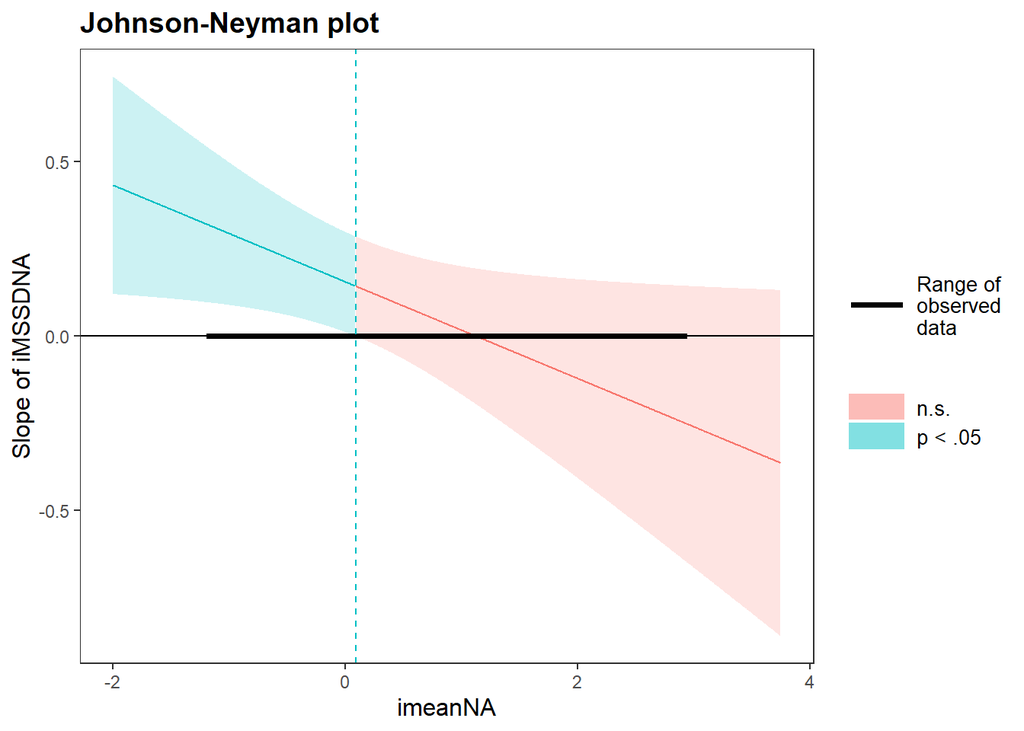

```r
#significant interaction effect. Following up with simple slope analyses
#Johnson Neyman
johnson_neyman(lm_Base_NA_MSSD_mod, pred=iMSSDNA, modx=imeanNA, plot = TRUE) #plot
```

```r
#The effect we see, as we saw for SD, is only partially applicable here. While we find that more NA instability
#is related to more depressive symptoms for low levels of NA, this relation does not exist if the mean of NA is average (in line with the results of SD)
#We do not find the reverse effect (i.e., that high instability is associated with fewer depressive symptoms for high levels of NA level)

#### Autocorrelation ####
lm_Base_NA_autocor_mod<-lm(DepB ~ study_2 + study_3 + study_4 + study_5 + autocorNA + imeanNA + autocorNA:imeanNA + Age + Sex, data=mega_all_cen_std_5)
summ(lm_Base_NA_autocor_mod,digits = getOption("jtools-digits", 3), vifs=TRUE)
```

| Observations | 1095 (12 missing obs. deleted) |
| --- | --- |
| Dependent variable | DepB |
| Type | OLS linear regression |

| F(9,1085) | 27.160 |
| --- | --- |
| R² | 0.184 |
| Adj. R² | 0.177 |

|  | Est. | S.E. | t val. | p | VIF |
| --- | --- | --- | --- | --- | --- |
| (Intercept) | -0.586 | 0.292 | -2.010 | 0.045 | NA |
| study_2 | -0.092 | 0.078 | -1.169 | 0.243 | 1.547 |
| study_3 | -0.365 | 0.167 | -2.181 | 0.029 | 6.110 |
| study_4 | -0.410 | 0.206 | -1.992 | 0.047 | 6.920 |
| study_5 | -0.101 | 0.123 | -0.823 | 0.411 | 1.169 |
| autocorNA | -0.161 | 0.252 | -0.640 | 0.522 | 1.423 |
| imeanNA | 0.524 | 0.042 | 12.516 | 0.000 | 1.592 |
| Age | 0.038 | 0.022 | 1.735 | 0.083 | 7.985 |
| Sex1 | 0.251 | 0.062 | 4.062 | 0.000 | 1.177 |
| autocorNA:imeanNA | -0.282 | 0.231 | -1.222 | 0.222 | 1.595 |

Standard errors: OLS

```r
summ(lm_Base_NA_autocor_mod,digits = getOption("jtools-digits", 3), confint = TRUE,scale = TRUE, transform.response = TRUE)
```

| Observations | 1095 (12 missing obs. deleted) |
| --- | --- |
| Dependent variable | DepB |
| Type | OLS linear regression |

| F(9,1085) | 27.160 |
| --- | --- |
| R² | 0.184 |
| Adj. R² | 0.177 |

|  | Est. | 2.5% | 97.5% | t val. | p |
| --- | --- | --- | --- | --- | --- |
| (Intercept) | 0.019 | -0.147 | 0.185 | 0.224 | 0.823 |
| study_2 | -0.092 | -0.246 | 0.062 | -1.169 | 0.243 |
| study_3 | -0.365 | -0.694 | -0.037 | -2.181 | 0.029 |
| study_4 | -0.411 | -0.816 | -0.006 | -1.992 | 0.047 |
| study_5 | -0.101 | -0.342 | 0.140 | -0.823 | 0.411 |
| autocorNA | -0.021 | -0.085 | 0.043 | -0.646 | 0.519 |
| imeanNA | 0.433 | 0.365 | 0.501 | 12.523 | 0.000 |
| Age | 0.134 | -0.018 | 0.287 | 1.735 | 0.083 |
| Sex1 | 0.251 | 0.130 | 0.372 | 4.062 | 0.000 |
| autocorNA:imeanNA | -0.030 | -0.079 | 0.018 | -1.222 | 0.222 |

Standard errors: OLS; Continuous variables are mean-centered and scaled by 1 s.d.

##### 9.2.2.2.2 Follow-up Depression

Studies with available data:

- Dataset 1: RADAR
- Dataset 2: Swinging Moods
- Dataset 3: Mood in Emerging Adults

###### 9.2.2.2.2.1 Model 1: Main effects without controlling for affect level

```r
#### Standard Deviation ####
lm_FU_NA_SD_main1<-lm(DepF ~ DepB + study_2 + study_3 + isdNA + Age + Sex, data=mega_all_cen_std_3)
summ(lm_FU_NA_SD_main1,digits = getOption("jtools-digits", 3), vifs=TRUE)
```

| Observations | 718 (165 missing obs. deleted) |
| --- | --- |
| Dependent variable | DepF |
| Type | OLS linear regression |

| F(6,711) | 40.004 |
| --- | --- |
| R² | 0.252 |
| Adj. R² | 0.246 |

|  | Est. | S.E. | t val. | p | VIF |
| --- | --- | --- | --- | --- | --- |
| (Intercept) | -0.119 | 0.477 | -0.249 | 0.804 | NA |
| DepB | 0.406 | 0.035 | 11.510 | 0.000 | 1.111 |
| study_2 | -0.066 | 0.093 | -0.714 | 0.476 | 1.536 |
| study_3 | -0.116 | 0.253 | -0.459 | 0.647 | 12.514 |
| isdNA | 0.430 | 0.080 | 5.410 | 0.000 | 1.094 |
| Age | 0.003 | 0.036 | 0.095 | 0.924 | 10.890 |
| Sex1 | 0.208 | 0.075 | 2.781 | 0.006 | 1.253 |

Standard errors: OLS

```r
summ(lm_FU_NA_SD_main1,digits = getOption("jtools-digits", 3), confint = TRUE,scale = TRUE, transform.response = TRUE)
```

| Observations | 718 (165 missing obs. deleted) |
| --- | --- |
| Dependent variable | DepF |
| Type | OLS linear regression |

| F(6,711) | 40.004 |
| --- | --- |
| R² | 0.252 |
| Adj. R² | 0.246 |

|  | Est. | 2.5% | 97.5% | t val. | p |
| --- | --- | --- | --- | --- | --- |
| (Intercept) | -0.079 | -0.268 | 0.110 | -0.820 | 0.413 |
| DepB | 0.393 | 0.326 | 0.460 | 11.510 | 0.000 |
| study_2 | -0.066 | -0.248 | 0.116 | -0.714 | 0.476 |
| study_3 | -0.116 | -0.613 | 0.381 | -0.459 | 0.647 |
| isdNA | 0.184 | 0.117 | 0.250 | 5.410 | 0.000 |
| Age | 0.010 | -0.200 | 0.220 | 0.095 | 0.924 |
| Sex1 | 0.208 | 0.061 | 0.355 | 2.781 | 0.006 |

Standard errors: OLS; Continuous variables are mean-centered and scaled by 1 s.d.

```r
#### RMSSD ####
lm_FU_NA_MSSD_main1<-lm(DepF ~ DepB + study_2 + study_3 + iMSSDNA + Age + Sex, data=mega_all_cen_std_3)
summ(lm_FU_NA_MSSD_main1,digits = getOption("jtools-digits", 3), vifs=TRUE)
```

| Observations | 718 (165 missing obs. deleted) |
| --- | --- |
| Dependent variable | DepF |
| Type | OLS linear regression |

| F(6,711) | 39.800 |
| --- | --- |
| R² | 0.251 |
| Adj. R² | 0.245 |

|  | Est. | S.E. | t val. | p | VIF |
| --- | --- | --- | --- | --- | --- |
| (Intercept) | -0.123 | 0.477 | -0.258 | 0.796 | NA |
| DepB | 0.413 | 0.035 | 11.769 | 0.000 | 1.094 |
| study_2 | -0.067 | 0.093 | -0.723 | 0.470 | 1.536 |
| study_3 | -0.117 | 0.254 | -0.463 | 0.643 | 12.513 |
| iMSSDNA | 0.387 | 0.073 | 5.321 | 0.000 | 1.074 |
| Age | 0.004 | 0.036 | 0.099 | 0.921 | 10.891 |
| Sex1 | 0.213 | 0.075 | 2.848 | 0.005 | 1.250 |

Standard errors: OLS

```r
summ(lm_FU_NA_MSSD_main1,digits = getOption("jtools-digits", 3), confint = TRUE,scale = TRUE, transform.response = TRUE)
```

| Observations | 718 (165 missing obs. deleted) |
| --- | --- |
| Dependent variable | DepF |
| Type | OLS linear regression |

| F(6,711) | 39.800 |
| --- | --- |
| R² | 0.251 |
| Adj. R² | 0.245 |

|  | Est. | 2.5% | 97.5% | t val. | p |
| --- | --- | --- | --- | --- | --- |
| (Intercept) | -0.082 | -0.271 | 0.108 | -0.846 | 0.398 |
| DepB | 0.400 | 0.333 | 0.466 | 11.769 | 0.000 |
| study_2 | -0.067 | -0.249 | 0.115 | -0.723 | 0.470 |
| study_3 | -0.117 | -0.614 | 0.380 | -0.463 | 0.643 |
| iMSSDNA | 0.179 | 0.113 | 0.245 | 5.321 | 0.000 |
| Age | 0.011 | -0.200 | 0.221 | 0.099 | 0.921 |
| Sex1 | 0.213 | 0.066 | 0.360 | 2.848 | 0.005 |

Standard errors: OLS; Continuous variables are mean-centered and scaled by 1 s.d.

```r
#### Autocorrelation ####
lm_FU_NA_autocor_main1<-lm(DepF ~ DepB + study_2 + study_3 + autocorNA + Age + Sex, data=mega_all_cen_std_3)
summ(lm_FU_NA_autocor_main1,digits = getOption("jtools-digits", 3), vifs=TRUE)
```

| Observations | 718 (165 missing obs. deleted) |
| --- | --- |
| Dependent variable | DepF |
| Type | OLS linear regression |

| F(6,711) | 34.277 |
| --- | --- |
| R² | 0.224 |
| Adj. R² | 0.218 |

|  | Est. | S.E. | t val. | p | VIF |
| --- | --- | --- | --- | --- | --- |
| (Intercept) | -0.100 | 0.486 | -0.205 | 0.838 | NA |
| DepB | 0.448 | 0.035 | 12.763 | 0.000 | 1.060 |
| study_2 | -0.085 | 0.094 | -0.899 | 0.369 | 1.534 |
| study_3 | -0.119 | 0.258 | -0.460 | 0.646 | 12.516 |
| autocorNA | 0.392 | 0.247 | 1.588 | 0.113 | 1.029 |
| Age | 0.001 | 0.037 | 0.024 | 0.981 | 10.894 |
| Sex1 | 0.243 | 0.076 | 3.199 | 0.001 | 1.244 |

Standard errors: OLS

```r
summ(lm_FU_NA_autocor_main1,digits = getOption("jtools-digits", 3), confint = TRUE,scale = TRUE, transform.response = TRUE)
```

| Observations | 718 (165 missing obs. deleted) |
| --- | --- |
| Dependent variable | DepF |
| Type | OLS linear regression |

| F(6,711) | 34.277 |
| --- | --- |
| R² | 0.224 |
| Adj. R² | 0.218 |

|  | Est. | 2.5% | 97.5% | t val. | p |
| --- | --- | --- | --- | --- | --- |
| (Intercept) | -0.095 | -0.288 | 0.097 | -0.971 | 0.332 |
| DepB | 0.434 | 0.367 | 0.501 | 12.763 | 0.000 |
| study_2 | -0.085 | -0.270 | 0.100 | -0.899 | 0.369 |
| study_3 | -0.119 | -0.625 | 0.388 | -0.460 | 0.646 |
| autocorNA | 0.053 | -0.013 | 0.119 | 1.588 | 0.113 |
| Age | 0.003 | -0.211 | 0.217 | 0.024 | 0.981 |
| Sex1 | 0.243 | 0.094 | 0.392 | 3.199 | 0.001 |

Standard errors: OLS; Continuous variables are mean-centered and scaled by 1 s.d.

###### 9.2.2.2.2.2 Model 2: Main effects with controlling for affect level

```r
#### Standard Deviation ####
lm_FU_NA_SD_main2<-lm(DepF ~ DepB + study_2 + study_3 + isdNA + imeanNA + Age + Sex, data=mega_all_cen_std_3)
summ(lm_FU_NA_SD_main2,digits = getOption("jtools-digits", 3), vifs=TRUE)
```

| Observations | 718 (165 missing obs. deleted) |
| --- | --- |
| Dependent variable | DepF |
| Type | OLS linear regression |

| F(7,710) | 36.828 |
| --- | --- |
| R² | 0.266 |
| Adj. R² | 0.259 |

|  | Est. | S.E. | t val. | p | VIF |
| --- | --- | --- | --- | --- | --- |
| (Intercept) | -0.074 | 0.473 | -0.157 | 0.875 | NA |
| DepB | 0.371 | 0.036 | 10.203 | 0.000 | 1.197 |
| study_2 | -0.057 | 0.092 | -0.624 | 0.533 | 1.537 |
| study_3 | -0.088 | 0.251 | -0.352 | 0.725 | 12.525 |
| isdNA | 0.179 | 0.104 | 1.721 | 0.086 | 1.913 |
| imeanNA | 0.203 | 0.055 | 3.679 | 0.000 | 2.054 |
| Age | -0.000 | 0.036 | -0.005 | 0.996 | 10.899 |
| Sex1 | 0.210 | 0.074 | 2.825 | 0.005 | 1.253 |

Standard errors: OLS

```r
summ(lm_FU_NA_SD_main2,digits = getOption("jtools-digits", 3), confint = TRUE,scale = TRUE, transform.response = TRUE)
```

| Observations | 718 (165 missing obs. deleted) |
| --- | --- |
| Dependent variable | DepF |
| Type | OLS linear regression |

| F(7,710) | 36.828 |
| --- | --- |
| R² | 0.266 |
| Adj. R² | 0.259 |

|  | Est. | 2.5% | 97.5% | t val. | p |
| --- | --- | --- | --- | --- | --- |
| (Intercept) | -0.090 | -0.278 | 0.098 | -0.943 | 0.346 |
| DepB | 0.359 | 0.290 | 0.428 | 10.203 | 0.000 |
| study_2 | -0.057 | -0.237 | 0.123 | -0.624 | 0.533 |
| study_3 | -0.088 | -0.581 | 0.404 | -0.352 | 0.725 |
| isdNA | 0.076 | -0.011 | 0.164 | 1.721 | 0.086 |
| imeanNA | 0.170 | 0.079 | 0.260 | 3.679 | 0.000 |
| Age | -0.001 | -0.209 | 0.208 | -0.005 | 0.996 |
| Sex1 | 0.209 | 0.064 | 0.355 | 2.825 | 0.005 |

Standard errors: OLS; Continuous variables are mean-centered and scaled by 1 s.d.

```r
#### RMSSD ####
lm_FU_NA_MSSD_main2<-lm(DepF ~ DepB + study_2 + study_3 + iMSSDNA + imeanNA + Age + Sex, data=mega_all_cen_std_3)
summ(lm_FU_NA_MSSD_main2,digits = getOption("jtools-digits", 3), vifs=TRUE)
```

| Observations | 718 (165 missing obs. deleted) |
| --- | --- |
| Dependent variable | DepF |
| Type | OLS linear regression |

| F(7,710) | 37.283 |
| --- | --- |
| R² | 0.269 |
| Adj. R² | 0.262 |

|  | Est. | S.E. | t val. | p | VIF |
| --- | --- | --- | --- | --- | --- |
| (Intercept) | -0.077 | 0.472 | -0.163 | 0.871 | NA |
| DepB | 0.369 | 0.036 | 10.172 | 0.000 | 1.197 |
| study_2 | -0.056 | 0.092 | -0.607 | 0.544 | 1.538 |
| study_3 | -0.088 | 0.251 | -0.351 | 0.725 | 12.523 |
| iMSSDNA | 0.197 | 0.085 | 2.303 | 0.022 | 1.519 |
| imeanNA | 0.203 | 0.050 | 4.105 | 0.000 | 1.661 |
| Age | 0.000 | 0.036 | 0.000 | 1.000 | 10.897 |
| Sex1 | 0.209 | 0.074 | 2.824 | 0.005 | 1.251 |

Standard errors: OLS

```r
summ(lm_FU_NA_MSSD_main2,digits = getOption("jtools-digits", 3), confint = TRUE,scale = TRUE, transform.response = TRUE)
```

| Observations | 718 (165 missing obs. deleted) |
| --- | --- |
| Dependent variable | DepF |
| Type | OLS linear regression |

| F(7,710) | 37.283 |
| --- | --- |
| R² | 0.269 |
| Adj. R² | 0.262 |

|  | Est. | 2.5% | 97.5% | t val. | p |
| --- | --- | --- | --- | --- | --- |
| (Intercept) | -0.090 | -0.278 | 0.097 | -0.946 | 0.344 |
| DepB | 0.357 | 0.288 | 0.426 | 10.172 | 0.000 |
| study_2 | -0.056 | -0.235 | 0.124 | -0.607 | 0.544 |
| study_3 | -0.088 | -0.580 | 0.404 | -0.351 | 0.725 |
| iMSSDNA | 0.091 | 0.013 | 0.169 | 2.303 | 0.022 |
| imeanNA | 0.170 | 0.089 | 0.251 | 4.105 | 0.000 |
| Age | 0.000 | -0.208 | 0.208 | 0.000 | 1.000 |
| Sex1 | 0.209 | 0.064 | 0.354 | 2.824 | 0.005 |

Standard errors: OLS; Continuous variables are mean-centered and scaled by 1 s.d.

```r
#### Autocorrelation ####
lm_FU_NA_autocor_main2<-lm(DepF ~ DepB + study_2 + study_3 + autocorNA + imeanNA + Age + Sex, data=mega_all_cen_std_3)
summ(lm_FU_NA_autocor_main2,digits = getOption("jtools-digits", 3), vifs=TRUE)
```

| Observations | 718 (165 missing obs. deleted) |
| --- | --- |
| Dependent variable | DepF |
| Type | OLS linear regression |

| F(7,710) | 36.755 |
| --- | --- |
| R² | 0.266 |
| Adj. R² | 0.259 |

|  | Est. | S.E. | t val. | p | VIF |
| --- | --- | --- | --- | --- | --- |
| (Intercept) | -0.069 | 0.473 | -0.145 | 0.885 | NA |
| DepB | 0.370 | 0.036 | 10.185 | 0.000 | 1.197 |
| study_2 | -0.060 | 0.092 | -0.658 | 0.511 | 1.537 |
| study_3 | -0.084 | 0.251 | -0.333 | 0.739 | 12.522 |
| autocorNA | -0.440 | 0.273 | -1.608 | 0.108 | 1.335 |
| imeanNA | 0.302 | 0.048 | 6.346 | 0.000 | 1.525 |
| Age | -0.001 | 0.036 | -0.022 | 0.983 | 10.895 |
| Sex1 | 0.213 | 0.074 | 2.879 | 0.004 | 1.249 |

Standard errors: OLS

```r
summ(lm_FU_NA_autocor_main2,digits = getOption("jtools-digits", 3), confint = TRUE,scale = TRUE, transform.response = TRUE)
```

| Observations | 718 (165 missing obs. deleted) |
| --- | --- |
| Dependent variable | DepF |
| Type | OLS linear regression |

| F(7,710) | 36.755 |
| --- | --- |
| R² | 0.266 |
| Adj. R² | 0.259 |

|  | Est. | 2.5% | 97.5% | t val. | p |
| --- | --- | --- | --- | --- | --- |
| (Intercept) | -0.093 | -0.281 | 0.095 | -0.974 | 0.330 |
| DepB | 0.358 | 0.289 | 0.427 | 10.185 | 0.000 |
| study_2 | -0.060 | -0.240 | 0.120 | -0.658 | 0.511 |
| study_3 | -0.084 | -0.576 | 0.409 | -0.333 | 0.739 |
| autocorNA | -0.060 | -0.133 | 0.013 | -1.608 | 0.108 |
| imeanNA | 0.252 | 0.174 | 0.330 | 6.346 | 0.000 |
| Age | -0.002 | -0.211 | 0.206 | -0.022 | 0.983 |
| Sex1 | 0.213 | 0.068 | 0.358 | 2.879 | 0.004 |

Standard errors: OLS; Continuous variables are mean-centered and scaled by 1 s.d.

###### 9.2.2.2.2.3 Model 3: Interaction effects affective dynamics and level

```r
#### Standard Deviation ####
lm_FU_NA_SD_mod<-lm(DepF ~ DepB +  study_2 + study_3 + isdNA + imeanNA + isdNA:imeanNA + Age + Sex, data=mega_all_cen_std_3)
summ(lm_FU_NA_SD_mod,digits = getOption("jtools-digits", 3), vifs=TRUE)
```

| Observations | 718 (165 missing obs. deleted) |
| --- | --- |
| Dependent variable | DepF |
| Type | OLS linear regression |

| F(8,709) | 32.195 |
| --- | --- |
| R² | 0.266 |
| Adj. R² | 0.258 |

|  | Est. | S.E. | t val. | p | VIF |
| --- | --- | --- | --- | --- | --- |
| (Intercept) | -0.067 | 0.474 | -0.141 | 0.888 | NA |
| DepB | 0.369 | 0.037 | 10.101 | 0.000 | 1.211 |
| study_2 | -0.063 | 0.094 | -0.673 | 0.501 | 1.601 |
| study_3 | -0.096 | 0.252 | -0.378 | 0.705 | 12.628 |
| isdNA | 0.179 | 0.104 | 1.719 | 0.086 | 1.913 |
| imeanNA | 0.209 | 0.058 | 3.580 | 0.000 | 2.293 |
| Age | 0.000 | 0.036 | 0.001 | 0.999 | 10.903 |
| Sex1 | 0.209 | 0.074 | 2.821 | 0.005 | 1.253 |
| isdNA:imeanNA | -0.028 | 0.089 | -0.309 | 0.758 | 1.296 |

Standard errors: OLS

```r
summ(lm_FU_NA_SD_mod,digits = getOption("jtools-digits", 3), confint = TRUE,scale = TRUE, transform.response = TRUE)
```

| Observations | 718 (165 missing obs. deleted) |
| --- | --- |
| Dependent variable | DepF |
| Type | OLS linear regression |

| F(8,709) | 32.195 |
| --- | --- |
| R² | 0.266 |
| Adj. R² | 0.258 |

|  | Est. | 2.5% | 97.5% | t val. | p |
| --- | --- | --- | --- | --- | --- |
| (Intercept) | -0.080 | -0.279 | 0.119 | -0.788 | 0.431 |
| DepB | 0.358 | 0.288 | 0.427 | 10.101 | 0.000 |
| study_2 | -0.063 | -0.247 | 0.121 | -0.673 | 0.501 |
| study_3 | -0.095 | -0.590 | 0.400 | -0.378 | 0.705 |
| isdNA | 0.077 | -0.011 | 0.164 | 1.724 | 0.085 |
| imeanNA | 0.175 | 0.078 | 0.271 | 3.566 | 0.000 |
| Age | 0.000 | -0.208 | 0.209 | 0.001 | 0.999 |
| Sex1 | 0.209 | 0.064 | 0.355 | 2.821 | 0.005 |
| isdNA:imeanNA | -0.010 | -0.072 | 0.053 | -0.309 | 0.758 |

Standard errors: OLS; Continuous variables are mean-centered and scaled by 1 s.d.

```r
#### RMSSD ####
lm_FU_NA_MSSD_mod<-lm(DepF ~ DepB +  study_2 + study_3 + iMSSDNA + imeanNA + iMSSDNA:imeanNA + Age + Sex, data=mega_all_cen_std_3)
summ(lm_FU_NA_MSSD_mod,digits = getOption("jtools-digits", 3), vifs=TRUE)
```

| Observations | 718 (165 missing obs. deleted) |
| --- | --- |
| Dependent variable | DepF |
| Type | OLS linear regression |

| F(8,709) | 32.637 |
| --- | --- |
| R² | 0.269 |
| Adj. R² | 0.261 |

|  | Est. | S.E. | t val. | p | VIF |
| --- | --- | --- | --- | --- | --- |
| (Intercept) | -0.066 | 0.472 | -0.140 | 0.889 | NA |
| DepB | 0.368 | 0.036 | 10.103 | 0.000 | 1.203 |
| study_2 | -0.063 | 0.093 | -0.683 | 0.495 | 1.567 |
| study_3 | -0.098 | 0.252 | -0.391 | 0.696 | 12.581 |
| iMSSDNA | 0.203 | 0.086 | 2.357 | 0.019 | 1.540 |
| imeanNA | 0.209 | 0.051 | 4.142 | 0.000 | 1.725 |
| Age | 0.000 | 0.036 | 0.011 | 0.991 | 10.900 |
| Sex1 | 0.207 | 0.074 | 2.796 | 0.005 | 1.253 |
| iMSSDNA:imeanNA | -0.047 | 0.079 | -0.597 | 0.551 | 1.162 |

Standard errors: OLS

```r
summ(lm_FU_NA_MSSD_mod,digits = getOption("jtools-digits", 3), confint = TRUE,scale = TRUE, transform.response = TRUE)
```

| Observations | 718 (165 missing obs. deleted) |
| --- | --- |
| Dependent variable | DepF |
| Type | OLS linear regression |

| F(8,709) | 32.637 |
| --- | --- |
| R² | 0.269 |
| Adj. R² | 0.261 |

|  | Est. | 2.5% | 97.5% | t val. | p |
| --- | --- | --- | --- | --- | --- |
| (Intercept) | -0.074 | -0.269 | 0.121 | -0.743 | 0.458 |
| DepB | 0.356 | 0.287 | 0.425 | 10.103 | 0.000 |
| study_2 | -0.063 | -0.245 | 0.118 | -0.683 | 0.495 |
| study_3 | -0.098 | -0.591 | 0.395 | -0.391 | 0.696 |
| iMSSDNA | 0.094 | 0.016 | 0.173 | 2.361 | 0.018 |
| imeanNA | 0.175 | 0.092 | 0.258 | 4.138 | 0.000 |
| Age | 0.001 | -0.207 | 0.209 | 0.011 | 0.991 |
| Sex1 | 0.207 | 0.062 | 0.352 | 2.796 | 0.005 |
| iMSSDNA:imeanNA | -0.018 | -0.078 | 0.042 | -0.597 | 0.551 |

Standard errors: OLS; Continuous variables are mean-centered and scaled by 1 s.d.

```r
#### Autocorrelation ####
lm_FU_NA_autocor_mod<-lm(DepF ~ DepB + study_2 + study_3 + autocorNA + imeanNA + autocorNA:imeanNA + Age + Sex, data=mega_all_cen_std_3)
summ(lm_FU_NA_autocor_mod,digits = getOption("jtools-digits", 3), vifs=TRUE)
```

| Observations | 718 (165 missing obs. deleted) |
| --- | --- |
| Dependent variable | DepF |
| Type | OLS linear regression |

| F(8,709) | 32.220 |
| --- | --- |
| R² | 0.267 |
| Adj. R² | 0.258 |

|  | Est. | S.E. | t val. | p | VIF |
| --- | --- | --- | --- | --- | --- |
| (Intercept) | -0.064 | 0.473 | -0.136 | 0.892 | NA |
| DepB | 0.369 | 0.036 | 10.120 | 0.000 | 1.201 |
| study_2 | -0.070 | 0.093 | -0.752 | 0.452 | 1.563 |
| study_3 | -0.094 | 0.252 | -0.372 | 0.710 | 12.554 |
| autocorNA | -0.385 | 0.282 | -1.363 | 0.173 | 1.422 |
| imeanNA | 0.317 | 0.052 | 6.153 | 0.000 | 1.793 |
| Age | -0.000 | 0.036 | -0.003 | 0.998 | 10.901 |
| Sex1 | 0.217 | 0.074 | 2.918 | 0.004 | 1.253 |
| autocorNA:imeanNA | -0.199 | 0.255 | -0.782 | 0.434 | 1.511 |

Standard errors: OLS

```r
summ(lm_FU_NA_autocor_mod,digits = getOption("jtools-digits", 3), confint = TRUE,scale = TRUE, transform.response = TRUE)
```

| Observations | 718 (165 missing obs. deleted) |
| --- | --- |
| Dependent variable | DepF |
| Type | OLS linear regression |

| F(8,709) | 32.220 |
| --- | --- |
| R² | 0.267 |
| Adj. R² | 0.258 |

|  | Est. | 2.5% | 97.5% | t val. | p |
| --- | --- | --- | --- | --- | --- |
| (Intercept) | -0.079 | -0.270 | 0.112 | -0.808 | 0.419 |
| DepB | 0.357 | 0.287 | 0.426 | 10.120 | 0.000 |
| study_2 | -0.070 | -0.251 | 0.112 | -0.752 | 0.452 |
| study_3 | -0.093 | -0.587 | 0.400 | -0.372 | 0.710 |
| autocorNA | -0.052 | -0.127 | 0.024 | -1.347 | 0.178 |
| imeanNA | 0.265 | 0.180 | 0.350 | 6.146 | 0.000 |
| Age | -0.000 | -0.209 | 0.208 | -0.003 | 0.998 |
| Sex1 | 0.216 | 0.071 | 0.362 | 2.918 | 0.004 |
| autocorNA:imeanNA | -0.023 | -0.079 | 0.034 | -0.782 | 0.434 |

Standard errors: OLS; Continuous variables are mean-centered and scaled by 1 s.d.

# 10 EXTRA ANALYSES

In July 2023, we added the following analyses after reviews.

## 10.1 Relative SD

The reviewer was concerned about the known confounding between the SD and the mean and was wondering whether the main result of the interaction holds when with the relative SD. To address this comment, we repeated the main model with the relative SD, following the procedures of Mestdagh et al. (2018).

```r
# Model 1: Main effect of inertia and variability
lm_Base_NA_SDAR_main1_rel<-lm(DepB ~ study_2 + study_3 + study_4 + study_5 + relisdNA + autocorNA + Age + Sex, data=mega_all_cen_std_5)
summ(lm_Base_NA_SDAR_main1_rel,digits = getOption("jtools-digits", 3), vifs=TRUE)
```

| Observations | 1095 (12 missing obs. deleted) |
| --- | --- |
| Dependent variable | DepB |
| Type | OLS linear regression |

| F(8,1086) | 8.229 |
| --- | --- |
| R² | 0.057 |
| Adj. R² | 0.050 |

|  | Est. | S.E. | t val. | p | VIF |
| --- | --- | --- | --- | --- | --- |
| (Intercept) | -0.636 | 0.313 | -2.030 | 0.043 | NA |
| study_2 | -0.088 | 0.083 | -1.054 | 0.292 | 1.507 |
| study_3 | -0.395 | 0.179 | -2.201 | 0.028 | 6.097 |
| study_4 | -0.420 | 0.221 | -1.905 | 0.057 | 6.871 |
| study_5 | -0.121 | 0.132 | -0.921 | 0.357 | 1.168 |
| relisdNA | -0.556 | 0.228 | -2.442 | 0.015 | 1.004 |
| autocorNA | 1.268 | 0.227 | 5.586 | 0.000 | 1.004 |
| Age | 0.038 | 0.024 | 1.608 | 0.108 | 7.981 |
| Sex1 | 0.325 | 0.066 | 4.929 | 0.000 | 1.167 |

Standard errors: OLS

```r
summ(lm_Base_NA_SDAR_main1_rel,digits = getOption("jtools-digits", 3), confint = TRUE,scale = TRUE, transform.response = TRUE)
```

| Observations | 1095 (12 missing obs. deleted) |
| --- | --- |
| Dependent variable | DepB |
| Type | OLS linear regression |

| F(8,1086) | 8.229 |
| --- | --- |
| R² | 0.057 |
| Adj. R² | 0.050 |

|  | Est. | 2.5% | 97.5% | t val. | p |
| --- | --- | --- | --- | --- | --- |
| (Intercept) | -0.035 | -0.210 | 0.139 | -0.399 | 0.690 |
| study_2 | -0.088 | -0.251 | 0.076 | -1.054 | 0.292 |
| study_3 | -0.396 | -0.748 | -0.043 | -2.201 | 0.028 |
| study_4 | -0.421 | -0.854 | 0.013 | -1.905 | 0.057 |
| study_5 | -0.122 | -0.380 | 0.137 | -0.921 | 0.357 |
| relisdNA | -0.072 | -0.130 | -0.014 | -2.442 | 0.015 |
| autocorNA | 0.165 | 0.107 | 0.223 | 5.586 | 0.000 |
| Age | 0.134 | -0.029 | 0.297 | 1.608 | 0.108 |
| Sex1 | 0.326 | 0.196 | 0.455 | 4.929 | 0.000 |

Standard errors: OLS; Continuous variables are mean-centered and scaled by 1 s.d.

```r
# Model 2: Controlling for Level
lm_Base_NA_SDAR_main2_rel<-lm(DepB ~ study_2 + study_3 + study_4 + study_5 + relisdNA + autocorNA + imeanNA + Age + Sex, data=mega_all_cen_std_5)
summ(lm_Base_NA_SDAR_main2_rel,digits = getOption("jtools-digits", 3), vifs=TRUE)
```

| Observations | 1095 (12 missing obs. deleted) |
| --- | --- |
| Dependent variable | DepB |
| Type | OLS linear regression |

| F(9,1085) | 27.079 |
| --- | --- |
| R² | 0.183 |
| Adj. R² | 0.177 |

|  | Est. | S.E. | t val. | p | VIF |
| --- | --- | --- | --- | --- | --- |
| (Intercept) | -0.602 | 0.292 | -2.065 | 0.039 | NA |
| study_2 | -0.077 | 0.077 | -0.990 | 0.322 | 1.507 |
| study_3 | -0.358 | 0.167 | -2.142 | 0.032 | 6.099 |
| study_4 | -0.392 | 0.205 | -1.911 | 0.056 | 6.872 |
| study_5 | -0.099 | 0.123 | -0.807 | 0.420 | 1.169 |
| relisdNA | -0.203 | 0.214 | -0.948 | 0.343 | 1.021 |
| autocorNA | -0.245 | 0.241 | -1.014 | 0.311 | 1.311 |
| imeanNA | 0.498 | 0.038 | 12.953 | 0.000 | 1.343 |
| Age | 0.038 | 0.022 | 1.717 | 0.086 | 7.981 |
| Sex1 | 0.251 | 0.062 | 4.061 | 0.000 | 1.177 |

Standard errors: OLS

```r
summ(lm_Base_NA_SDAR_main2_rel,digits = getOption("jtools-digits", 3), confint = TRUE,scale = TRUE, transform.response = TRUE)
```

| Observations | 1095 (12 missing obs. deleted) |
| --- | --- |
| Dependent variable | DepB |
| Type | OLS linear regression |

| F(9,1085) | 27.079 |
| --- | --- |
| R² | 0.183 |
| Adj. R² | 0.177 |

|  | Est. | 2.5% | 97.5% | t val. | p |
| --- | --- | --- | --- | --- | --- |
| (Intercept) | -0.004 | -0.166 | 0.158 | -0.045 | 0.964 |
| study_2 | -0.077 | -0.229 | 0.075 | -0.990 | 0.322 |
| study_3 | -0.358 | -0.687 | -0.030 | -2.142 | 0.032 |
| study_4 | -0.393 | -0.797 | 0.011 | -1.911 | 0.056 |
| study_5 | -0.099 | -0.340 | 0.142 | -0.807 | 0.420 |
| relisdNA | -0.026 | -0.081 | 0.028 | -0.948 | 0.343 |
| autocorNA | -0.032 | -0.093 | 0.030 | -1.014 | 0.311 |
| imeanNA | 0.412 | 0.349 | 0.474 | 12.953 | 0.000 |
| Age | 0.133 | -0.019 | 0.285 | 1.717 | 0.086 |
| Sex1 | 0.251 | 0.130 | 0.372 | 4.061 | 0.000 |

Standard errors: OLS; Continuous variables are mean-centered and scaled by 1 s.d.

```r
# Model 3: Interaction
lm_Base_NA_SDAR_mod_rel<-lm(DepB ~ study_2 + study_3 + study_4 + study_5 + relisdNA + autocorNA + imeanNA + relisdNA:imeanNA + autocorNA:imeanNA + Age + Sex, data=mega_all_cen_std_5)
summ(lm_Base_NA_SDAR_mod_rel,digits = getOption("jtools-digits", 3), vifs=TRUE)
```

| Observations | 1095 (12 missing obs. deleted) |
| --- | --- |
| Dependent variable | DepB |
| Type | OLS linear regression |

| F(11,1083) | 22.398 |
| --- | --- |
| R² | 0.185 |
| Adj. R² | 0.177 |

|  | Est. | S.E. | t val. | p | VIF |
| --- | --- | --- | --- | --- | --- |
| (Intercept) | -0.594 | 0.292 | -2.038 | 0.042 | NA |
| study_2 | -0.088 | 0.078 | -1.128 | 0.259 | 1.550 |
| study_3 | -0.366 | 0.167 | -2.187 | 0.029 | 6.113 |
| study_4 | -0.409 | 0.206 | -1.986 | 0.047 | 6.923 |
| study_5 | -0.097 | 0.123 | -0.791 | 0.429 | 1.170 |
| relisdNA | -0.261 | 0.223 | -1.169 | 0.243 | 1.111 |
| autocorNA | -0.165 | 0.252 | -0.657 | 0.512 | 1.423 |
| imeanNA | 0.519 | 0.042 | 12.297 | 0.000 | 1.620 |
| Age | 0.038 | 0.022 | 1.742 | 0.082 | 7.987 |
| Sex1 | 0.253 | 0.062 | 4.106 | 0.000 | 1.178 |
| relisdNA:imeanNA | -0.279 | 0.262 | -1.064 | 0.287 | 1.110 |
| autocorNA:imeanNA | -0.302 | 0.233 | -1.298 | 0.195 | 1.617 |

Standard errors: OLS

```r
summ(lm_Base_NA_SDAR_mod_rel,digits = getOption("jtools-digits", 3), confint = TRUE,scale = TRUE, transform.response = TRUE)
```

| Observations | 1095 (12 missing obs. deleted) |
| --- | --- |
| Dependent variable | DepB |
| Type | OLS linear regression |

| F(11,1083) | 22.398 |
| --- | --- |
| R² | 0.185 |
| Adj. R² | 0.177 |

|  | Est. | 2.5% | 97.5% | t val. | p |
| --- | --- | --- | --- | --- | --- |
| (Intercept) | 0.013 | -0.153 | 0.179 | 0.154 | 0.878 |
| study_2 | -0.089 | -0.243 | 0.065 | -1.128 | 0.259 |
| study_3 | -0.366 | -0.695 | -0.038 | -2.187 | 0.029 |
| study_4 | -0.410 | -0.815 | -0.005 | -1.986 | 0.047 |
| study_5 | -0.097 | -0.338 | 0.144 | -0.791 | 0.429 |
| relisdNA | -0.034 | -0.091 | 0.023 | -1.173 | 0.241 |
| autocorNA | -0.022 | -0.086 | 0.042 | -0.663 | 0.508 |
| imeanNA | 0.429 | 0.361 | 0.498 | 12.303 | 0.000 |
| Age | 0.135 | -0.017 | 0.287 | 1.742 | 0.082 |
| Sex1 | 0.254 | 0.132 | 0.375 | 4.106 | 0.000 |
| relisdNA:imeanNA | -0.030 | -0.085 | 0.025 | -1.064 | 0.287 |
| autocorNA:imeanNA | -0.032 | -0.081 | 0.017 | -1.298 | 0.195 |

Standard errors: OLS; Continuous variables are mean-centered and scaled by 1 s.d.

## 10.2 Influence of sampling frequency

We got the comment whether sampling frequency has an influence on the results. To address this comment, we plotted individual estimates per study, together with the sampling frequency. I additionally added analyses, where I included interactions between the sampling frequency and the predictors. A significant interaction should indicate that the effect of one of our predictors on depression depends on the sampling frequency. However, sampling frequency is a stable between-study variable with little variation and as such the results should only be used for visual inspection, but do not allow any hard conclusions.

Note that dataset 5 had 4 beeps on Friday and 9 beeps on Saturday and Sunday. For these extra analyses, I took the mean of those beeps, which are rounded 7.

### 10.2.1 Add sampling frequency to overall datasets

```r
mega_all_cen_std <- mega_all_cen_std %>%
  dplyr::mutate(sampling =
                       ifelse(study == 1, 1,
                              ifelse(study == 2, 10,
                                     ifelse(study == 3 | study == 4, 5,
                                            ifelse(study == 5, 7,
                                                   ifelse(study == 6 | study == 7, 3, NA))))))

# Subset other datasets
mega_all_cen_std_3 <- mega_all_cen_std %>%
  dplyr::filter(study == "1" | study == "2" | study == "3")

mega_all_cen_std_4 <- mega_all_cen_std %>%
  dplyr::filter(study == "1" | study == "2" | study == "3" | study == "7")

mega_all_cen_std_5 <- mega_all_cen_std %>%
  dplyr::filter(study == "1" | study == "2" | study == "3" | study == "4" | study == "5")
```

### 10.2.2 Positive Affect Baseline

#### 10.2.2.1 Sampling frequency as moderator

```r
## Main effects only
lm_Base_PA_SDAR_main1_sam<-lm(DepB ~ study_2 + study_3 + study_4 + study_5 +
                                isdPA + autocorPA + imeanPA +
                                sampling:isdPA + sampling:autocorPA + sampling:imeanPA +
                                Age + Sex, data=mega_all_cen_std_5)
summ(lm_Base_PA_SDAR_main1_sam,digits = getOption("jtools-digits", 3), vifs=TRUE)
```

| Observations | 1095 (12 missing obs. deleted) |
| --- | --- |
| Dependent variable | DepB |
| Type | OLS linear regression |

| F(12,1082) | 16.413 |
| --- | --- |
| R² | 0.154 |
| Adj. R² | 0.145 |

|  | Est. | S.E. | t val. | p | VIF |
| --- | --- | --- | --- | --- | --- |
| (Intercept) | -0.519 | 0.298 | -1.744 | 0.081 | NA |
| study_2 | -0.080 | 0.079 | -1.013 | 0.311 | 1.509 |
| study_3 | -0.334 | 0.171 | -1.959 | 0.050 | 6.129 |
| study_4 | -0.350 | 0.210 | -1.667 | 0.096 | 6.898 |
| study_5 | -0.109 | 0.125 | -0.870 | 0.385 | 1.170 |
| isdPA | -0.113 | 0.118 | -0.960 | 0.337 | 3.120 |
| autocorPA | -0.683 | 0.382 | -1.789 | 0.074 | 2.736 |
| imeanPA | -0.320 | 0.052 | -6.152 | 0.000 | 3.761 |
| Age | 0.030 | 0.022 | 1.354 | 0.176 | 8.003 |
| Sex1 | 0.292 | 0.063 | 4.608 | 0.000 | 1.196 |
| isdPA:sampling | 0.050 | 0.021 | 2.410 | 0.016 | 3.125 |
| autocorPA:sampling | 0.040 | 0.066 | 0.609 | 0.542 | 2.735 |
| imeanPA:sampling | 0.002 | 0.009 | 0.223 | 0.824 | 3.801 |

Standard errors: OLS

```r
summ(lm_Base_PA_SDAR_main1_sam,digits = getOption("jtools-digits", 3), confint = TRUE,scale = TRUE, transform.response = TRUE)
```

| Observations | 1095 (12 missing obs. deleted) |
| --- | --- |
| Dependent variable | DepB |
| Type | OLS linear regression |

| F(12,1082) | 16.413 |
| --- | --- |
| R² | 0.154 |
| Adj. R² | 0.145 |

|  | Est. | 2.5% | 97.5% | t val. | p |
| --- | --- | --- | --- | --- | --- |
| (Intercept) | -0.040 | -0.205 | 0.125 | -0.476 | 0.634 |
| study_2 | -0.079 | -0.234 | 0.076 | -1.001 | 0.317 |
| study_3 | -0.334 | -0.670 | 0.001 | -1.956 | 0.051 |
| study_4 | -0.350 | -0.762 | 0.062 | -1.665 | 0.096 |
| study_5 | -0.108 | -0.354 | 0.137 | -0.865 | 0.387 |
| isdPA | 0.059 | -0.003 | 0.121 | 1.868 | 0.062 |
| autocorPA | -0.058 | -0.114 | -0.003 | -2.063 | 0.039 |
| imeanPA | -0.323 | -0.384 | -0.262 | -10.451 | 0.000 |
| Age | 0.107 | -0.048 | 0.262 | 1.354 | 0.176 |
| Sex1 | 0.293 | 0.168 | 0.417 | 4.608 | 0.000 |
| isdPA:sampling | 0.073 | 0.014 | 0.133 | 2.410 | 0.016 |
| autocorPA:sampling | 0.017 | -0.037 | 0.071 | 0.609 | 0.542 |
| imeanPA:sampling | 0.007 | -0.056 | 0.070 | 0.223 | 0.824 |

Standard errors: OLS; Continuous variables are mean-centered and scaled by 1 s.d.

```
## JOHNSON-NEYMAN INTERVAL
##
## When sampling is OUTSIDE the interval [-9.09, 5.22], the slope of isdPA is
## p < .05.
##
## Note: The range of observed values of sampling is [1.00, 10.00]
```

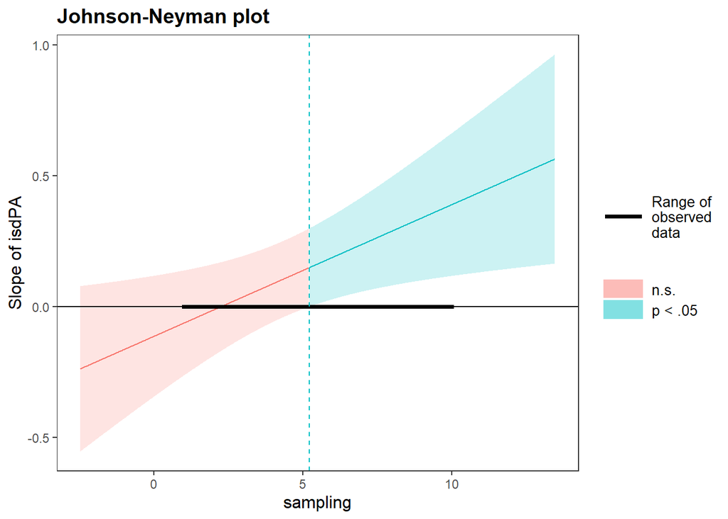

```r
# significant interaction for isdPA:sampling. Following up with Johnson Neyman
johnson_neyman(lm_Base_PA_SDAR_main1_sam, pred=isdPA, modx=sampling, plot = TRUE) #plot
```

```r
## Interaction effects
lm_Base_PA_SDAR_mod_sam<-lm(DepB ~ study_2 + study_3 + study_4 + study_5 +
                                isdPA + autocorPA + imeanPA + isdPA:imeanPA + autocorPA:imeanPA +
                                sampling:isdPA + sampling:autocorPA + sampling:imeanPA +
                                sampling:isdPA:imeanPA + sampling:autocorPA:imeanPA +
                                Age + Sex, data=mega_all_cen_std_5)
summ(lm_Base_PA_SDAR_mod_sam,digits = getOption("jtools-digits", 3), vifs=TRUE)
```

| Observations | 1095 (12 missing obs. deleted) |
| --- | --- |
| Dependent variable | DepB |
| Type | OLS linear regression |

| F(16,1078) | 12.346 |
| --- | --- |
| R² | 0.155 |
| Adj. R² | 0.142 |

|  | Est. | S.E. | t val. | p | VIF |
| --- | --- | --- | --- | --- | --- |
| (Intercept) | -0.509 | 0.300 | -1.697 | 0.090 | NA |
| study_2 | -0.082 | 0.086 | -0.959 | 0.338 | 1.774 |
| study_3 | -0.334 | 0.172 | -1.942 | 0.052 | 6.209 |
| study_4 | -0.347 | 0.211 | -1.643 | 0.101 | 6.961 |
| study_5 | -0.126 | 0.130 | -0.971 | 0.332 | 1.255 |
| isdPA | -0.121 | 0.119 | -1.024 | 0.306 | 3.158 |
| autocorPA | -0.731 | 0.396 | -1.847 | 0.065 | 2.933 |
| imeanPA | -0.316 | 0.053 | -5.995 | 0.000 | 3.853 |
| Age | 0.030 | 0.022 | 1.327 | 0.185 | 8.025 |
| Sex1 | 0.291 | 0.064 | 4.570 | 0.000 | 1.200 |
| isdPA:imeanPA | 0.006 | 0.093 | 0.063 | 0.950 | 2.612 |
| autocorPA:imeanPA | -0.247 | 0.367 | -0.673 | 0.501 | 3.098 |
| isdPA:sampling | 0.051 | 0.021 | 2.437 | 0.015 | 3.178 |
| autocorPA:sampling | 0.054 | 0.068 | 0.798 | 0.425 | 2.944 |
| imeanPA:sampling | 0.000 | 0.009 | 0.034 | 0.973 | 3.939 |
| isdPA:imeanPA:sampling | -0.001 | 0.017 | -0.035 | 0.972 | 2.702 |
| autocorPA:imeanPA:sampling | 0.069 | 0.067 | 1.021 | 0.307 | 3.167 |

Standard errors: OLS

```r
summ(lm_Base_PA_SDAR_mod_sam,digits = getOption("jtools-digits", 3), confint = TRUE,scale = TRUE, transform.response = TRUE)
```

| Observations | 1095 (12 missing obs. deleted) |
| --- | --- |
| Dependent variable | DepB |
| Type | OLS linear regression |

| F(16,1078) | 12.346 |
| --- | --- |
| R² | 0.155 |
| Adj. R² | 0.142 |

|  | Est. | 2.5% | 97.5% | t val. | p |
| --- | --- | --- | --- | --- | --- |
| (Intercept) | -0.038 | -0.207 | 0.132 | -0.439 | 0.661 |
| study_2 | -0.081 | -0.250 | 0.087 | -0.948 | 0.343 |
| study_3 | -0.334 | -0.672 | 0.004 | -1.940 | 0.053 |
| study_4 | -0.347 | -0.761 | 0.068 | -1.641 | 0.101 |
| study_5 | -0.125 | -0.380 | 0.129 | -0.966 | 0.334 |
| isdPA | 0.058 | -0.005 | 0.121 | 1.807 | 0.071 |
| autocorPA | -0.055 | -0.113 | 0.002 | -1.896 | 0.058 |
| imeanPA | -0.328 | -0.391 | -0.265 | -10.212 | 0.000 |
| Age | 0.105 | -0.050 | 0.261 | 1.327 | 0.185 |
| Sex1 | 0.291 | 0.166 | 0.416 | 4.570 | 0.000 |
| isdPA:imeanPA | 0.001 | -0.053 | 0.055 | 0.045 | 0.964 |
| autocorPA:imeanPA | 0.012 | -0.044 | 0.069 | 0.432 | 0.666 |
| isdPA:sampling | 0.075 | 0.015 | 0.135 | 2.437 | 0.015 |
| autocorPA:sampling | 0.023 | -0.033 | 0.079 | 0.798 | 0.425 |
| imeanPA:sampling | 0.001 | -0.063 | 0.066 | 0.034 | 0.973 |
| isdPA:imeanPA:sampling | -0.001 | -0.053 | 0.051 | -0.035 | 0.972 |
| autocorPA:imeanPA:sampling | 0.030 | -0.028 | 0.087 | 1.021 | 0.307 |

Standard errors: OLS; Continuous variables are mean-centered and scaled by 1 s.d.

#### 10.2.2.2 Individual estimates

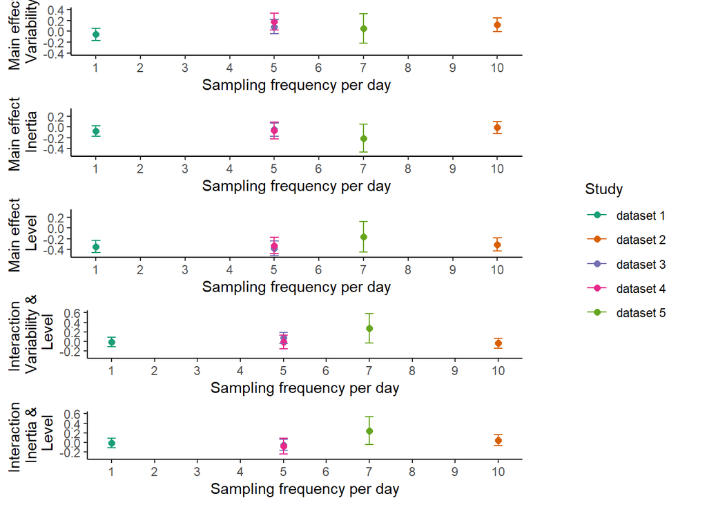

```r
# Create a vector of study IDs & sampling frequency to be included
study_ids <- c(1:5)
sampling <- c(1, 10, 5, 5, 7)
study_name <- c("dataset 1", "dataset 2", "dataset 3", "dataset 4", "dataset 5")

# Define a function to extract coefficients and CI values for main effects
fun_PA_B <- function(study_id) {
  dataset <- mega_all_cen_std_5 %>% filter(study == study_id)
  lm_model <- lm(DepB ~ isdPA + autocorPA + imeanPA + Age + Sex, data = dataset)
  st_lm_model <- summ(lm_model, digits = getOption("jtools-digits", 3), confint = TRUE, scale = TRUE, transform.response = TRUE)

  data.frame(StudyID = study_id,
             SD = st_lm_model$coeftable[2, 1],
             SD_CI_lower = st_lm_model$coeftable[2, 2],
             SD_CI_upper = st_lm_model$coeftable[2, 3],
             AR = st_lm_model$coeftable[3, 1],
             AR_CI_lower = st_lm_model$coeftable[3, 2],
             AR_CI_upper = st_lm_model$coeftable[3, 3],
             M = st_lm_model$coeftable[4, 1],
             M_CI_lower = st_lm_model$coeftable[4, 2],
             M_CI_upper = st_lm_model$coeftable[4, 3])
}

# Use map function to apply the extraction function to each study_id
results_PA_B_main <- map_dfr(study_ids, fun_PA_B)

# Define a function to extract coefficients and CI values for interaction effects
fun_PA_B_mod <- function(study_id) {
  dataset <- mega_all_cen_std_5 %>% filter(study == study_id)
  lm_model <- lm(DepB ~ isdPA + autocorPA + imeanPA + isdPA:imeanPA + autocorPA:imeanPA + Age + Sex, data = dataset)
  st_lm_model <- summ(lm_model, digits = getOption("jtools-digits", 3), confint = TRUE, scale = TRUE, transform.response = TRUE)

  data.frame(StudyID = study_id,
             SD_int = st_lm_model$coeftable[7, 1],
             SD_int_CI_lower = st_lm_model$coeftable[7, 2],
             SD_int_CI_upper = st_lm_model$coeftable[7, 3],
             AR_int = st_lm_model$coeftable[8, 1],
             AR_int_CI_lower = st_lm_model$coeftable[8, 2],
             AR_int_CI_upper = st_lm_model$coeftable[8, 3])
}



# Use map function to apply the extraction function to each study_id
results_PA_B_mod <- map_dfr(study_ids, fun_PA_B_mod)

# Bind & Add sampling frequency & remove StudyID which is in there twice
results_PA_B <- cbind(study_name, sampling, results_PA_B_main, results_PA_B_mod)[, -13]

# Sort by Sampling frequency
results_PA_B <- results_PA_B %>% arrange(sampling)

# Plot the estimates per study with confidence intervals
# Create a function to generate the ggplot for each type of plot (SD, AR, Mean)
generate_ggplot <- function(data, y_var, y_lower, y_upper, ylab) {
  ggplot(data, aes(x = sampling, y = {{ y_var }}, ymin = {{ y_lower }}, ymax = {{ y_upper }})) +
    geom_point(aes(color = as.factor(study_name)), size = 2) +
    geom_errorbar(aes(color = as.factor(study_name)), width = 0.2, linewidth = 0.5) +
    labs(x = "Sampling frequency per day", y = ylab, color = "Study") +
    scale_x_continuous(breaks = seq(0, 10, 1)) +
    theme_classic() +
    theme(plot.title = element_text(hjust = 0.5)) +
    scale_color_brewer(palette = "Dark2")
}

# Individual Plots
plot_sd <- generate_ggplot(results_PA_B, SD, SD_CI_lower, SD_CI_upper, "Main effect \nVariability") +
  coord_cartesian(ylim = c(-0.4, 0.4)) + scale_y_continuous(breaks = pretty_breaks(n = 5))
plot_ar <- generate_ggplot(results_PA_B, AR, AR_CI_lower, AR_CI_upper, "Main effect \nInertia") +
  coord_cartesian(ylim = c(-0.5, 0.3)) + scale_y_continuous(breaks = pretty_breaks(n = 5))
plot_mean <- generate_ggplot(results_PA_B, M, M_CI_lower, M_CI_upper, "Main effect \nLevel") +
  coord_cartesian(ylim = c(-0.5, 0.3)) + scale_y_continuous(breaks = pretty_breaks(n = 5))
plot_sd_m <- generate_ggplot(results_PA_B, SD_int, SD_int_CI_lower, SD_int_CI_upper, "Interaction \nVariability &\n Level") +
  coord_cartesian(ylim = c(-0.3, 0.6)) + scale_y_continuous(breaks = pretty_breaks(n = 5))
plot_ar_m <- generate_ggplot(results_PA_B, AR_int, AR_int_CI_lower, AR_int_CI_upper, "Interaction \nInertia &\n Level") +
  coord_cartesian(ylim = c(-0.3, 0.6)) + scale_y_continuous(breaks = pretty_breaks(n = 5))

# Arrange the plots with a shared title and some spacing
combined_PA_B <- cowplot::plot_grid(
                                    plot_sd + theme(legend.position="none"),
                                    plot_ar + theme(legend.position="none"),
                                    plot_mean + theme(legend.position="none"),
                                    plot_sd_m + theme(legend.position="none"),
                                    plot_ar_m + theme(legend.position="none"),
                                    ncol = 1)

# extract the legend from one of the plots
legend <- get_legend(
  # create some space to the left of the legend
  plot_sd + theme(legend.box.margin = margin(0, 0, 0, 12))
)

# add the legend to the row we made earlier. Give it one-third of
# the width of one plot (via rel_widths).
combined_PA_B <- plot_grid(combined_PA_B, legend, rel_widths = c(3, 1))

# Print
combined_PA_B
```

```r
# Save the combined plot as an image (e.g., in PNG format)
ggsave("../output/combined_PA_B.png", combined_PA_B, width = 16, height = 22, units = "cm")
```

### 10.2.3 Positive Affect Follow-up

#### 10.2.3.1 Sampling frequency as moderator

```r
## Main effects only
lm_FU_PA_SDAR_main1_sam<-lm(DepF ~ DepB + study_2 + study_3 +
                                isdPA + autocorPA + imeanPA +
                                sampling:isdPA + sampling:autocorPA + sampling:imeanPA +
                                Age + Sex, data=mega_all_cen_std_3)
summ(lm_FU_PA_SDAR_main1_sam,digits = getOption("jtools-digits", 3), vifs=TRUE)
```

| Observations | 718 (165 missing obs. deleted) |
| --- | --- |
| Dependent variable | DepF |
| Type | OLS linear regression |

| F(11,706) | 27.072 |
| --- | --- |
| R² | 0.297 |
| Adj. R² | 0.286 |

|  | Est. | S.E. | t val. | p | VIF |
| --- | --- | --- | --- | --- | --- |
| (Intercept) | 0.022 | 0.464 | 0.047 | 0.962 | NA |
| DepB | 0.360 | 0.035 | 10.228 | 0.000 | 1.166 |
| study_2 | -0.058 | 0.090 | -0.648 | 0.517 | 1.538 |
| study_3 | -0.041 | 0.247 | -0.166 | 0.868 | 12.550 |
| isdPA | 0.105 | 0.117 | 0.895 | 0.371 | 2.633 |
| autocorPA | 0.119 | 0.386 | 0.310 | 0.757 | 2.122 |
| imeanPA | -0.266 | 0.053 | -5.010 | 0.000 | 3.011 |
| Age | -0.007 | 0.035 | -0.204 | 0.838 | 10.910 |
| Sex1 | 0.206 | 0.073 | 2.808 | 0.005 | 1.272 |
| isdPA:sampling | 0.027 | 0.023 | 1.170 | 0.242 | 2.599 |
| autocorPA:sampling | -0.029 | 0.071 | -0.410 | 0.682 | 2.115 |
| imeanPA:sampling | 0.009 | 0.010 | 0.946 | 0.345 | 2.896 |

Standard errors: OLS

```r
summ(lm_FU_PA_SDAR_main1_sam,digits = getOption("jtools-digits", 3), confint = TRUE,scale = TRUE, transform.response = TRUE)
```

| Observations | 718 (165 missing obs. deleted) |
| --- | --- |
| Dependent variable | DepF |
| Type | OLS linear regression |

| F(11,706) | 27.072 |
| --- | --- |
| R² | 0.297 |
| Adj. R² | 0.286 |

|  | Est. | 2.5% | 97.5% | t val. | p |
| --- | --- | --- | --- | --- | --- |
| (Intercept) | -0.101 | -0.286 | 0.083 | -1.078 | 0.282 |
| DepB | 0.349 | 0.282 | 0.416 | 10.228 | 0.000 |
| study_2 | -0.058 | -0.235 | 0.118 | -0.648 | 0.518 |
| study_3 | -0.041 | -0.525 | 0.443 | -0.166 | 0.868 |
| isdPA | 0.098 | 0.025 | 0.171 | 2.649 | 0.008 |
| autocorPA | -0.001 | -0.064 | 0.062 | -0.036 | 0.971 |
| imeanPA | -0.232 | -0.306 | -0.159 | -6.193 | 0.000 |
| Age | -0.021 | -0.226 | 0.183 | -0.204 | 0.838 |
| Sex1 | 0.206 | 0.062 | 0.350 | 2.808 | 0.005 |
| isdPA:sampling | 0.043 | -0.029 | 0.116 | 1.170 | 0.242 |
| autocorPA:sampling | -0.013 | -0.074 | 0.048 | -0.410 | 0.682 |
| imeanPA:sampling | 0.035 | -0.038 | 0.107 | 0.946 | 0.345 |

Standard errors: OLS; Continuous variables are mean-centered and scaled by 1 s.d.

```r
## Interaction effects
lm_FU_PA_SDAR_mod_sam<-lm(DepF ~ DepB + study_2 + study_3 +
                                isdPA + autocorPA + imeanPA + isdPA:imeanPA + autocorPA:imeanPA +
                                sampling:isdPA + sampling:autocorPA + sampling:imeanPA +
                                sampling:isdPA:imeanPA + sampling:autocorPA:imeanPA +
                                Age + Sex, data=mega_all_cen_std_3)
summ(lm_FU_PA_SDAR_mod_sam,digits = getOption("jtools-digits", 3), vifs=TRUE)
```

| Observations | 718 (165 missing obs. deleted) |
| --- | --- |
| Dependent variable | DepF |
| Type | OLS linear regression |

| F(15,702) | 20.241 |
| --- | --- |
| R² | 0.302 |
| Adj. R² | 0.287 |

|  | Est. | S.E. | t val. | p | VIF |
| --- | --- | --- | --- | --- | --- |
| (Intercept) | -0.044 | 0.466 | -0.094 | 0.925 | NA |
| DepB | 0.360 | 0.035 | 10.236 | 0.000 | 1.168 |
| study_2 | 0.004 | 0.097 | 0.044 | 0.965 | 1.800 |
| study_3 | -0.007 | 0.248 | -0.027 | 0.979 | 12.700 |
| isdPA | 0.096 | 0.118 | 0.811 | 0.418 | 2.678 |
| autocorPA | -0.029 | 0.397 | -0.072 | 0.942 | 2.254 |
| imeanPA | -0.283 | 0.054 | -5.273 | 0.000 | 3.089 |
| Age | -0.005 | 0.035 | -0.154 | 0.878 | 10.967 |
| Sex1 | 0.197 | 0.074 | 2.671 | 0.008 | 1.282 |
| isdPA:imeanPA | -0.205 | 0.091 | -2.259 | 0.024 | 2.084 |
| autocorPA:imeanPA | -0.018 | 0.360 | -0.050 | 0.960 | 2.194 |
| isdPA:sampling | 0.028 | 0.024 | 1.209 | 0.227 | 2.675 |
| autocorPA:sampling | -0.011 | 0.074 | -0.147 | 0.883 | 2.281 |
| imeanPA:sampling | 0.012 | 0.010 | 1.217 | 0.224 | 3.070 |
| isdPA:imeanPA:sampling | 0.031 | 0.020 | 1.527 | 0.127 | 2.306 |
| autocorPA:imeanPA:sampling | -0.026 | 0.075 | -0.348 | 0.728 | 2.385 |

Standard errors: OLS

```r
summ(lm_FU_PA_SDAR_mod_sam,digits = getOption("jtools-digits", 3), confint = TRUE,scale = TRUE, transform.response = TRUE)
```

| Observations | 718 (165 missing obs. deleted) |
| --- | --- |
| Dependent variable | DepF |
| Type | OLS linear regression |

| F(15,702) | 20.241 |
| --- | --- |
| R² | 0.302 |
| Adj. R² | 0.287 |

|  | Est. | 2.5% | 97.5% | t val. | p |
| --- | --- | --- | --- | --- | --- |
| (Intercept) | -0.140 | -0.327 | 0.047 | -1.469 | 0.142 |
| DepB | 0.349 | 0.282 | 0.416 | 10.236 | 0.000 |
| study_2 | 0.005 | -0.186 | 0.196 | 0.051 | 0.960 |
| study_3 | -0.006 | -0.493 | 0.480 | -0.026 | 0.980 |
| isdPA | 0.096 | 0.022 | 0.170 | 2.552 | 0.011 |
| autocorPA | -0.009 | -0.075 | 0.056 | -0.284 | 0.777 |
| imeanPA | -0.236 | -0.311 | -0.161 | -6.198 | 0.000 |
| Age | -0.016 | -0.221 | 0.189 | -0.154 | 0.878 |
| Sex1 | 0.196 | 0.052 | 0.341 | 2.671 | 0.008 |
| isdPA:imeanPA | -0.031 | -0.094 | 0.032 | -0.959 | 0.338 |
| autocorPA:imeanPA | -0.016 | -0.082 | 0.049 | -0.494 | 0.622 |
| isdPA:sampling | 0.046 | -0.028 | 0.120 | 1.231 | 0.219 |
| autocorPA:sampling | -0.005 | -0.068 | 0.058 | -0.154 | 0.878 |
| imeanPA:sampling | 0.046 | -0.029 | 0.120 | 1.201 | 0.230 |
| isdPA:imeanPA:sampling | 0.051 | -0.015 | 0.116 | 1.527 | 0.127 |
| autocorPA:imeanPA:sampling | -0.012 | -0.078 | 0.054 | -0.348 | 0.728 |

Standard errors: OLS; Continuous variables are mean-centered and scaled by 1 s.d.

#### 10.2.3.2 Individual estimates

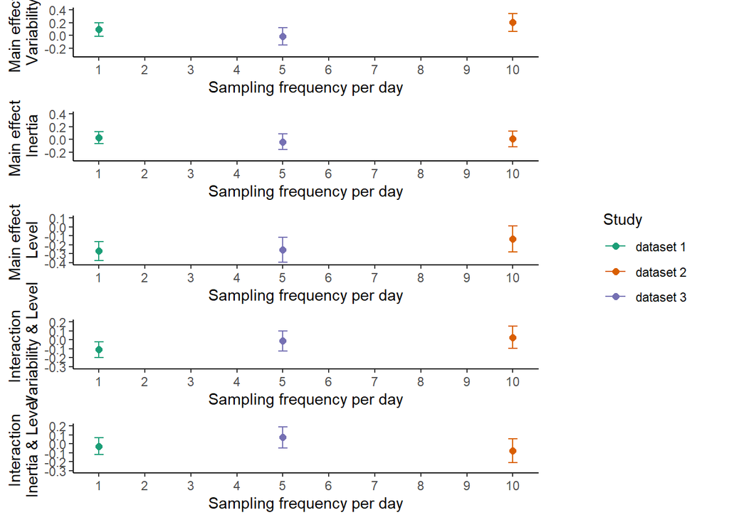

```r
# Create a vector of study IDs & sampling frequency to be included
study_ids <- c(1:3)
sampling <- c(1, 10, 5)
study_name <- c("dataset 1", "dataset 2", "dataset 3")

# Define a function to extract coefficients and CI values for main effects
fun_PA_F <- function(study_id) {
  dataset <- mega_all_cen_std_3 %>% filter(study == study_id)
  lm_model <- lm(DepF ~ DepB + isdPA + autocorPA + imeanPA + Age + Sex, data = dataset)
  st_lm_model <- summ(lm_model, digits = getOption("jtools-digits", 3), confint = TRUE, scale = TRUE, transform.response = TRUE)

  data.frame(StudyID = study_id,
             SD = st_lm_model$coeftable[3, 1],
             SD_CI_lower = st_lm_model$coeftable[3, 2],
             SD_CI_upper = st_lm_model$coeftable[3, 3],
             AR = st_lm_model$coeftable[4, 1],
             AR_CI_lower = st_lm_model$coeftable[4, 2],
             AR_CI_upper = st_lm_model$coeftable[4, 3],
             M = st_lm_model$coeftable[5, 1],
             M_CI_lower = st_lm_model$coeftable[5, 2],
             M_CI_upper = st_lm_model$coeftable[5, 3])
}

# Use map function to apply the extraction function to each study_id
results_PA_F_main <- map_dfr(study_ids, fun_PA_F)

# Define a function to extract coefficients and CI values for interaction effects
fun_PA_F_mod <- function(study_id) {
  dataset <- mega_all_cen_std_3 %>% filter(study == study_id)
  lm_model <- lm(DepF ~ DepB + isdPA + autocorPA + imeanPA + isdPA:imeanPA + autocorPA:imeanPA + Age + Sex, data = dataset)
  st_lm_model <- summ(lm_model, digits = getOption("jtools-digits", 3), confint = TRUE, scale = TRUE, transform.response = TRUE)

  data.frame(StudyID = study_id,
             SD_int = st_lm_model$coeftable[8, 1],
             SD_int_CI_lower = st_lm_model$coeftable[8, 2],
             SD_int_CI_upper = st_lm_model$coeftable[8, 3],
             AR_int = st_lm_model$coeftable[9, 1],
             AR_int_CI_lower = st_lm_model$coeftable[9, 2],
             AR_int_CI_upper = st_lm_model$coeftable[9, 3])
}

# Use map function to apply the extraction function to each study_id
results_PA_F_mod <- map_dfr(study_ids, fun_PA_F_mod)

# Bind & Add sampling frequency & remove StudyID which is in there twice
results_PA_F <- cbind(study_name, sampling, results_PA_F_main, results_PA_F_mod)[, -13]

# Sort by Sampling frequency
results_PA_F <- results_PA_F %>% arrange(sampling)

# Individual Plots
plot_sd <- generate_ggplot(results_PA_F, SD, SD_CI_lower, SD_CI_upper, "Main effect \nVariability") +
  coord_cartesian(ylim = c(-0.3, 0.4)) + scale_y_continuous(breaks = pretty_breaks(n = 5))
plot_ar <- generate_ggplot(results_PA_F, AR, AR_CI_lower, AR_CI_upper, "Main effect \nInertia") +
  coord_cartesian(ylim = c(-0.3, 0.4)) + scale_y_continuous(breaks = pretty_breaks(n = 5))
plot_mean <- generate_ggplot(results_PA_F, M, M_CI_lower, M_CI_upper, "Main effect \nLevel") +
  coord_cartesian(ylim = c(-0.4, 0.1)) + scale_y_continuous(breaks = pretty_breaks(n = 5))
plot_sd_m <- generate_ggplot(results_PA_F, SD_int, SD_int_CI_lower, SD_int_CI_upper, "Interaction \nVariability & Level") +
  coord_cartesian(ylim = c(-0.3, 0.2)) + scale_y_continuous(breaks = pretty_breaks(n = 5))
plot_ar_m <- generate_ggplot(results_PA_F, AR_int, AR_int_CI_lower, AR_int_CI_upper, "Interaction \nInertia & Level") +
  coord_cartesian(ylim = c(-0.3, 0.2)) + scale_y_continuous(breaks = pretty_breaks(n = 5))

# Arrange the plots with a shared title and some spacing
combined_PA_F <- cowplot::plot_grid(
                                    plot_sd + theme(legend.position="none"),
                                    plot_ar + theme(legend.position="none"),
                                    plot_mean + theme(legend.position="none"),
                                    plot_sd_m + theme(legend.position="none"),
                                    plot_ar_m + theme(legend.position="none"),
                                    ncol = 1)

# extract the legend from one of the plots
legend <- get_legend(
  # create some space to the left of the legend
  plot_sd + theme(legend.box.margin = margin(0, 0, 0, 12))
)

# add the legend to the row we made earlier. Give it one-third of
# the width of one plot (via rel_widths).
combined_PA_F <- plot_grid(combined_PA_F, legend, rel_widths = c(3, 1))

# Print
combined_PA_F
```

```r
# Save the combined plot as an image (e.g., in PNG format)
ggsave("../output/combined_PA_F.png", combined_PA_F, width = 16, height = 22, units = "cm")
```

### 10.2.4 Negative Affect Baseline

#### 10.2.4.1 Sampling frequency as moderator

```r
## Main effects only
lm_Base_NA_SDAR_main1_sam<-lm(DepB ~ study_2 + study_3 + study_4 + study_5 + study_6 + study_7 +
                                isdNA + autocorNA + imeanNA +
                                sampling:isdNA + sampling:autocorNA + sampling:imeanNA +
                                Age + Sex, data=mega_all_cen_std)
summ(lm_Base_NA_SDAR_main1_sam,digits = getOption("jtools-digits", 3), vifs=TRUE)
```

| Observations | 1428 (20 missing obs. deleted) |
| --- | --- |
| Dependent variable | DepB |
| Type | OLS linear regression |

| F(14,1413) | 20.338 |
| --- | --- |
| R² | 0.168 |
| Adj. R² | 0.159 |

|  | Est. | S.E. | t val. | p | VIF |
| --- | --- | --- | --- | --- | --- |
| (Intercept) | -0.742 | 0.255 | -2.907 | 0.004 | NA |
| study_2 | -0.089 | 0.077 | -1.166 | 0.244 | 1.574 |
| study_3 | -0.427 | 0.151 | -2.829 | 0.005 | 5.196 |
| study_4 | -0.485 | 0.184 | -2.631 | 0.009 | 5.665 |
| study_5 | -0.106 | 0.123 | -0.867 | 0.386 | 1.173 |
| study_6 | -0.384 | 0.143 | -2.688 | 0.007 | 3.698 |
| study_7 | -0.091 | 0.088 | -1.028 | 0.304 | 1.333 |
| isdNA | 0.075 | 0.110 | 0.683 | 0.495 | 4.161 |
| autocorNA | -0.325 | 0.337 | -0.963 | 0.336 | 2.864 |
| imeanNA | 0.236 | 0.059 | 3.995 | 0.000 | 5.466 |
| Age | 0.049 | 0.019 | 2.574 | 0.010 | 7.127 |
| Sex1 | 0.232 | 0.055 | 4.213 | 0.000 | 1.186 |
| isdNA:sampling | 0.037 | 0.026 | 1.449 | 0.147 | 5.291 |
| autocorNA:sampling | 0.107 | 0.069 | 1.553 | 0.121 | 3.015 |
| imeanNA:sampling | 0.022 | 0.015 | 1.402 | 0.161 | 6.945 |

Standard errors: OLS

```r
summ(lm_Base_NA_SDAR_main1_sam,digits = getOption("jtools-digits", 3), confint = TRUE,scale = TRUE, transform.response = TRUE)
```

| Observations | 1428 (20 missing obs. deleted) |
| --- | --- |
| Dependent variable | DepB |
| Type | OLS linear regression |

| F(14,1413) | 20.338 |
| --- | --- |
| R² | 0.168 |
| Adj. R² | 0.159 |

|  | Est. | 2.5% | 97.5% | t val. | p |
| --- | --- | --- | --- | --- | --- |
| (Intercept) | 0.049 | -0.104 | 0.202 | 0.627 | 0.531 |
| study_2 | -0.089 | -0.240 | 0.062 | -1.151 | 0.250 |
| study_3 | -0.428 | -0.725 | -0.131 | -2.825 | 0.005 |
| study_4 | -0.486 | -0.850 | -0.123 | -2.628 | 0.009 |
| study_5 | -0.106 | -0.348 | 0.136 | -0.860 | 0.390 |
| study_6 | -0.385 | -0.666 | -0.104 | -2.686 | 0.007 |
| study_7 | -0.091 | -0.265 | 0.083 | -1.025 | 0.305 |
| isdNA | 0.110 | 0.048 | 0.171 | 3.491 | 0.000 |
| autocorNA | 0.020 | -0.033 | 0.072 | 0.745 | 0.457 |
| imeanNA | 0.321 | 0.251 | 0.391 | 8.967 | 0.000 |
| Age | 0.167 | 0.040 | 0.294 | 2.574 | 0.010 |
| Sex1 | 0.233 | 0.125 | 0.342 | 4.213 | 0.000 |
| isdNA:sampling | 0.052 | -0.019 | 0.123 | 1.449 | 0.147 |
| autocorNA:sampling | 0.041 | -0.011 | 0.093 | 1.553 | 0.121 |
| imeanNA:sampling | 0.065 | -0.026 | 0.156 | 1.402 | 0.161 |

Standard errors: OLS; Continuous variables are mean-centered and scaled by 1 s.d.

```r
## Interaction effects
lm_Base_NA_SDAR_mod_sam<-lm(DepB ~ study_2 + study_3 + study_4 + study_5 +
                                isdNA + autocorNA + imeanNA + isdNA:imeanNA + autocorNA:imeanNA +
                                sampling:isdNA + sampling:autocorNA + sampling:imeanNA +
                                sampling:isdNA:imeanNA + sampling:autocorNA:imeanNA +
                                Age + Sex, data=mega_all_cen_std)
summ(lm_Base_NA_SDAR_mod_sam,digits = getOption("jtools-digits", 3), vifs=TRUE)
```

| Observations | 1428 (20 missing obs. deleted) |
| --- | --- |
| Dependent variable | DepB |
| Type | OLS linear regression |

| F(16,1411) | 17.330 |
| --- | --- |
| R² | 0.164 |
| Adj. R² | 0.155 |

|  | Est. | S.E. | t val. | p | VIF |
| --- | --- | --- | --- | --- | --- |
| (Intercept) | -0.242 | 0.183 | -1.323 | 0.186 | NA |
| study_2 | 0.011 | 0.078 | 0.143 | 0.886 | 1.602 |
| study_3 | -0.103 | 0.092 | -1.122 | 0.262 | 1.909 |
| study_4 | -0.095 | 0.112 | -0.842 | 0.400 | 2.097 |
| study_5 | -0.008 | 0.124 | -0.063 | 0.950 | 1.181 |
| isdNA | 0.093 | 0.112 | 0.828 | 0.408 | 4.248 |
| autocorNA | -0.334 | 0.357 | -0.936 | 0.350 | 3.194 |
| imeanNA | 0.215 | 0.065 | 3.301 | 0.001 | 6.639 |
| Age | 0.009 | 0.012 | 0.742 | 0.458 | 2.829 |
| Sex1 | 0.197 | 0.054 | 3.649 | 0.000 | 1.134 |
| isdNA:imeanNA | -0.055 | 0.090 | -0.609 | 0.543 | 3.668 |
| autocorNA:imeanNA | 0.216 | 0.327 | 0.660 | 0.510 | 3.827 |
| isdNA:sampling | 0.035 | 0.026 | 1.335 | 0.182 | 5.427 |
| autocorNA:sampling | 0.118 | 0.075 | 1.580 | 0.114 | 3.527 |
| imeanNA:sampling | 0.025 | 0.017 | 1.482 | 0.139 | 8.591 |
| isdNA:imeanNA:sampling | 0.002 | 0.023 | 0.092 | 0.927 | 4.672 |
| autocorNA:imeanNA:sampling | -0.038 | 0.075 | -0.506 | 0.613 | 4.477 |

Standard errors: OLS

```r
summ(lm_Base_NA_SDAR_mod_sam,digits = getOption("jtools-digits", 3), confint = TRUE,scale = TRUE, transform.response = TRUE)
```

| Observations | 1428 (20 missing obs. deleted) |
| --- | --- |
| Dependent variable | DepB |
| Type | OLS linear regression |

| F(16,1411) | 17.331 |
| --- | --- |
| R² | 0.164 |
| Adj. R² | 0.155 |

|  | Est. | 2.5% | 97.5% | t val. | p |
| --- | --- | --- | --- | --- | --- |
| (Intercept) | -0.096 | -0.200 | 0.009 | -1.797 | 0.072 |
| study_2 | 0.012 | -0.141 | 0.165 | 0.156 | 0.876 |
| study_3 | -0.103 | -0.284 | 0.078 | -1.119 | 0.263 |
| study_4 | -0.095 | -0.316 | 0.127 | -0.840 | 0.401 |
| study_5 | -0.007 | -0.251 | 0.236 | -0.058 | 0.954 |
| isdNA | 0.113 | 0.050 | 0.175 | 3.543 | 0.000 |
| autocorNA | 0.025 | -0.032 | 0.082 | 0.861 | 0.390 |
| imeanNA | 0.318 | 0.240 | 0.397 | 7.993 | 0.000 |
| Age | 0.030 | -0.050 | 0.111 | 0.744 | 0.457 |
| Sex1 | 0.198 | 0.092 | 0.305 | 3.650 | 0.000 |
| isdNA:imeanNA | -0.019 | -0.068 | 0.030 | -0.776 | 0.438 |
| autocorNA:imeanNA | 0.005 | -0.047 | 0.057 | 0.184 | 0.854 |
| isdNA:sampling | 0.049 | -0.023 | 0.121 | 1.337 | 0.181 |
| autocorNA:sampling | 0.045 | -0.011 | 0.101 | 1.580 | 0.114 |
| imeanNA:sampling | 0.077 | -0.025 | 0.178 | 1.482 | 0.139 |
| isdNA:imeanNA:sampling | 0.003 | -0.058 | 0.064 | 0.092 | 0.927 |
| autocorNA:imeanNA:sampling | -0.014 | -0.068 | 0.040 | -0.506 | 0.613 |

Standard errors: OLS; Continuous variables are mean-centered and scaled by 1 s.d.

#### 10.2.4.2 Individual estimates

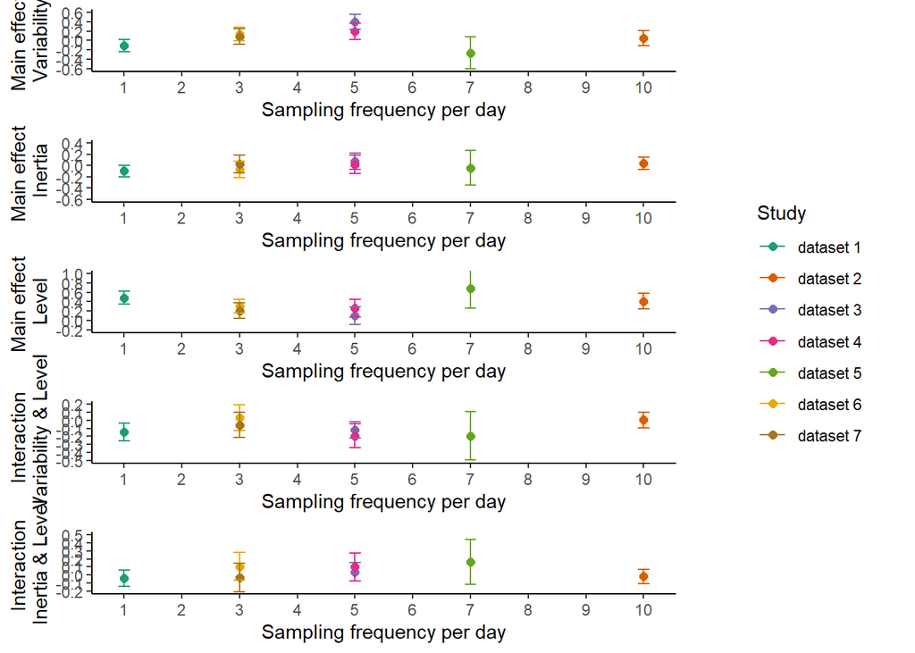

```r
# Create a vector of study IDs & sampling frequency to be included
study_ids <- c(1:7)
sampling <- c(1, 10, 5, 5, 7, 3, 3)
study_name <- c("dataset 1", "dataset 2", "dataset 3", "dataset 4", "dataset 5", "dataset 6", "dataset 7")

# Define a function to extract coefficients and CI values for main effects
fun_NA_B <- function(study_id) {
  dataset <- mega_all_cen_std %>% filter(study == study_id)
  lm_model <- lm(DepB ~ isdNA + autocorNA + imeanNA + Age + Sex, data = dataset)
  st_lm_model <- summ(lm_model, digits = getOption("jtools-digits", 3), confint = TRUE, scale = TRUE, transform.response = TRUE)

  data.frame(StudyID = study_id,
             SD = st_lm_model$coeftable[2, 1],
             SD_CI_lower = st_lm_model$coeftable[2, 2],
             SD_CI_upper = st_lm_model$coeftable[2, 3],
             AR = st_lm_model$coeftable[3, 1],
             AR_CI_lower = st_lm_model$coeftable[3, 2],
             AR_CI_upper = st_lm_model$coeftable[3, 3],
             M = st_lm_model$coeftable[4, 1],
             M_CI_lower = st_lm_model$coeftable[4, 2],
             M_CI_upper = st_lm_model$coeftable[4, 3])
}

# Use map function to apply the extraction function to each study_id
results_NA_B_main <- map_dfr(study_ids, fun_NA_B)

# Define a function to extract coefficients and CI values for interaction effects
fun_NA_B_mod <- function(study_id) {
  dataset <- mega_all_cen_std %>% filter(study == study_id)
  lm_model <- lm(DepB ~ isdNA + autocorNA + imeanNA + isdNA:imeanNA + autocorNA:imeanNA + Age + Sex, data = dataset)
  st_lm_model <- summ(lm_model, digits = getOption("jtools-digits", 3), confint = TRUE, scale = TRUE, transform.response = TRUE)

  data.frame(StudyID = study_id,
             SD_int = st_lm_model$coeftable[7, 1],
             SD_int_CI_lower = st_lm_model$coeftable[7, 2],
             SD_int_CI_upper = st_lm_model$coeftable[7, 3],
             AR_int = st_lm_model$coeftable[8, 1],
             AR_int_CI_lower = st_lm_model$coeftable[8, 2],
             AR_int_CI_upper = st_lm_model$coeftable[8, 3])
}



# Use map function to apply the extraction function to each study_id
results_NA_B_mod <- map_dfr(study_ids, fun_NA_B_mod)

# Bind & Add sampling frequency & remove StudyID which is in there twice
results_NA_B <- cbind(study_name, sampling, results_NA_B_main, results_NA_B_mod)[, -13]

# Sort by Sampling frequency
results_NA_B <- results_NA_B %>% arrange(sampling)

# Individual Plots
plot_sd <- generate_ggplot(results_NA_B, SD, SD_CI_lower, SD_CI_upper, "Main effect \nVariability") +
  coord_cartesian(ylim = c(-0.6, 0.6)) + scale_y_continuous(breaks = pretty_breaks(n = 5))
plot_ar <- generate_ggplot(results_NA_B, AR, AR_CI_lower, AR_CI_upper, "Main effect \nInertia") +
  coord_cartesian(ylim = c(-0.6, 0.4)) + scale_y_continuous(breaks = pretty_breaks(n = 5))
plot_mean <- generate_ggplot(results_NA_B, M, M_CI_lower, M_CI_upper, "Main effect \nLevel") +
  coord_cartesian(ylim = c(-0.2, 1)) + scale_y_continuous(breaks = pretty_breaks(n = 5))
plot_sd_m <- generate_ggplot(results_NA_B, SD_int, SD_int_CI_lower, SD_int_CI_upper, "Interaction  \nVariability & Level") +
  coord_cartesian(ylim = c(-0.5, 0.2)) + scale_y_continuous(breaks = pretty_breaks(n = 6))
plot_ar_m <- generate_ggplot(results_NA_B, AR_int, AR_int_CI_lower, AR_int_CI_upper, "Interaction \nInertia & Level") +
  coord_cartesian(ylim = c(-0.2, 0.5)) + scale_y_continuous(breaks = pretty_breaks(n = 6))

# Arrange the plots with a shared title and some spacing
combined_NA_B <- cowplot::plot_grid(
                                    plot_sd + theme(legend.position="none"),
                                    plot_ar + theme(legend.position="none"),
                                    plot_mean + theme(legend.position="none"),
                                    plot_sd_m + theme(legend.position="none"),
                                    plot_ar_m + theme(legend.position="none"),
                                    ncol = 1)



# extract the legend from one of the plots
legend <- get_legend(
  # create some space to the left of the legend
  plot_sd + theme(legend.box.margin = margin(0, 0, 0, 12))
)

# add the legend to the row we made earlier. Give it one-third of
# the width of one plot (via rel_widths).
combined_NA_B <- plot_grid(combined_NA_B, legend, rel_widths = c(3, 1))

# Print
combined_NA_B
```

```r
# Save the combined plot as an image (e.g., in PNG format)
ggsave("../output/combined_NA_B.png", combined_NA_B, width = 16, height = 22, units = "cm")
```

### 10.2.5 Negative Affect Follow-up

#### 10.2.5.1 Sampling frequency as moderator

```r
## Main effects only
lm_FU_NA_SDAR_main1_sam<-lm(DepF ~ DepB + study_2 + study_3 + study_7 +
                                isdNA + autocorNA + imeanNA +
                                sampling:isdNA + sampling:autocorNA + sampling:imeanNA +
                                Age + Sex, data=mega_all_cen_std_4)
summ(lm_FU_NA_SDAR_main1_sam,digits = getOption("jtools-digits", 3), vifs=TRUE)
```

| Observations | 867 (184 missing obs. deleted) |
| --- | --- |
| Dependent variable | DepF |
| Type | OLS linear regression |

| F(12,854) | 29.255 |
| --- | --- |
| R² | 0.291 |
| Adj. R² | 0.281 |

|  | Est. | S.E. | t val. | p | VIF |
| --- | --- | --- | --- | --- | --- |
| (Intercept) | -0.340 | 0.423 | -0.802 | 0.423 | NA |
| DepB | 0.440 | 0.032 | 13.564 | 0.000 | 1.192 |
| study_2 | -0.078 | 0.088 | -0.892 | 0.373 | 1.565 |
| study_3 | -0.213 | 0.227 | -0.940 | 0.348 | 11.466 |
| study_7 | -0.054 | 0.089 | -0.615 | 0.539 | 1.369 |
| isdNA | 0.012 | 0.122 | 0.096 | 0.923 | 3.792 |
| autocorNA | -0.100 | 0.354 | -0.282 | 0.778 | 2.589 |
| imeanNA | 0.220 | 0.068 | 3.214 | 0.001 | 4.996 |
| Age | 0.022 | 0.032 | 0.676 | 0.499 | 9.620 |
| Sex1 | 0.166 | 0.064 | 2.587 | 0.010 | 1.212 |
| isdNA:sampling | 0.055 | 0.031 | 1.794 | 0.073 | 4.287 |
| autocorNA:sampling | 0.022 | 0.082 | 0.268 | 0.789 | 2.828 |
| imeanNA:sampling | -0.031 | 0.019 | -1.672 | 0.095 | 5.744 |

Standard errors: OLS

```r
summ(lm_FU_NA_SDAR_main1_sam,digits = getOption("jtools-digits", 3), confint = TRUE,scale = TRUE, transform.response = TRUE)
```

| Observations | 867 (184 missing obs. deleted) |
| --- | --- |
| Dependent variable | DepF |
| Type | OLS linear regression |

| F(12,854) | 29.255 |
| --- | --- |
| R² | 0.291 |
| Adj. R² | 0.281 |

|  | Est. | 2.5% | 97.5% | t val. | p |
| --- | --- | --- | --- | --- | --- |
| (Intercept) | -0.024 | -0.186 | 0.138 | -0.292 | 0.770 |
| DepB | 0.427 | 0.365 | 0.488 | 13.564 | 0.000 |
| study_2 | -0.077 | -0.251 | 0.097 | -0.867 | 0.386 |
| study_3 | -0.214 | -0.663 | 0.235 | -0.935 | 0.350 |
| study_7 | -0.054 | -0.230 | 0.121 | -0.609 | 0.543 |
| isdNA | 0.111 | 0.033 | 0.190 | 2.777 | 0.006 |
| autocorNA | -0.001 | -0.067 | 0.065 | -0.032 | 0.975 |
| imeanNA | 0.084 | -0.006 | 0.174 | 1.822 | 0.069 |
| Age | 0.060 | -0.115 | 0.236 | 0.676 | 0.499 |
| Sex1 | 0.168 | 0.040 | 0.295 | 2.587 | 0.010 |
| isdNA:sampling | 0.085 | -0.008 | 0.178 | 1.794 | 0.073 |
| autocorNA:sampling | 0.010 | -0.061 | 0.081 | 0.268 | 0.789 |
| imeanNA:sampling | -0.099 | -0.216 | 0.017 | -1.672 | 0.095 |

Standard errors: OLS; Continuous variables are mean-centered and scaled by 1 s.d.

```r
## Interaction effects
lm_FU_NA_SDAR_mod_sam<-lm(DepF ~ DepB + study_2 + study_3 + study_7 +
                                isdNA + autocorNA + imeanNA + isdNA:imeanNA + autocorNA:imeanNA +
                                sampling:isdNA + sampling:autocorNA + sampling:imeanNA +
                                sampling:isdNA:imeanNA + sampling:autocorNA:imeanNA +
                                Age + Sex, data=mega_all_cen_std_4)
summ(lm_FU_NA_SDAR_mod_sam,digits = getOption("jtools-digits", 3), vifs=TRUE)
```

| Observations | 867 (184 missing obs. deleted) |
| --- | --- |
| Dependent variable | DepF |
| Type | OLS linear regression |

| F(16,850) | 22.116 |
| --- | --- |
| R² | 0.294 |
| Adj. R² | 0.281 |

|  | Est. | S.E. | t val. | p | VIF |
| --- | --- | --- | --- | --- | --- |
| (Intercept) | -0.376 | 0.425 | -0.884 | 0.377 | NA |
| DepB | 0.442 | 0.032 | 13.595 | 0.000 | 1.197 |
| study_2 | -0.050 | 0.107 | -0.469 | 0.639 | 2.307 |
| study_3 | -0.188 | 0.230 | -0.819 | 0.413 | 11.738 |
| study_7 | -0.049 | 0.093 | -0.522 | 0.602 | 1.507 |
| isdNA | 0.003 | 0.124 | 0.021 | 0.984 | 3.910 |
| autocorNA | -0.131 | 0.369 | -0.356 | 0.722 | 2.811 |
| imeanNA | 0.221 | 0.074 | 2.985 | 0.003 | 5.861 |
| Age | 0.022 | 0.032 | 0.671 | 0.503 | 9.636 |
| Sex1 | 0.168 | 0.064 | 2.600 | 0.009 | 1.218 |
| isdNA:imeanNA | 0.135 | 0.105 | 1.281 | 0.201 | 3.375 |
| autocorNA:imeanNA | -0.124 | 0.346 | -0.358 | 0.720 | 3.284 |
| isdNA:sampling | 0.056 | 0.031 | 1.789 | 0.074 | 4.419 |
| autocorNA:sampling | 0.012 | 0.087 | 0.140 | 0.889 | 3.188 |
| imeanNA:sampling | -0.032 | 0.020 | -1.566 | 0.118 | 6.834 |
| isdNA:imeanNA:sampling | -0.012 | 0.032 | -0.370 | 0.711 | 4.039 |
| autocorNA:imeanNA:sampling | 0.032 | 0.091 | 0.353 | 0.724 | 4.111 |

Standard errors: OLS

```r
summ(lm_FU_NA_SDAR_mod_sam,digits = getOption("jtools-digits", 3), confint = TRUE,scale = TRUE, transform.response = TRUE)
```

| Observations | 867 (184 missing obs. deleted) |
| --- | --- |
| Dependent variable | DepF |
| Type | OLS linear regression |

| F(16,850) | 22.116 |
| --- | --- |
| R² | 0.294 |
| Adj. R² | 0.281 |

|  | Est. | 2.5% | 97.5% | t val. | p |
| --- | --- | --- | --- | --- | --- |
| (Intercept) | -0.063 | -0.237 | 0.111 | -0.709 | 0.479 |
| DepB | 0.429 | 0.367 | 0.491 | 13.595 | 0.000 |
| study_2 | -0.048 | -0.258 | 0.162 | -0.450 | 0.653 |
| study_3 | -0.189 | -0.643 | 0.266 | -0.815 | 0.415 |
| study_7 | -0.048 | -0.232 | 0.135 | -0.517 | 0.605 |
| isdNA | 0.107 | 0.028 | 0.187 | 2.650 | 0.008 |
| autocorNA | -0.011 | -0.081 | 0.060 | -0.295 | 0.768 |
| imeanNA | 0.082 | -0.017 | 0.180 | 1.634 | 0.103 |
| Age | 0.060 | -0.116 | 0.236 | 0.671 | 0.503 |
| Sex1 | 0.169 | 0.041 | 0.297 | 2.600 | 0.009 |
| isdNA:imeanNA | 0.037 | -0.029 | 0.102 | 1.093 | 0.275 |
| autocorNA:imeanNA | 0.001 | -0.064 | 0.066 | 0.040 | 0.968 |
| isdNA:sampling | 0.087 | -0.008 | 0.181 | 1.793 | 0.073 |
| autocorNA:sampling | 0.005 | -0.071 | 0.081 | 0.131 | 0.896 |
| imeanNA:sampling | -0.101 | -0.229 | 0.026 | -1.559 | 0.119 |
| isdNA:imeanNA:sampling | -0.017 | -0.108 | 0.074 | -0.370 | 0.711 |
| autocorNA:imeanNA:sampling | 0.013 | -0.060 | 0.087 | 0.353 | 0.724 |

Standard errors: OLS; Continuous variables are mean-centered and scaled by 1 s.d.

#### 10.2.5.2 Individual estimates

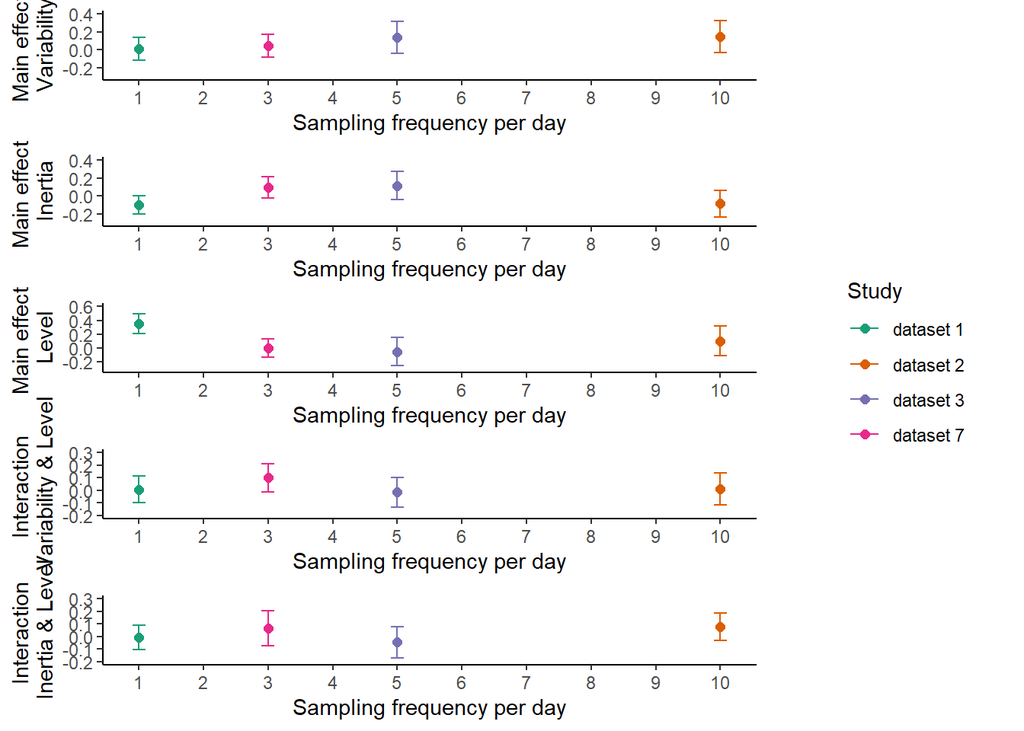

```r
# Create a vector of study IDs & sampling frequency to be included
study_ids <- c(1:3, 7)
sampling <- c(1, 10, 5, 3)
study_name <- c("dataset 1", "dataset 2", "dataset 3", "dataset 7")

# Define a function to extract coefficients and CI values for main effects
fun_NA_F <- function(study_id) {
  dataset <- mega_all_cen_std_4 %>% filter(study == study_id)
  lm_model <- lm(DepF ~ DepB + isdNA + autocorNA + imeanNA + Age + Sex, data = dataset)
  st_lm_model <- summ(lm_model, digits = getOption("jtools-digits", 3), confint = TRUE, scale = TRUE, transform.response = TRUE)

  data.frame(StudyID = study_id,
             SD = st_lm_model$coeftable[3, 1],
             SD_CI_lower = st_lm_model$coeftable[3, 2],
             SD_CI_upper = st_lm_model$coeftable[3, 3],
             AR = st_lm_model$coeftable[4, 1],
             AR_CI_lower = st_lm_model$coeftable[4, 2],
             AR_CI_upper = st_lm_model$coeftable[4, 3],
             M = st_lm_model$coeftable[5, 1],
             M_CI_lower = st_lm_model$coeftable[5, 2],
             M_CI_upper = st_lm_model$coeftable[5, 3])
}

# Use map function to apply the extraction function to each study_id
results_NA_F_main <- map_dfr(study_ids, fun_NA_F)

# Define a function to extract coefficients and CI values for interaction effects
fun_NA_F_mod <- function(study_id) {
  dataset <- mega_all_cen_std_4 %>% filter(study == study_id)
  lm_model <- lm(DepF ~ DepB + isdNA + autocorNA + imeanNA + isdNA:imeanNA + autocorNA:imeanNA + Age + Sex, data = dataset)
  st_lm_model <- summ(lm_model, digits = getOption("jtools-digits", 3), confint = TRUE, scale = TRUE, transform.response = TRUE)

  data.frame(StudyID = study_id,
             SD_int = st_lm_model$coeftable[8, 1],
             SD_int_CI_lower = st_lm_model$coeftable[8, 2],
             SD_int_CI_upper = st_lm_model$coeftable[8, 3],
             AR_int = st_lm_model$coeftable[9, 1],
             AR_int_CI_lower = st_lm_model$coeftable[9, 2],
             AR_int_CI_upper = st_lm_model$coeftable[9, 3])
}



# Use map function to apply the extraction function to each study_id
results_NA_F_mod <- map_dfr(study_ids, fun_NA_F_mod)

# Bind & Add sampling frequency & remove StudyID which is in there twice
results_NA_F <- cbind(study_name, sampling, results_NA_F_main, results_NA_F_mod)[, -13]

# Sort by Sampling frequency
results_NA_F <- results_NA_F %>% arrange(sampling)

# Individual Plots
plot_sd <- generate_ggplot(results_NA_F, SD, SD_CI_lower, SD_CI_upper, "Main effect \nVariability") +
  coord_cartesian(ylim = c(-0.3, 0.4)) + scale_y_continuous(breaks = pretty_breaks(n = 5))
plot_ar <- generate_ggplot(results_NA_F, AR, AR_CI_lower, AR_CI_upper, "Main effect \nInertia") +
  coord_cartesian(ylim = c(-0.3, 0.4)) + scale_y_continuous(breaks = pretty_breaks(n = 5))
plot_mean <- generate_ggplot(results_NA_F, M, M_CI_lower, M_CI_upper, "Main effect \nLevel") +
  coord_cartesian(ylim = c(-0.3, 0.6)) + scale_y_continuous(breaks = pretty_breaks(n = 5))
plot_sd_m <- generate_ggplot(results_NA_F, SD_int, SD_int_CI_lower, SD_int_CI_upper, "Interaction \nVariability & Level") +
  coord_cartesian(ylim = c(-0.2, 0.3)) + scale_y_continuous(breaks = pretty_breaks(n = 5))
plot_ar_m <- generate_ggplot(results_NA_F, AR_int, AR_int_CI_lower, AR_int_CI_upper, "Interaction \nInertia & Level") +
  coord_cartesian(ylim = c(-0.2, 0.3)) + scale_y_continuous(breaks = pretty_breaks(n = 5))

# Arrange the plots with a shared title and some spacing
combined_NA_F <- cowplot::plot_grid(
                                    plot_sd + theme(legend.position="none"),
                                    plot_ar + theme(legend.position="none"),
                                    plot_mean + theme(legend.position="none"),
                                    plot_sd_m + theme(legend.position="none"),
                                    plot_ar_m + theme(legend.position="none"),
                                    ncol = 1)



# extract the legend from one of the plots
legend <- get_legend(
  # create some space to the left of the legend
  plot_sd + theme(legend.box.margin = margin(0, 0, 0, 12))
)

# add the legend to the row we made earlier. Give it one-third of
# the width of one plot (via rel_widths).
combined_NA_F <- plot_grid(combined_NA_F, legend, rel_widths = c(3, 1))

# Print
combined_NA_F
```

```r
# Save the combined plot as an image (e.g., in PNG format)
ggsave("../output/combined_NA_F.png", combined_NA_F, width = 16, height = 22, units = "cm")
```

# 11 REFERENCES

de Haan-Rietdijk, S., Kuppens, P., & Hamaker, E. L. (2016). What’s in a day? A guide to decomposing the variance in intensive longitudinal data. *Frontiers in Psychology, 7*, 1–16. https://doi.org/10.3389/FPSYG.2016.00891

Eisele, G., Lafit, G., Vachon, H., Kuppens, P., Houben, M., Myin-Germeys, I., & Viechtbauer, W. (2021). Affective structure, measurement invariance, and reliability across different experience sampling protocols. *Journal of Research in Personality, 92*, 104094. https://doi.org/10.1016/J.JRP.2021.104094

McCabe, C. J., Kim, D. S., & King, K. M. (2018). Improving present practices in the visual display of interactions. *Advances in Methods and Practices in Psychological Science, 1* (2), 147–165. https://doi.org/10.1177/2515245917746792

Mestdagh, M., Pe, M., Pestman, W., Verdonck, S., Kuppens, P., & Tuerlinckx, F. (2018). Sidelining the mean: The relative variability index as a generic mean-corrected variability measure for bounded variables. *Psychological Methods, 23*(4), 690–707. https://doi.org/10.1037/met0000153

Ram, N. (2017). Analysis of Experience Sampling & EMA Data—Chapter 2.2: Univariate Intraindividual Variability Metrics (Part 2) | QuantDev Methodology. https://quantdev.ssri.psu.edu/tutorials/analysis-experience-sampling-ema-data-chapter-22-univariate-intraindividual-variability